# Pergunta_3-Contaminantes

### 3.2. Fígado

| campanha | id_amostra_ello | especie | id_da_planilha_do_campo | id_da_amostra_oceanus | data_campo | sitio_amostral | orgao | peso_do_orgao | peso_amostra | finalidade_da_analise | transporte_escritorio | data_envio_oceanus | observacoes | unidade | aluminio_total | manganes_total | ferro_total | arsenio_total | zinco_total | cobre_total | cobalto_total | vanadio_total | niquel_total | cadmio_total | chumbo_total | cromo_total | desnivel_lama | distancia_lama | tipo_de_sitio |
| --- | --- | --- | --- | --- | --- | --- | --- | --- | --- | --- | --- | --- | --- | --- | --- | --- | --- | --- | --- | --- | --- | --- | --- | --- | --- | --- | --- | --- | --- |
| 3a Campanha | LB_MAM307 | Monodelphis americana | MAM_A_155 | 2263978 |  | PFA03 | Fígado |  | 0.673 | Contaminantes |  |  |  | mg/Kg | 18.6 | 19.2 | 482.7 | 0.8 | 53 | 15.8 | NA | NA | NA | 0.1 | 0.1 | 0.05 | NA | -0.2872033 | PFA |
| 3a Campanha | LB_MAM283 | Monodelphis americana | MAM_A_151 | 2264051 |  | PFA04 | Fígado |  | 0.804 | Contaminantes |  |  |  | mg/Kg | 2.1 | 5.6 | 108.8 | 0.51 | 17 | 3.9 | NA | NA | NA | NA | NA | NA | NA | -0.2848634 | PFA |
| 3a Campanha | LB_MAM289 | Monodelphis americana | MAM_A_152 | 2264055 |  | PFA04 | Fígado |  | 0.981 | Contaminantes |  |  |  | mg/Kg | 0.7 | 12.6 | 136.5 | 0.3 | 33 | 6.6 | NA | NA | NA | 0.05 | 0.05 | 0.1 | NA | -0.2848634 | PFA |
| 3a Campanha | LB_MAM160 | Monodelphis americana | MAM_A_095 | 2263951 |  | PFA06 | Fígado |  | 1,148g | Contaminantes |  |  |  | mg/Kg | 3.2 | 9.2 | 352.2 | 0.29 | 29 | 7.2 | NA | NA | NA | NA | 0.08 | 0.12 | NA | -0.2689725 | PFA |
| 3a Campanha | LB_MAM166 | Monodelphis americana | MAM_A_096 | 2263953 |  | PFA06 | Fígado |  | 0,558g | Contaminantes |  |  |  | mg/Kg | 5.8 | 9.3 | 147.2 | 0.25 | 24 | 5.6 | NA | NA | NA | NA | NA | 0.08 | NA | -0.2689725 | PFA |
| 3a Campanha | LB_MAM178 | Monodelphis americana | MAM_A_102 | 2263957 |  | FFR33 | Fígado |  | 0,269g | Contaminantes |  |  |  | mg/Kg | NA | 17.7 | 209.1 | 0.44 | 46 | 10.3 | NA | NA | NA | 0.05 | NA | NA | NA | -0.0436645 | FFR |
| 3a Campanha | LB_MAM190 | Monodelphis americana | MAM_A_104 | 2263961 |  | PFA06 | Fígado |  | 0,876g | Contaminantes |  |  |  | mg/Kg | 3.4 | 3.4 | 65.4 | NA | 13 | 2.6 | NA | 0.05 | NA | 0.05 | NA | 0.06 | NA | -0.2689725 | PFA |
| 3a Campanha | LB_MAM271 | Monodelphis americana | MAM_A_146 | 2264047 |  | PFA07 | Fígado |  | 1.257 | Contaminantes |  |  |  | mg/Kg | 6.6 | 10.6 | 286.6 | 0.44 | 42 | 9.7 | NA | NA | NA | 0.05 | NA | 0.16 | NA | -0.2807386 | PFA |
| 3a Campanha | LB_MAM056 | Monodelphis americana | MAM_A_036 | 2264224 |  | PFA13 | Fígado |  |  | Contaminantes |  |  |  | mg/Kg | 4.2 | 4 | 183.5 | 0.13 | 17 | 3.1 | NA | 0.05 | 0.1 | 0.05 | NA | 0.29 | NA | -0.2652845 | PFA |
| 3a Campanha | LB_MAM086 | Monodelphis americana | MAM_A_047 | 2264063 |  | PFA15 | Fígado |  |  | Contaminantes |  |  |  | mg/Kg | 1.3 | 8 | 244.9 | NA | 24 | 5.6 | NA | 0.06 | NA | 0.05 | 0.05 | 0.05 | NA | -0.2867628 | PFA |
| 3a Campanha | LB_MAM110 | Monodelphis americana | MAM_A_067 | 2263927 |  | PFA15 | Fígado |  |  | Contaminantes |  |  |  | mg/Kg | 25.5 | 5.7 | 534.3 | 0.5 | 28 | 7.4 | NA | NA | NA | 0.13 | 0.05 | NA | NA | -0.2867628 | PFA |
| 3a Campanha | LB_MAM122 | Monodelphis americana | MAM_A_079 | 2263929 |  | PFA15 | Fígado |  |  | Contaminantes |  |  |  | mg/Kg | NA | 9.3 | 313 | 0.62 | 21 | 6.3 | NA | NA | 0.1 | NA | 0.05 | 0.05 | NA | -0.2867628 | PFA |
| 3a Campanha | LB_MAM116 | Monodelphis americana | MAM_A_078 | 2263939 |  | PFA19 | Fígado |  |  | Contaminantes |  |  |  | mg/Kg | 1.2 | 6.1 | 387.7 | 0.45 | 24 | 5.8 | NA | NA | NA | 0.06 | 0.12 | 0.07 | NA | -0.2907678 | PFA |
| 3a Campanha | LB_MAM205 | Monodelphis americana | MAM_A_115 | 2263967 |  | FFR38 | Fígado |  | 0,106g | Contaminantes |  |  |  | mg/Kg | 11.3 | 7.8 | 179 | 0.04 | 20 | 4.6 | NA | NA | NA | NA | 0.28 | 0.07 | NA | -0.1502853 | FFR |
| 3a Campanha | LB_MAM229 | Monodelphis americana | MAM_A_121 | 2263971 |  | FFR38 | Fígado |  | 0.321 | Contaminantes |  |  |  | mg/Kg | 20.3 | 7.3 | 46.1 | 0.2 | 19 | 3.6 | NA | 0.05 | NA | NA | NA | 0.07 | NA | -0.1502853 | FFR |
| 3a Campanha | LB_MAM235 | Monodelphis americana | MAM_A_122 | 2263973 |  | FFR38 | Fígado |  | 0.255 | Contaminantes |  |  |  | mg/Kg | 28.4 | 10.5 | 108.7 | 0.48 | 29 | 6.1 | NA | NA | 0.2 | 0.05 | 0.41 | 0.19 | NA | -0.1502853 | FFR |
| 3a Campanha | LB_MAM145 | Monodelphis americana | MAM_A_090 | 2263942 |  | FFR34 | Fígado |  | 0,231g | Contaminantes |  |  |  | mg/Kg | NA | 6.9 | 330.3 | 0.28 | 34 | 6.8 | NA | NA | NA | 0.05 | NA | NA | NA | -0.0295974 | FFR |
| 3a Campanha | LB_MAM277 | Monodelphis americana | MAM_B_011 | 2264042 |  | FFR50 | Fígado |  | 0.688 | Contaminantes |  |  |  | mg/Kg | 10.7 | 5.6 | 160.8 | 0.1 | 23 | 9.8 | NA | 0.05 | 0.2 | 0.05 | NA | 0.79 | NA | -0.0508903 | FFR |
| 4a Campanha | LB_MAM815 | Monodelphis americana | MAM_B_309 | 2444482 |  | FFR33 | Fígado |  | 0.26 | Contaminantes |  |  |  | mg/Kg | 7.6 | 12.2 | 245.1 | NA | 36 | 8 | NA | NA | NA | NA | NA | NA | NA | -0.0436645 | FFR |
| 4a Campanha | LB_MAM676 | Monodelphis americana | MAM_A_316 | 2444498 |  | FFR37 | Fígado |  | 0.262 | Contaminantes |  |  |  | mg/Kg | 3.6 | 5.8 | 139.6 | NA | 21 | 4.1 | NA | NA | NA | NA | NA | NA | NA | 0.1227450 | FFR |
| 4a Campanha | LB_MAM678 | Monodelphis americana | MAM_A_317 | 2444544 |  | FFR37 | Fígado |  | 0.483 | Contaminantes |  |  |  | mg/Kg | 3.7 | 7.8 | 208.3 | NA | 28 | 3.8 | NA | NA | NA | NA | NA | NA | NA | 0.1227450 | FFR |
| 4a Campanha | LB_MAM800 | Monodelphis americana | MAM_B_306 | 2444571 |  | FFR39 | Fígado |  | 0.186 | Contaminantes |  |  |  | mg/Kg | 7.1 | 9.3 | 166.2 | NA | 24 | 6.3 | NA | NA | NA | NA | NA | NA | NA | -0.0850910 | FFR |
| 4a Campanha | LB_MAM863 | Monodelphis americana | MAM_B_359 | 2444569 |  | FFR41 | Fígado |  | 0.28 | Contaminantes |  |  |  | mg/Kg | NA | 12.6 | 939.5 | NA | 49 | 10.1 | NA | 0.11 | NA | NA | NA | NA | NA | -0.0701776 | FFR |
| 4a Campanha | LB_MAM905 | Monodelphis americana | MAM_B_409 | 2444484 |  | FFR45 | Fígado |  | 0.50 | Contaminantes |  |  |  | mg/Kg | NA | 11.5 | 530.1 | NA | 42 | 9.4 | NA | NA | NA | NA | NA | NA | NA | -0.2423592 | FFR |
| 4a Campanha | LB_MAM823 | Monodelphis americana | MAM_B_320 | 2444565 |  | PFA05 | Fígado |  | 0.47 | Contaminantes |  |  |  | mg/Kg | NA | 14.5 | 547.5 | NA | 34 | 10.4 | NA | NA | NA | NA | NA | NA | NA | -0.2823439 | PFA |
| 4a Campanha | LB_MAM831 | Monodelphis americana | MAM_B_324 | 2444562 |  | PFA08 | Fígado |  | 0.67 | Contaminantes |  |  |  | mg/Kg | NA | 8.2 | 372.3 | NA | 26 | 8.5 | NA | NA | NA | NA | NA | NA | NA | -0.2838412 | PFA |
| 4a Campanha | LB_MAM837 | Monodelphis americana | MAM_B_326 | 2444523 |  | PFA08 | Fígado |  | 0.24 | Contaminantes |  |  |  | mg/Kg | NA | 12.3 | 491.2 | 0.16 | 37 | 8.4 | NA | NA | NA | NA | NA | NA | NA | -0.2838412 | PFA |
| 4a Campanha | LB_MAM839 | Monodelphis americana | MAM_B_327 | 2444525 |  | PFA08 | Fígado |  | 0.33 | Contaminantes |  |  |  | mg/Kg | NA | 12.4 | 410.2 | NA | 36 | 8.8 | NA | NA | NA | NA | NA | NA | NA | -0.2838412 | PFA |
| 4a Campanha | LB_MAM825 | Monodelphis americana | MAM_B_322 | 2444514 |  | PFA09 | Fígado |  | 1.07 | Contaminantes |  |  |  | mg/Kg | NA | 14.2 | 210.4 | NA | 35 | 8.8 | NA | NA | NA | NA | NA | NA | NA | -0.2822344 | PFA |
| 4a Campanha | LB_MAM622 | Monodelphis americana | MAM_A_303 | 2389785 |  | PFA12 | Fígado |  | 0.942 | Contaminantes |  |  |  | mg/Kg | 10.5 | 9.6 | 243.8 | NA | 26 | 4.6 | NA | NA | NA | NA | NA | NA | NA | -0.2848715 | PFA |
| 4a Campanha | LB_MAM628 | Monodelphis americana | MAM_A_304 | 2389781 |  | PFA13 | Fígado |  | 0.676 | Contaminantes |  |  |  | mg/Kg | 1.7 | 9.7 | 132.7 | NA | 22 | 4.8 | NA | NA | NA | NA | NA | NA | NA | -0.2652845 | PFA |
| 4a Campanha | LB_MAM658 | Monodelphis americana | MAM_A_313 | 2389825 |  | PFA13 | Fígado |  | 0.216 | Contaminantes |  |  |  | mg/Kg | 2.6 | 6.6 | 238.7 | NA | 27 | 4.4 | NA | NA | NA | NA | NA | NA | NA | -0.2652845 | PFA |
| 4a Campanha | LB_MAM881 | Monodelphis americana | MAM_B_393 | 2444493 |  | PFA18 | Fígado |  | 0.42 | Contaminantes |  |  |  | mg/Kg | NA | 11.8 | 464.6 | 0.15 | 28 | 5.9 | NA | NA | NA | NA | NA | NA | NA | -0.2876519 | PFA |
| 5a Campanha | LB_MAM1000 | Monodelphis americana | MAM_A_400 | 2444573 | 04/10/2023 | FFR32 | Fígado | 1,469g | 1,277g | Contaminantes | 25/10/2023 |  |  | mg/Kg | 5.1 | 5.9 | 260.1 | NA | 28 | 5.6 | NA | NA | NA | NA | NA | NA | NA | 0.0027233 | FFR |
| 5a Campanha | LB_MAM1006 | Monodelphis americana | MAM_A_401 | 2444507 | 04/10/2023 | FFR33 | Fígado | 1,793g | 1,219g | Contaminantes | 25/10/2023 |  |  | mg/Kg | 4.4 | 5.4 | 207 | NA | 21 | 5.3 | NA | NA | NA | NA | NA | NA | NA | -0.0436645 | FFR |
| 5a Campanha | LB_MAM1012 | Monodelphis americana | MAM_A_402 | 2444564 | 04/10/2023 | PFA06 | Fígado | 1,568g | 1,120g | Contaminantes | 25/10/2023 |  |  | mg/Kg | NA | 5.1 | 327.6 | NA | 22 | 2.9 | NA | NA | NA | NA | NA | NA | NA | -0.2689725 | PFA |
| 5a Campanha | LB_MAM1056 | Monodelphis americana | MAM_A_425 | 2444478 | 06/10/2023 | FFR33 | Fígado | 1,399g | 1,150g | Contaminantes | 25/10/2023 |  |  | mg/Kg | 31.4 | 10 | 378.7 | NA | 44 | 6.9 | NA | NA | NA | NA | NA | NA | NA | -0.0436645 | FFR |
| 5a Campanha | LB_MAM1070 | Monodelphis americana | MAM_B_533 | 2444553 | 07/10/2023 | PFA09 | Fígado | 1.089 | 1,089g | Contaminantes | 25/10/2023 |  |  | mg/Kg | <0.5 | 6.3 | 165.2 | NA | 21 | 3.4 | NA | NA | NA | NA | NA | NA | NA | -0.2822344 | PFA |
| 5a Campanha | LB_MAM1086 | Monodelphis americana | MAM_A_438 | 2594410 | 12/10/2023 | PFA02 | Fígado | 1,406g | 1,51g | Contaminantes | 25/10/2023 |  |  | mg/Kg | 19.7 | 2.6 | 243.6 | NA | 22 | 2.8 | NA | NA | NA | NA | NA | NA | NA | -0.2848703 | PFA |
| 5a Campanha | LB_MAM1099 | Monodelphis americana | MAM_A_441 | 2444537 | 13/10/2023 | PFA04 | Fígado | 2,133G | 1,357g | Contaminantes | 25/10/2023 |  |  | mg/Kg | 12.5 | 2.9 | 211.6 | NA | 26 | 3 | NA | NA | NA | NA | NA | NA | NA | -0.2848634 | PFA |
| 5a Campanha | LB_MAM1141 | Monodelphis americana | MAM_A_443 | 2594461 | 14/10/2023 | PFA03 | Fígado | 1,241g | 0,156g | Contaminantes | 25/10/2023 |  |  | mg/Kg | 15.8 | 1.8 | 127.1 | NA | 34 | 3.1 | NA | NA | NA | NA | NA | NA | NA | -0.2872033 | PFA |
| 5a Campanha | LB_MAM1147 | Monodelphis americana | MAM_B_574 | 2594455 | 15/10/2023 | FFR29 | Fígado | 2,175g | 1,760g | Contaminantes | 25/10/2023 |  |  | mg/Kg | 4.7 | 1.5 | 115.2 | NA | 33 | 2.6 | NA | NA | NA | 0.05 | NA | NA | NA | -0.2764869 | FFR |
| 5a Campanha | LB_MAM1214 | Monodelphis americana | MAM_B_587 | 2594458 | 18/10/2023 | FFR31 | Fígado | 2,0g | 0,851g | Contaminantes | 25/10/2023 |  |  | mg/Kg | 3.6 | 2.7 | 267.7 | NA | 36 | 2.8 | NA | NA | 0.1 | NA | 0.88 | NA | NA | -0.0599219 | FFR |
| 5a Campanha | LB_MAM1279 | Monodelphis americana | MAM_B_603 | 2594334 | 21/10/2023 | FFR31 | Fígado | 1,220g | 1,220g | Contaminantes | 25/10/2023 |  |  | mg/Kg | 1.5 | 11.6 | 366.3 | NA | 25 | 4.9 | NA | NA | NA | NA | NA | NA | NA | -0.0599219 | FFR |
| 5a Campanha | LB_MAM1288 | Monodelphis americana | MAM_C_001 | 2594337 | 22/10/2023 | FFR41 | Fígado | 1,640g | 1,266g | Contaminantes | 25/10/2023 |  |  | mg/Kg | 45.3 | 5.2 | 312.3 | NA | 18 | 3.2 | NA | NA | NA | NA | NA | NA | NA | -0.0701776 | FFR |
| 5a Campanha | LB_MAM1310 | Monodelphis americana | MAM_C_117 | 2594332 | 24/10/2023 | PFA15 | Fígado | 1,645g | 1,063g | Contaminantes | 17/11/2023 | 20/12/2023 |  | mg/Kg | 6.7 | 7.2 | 366.8 | 0.59 | 25 | 5.7 | NA | NA | NA | NA | NA | NA | NA | -0.2867628 | PFA |
| 5a Campanha | LB_MAM1326 | Monodelphis americana | MAM_B_621 | 2594412 | 24/10/2023 | PFA12 | Fígado | 1,375g | 1g | Contaminantes | 17/11/2023 | 20/12/2023 |  | mg/Kg | 2.7 | 6.4 | 342.2 | 0.51 | 26 | 5.4 | NA | NA | NA | 0.05 | NA | 0.06 | NA | -0.2848715 | PFA |
| 5a Campanha | LB_MAM1346 | Monodelphis americana | MAM_C_122 | 2594330 | 25/10/2023 | FFR38 | Fígado | 0,1919g | 1,229g | Contaminantes | 17/11/2023 | 20/12/2023 |  | mg/Kg | 3.2 | 5 | 176.5 | 0.02 | 24 | 3.8 | NA | NA | NA | 0.05 | NA | 0.05 | NA | -0.1502853 | FFR |
| 5a Campanha | LB_MAM1452 | Monodelphis americana | MAM_B_809 | 2594446 | 31/10/2023 | FFR43 | Fígado | 1,558g | 0,953g | Contaminantes | 17/11/2023 | 20/12/2023 |  | mg/Kg | 4.2 | 2.6 | 89.1 | NA | 31 | 3.5 | NA | NA | 0.1 | NA | NA | 0.19 | NA | -0.2009528 | FFR |
| 5a Campanha | LB_MAM1479 | Monodelphis americana | MAM_B_870 | 2594432 | 02/11/2023 | PFA19 | Fígado | 0,94g | 0,641g | Contaminantes | 17/11/2023 | 20/12/2023 |  | mg/Kg | 5.1 | 1.3 | 93.1 | 0.04 | 27 | 2.7 | NA | NA | NA | NA | NA | NA | NA | -0.2907678 | PFA |
| 5a Campanha | LB_MAM1642 | Monodelphis americana | MAM_C_183 | 2707231 | 7/3/2024 | FFR52 | Fígado | 1.163 | 0.768 | Contaminanates | 07/03/2024 | 22/03/2024 |  | mg/Kg | 41.1 | 10.1 | 581.4 | 0.78 | 37 | 14.7 | NA | 0.06 | NA | 0.05 | NA | NA | NA | -0.0950406 | FFR |

- Aluminio

```
## Analysis of Deviance Table (Type II Wald chisquare tests)
##
## Response: log(as.numeric(aluminio_total))
##                         Chisq Df Pr(>Chisq)
## distancia_lama         0.0013  1     0.9715
## tipo_de_sitio          1.0764  1     0.2995
## campanha               0.7627  2     0.6829
## tipo_de_sitio:campanha 4.1938  2     0.1228
```

| contrast | campanha | estimate | SE | df | t.ratio | p.value |
| --- | --- | --- | --- | --- | --- | --- |
| FFR - PFA | 3a Campanha | 1.5077769 | 0.8548119 | 11.88986 | 1.7638699 | 0.1034061 |
| FFR - PFA | 4a Campanha | 0.3557503 | 1.2535147 | 29.07506 | 0.2838022 | 0.7785732 |
| FFR - PFA | 5a Campanha | -0.1162232 | 0.7872413 | 28.16503 | -0.1476335 | 0.8836838 |

| contrast | tipo_de_sitio | estimate | SE | df | t.ratio | p.value |
| --- | --- | --- | --- | --- | --- | --- |
| 3a Campanha - 4a Campanha | FFR | 1.1558870 | 0.9019987 | 28.78552 | 1.2814730 | 0.4168071 |
| 3a Campanha - 5a Campanha | FFR | 0.8177672 | 0.6747149 | 21.84794 | 1.2120188 | 0.4588883 |
| 4a Campanha - 5a Campanha | FFR | -0.3381199 | 0.7332482 | 30.95516 | -0.4611261 | 0.8898199 |
| 3a Campanha - 4a Campanha | PFA | 0.0038604 | 0.7373706 | 26.40157 | 0.0052354 | 0.9999849 |
| 3a Campanha - 5a Campanha | PFA | -0.8062329 | 0.5343209 | 27.94654 | -1.5088928 | 0.3021785 |
| 4a Campanha - 5a Campanha | PFA | -0.8100933 | 0.7888312 | 29.60924 | -1.0269540 | 0.5660573 |

- Arsenio

```
## Analysis of Deviance Table (Type II Wald chisquare tests)
##
## Response: log(as.numeric(arsenio_total))
##                         Chisq Df Pr(>Chisq)
## distancia_lama         1.0321  1     0.3097
## tipo_de_sitio          2.0871  1     0.1485
## campanha               1.4983  2     0.4728
## tipo_de_sitio:campanha 0.0507  1     0.8219
```

| contrast | campanha | estimate | SE | df | t.ratio | p.value |
| --- | --- | --- | --- | --- | --- | --- |
| FFR - PFA | 3a Campanha | -2.029928 | 1.517334 | 2.107426 | -1.337826 | 0.3070248 |
| FFR - PFA | 4a Campanha | NA | NA | NA | NA | NA |
| FFR - PFA | 5a Campanha | -1.789935 | 1.567767 | 3.455533 | -1.141710 | 0.3264677 |

| contrast | tipo_de_sitio | estimate | SE | df | t.ratio | p.value |
| --- | --- | --- | --- | --- | --- | --- |
| 3a Campanha - 4a Campanha | FFR | NA | NA | NA | NA | NA |
| 3a Campanha - 5a Campanha | FFR | 0.2278647 | 0.8962037 | 15.01695 | 0.2542555 | 0.8027506 |
| 4a Campanha - 5a Campanha | FFR | NA | NA | NA | NA | NA |
| 3a Campanha - 4a Campanha | PFA | 0.8717758 | 0.7925012 | 15.12772 | 1.1000309 | 0.5284835 |
| 3a Campanha - 5a Campanha | PFA | 0.4678574 | 0.7388861 | 16.37581 | 0.6331928 | 0.8041923 |
| 4a Campanha - 5a Campanha | PFA | -0.4039184 | 0.9676718 | 16.22201 | -0.4174126 | 0.9089576 |

- Chumbo

```
## Analysis of Deviance Table (Type II Wald chisquare tests)
##
## Response: log(as.numeric(chumbo_total))
##                         Chisq Df Pr(>Chisq)
## distancia_lama         0.0393  1     0.8428
## tipo_de_sitio          0.3717  1     0.5421
## campanha               0.3224  1     0.5702
## tipo_de_sitio:campanha         0
```

| contrast | campanha | estimate | SE | df | t.ratio | p.value |
| --- | --- | --- | --- | --- | --- | --- |
| FFR - PFA | 3a Campanha | 2.231635 | 3.660805 | 3.107243 | 0.6096022 | 0.5838199 |
| FFR - PFA | 5a Campanha | NA | NA | NA | NA | NA |

| contrast | tipo_de_sitio | estimate | SE | df | t.ratio | p.value |
| --- | --- | --- | --- | --- | --- | --- |
| 3a Campanha - 5a Campanha | FFR | -1.441475 | 2.539238 | 3.097806 | -0.5676803 | 0.6087984 |
| 3a Campanha - 5a Campanha | PFA | NA | NA | NA | NA | NA |

- Cadmio

```
## Analysis of Deviance Table (Type II Wald chisquare tests)
##
## Response: log(as.numeric(cadmio_total))
##                         Chisq Df Pr(>Chisq)
## distancia_lama         0.0475  1     0.8275
## tipo_de_sitio          0.0113  1     0.9152
## campanha               0.3482  1     0.5551
## tipo_de_sitio:campanha 0.1854  1     0.6668
```

| contrast | campanha | estimate | SE | df | t.ratio | p.value |
| --- | --- | --- | --- | --- | --- | --- |
| FFR - PFA | 3a Campanha | -0.1437090 | 0.5215107 | 9.954315 | -0.2755628 | 0.7885195 |
| FFR - PFA | 5a Campanha | 0.0443942 | 0.4261858 | 10.489960 | 0.1041662 | 0.9190023 |

| contrast | tipo_de_sitio | estimate | SE | df | t.ratio | p.value |
| --- | --- | --- | --- | --- | --- | --- |
| 3a Campanha - 5a Campanha | FFR | 0.0421509 | 0.3667137 | 5.182074 | 0.1149422 | 0.9128126 |
| 3a Campanha - 5a Campanha | PFA | 0.2302540 | 0.3264308 | 10.922022 | 0.7053685 | 0.4953496 |

- Cobalto

[output not shown]

```
## [1] "Poucas amostras com valor comparavel"
```

- Cobre

```
## Analysis of Deviance Table (Type II Wald chisquare tests)
##
## Response: log(as.numeric(cobre_total))
##                          Chisq Df Pr(>Chisq)
## distancia_lama          0.0183  1     0.8923
## tipo_de_sitio           0.4818  1     0.4876
## campanha               19.6788  2  5.331e-05 ***
## tipo_de_sitio:campanha  0.8734  2     0.6462
## ---
## Signif. codes:  0 '***' 0.001 '**' 0.01 '*' 0.05 '.' 0.1 ' ' 1
```

| contrast | campanha | estimate | SE | df | t.ratio | p.value |
| --- | --- | --- | --- | --- | --- | --- |
| FFR - PFA | 3a Campanha | 0.1256037 | 0.3329392 | 30.55866 | 0.3772573 | 0.7085898 |
| FFR - PFA | 4a Campanha | 0.0224180 | 0.3530282 | 38.08884 | 0.0635020 | 0.9496989 |
| FFR - PFA | 5a Campanha | 0.2889227 | 0.2950009 | 32.76397 | 0.9793960 | 0.3345612 |

| contrast | tipo_de_sitio | estimate | SE | df | t.ratio | p.value |
| --- | --- | --- | --- | --- | --- | --- |
| 3a Campanha - 4a Campanha | FFR | -0.0045696 | 0.2653064 | 43.92295 | -0.0172237 | 0.9998365 |
| 3a Campanha - 5a Campanha | FFR | 0.4033414 | 0.2235931 | 42.85999 | 1.8039078 | 0.1804377 |
| 4a Campanha - 5a Campanha | FFR | 0.4079110 | 0.2273207 | 43.27612 | 1.7944292 | 0.1834460 |
| 3a Campanha - 4a Campanha | PFA | -0.1077553 | 0.2113463 | 43.11807 | -0.5098518 | 0.8669603 |
| 3a Campanha - 5a Campanha | PFA | 0.5666604 | 0.1731154 | 29.91049 | 3.2733108 | 0.0073515 |
| 4a Campanha - 5a Campanha | PFA | 0.6744157 | 0.2131361 | 43.50729 | 3.1642488 | 0.0078275 |

- Cromo

[output not shown]

| contrast | campanha | estimate | SE | df | t.ratio | p.value |
| --- | --- | --- | --- | --- | --- | --- |
| FFR - PFA | 3a Campanha | 0.1807981 | 0.2954601 | 23.15091 | 0.6119204 | 0.5465537 |
| FFR - PFA | 4a Campanha | 0.5140847 | 0.3242883 | 39.50046 | 1.5852705 | 0.1208792 |
| FFR - PFA | 5a Campanha | 0.2778982 | 0.2651084 | 36.64535 | 1.0482438 | 0.3013910 |

| contrast | tipo_de_sitio | estimate | SE | df | t.ratio | p.value |
| --- | --- | --- | --- | --- | --- | --- |
| 3a Campanha - 4a Campanha | FFR | -0.1410631 | 0.2509951 | 40.93435 | -0.5620154 | 0.8408959 |
| 3a Campanha - 5a Campanha | FFR | -0.3618066 | 0.2189312 | 42.42883 | -1.6526042 | 0.2352656 |
| 4a Campanha - 5a Campanha | FFR | -0.2207435 | 0.2204382 | 42.81838 | -1.0013850 | 0.5800219 |
| 3a Campanha - 4a Campanha | PFA | 0.1922235 | 0.1971680 | 32.74852 | 0.9749225 | 0.5976332 |
| 3a Campanha - 5a Campanha | PFA | -0.2647065 | 0.1866652 | 34.11420 | -1.4180816 | 0.3430526 |
| 4a Campanha - 5a Campanha | PFA | -0.4569300 | 0.2055163 | 41.82753 | -2.2233275 | 0.0788785 |

- Ferro

```
## Analysis of Deviance Table (Type II Wald chisquare tests)
##
## Response: log(as.numeric(ferro_total))
##                         Chisq Df Pr(>Chisq)
## distancia_lama         0.1532  1     0.6955
## tipo_de_sitio          0.3548  1     0.5514
## campanha               3.0762  2     0.2148
## tipo_de_sitio:campanha 1.4279  2     0.4897
```

| contrast | campanha | estimate | SE | df | t.ratio | p.value |
| --- | --- | --- | --- | --- | --- | --- |
| FFR - PFA | 3a Campanha | -0.5006764 | 0.4517738 | 27.03742 | -1.1082459 | 0.2775172 |
| FFR - PFA | 4a Campanha | -0.1983804 | 0.4891680 | 39.44991 | -0.4055466 | 0.6872669 |
| FFR - PFA | 5a Campanha | -0.0203596 | 0.4028936 | 35.56057 | -0.0505335 | 0.9599801 |

| contrast | tipo_de_sitio | estimate | SE | df | t.ratio | p.value |
| --- | --- | --- | --- | --- | --- | --- |
| 3a Campanha - 4a Campanha | FFR | -0.5884761 | 0.3755822 | 42.88687 | -1.5668371 | 0.2708469 |
| 3a Campanha - 5a Campanha | FFR | -0.4075453 | 0.3235005 | 43.99980 | -1.2597979 | 0.4251655 |
| 4a Campanha - 5a Campanha | FFR | 0.1809309 | 0.3264668 | 43.79022 | 0.5542090 | 0.8448678 |
| 3a Campanha - 4a Campanha | PFA | -0.2861801 | 0.2963584 | 37.22089 | -0.9656557 | 0.6028192 |
| 3a Campanha - 5a Campanha | PFA | 0.0727715 | 0.2634825 | 33.44027 | 0.2761912 | 0.9588733 |
| 4a Campanha - 5a Campanha | PFA | 0.3589517 | 0.3060235 | 43.81690 | 1.1729548 | 0.4754091 |

- Manganes

```
## Analysis of Deviance Table (Type II Wald chisquare tests)
##
## Response: log(as.numeric(manganes_total))
##                          Chisq Df Pr(>Chisq)
## distancia_lama          0.7331  1     0.3919
## tipo_de_sitio           0.0086  1     0.9262
## campanha               25.8955  2  2.382e-06 ***
## tipo_de_sitio:campanha  2.0226  2     0.3637
## ---
## Signif. codes:  0 '***' 0.001 '**' 0.01 '*' 0.05 '.' 0.1 ' ' 1
```

| contrast | campanha | estimate | SE | df | t.ratio | p.value |
| --- | --- | --- | --- | --- | --- | --- |
| FFR - PFA | 3a Campanha | -0.0912495 | 0.3649762 | 22.12448 | -0.2500150 | 0.8048826 |
| FFR - PFA | 4a Campanha | -0.3803146 | 0.4060060 | 40.57449 | -0.9367217 | 0.3544441 |
| FFR - PFA | 5a Campanha | 0.1392815 | 0.3314440 | 37.99331 | 0.4202263 | 0.6766874 |

| contrast | tipo_de_sitio | estimate | SE | df | t.ratio | p.value |
| --- | --- | --- | --- | --- | --- | --- |
| 3a Campanha - 4a Campanha | FFR | -0.0434226 | 0.3141433 | 41.50193 | -0.1382255 | 0.9895245 |
| 3a Campanha - 5a Campanha | FFR | 0.5408395 | 0.2745909 | 42.95616 | 1.9696195 | 0.1320650 |
| 4a Campanha - 5a Campanha | FFR | 0.5842621 | 0.2770659 | 43.86948 | 2.1087476 | 0.0996954 |
| 3a Campanha - 4a Campanha | PFA | -0.3324877 | 0.2426360 | 29.77239 | -1.3703147 | 0.3689427 |
| 3a Campanha - 5a Campanha | PFA | 0.7713706 | 0.2329331 | 36.79774 | 3.3115546 | 0.0057797 |
| 4a Campanha - 5a Campanha | PFA | 1.1038582 | 0.2572822 | 42.34224 | 4.2904568 | 0.0002937 |

- Niquel

```
## Analysis of Deviance Table (Type II tests)
##
## Response: log(as.numeric(niquel_total))
##                          LR Chisq Df Pr(>Chisq)
## distancia_lama         0.0000e+00  1     0.4969
## tipo_de_sitio          4.9377e+29  1     <2e-16 ***
## campanha               1.4157e+30  1     <2e-16 ***
## tipo_de_sitio:campanha             0
## ---
## Signif. codes:  0 '***' 0.001 '**' 0.01 '*' 0.05 '.' 0.1 ' ' 1
```

| contrast | campanha | estimate | SE | df | t.ratio | p.value |
| --- | --- | --- | --- | --- | --- | --- |
| FFR - PFA | 3a Campanha | 0.6931472 | 0 | 2 | 7.026884e+14 | 0 |
| FFR - PFA | 5a Campanha | NA | NA | NA | NA | NA |

| contrast | tipo_de_sitio | estimate | SE | df | t.ratio | p.value |
| --- | --- | --- | --- | --- | --- | --- |
| 3a Campanha - 5a Campanha | FFR | 0.6931472 | 0 | 2 | 1.189848e+15 | 0 |
| 3a Campanha - 5a Campanha | PFA | NA | NA | NA | NA | NA |

- Vanadio

```
## Analysis of Deviance Table (Type II tests)
##
## Response: log(as.numeric(vanadio_total))
##                        LR Chisq Df Pr(>Chisq)
## distancia_lama            0.104  1     0.7472
## tipo_de_sitio             0.005  1     0.9437
## campanha                 36.780  2  1.031e-08 ***
## tipo_de_sitio:campanha           0
## ---
## Signif. codes:  0 '***' 0.001 '**' 0.01 '*' 0.05 '.' 0.1 ' ' 1
```

| contrast | campanha | estimate | SE | df | t.ratio | p.value |
| --- | --- | --- | --- | --- | --- | --- |
| FFR - PFA | 3a Campanha | 0.0186092 | 0.2634785 | 2 | 0.070629 | 0.9501199 |
| FFR - PFA | 4a Campanha | NA | NA | NA | NA | NA |
| FFR - PFA | 5a Campanha | NA | NA | NA | NA | NA |

| contrast | tipo_de_sitio | estimate | SE | df | t.ratio | p.value |
| --- | --- | --- | --- | --- | --- | --- |
| 3a Campanha - 4a Campanha | FFR | -0.8024045 | 0.1329348 | 2 | -6.036078 | 0.0477356 |
| 3a Campanha - 5a Campanha | FFR | -0.1848657 | 0.1259443 | 2 | -1.467837 | 0.4580672 |
| 4a Campanha - 5a Campanha | FFR | 0.6175388 | 0.1493906 | 2 | 4.133720 | 0.0965336 |
| 3a Campanha - 4a Campanha | PFA | NA | NA | NA | NA | NA |
| 3a Campanha - 5a Campanha | PFA | NA | NA | NA | NA | NA |
| 4a Campanha - 5a Campanha | PFA | NA | NA | NA | NA | NA |

- Zinco

```
## Analysis of Deviance Table (Type II Wald chisquare tests)
##
## Response: log(as.numeric(zinco_total))
##                         Chisq Df Pr(>Chisq)
## distancia_lama         1.3784  1     0.2404
## tipo_de_sitio          2.3511  1     0.1252
## campanha               3.3821  2     0.1843
## tipo_de_sitio:campanha 0.0115  2     0.9943
```

| contrast | campanha | estimate | SE | df | t.ratio | p.value |
| --- | --- | --- | --- | --- | --- | --- |
| FFR - PFA | 3a Campanha | 0.2519274 | 0.2202710 | 25.73821 | 1.143716 | 0.2632678 |
| FFR - PFA | 4a Campanha | 0.2729014 | 0.2401848 | 39.79533 | 1.136214 | 0.2626631 |
| FFR - PFA | 5a Campanha | 0.2704201 | 0.1972365 | 36.29785 | 1.371045 | 0.1787789 |

| contrast | tipo_de_sitio | estimate | SE | df | t.ratio | p.value |
| --- | --- | --- | --- | --- | --- | --- |
| 3a Campanha - 4a Campanha | FFR | -0.1813775 | 0.1850100 | 42.50142 | -0.9803656 | 0.5931348 |
| 3a Campanha - 5a Campanha | FFR | 0.0028538 | 0.1601308 | 43.90504 | 0.0178214 | 0.9998249 |
| 4a Campanha - 5a Campanha | FFR | 0.1842312 | 0.1614731 | 43.83382 | 1.1409407 | 0.4944610 |
| 3a Campanha - 4a Campanha | PFA | -0.1604035 | 0.1452501 | 35.07849 | -1.1043262 | 0.5178204 |
| 3a Campanha - 5a Campanha | PFA | 0.0213465 | 0.1320739 | 34.43643 | 0.1616253 | 0.9857078 |
| 4a Campanha - 5a Campanha | PFA | 0.1817500 | 0.1510896 | 43.50639 | 1.2029287 | 0.4578642 |

## **4. Contaminação *Monodelphis sp.***

### 4.1. Rim

| campanha | id_amostra_ello | especie | id_da_planilha_do_campo | id_da_amostra_oceanus | data_campo | sitio_amostral | orgao | peso_do_orgao | peso_amostra | finalidade_da_analise | transporte_escritorio | data_envio_oceanus | observacoes | unidade | aluminio_total | manganes_total | ferro_total | arsenio_total | zinco_total | cobre_total | cobalto_total | vanadio_total | niquel_total | cadmio_total | chumbo_total | cromo_total | desnivel_lama | distancia_lama | tipo_de_sitio |
| --- | --- | --- | --- | --- | --- | --- | --- | --- | --- | --- | --- | --- | --- | --- | --- | --- | --- | --- | --- | --- | --- | --- | --- | --- | --- | --- | --- | --- | --- |
| 3a Campanha | LB_MAM067 | Monodelphis sp. | MAM_A_038 | 2264060 |  | PFA15 | Rim |  |  | Contaminantes |  |  |  | mg/Kg | 1 | 1.2 | 100.5 | 0.23 | 20 | 5.1 | NA | NA | 0.1 | NA | 0.59 | NA | NA | -0.2867628 | PFA |
| 4a Campanha | LB_MAM617 | Monodelphis sp. | MAM_A_302 | 2389820 |  | PFA13 | Rim |  | 0.154 | Contaminantes |  |  |  | mg/Kg | 5 | 0.4 | 79.7 | 0.25 | 23 | 2.4 | NA | NA | NA | NA | NA | NA | NA | -0.2652845 | PFA |
| 4a Campanha | LB_MAM653 | Monodelphis sp. | MAM_A_310 | 2389800 |  | PFA13 | Rim |  | 0.165 | Contaminantes |  |  |  | mg/Kg | 4.8 | 0.4 | 70.9 | NA | 17 | 2.7 | NA | NA | NA | NA | NA | NA | NA | -0.2652845 | PFA |
| 4a Campanha | LB_MAM665 | Monodelphis sp. | MAM_A_314 | 2389798 |  | PFA13 | Rim |  | 0.07 | Contaminantes |  |  |  | mg/Kg | 31.5 | 2.4 | 78.5 | NA | 33 | 2.9 | NA | NA | NA | NA | NA | NA | NA | -0.2652845 | PFA |

- Aluminio

```
## Analysis of Deviance Table (Type II Wald chisquare tests)
##
## Response: log(as.numeric(aluminio_total))
##                 Chisq Df Pr(>Chisq)
## distancia_lama 2.6495  1     0.1036
## campanha               0
```

| contrast | estimate | SE | df | t.ratio | p.value |
| --- | --- | --- | --- | --- | --- |
| 3a Campanha - 4a Campanha | -2.209347 | 1.357329 | 2.863341 | -1.627717 | 0.2063633 |

- Arsenio

| arsenio_total | tipo_de_sitio | sitio_amostral | campanha | distancia_lama |
| --- | --- | --- | --- | --- |
| 0.23 | PFA | PFA15 | 3a Campanha | -0.2867628 |
| 0.25 | PFA | PFA13 | 4a Campanha | -0.2652845 |

```
## [1] "Poucas amostras com valor comparavel"
```

- Chumbo

| chumbo_total | tipo_de_sitio | sitio_amostral | campanha | distancia_lama |
| --- | --- | --- | --- | --- |
| 0.59 | PFA | PFA15 | 3a Campanha | -0.2867628 |

```
## [1] "Poucas amostras com valor comparavel"
```

- Cadmio

[output not shown]

```
## [1] "Poucas amostras com valor comparavel"
```

- Cobalto

[output not shown]

```
## [1] "Poucas amostras com valor comparavel"
```

- Cobre

```
## Analysis of Deviance Table (Type II Wald chisquare tests)
##
## Response: log(as.numeric(cobre_total))
##                 Chisq Df Pr(>Chisq)
## distancia_lama 11.027  1  0.0008978 ***
## campanha               0
## ---
## Signif. codes:  0 '***' 0.001 '**' 0.01 '*' 0.05 '.' 0.1 ' ' 1
```

[output not shown]

- Cromo

[output not shown]

[output not shown]

- Ferro

```
## Analysis of Deviance Table (Type II Wald chisquare tests)
##
## Response: log(as.numeric(ferro_total))
##                 Chisq Df Pr(>Chisq)
## distancia_lama 8.4921  1   0.003567 **
## campanha               0
## ---
## Signif. codes:  0 '***' 0.001 '**' 0.01 '*' 0.05 '.' 0.1 ' ' 1
```

[output not shown]

- Manganes

```
## Analysis of Deviance Table (Type II Wald chisquare tests)
##
## Response: log(as.numeric(manganes_total))
##                 Chisq Df Pr(>Chisq)
## distancia_lama 0.1747  1     0.6759
## campanha               0
```

[output not shown]

- Niquel

| niquel_total | tipo_de_sitio | sitio_amostral | campanha | distancia_lama |
| --- | --- | --- | --- | --- |
| 0.1 | PFA | PFA15 | 3a Campanha | -0.2867628 |

```
## [1] "Poucas amostras com valor comparavel"
```

- Vanadio

[output not shown]

```
## [1] "Poucas amostras com valor comparavel"
```

- Zinco

```
## Analysis of Deviance Table (Type II Wald chisquare tests)
##
## Response: as.numeric(zinco_total)
##                 Chisq Df Pr(>Chisq)
## distancia_lama 0.1855  1     0.6667
## campanha               0
```

[output not shown]

### 4.2. Fígado

| campanha | id_amostra_ello | especie | id_da_planilha_do_campo | id_da_amostra_oceanus | data_campo | sitio_amostral | orgao | peso_do_orgao | peso_amostra | finalidade_da_analise | transporte_escritorio | data_envio_oceanus | observacoes | unidade | aluminio_total | manganes_total | ferro_total | arsenio_total | zinco_total | cobre_total | cobalto_total | vanadio_total | niquel_total | cadmio_total | chumbo_total | cromo_total | desnivel_lama | distancia_lama | tipo_de_sitio |
| --- | --- | --- | --- | --- | --- | --- | --- | --- | --- | --- | --- | --- | --- | --- | --- | --- | --- | --- | --- | --- | --- | --- | --- | --- | --- | --- | --- | --- | --- |
| 3a Campanha | LB_MAM068 | Monodelphis sp. | MAM_A_038 | 2264061 |  | PFA15 | Fígado |  |  | Contaminantes |  |  |  | mg/Kg | 13.5 | 10.9 | 106.6 | 0.95 | 24 | 7.1 | NA | NA | 0.1 | NA | 0.09 | NA | NA | -0.2867628 | PFA |
| 4a Campanha | LB_MAM616 | Monodelphis sp. | MAM_A_302 | 2389824 |  | PFA13 | Fígado |  | 0.198 | Contaminantes |  |  |  | mg/Kg | 4.8 | 7.5 | 172.7 | 0.23 | 23 | 4.4 | NA | NA | NA | NA | NA | NA | NA | -0.2652845 | PFA |
| 4a Campanha | LB_MAM652 | Monodelphis sp. | MAM_A_310 | 2389783 |  | PFA13 | Fígado |  | 0.448 | Contaminantes |  |  |  | mg/Kg | 5.9 | 5.3 | 102.3 | NA | 18 | 3.6 | NA | NA | NA | NA | NA | NA | NA | -0.2652845 | PFA |
| 4a Campanha | LB_MAM664 | Monodelphis sp. | MAM_A_314 | 2389796 |  | PFA13 | Fígado |  | 0.138 | Contaminantes |  |  |  | mg/Kg | 1.2 | 1.8 | 63.9 | NA | 9 | 0.8 | NA | NA | NA | NA | NA | NA | NA | -0.2652845 | PFA |

```
## [1] "poucos especimes capturados"
```

## **5. Contaminação *Didelphis aurita***

### 5.1. Rim

especie

id_da_planilha_do_campo

id_da_amostra_oceanus

data_campo

sitio_amostral

orgao

peso_do_orgao

peso_amostra

finalidade_da_analise

transporte_escritorio

data_envio_oceanus

observacoes

unidade

aluminio_total

manganes_total

ferro_total

arsenio_total

zinco_total

cobre_total

cobalto_total

vanadio_total

niquel_total

cadmio_total

chumbo_total

cromo_total

desnivel_lama

distancia_lama

tipo_de_sitio

3a Campanha

LB_MAM486 - Ilha 1

Didelphis aurita

MAM_C_080

2308327

Ilha01

Rim

2.048

Contaminantes

mg/Kg

936.3

37

327.1

39.22

25

4.9

NA

0.11

0.7

0.24

0.85

0.58

-0.1674027

-0.2770889

Ilha

3a Campanha

LB_MAM492 - Ilha 1

Didelphis aurita

MAM_C_081

2308339

Ilha01

Rim

2

Contaminantes

mg/Kg

756.7

41.9

109

43.84

28

5.3

NA

0.22

0.8

0.24

0.9

0.52

-0.1674027

-0.2770889

Ilha

3a Campanha

LB_MAM498 - Ilha 1

Didelphis aurita

MAM_C_082

2308342

Ilha01

Rim

1.661

Contaminantes

mg/Kg

592.9

41.4

165.2

40.38

27

4.5

NA

0.12

0.7

0.21

0.28

0.51

-0.1674027

-0.2770889

Ilha

3a Campanha

LB_MAM480 - Ilha 3

Didelphis aurita

MAM_C_077

2308340

Ilha03

Rim

1.518

Contaminantes

mg/Kg

1564

44

120.8

55.2

20

4.3

NA

0.19

0.9

0.18

0.8

0.64

-0.1526319

-0.2845241

Ilha

3a Campanha

LB_MAM462 - Ilha 4

Didelphis aurita

MAM_C_049

2308330

Ilha04

Rim

2.902

Contaminantes

mg/Kg

1264.3

41.8

123.2

52.2

24

4.1

NA

0.51

1

0.75

1.01

0.64

-0.0640075

-0.2861033

Ilha

3a Campanha

LB_MAM466 - Ilha 4

Didelphis aurita

MAM_C_048

2308349

Ilha04

Rim

2.348

Contaminantes

mg/Kg

1275.6

NA

97.1

0.01

27

4.5

NA

0.18

NA

0.48

0.64

NA

-0.0640075

-0.2861033

Ilha

3a Campanha

LB_MAM470 - Ilha 4

Didelphis aurita

MAM_C_047

2308352

Ilha04

Rim

1.123

Contaminantes

mg/Kg

1789.5

1.6

357.1

17.2

36

10.8

NA

0.53

0.1

0.07

0.36

0.11

-0.0640075

-0.2861033

Ilha

3a Campanha

LB_MAM472 - Ilha 4

Didelphis aurita

MAM_C_046

2308353

Ilha04

Rim

1.005

Contaminantes

mg/Kg

182.4

NA

38.6

NA

18

3.7

NA

0.05

NA

0.05

NA

NA

-0.0640075

-0.2861033

Ilha

3a Campanha

LB_MAM460 - Ilha 5

Didelphis aurita

MAM_C_042

2308332

Ilha05

Rim

1.435

Contaminantes

mg/Kg

754.1

NA

74.8

NA

18

5

NA

0.09

NA

0.09

0.41

NA

0.1575534

-0.2840635

Ilha

3a Campanha

LB_MAM464 - Ilha 5

Didelphis aurita

MAM_C_044

2308350

Ilha05

Rim

1.682

Contaminantes

mg/Kg

1217.8

NA

102

1.78

18

4.3

NA

0.15

NA

0.06

0.12

NA

0.1575534

-0.2840635

Ilha

3a Campanha

LB_MAM468 - Ilha 5

Didelphis aurita

MAM_C_043

2308329

Ilha05

Rim

1.538

Contaminantes

mg/Kg

194

NA

95.7

NA

21

4.5

NA

NA

NA

0.06

NA

NA

0.1575534

-0.2840635

Ilha

3a Campanha

LB_MAM474 - Ilha 5

Didelphis aurita

MAM_C_045

2308326

Ilha05

Rim

3.256

Contaminantes

mg/Kg

810.2

NA

55.7

NA

18

3.4

NA

0.05

NA

0.29

0.7

NA

0.1575534

-0.2840635

Ilha

3a Campanha

LB_MAM382 - E5

Didelphis aurita

MAM_C_024

2308181

E5

Rim

1.458

Contaminantes

mg/Kg

373.1

NA

166.6

0.32

39

8.1

NA

NA

NA

NA

0.05

NA

-0.1969441

4.4925314

Restinga Norte

3a Campanha

LB_MAM388 - E5

Didelphis aurita

MAM_C_025

2308166

E5

Rim

3.516

Contaminantes

mg/Kg

427.3

0.4

301.2

0.29

34

7

NA

NA

0.1

0.08

NA

3.07

-0.1969441

4.4925314

Restinga Norte

3a Campanha

LB_MAM352 - E5

Didelphis aurita

MAM_C_017

2308193

E5

Rim

1.398

Contaminantes

mg/Kg

500.4

1.7

207

0.34

88

11.2

NA

NA

0.2

0.05

0.06

0.05

-0.1969441

4.4925314

Restinga Norte

3a Campanha

LB_MAM444 - FFRLIT01

Didelphis aurita

MAM_C_033

2308198

FFRLIT01

Rim

1.198

Contaminantes

mg/Kg

405.9

1

116.6

0.52

50

5.6

NA

NA

0.1

NA

NA

0.05

0.3200315

0.0210147

FFRLIT

3a Campanha

LB_MAM456 - FFRLIT01

Didelphis aurita

MAM_C_035

2308184

FFRLIT01

Rim

3.333

Contaminantes

mg/Kg

341.7

NA

42.8

0.24

42

6.3

NA

NA

NA

3.28

NA

0.3

0.3200315

0.0210147

FFRLIT

3a Campanha

LB_MAM400 - FFRLIT02

Didelphis aurita

MAM_C_026

2308161

FFRLIT02

Rim

2.331

Contaminantes

mg/Kg

408.9

3

90.2

0.34

48

7.3

0.05

NA

0.3

0.23

0.09

3.17

0.5218981

0.0493038

FFRLIT

3a Campanha

LB_MAM416 - FFRLIT02

Didelphis aurita

MAM_C_028

2308165

FFRLIT02

Rim

3.297

Contaminantes

mg/Kg

396.6

NA

83.6

0.16

21

5.4

NA

NA

NA

0.19

NA

0.14

0.5218981

0.0493038

FFRLIT

3a Campanha

LB_MAM422 - FFRLIT02

Didelphis aurita

MAM_C_029

2308190

FFRLIT02

Rim

2.781

Contaminantes

mg/Kg

375

1.1

61.5

0.18

38

9

NA

NA

NA

0.38

0.06

0.38

0.5218981

0.0493038

FFRLIT

3a Campanha

LB_MAM428 - FFRLIT02

Didelphis aurita

MAM_C_030

2308170

FFRLIT03

Rim

1.398

Contaminantes

mg/Kg

309.7

NA

20.4

0.09

49

4.7

NA

NA

0.5

0.1

NA

0.21

0.5612867

0.0121894

FFRLIT

3a Campanha

LB_MAM434 - FFRLIT02

Didelphis aurita

MAM_C_031

2308206

FFRLIT03

Rim

1.486

Contaminantes

mg/Kg

381

0.9

66

0.27

44

6.1

NA

NA

NA

0.06

0.05

NA

0.5612867

0.0121894

FFRLIT

3a Campanha

LB_MAM438 - FFRLIT02

Didelphis aurita

MAM_C_038

2308169

FFRLIT02

Rim

3.8

Contaminantes

mg/Kg

437.4

2.1

74.6

0.17

25

7.9

NA

NA

0.2

0.36

0.05

3.62

0.5218981

0.0493038

FFRLIT

3a Campanha

LB_MAM450 - FFRLIT02

Didelphis aurita

MAM_C_034

2308182

FFRLIT02

Rim

2.22

Contaminantes

mg/Kg

333.1

0.3

61.8

0.27

37

6

NA

NA

NA

0.29

NA

0.62

0.5218981

0.0493038

FFRLIT

3a Campanha

LB_MAM395 - Frag 3

Didelphis aurita

MAM_C_027

2308173

FFRLIT03

Rim

2.352

Contaminantes

mg/Kg

374.6

0.2

59.2

0.19

22

3.4

NA

NA

NA

0.11

NA

0.35

0.5612867

0.0121894

FFRLIT

3a Campanha

LB_MAM315 - E9

Didelphis aurita

MAM_C_002

2308163

E9

Rim

Contaminantes

mg/Kg

436

1

48.9

0.31

51

6.9

NA

NA

NA

0.05

NA

1.18

-0.2560270

5.2867864

Restinga Sul

3a Campanha

LB_MAM328 - E9

Didelphis aurita

MAM_C_011

2308177

E9

Rim

1.837

Contaminantes

mg/Kg

435.4

0.8

23.1

0.27

40

5

NA

NA

NA

NA

NA

0.43

-0.2560270

5.2867864

Restinga Sul

3a Campanha

LB_MAM334 - E9

Didelphis aurita

MAM_C_007

2308175

E9

Rim

Contaminantes

mg/Kg

427.9

1.5

503.5

0.34

38

7.2

NA

NA

0.1

0.2

0.11

NA

-0.2560270

5.2867864

Restinga Sul

3a Campanha

LB_MAM340 - E9

Didelphis aurita

MAM_C_012

2308194

E9

Rim

1.987

Contaminantes

mg/Kg

358.5

NA

55.2

0.33

30

6.4

NA

NA

NA

0.05

0.05

0.16

-0.2560270

5.2867864

Restinga Sul

4a Campanha

LB_MAM691

Didelphis aurita

MAM_A_323

2444546

FFR30

Rim

0.908

Contaminantes

mg/Kg

3.3

NA

120.9

NA

21

2.8

NA

NA

NA

NA

NA

NA

NA

-0.0209789

FFR

4a Campanha

LB_MAM793

Didelphis aurita

MAM_B_302

2389809

FFR39

Rim

1055

Contaminantes

mg/Kg

7

0.4

115.8

NA

21

2.6

NA

NA

NA

NA

NA

NA

NA

-0.0850910

FFR

4a Campanha

LB_MAM807

Didelphis aurita

MAM_B_308

2444518

FFR39

Rim

1.841

Contaminantes

mg/Kg

6.1

0.3

75.1

NA

22

2.5

NA

NA

NA

NA

NA

NA

NA

-0.0850910

FFR

4a Campanha

LB_MAM846

Didelphis aurita

MAM_B_352

2444505

FFR43

Rim

0.69

Contaminantes

mg/Kg

NA

0.5

204.2

NA

29

6.3

NA

NA

NA

NA

NA

NA

NA

-0.2009528

FFR

4a Campanha

LB_MAM852

Didelphis aurita

MAM_B_353

2444527

FFR43

Rim

0.66

Contaminantes

mg/Kg

NA

1.2

259

0.12

51

9

NA

NA

NA

NA

NA

NA

NA

-0.2009528

FFR

4a Campanha

LB_MAM858

Didelphis aurita

MAM_B_358

2444497

FFR43

Rim

0.66

Contaminantes

mg/Kg

NA

0.9

282.8

NA

33

7.7

NA

NA

NA

NA

NA

NA

NA

-0.2009528

FFR

4a Campanha

LB_MAM888

Didelphis aurita

MAM_B_405

2444522

FFR45

Rim

0.69

Contaminantes

mg/Kg

NA

2.6

107.7

NA

67

6.6

NA

NA

NA

NA

NA

NA

NA

-0.2423592

FFR

4a Campanha

LB_MAM900

Didelphis aurita

MAM_B_407

2444491

FFR46

Rim

0.72

Contaminantes

mg/Kg

NA

0.2

206.1

NA

31

5.5

NA

NA

NA

NA

NA

NA

NA

0.1354802

FFR

4a Campanha

LB_MAM775

Didelphis aurita

MAM_A_366

2444509

PFA03

Rim

1.176

Contaminantes

mg/Kg

1.6

0.1

43.2

NA

20

2.6

NA

NA

NA

NA

NA

NA

NA

-0.2872033

PFA

4a Campanha

LB_MAM635

Didelphis aurita

MAM_A_305

2389822

PFA12

Rim

1

Contaminantes

mg/Kg

3.6

0.2

101.7

NA

23

2.5

NA

NA

NA

NA

NA

NA

NA

-0.2848715

PFA

4a Campanha

LB_MAM641

Didelphis aurita

MAM_A_307

2389797

PFA13

Rim

0.659

Contaminantes

mg/Kg

2.9

0.1

71.7

NA

22

2.3

NA

NA

NA

NA

NA

NA

NA

-0.2652845

PFA

4a Campanha

LB_MAM870

Didelphis aurita

MAM_B_383

2444517

PFA18

Rim

2.49

Contaminantes

mg/Kg

NA

0.5

146.8

0.36

39

6.2

NA

NA

NA

NA

NA

NA

NA

-0.2876519

PFA

4a Campanha

LB_MAM894

Didelphis aurita

MAM_B_406

2444540

PFA22

Rim

0.37

Contaminantes

mg/Kg

NA

0.6

211.9

NA

43

13.4

NA

NA

NA

NA

NA

NA

NA

-0.2745481

PFA

5a Campanha

LB_MAM1295

Didelphis aurita

MAM_C_002

2594344

22/10/2023

PFA15

Rim

1. 4,524g (2) 4,508g

3,0g

Contaminantes

25/10/2023

mg/Kg

16.1

1.1

91.7

NA

32

5.3

NA

NA

NA

NA

NA

NA

NA

-0.2867628

PFA

5a Campanha

LB_MAM1409

Didelphis aurita

MAM_B_682

2594387

28/10/2023

FFR37

Rim

1. 4g (2) 3,773g

2,290g

Contaminantes

17/11/2023

20/12/2023

mg/Kg

1.2

0.6

44

0.41

35

4.8

NA

NA

NA

0.05

NA

NA

NA

0.1227450

FFR

5a Campanha

LB_MAM1429

Didelphis aurita

MAM_C_140

2594409

28/10/2023

FFR45

Rim

1. 3,813g (2) 3,834g

1,368g

Contaminantes

17/11/2023

20/12/2023

mg/Kg

1.3

0.7

48.9

NA

28

5.2

NA

NA

NA

0.13

NA

NA

NA

-0.2423592

FFR

5a Campanha

LB_MAM1435

Didelphis aurita

MAM_C_142

2594379

29/10/2023

FFR45

Rim

1. 0,386g (2) 0,404g

0,404g

Contaminantes

17/11/2023

20/12/2023

mg/Kg

0.7

0.6

34.5

0.04

27

3.1

NA

NA

NA

NA

NA

NA

NA

-0.2423592

FFR

5a Campanha

LB_MAM1541

Didelphis aurita

MAM_D_103

2672848

22/11/2023

E5

Rim

1. 1,562 (2) 1,250

1,545g

Contaminantes

20/12/2023

Restinga

mg/Kg

5.1

0.7

41.7

0.1

34

6.9

NA

NA

NA

NA

NA

NA

-0.1969441

4.4925314

Restinga Norte

5a Campanha

LB_MAM1547

Didelphis aurita

MAM_D_102

2672865

22/11/2023

E6

Rim

1. 2,881 (2) 3,143

3,072g

Contaminantes

20/12/2023

Restinga

mg/Kg

10.8

0.7

41.7

0.47

25

3.2

NA

NA

NA

0.06

NA

NA

-0.2560270

1.3011223

Restinga Norte

5a Campanha

LB_MAM1553

Didelphis aurita

MAM_D_104

2672826

23/11/2023

E5

Rim

(1)1,363 (2)1,450

0,768g

Contaminantes

20/12/2023

Restinga

mg/Kg

7.2

0.8

141.6

0.4

31

5.5

NA

NA

NA

0.05

NA

NA

-0.1969441

4.4925314

Restinga Norte

5a Campanha

LB_MAM1559

Didelphis aurita

MAM_D_105

2672838

23/11/2023

E5

Rim

1. 1,628 (2) 1,269

1,269g

Contaminantes

20/12/2023

Restinga

mg/Kg

16.4

1

25.9

0.28

29

5

NA

NA

NA

0.05

NA

NA

-0.1969441

4.4925314

Restinga Norte

5a Campanha

LB_MAM1565

Didelphis aurita

MAM_D_106

2707283

28/11/2023

E9

Rim

1. 3,179 (2) 3,218

3,218g

Contaminantes

20/12/2023

Restinga

mg/Kg

11

0.8

120.7

0.24

30

4.3

NA

NA

NA

0.26

NA

NA

-0.2560270

5.2867864

Restinga Sul

5a Campanha

LB_MAM1571

Didelphis aurita

MAM_D_107

2707183

28/11/2023

E9

Rim

1. 0,466 (2) 0,487

0,487g

Contaminantes

20/12/2023

Restinga

mg/Kg

11.7

0.7

57.3

0.48

29

6.4

NA

NA

NA

0.05

NA

NA

-0.2560270

5.2867864

Restinga Sul

5a Campanha

LB_MAM1577

Didelphis aurita

MAM_D_108

2707189

28/11/2023

E9

Rim

1. 0,517 (2) 0,529

0,529g

Contaminantes

20/12/2023

Restinga

mg/Kg

1

0.6

31.9

0.39

29

5

NA

NA

NA

NA

NA

NA

-0.2560270

5.2867864

Restinga Sul

5a Campanha

LB_MAM1583

Didelphis aurita

MAM_D_115

2707206

30/11/2023

E8

Rim

1. 1,762 (2) 2,092

2,092g

Contaminantes

20/12/2023

Restinga

mg/Kg

9.3

0.9

49.8

0.24

30

6

NA

NA

NA

0.55

NA

NA

-0.0049246

1.4316516

Restinga Sul

5a Campanha

LB_MAM1589

Didelphis aurita

MAM_D_123

2796476

5/3/2024

FFRLIT03

Rim

1: 0,750 / 2: 0,747

0.747

Contaminantes

05/03/2024

22/03/2024

mg/Kg

8.7

0.6

63.4

0.45

31

7

NA

NA

0.2

NA

NA

0.08

0.5612867

0.0121894

FFRLIT

5a Campanha

LB_MAM1595

Didelphis aurita

MAM_D_124

2796600

6/3/2024

FFRLIT03

Rim

1:3,520/ 2:4,070

4.07

Contaminantes

06/03/2024

22/03/2024

mg/Kg

6.8

1

116.7

0.21

31

7.4

NA

0.31

3

1.13

0.05

NA

0.5612867

0.0121894

FFRLIT

5a Campanha

LB_MAM1601

Didelphis aurita

MAM_D_125

2796549

6/3/2024

FFRLIT01

Rim

1: 4,855/ 2: 4,628

4.628

Contaminantes

06/03/2024

22/03/2024

mg/Kg

8.7

0.8

66.9

0.34

27

4.7

NA

NA

NA

0.14

NA

NA

0.3200315

0.0210147

FFRLIT

5a Campanha

LB_MAM1607

Didelphis aurita

MAM_C_161

2796468

6/3/2024

FFR52

Rim

1: 1,950/ 2: 1,837

0.867

Contaminanates

07/03/2024

22/03/2024

mg/Kg

24

1

66.6

0.53

39

5.4

NA

NA

0.2

NA

NA

NA

NA

-0.0950406

FFR

5a Campanha

LB_MAM1613

Didelphis aurita

MAM_C_162

2707214

6/3/2024

FFR51

Rim

1: 2,359/ 2: 2,220

0.875

Contaminanates

07/03/2024

22/03/2024

mg/Kg

2.2

0.5

114.9

NA

24

5

NA

0.1

NA

0.05

NA

NA

NA

-0.1676934

FFR

5a Campanha

LB_MAM1619

Didelphis aurita

MAM_C_163

2707182

6/3/2024

FFR51

Rim

1: 3,526/ 3,457

0.612

Contaminanates

07/03/2024

22/03/2024

mg/Kg

5.1

0.7

102.5

0.57

34

9.1

NA

0.05

NA

0.05

NA

NA

NA

-0.1676934

FFR

5a Campanha

LB_MAM1625

Didelphis aurita

MAM_D_127

2796527

7/3/2024

FFRLIT02

Rim

1: 4,174 2: 4,129

4.129

Contaminantes

07/03/2024

22/03/2024

mg/Kg

6.2

0.8

61.3

0.64

24

4

NA

0.05

1

0.39

NA

NA

0.5218981

0.0493038

FFRLIT

5a Campanha

LB_MAM1631

Didelphis aurita

MAM_D_126

2796604

7/3/2024

FFRLIT02

Rim

1: 1,058 / 2: 0,978

0.978

Contaminantes

07/03/2024

22/03/2024

mg/Kg

2

0.7

42.1

0.77

27

9.2

NA

0.16

0.2

NA

NA

NA

0.5218981

0.0493038

FFRLIT

5a Campanha

LB_MAM1637

Didelphis aurita

MAM_C_182

2796595

7/3/2024

PFA24

Rim

1: 1,030/ 2: 0,938

0.938

Contaminanates

07/03/2024

22/03/2024

mg/Kg

7.3

0.8

94.7

0.16

34

7.2

NA

NA

NA

NA

NA

NA

NA

-0.2844862

PFA

5a Campanha

LB_MAM1649

Didelphis aurita

MAM_D_135

2796671

8/3/2024

FFRLIT02

Rim

1: 1,270 2: 1,292

1.292

Contaminantes

08/03/2024

22/03/2024

mg/Kg

6.2

0.8

33.5

0.58

26

9.3

NA

0.12

NA

NA

0.05

NA

0.5218981

0.0493038

FFRLIT

5a Campanha

LB_MAM1655

Didelphis aurita

MAM_D_131

2796473

8/3/2024

FFRLIT03

Rim

1: 0,857 2: 0,807

0.807

Contaminantes

08/03/2024

22/03/2024

mg/Kg

5.7

0.6

33.4

0.07

34

10.6

NA

0.11

0.1

NA

NA

NA

0.5612867

0.0121894

FFRLIT

5a Campanha

LB_MAM1661

Didelphis aurita

MAM_D_130

2796543

8/3/2024

FFRLIT03

Rim

1: 2,777 2: 2,312

2.312

Contaminantes

08/03/2024

22/03/2024

mg/Kg

3

0.9

60.1

0.62

29

6.3

NA

0.06

NA

0.23

0.07

NA

0.5612867

0.0121894

FFRLIT

5a Campanha

LB_MAM1671

Didelphis aurita

MAM_D_138

2796510

9/3/2024

FFRLIT03

Rim

1: 0,793/ 2:0,747

0.747

Contaminantes

09/03/2024

22/03/2024

mg/Kg

9.5

0.8

48.4

0.19

31

9.2

NA

0.13

NA

NA

NA

NA

0.5612867

0.0121894

FFRLIT

5a Campanha

LB_MAM1687

Didelphis aurita

MAM_D_145

2796742

20/3/2024

Ilha01

Rim

1: 1,148 / 2:0,940

0.94

Contaminantes

21/03/2023

05/04/2024

mg/Kg

<0.5

0.5

39.1

NA

33

8.4

NA

NA

NA

NA

0.24

NA

-0.1674027

-0.2770889

Ilha

5a Campanha

LB_MAM1693

Didelphis aurita

MAM_D_146

2796472

20/3/2024

Ilha01

Rim

1: 0,964 / 2: 1,011

1.011

Contaminantes

21/03/2023

05/04/2024

mg/Kg

NA

0.6

65

0.11

30

9.1

NA

NA

0.1

0.05

0.08

NA

-0.1674027

-0.2770889

Ilha

5a Campanha

LB_MAM1699

Didelphis aurita

MAM_D_142

2796529

20/3/2024

Ilha03

Rim

1: 1,449 / 2: 1,324

1.324

Contaminantes

21/03/2023

05/04/2024

mg/Kg

21.1

0.5

130.9

0.51

29

4.6

NA

NA

NA

0.07

NA

0.06

-0.1526319

-0.2845241

Ilha

5a Campanha

LB_MAM1705

Didelphis aurita

MAM_D_144

2796568

20/3/2024

Ilha01

Rim

1: 2,879 2: 2,954

2.954

Contaminantes

21/03/2023

05/04/2024

mg/Kg

6.2

0.8

44.9

0.36

25

5.7

NA

NA

NA

0.26

0.37

NA

-0.1674027

-0.2770889

Ilha

5a Campanha

LB_MAM1711

Didelphis aurita

MAM_D_147

2796588

20/3/2024

Ilha01

Rim

1: 2,664 / 2: 2,238

2.238

Contaminantes

21/03/2023

05/04/2024

mg/Kg

1.8

0.4

219.2

NA

25

4

NA

NA

NA

0.47

NA

NA

-0.1674027

-0.2770889

Ilha

5a Campanha

LB_MAM1717

Didelphis aurita

MAM_D_141

2796561

20/3/2024

Ilha03

Rim

1: 1,365 2: 1,287

1.287

Contaminantes

21/03/2023

05/04/2024

mg/Kg

NA

1.1

777.1

0.25

35

6.9

NA

NA

NA

0.15

0.56

NA

-0.1526319

-0.2845241

Ilha

5a Campanha

LB_MAM1723

Didelphis aurita

MAM_D_143

2796656

20/3/2024

Ilha01

Rim

1: 3,008 / 2: 2,963

2.963

Contaminantes

21/03/2023

05/04/2024

mg/Kg

NA

0.4

40.7

0.06

25

5.3

NA

NA

NA

0.31

0.09

0.06

-0.1674027

-0.2770889

Ilha

5a Campanha

LB_MAM1729

Didelphis aurita

MAM_D_148

2796732

20/3/2024

Ilha01

Rim

1: 2,877 / 2: 2,269

2.269

Contaminantes

21/03/2023

05/04/2024

mg/Kg

5.3

0.5

49.5

0.15

22

6.2

NA

NA

NA

0.35

NA

NA

-0.1674027

-0.2770889

Ilha

5a Campanha

LB_MAM1735

Didelphis aurita

MAM_D_149

2796475

20/3/2024

Ilha01

Rim

1: 2,156 / 2: 2,173

2.730

Contaminantes

21/03/2023

05/04/2024

mg/Kg

8.9

0.8

69.7

0.05

30

6.4

NA

0.05

NA

0.37

NA

NA

-0.1674027

-0.2770889

Ilha

5a Campanha

LB_MAM1741

Didelphis aurita

MAM_D_150

2796492

20/3/2024

Ilha01

Rim

01:01.5

1.463

Contaminantes

21/03/2023

05/04/2024

Pesado e retirado somente o rim que foi para amostragem.

mg/Kg

NA

1.1

75.3

NA

36

11.6

NA

NA

NA

0.17

NA

NA

-0.1674027

-0.2770889

Ilha

5a Campanha

LB_MAM1743

Didelphis aurita

MAM_D_161

2796528

21/3/2024

Ilha04

Rim

1: 1,025 / 2: 0,971

0.971

Contaminantes

22/03/2024

05/04/2024

mg/Kg

NA

0.4

47.3

0.07

25

5.9

NA

NA

NA

0.05

0.63

NA

-0.0640075

-0.2861033

Ilha

5a Campanha

LB_MAM1749

Didelphis aurita

MAM_D_160

2796548

21/3/2024

Ilha04

Rim

1: 1,092 / 2: 1,118

1.118

Contaminantes

22/03/2024

05/04/2024

mg/Kg

20.2

0.8

68.3

0.13

36

9.3

NA

NA

0.1

0.05

0.16

0.17

-0.0640075

-0.2861033

Ilha

5a Campanha

LB_MAM1755

Didelphis aurita

MAM_D_151

2796658

21/3/2024

Ilha01

Rim

1: 2,368 / 2: 2,977

2.368

Contaminantes

22/03/2024

05/04/2024

mg/Kg

4.9

0.7

70

0.08

31

4.9

NA

NA

NA

0.3

NA

NA

-0.1674027

-0.2770889

Ilha

5a Campanha

LB_MAM1761

Didelphis aurita

MAM_D_159

2796610

21/3/2024

Ilha04

Rim

1: 2,691 2: 2,269

2.269

Contaminantes

22/03/2024

05/04/2024

mg/Kg

4.6

0.7

49.3

NA

31

7.9

NA

NA

NA

0.11

0.24

0.29

-0.0640075

-0.2861033

Ilha

5a Campanha

LB_MAM1767

Didelphis aurita

MAM_D_154

2796728

21/3/2024

Ilha01

Rim

1: 4,863 / 2: 4,832

4.832

Contaminantes

22/03/2024

05/04/2024

Rim e fígado amarelados.

mg/Kg

18.2

0.5

46.8

0.28

29

4.2

NA

NA

NA

0.39

0.13

NA

-0.1674027

-0.2770889

Ilha

5a Campanha

LB_MAM1773

Didelphis aurita

MAM_D_169

2796573

22/3/2024

Ilha04

Rim

1: 1,819 / 2: 1,594

1.611

Contaminantes

23/02/2024

05/04/2024

mg/Kg

1.5

0.5

78.2

NA

28

10.7

NA

NA

NA

0.06

0.28

NA

-0.0640075

-0.2861033

Ilha

5a Campanha

LB_MAM1779

Didelphis aurita

MAM_D_166

2796565

22/3/2024

Ilha02

Rim

1: 2,313 / 2: 1,951

1.951

Contaminantes

23/02/2024

05/04/2024

mg/Kg

NA

0.6

45.9

NA

25

4.5

NA

NA

NA

0.05

0.12

NA

-0.2264856

-0.2801814

Ilha

5a Campanha

LB_MAM1785

Didelphis aurita

MAM_D_170

2796541

24/3/2024

Ilha05

Rim

1: 1,206 / 2: 1,172

1.172

Contaminantes

25/03/2024

05/04/2024

mg/Kg

0.6

0.4

36.6

NA

29

7.5

NA

NA

NA

0.1

0.06

NA

0.1575534

-0.2840635

Ilha

5a Campanha

LB_MAM1791

Didelphis aurita

MAM_D_171

2796513

24/3/2024

Ilha05

Rim

1: 1,562 / 2: 1,596

1.596

Contaminantes

25/03/2024

05/04/2024

mg/Kg

10

0.4

43.8

NA

27

4.9

NA

NA

NA

0.05

NA

NA

0.1575534

-0.2840635

Ilha

5a Campanha

LB_MAM1797

Didelphis aurita

MAM_D_175

2796574

24/3/2024

Ilha04

Rim

1: 2,818 / 2: 2,648

2.648

Contaminantes

25/03/2024

05/04/2024

Intestino com nódulos.

mg/Kg

NA

0.4

54.8

0.04

25

5.5

NA

NA

NA

0.17

NA

NA

-0.0640075

-0.2861033

Ilha

5a Campanha

LB_MAM1803

Didelphis aurita

MAM_D_177

2796483

24/3/2024

Ilha03

Rim

1: 3,748 / 2:3,147

3.147

Contaminantes

25/03/2024

05/04/2024

mg/Kg

4.5

0.5

160.6

0.48

27

4.4

NA

NA

NA

1.02

NA

NA

-0.1526319

-0.2845241

Ilha

5a Campanha

LB_MAM1809

Didelphis aurita

MAM_D_176

2796745

24/3/2024

Ilha04

Rim

1:5,328/ 2:4,682

4.682

Contaminantes

25/03/2024

05/04/2024

rim amarelado

mg/Kg

3.3

0.4

45

NA

29

5.2

NA

NA

NA

0.89

0.08

NA

-0.0640075

-0.2861033

Ilha

5a Campanha

LB_MAM1815

Didelphis aurita

MAM_D_178

2796754

24/3/2024

Ilha03

Rim

1:3,428 / 2:3,586

3.586

Contaminantes

25/03/2024

05/04/2024

mg/Kg

10.9

0.5

162.6

0.25

23

3.6

NA

NA

NA

0.21

0.1

NA

-0.1526319

-0.2845241

Ilha

- Aluminio

```
## Analysis of Deviance Table (Type II Wald chisquare tests)
##
## Response: log(as.numeric(aluminio_total))
##                           Chisq Df Pr(>Chisq)
## distancia_lama           1.1172  1    0.29052
## desnivel_lama            2.7462  1    0.09748 .
## tipo_de_sitio            1.5810  3    0.66370
## campanha               591.7610  1    < 2e-16 ***
## tipo_de_sitio:campanha   5.7438  3    0.12476
## ---
## Signif. codes:  0 '***' 0.001 '**' 0.01 '*' 0.05 '.' 0.1 ' ' 1
```

| contrast | campanha | estimate | SE | df | t.ratio | p.value |
| --- | --- | --- | --- | --- | --- | --- |
| FFRLIT - Ilha | 3a Campanha | 0.1473132 | 0.6175064 | 6.755077 | 0.2385613 | 0.9947669 |
| FFRLIT - Restinga Norte | 3a Campanha | 0.1744492 | 1.0312745 | 23.996125 | 0.1691589 | 0.9982292 |
| FFRLIT - Restinga Sul | 3a Campanha | 0.1697401 | 1.1351313 | 29.510073 | 0.1495335 | 0.9987801 |
| Ilha - Restinga Norte | 3a Campanha | 0.0271361 | 0.9134218 | 44.957596 | 0.0297081 | 0.9999904 |
| Ilha - Restinga Sul | 3a Campanha | 0.0224269 | 1.0075378 | 47.135643 | 0.0222592 | 0.9999960 |
| Restinga Norte - Restinga Sul | 3a Campanha | -0.0047091 | 0.5772161 | 15.133017 | -0.0081583 | 0.9999998 |
| FFRLIT - Ilha | 5a Campanha | 1.0683840 | 0.6925483 | 11.215924 | 1.5426852 | 0.4463361 |
| FFRLIT - Restinga Norte | 5a Campanha | 0.0681981 | 0.9666803 | 18.626723 | 0.0705488 | 0.9998692 |
| FFRLIT - Restinga Sul | 5a Campanha | 0.3510517 | 1.0166536 | 24.550582 | 0.3453012 | 0.9855059 |
| Ilha - Restinga Norte | 5a Campanha | -1.0001859 | 0.7677730 | 40.045310 | -1.3027104 | 0.5666374 |
| Ilha - Restinga Sul | 5a Campanha | -0.7173323 | 0.8581666 | 42.573608 | -0.8358894 | 0.8370863 |
| Restinga Norte - Restinga Sul | 5a Campanha | 0.2828536 | 0.5188151 | 22.799745 | 0.5451915 | 0.9468984 |

| contrast | tipo_de_sitio | estimate | SE | df | t.ratio | p.value |
| --- | --- | --- | --- | --- | --- | --- |
| 3a Campanha - 5a Campanha | FFRLIT | 4.140462 | 0.3414087 | 50.91049 | 12.127584 | 0 |
| 3a Campanha - 5a Campanha | Ilha | 5.061533 | 0.2863545 | 48.73890 | 17.675761 | 0 |
| 3a Campanha - 5a Campanha | Restinga Norte | 4.034211 | 0.5621355 | 48.54941 | 7.176581 | 0 |
| 3a Campanha - 5a Campanha | Restinga Sul | 4.321774 | 0.5297401 | 48.19648 | 8.158291 | 0 |

Fragmentos somente

```
## Analysis of Deviance Table (Type II Wald chisquare tests)
##
## Response: log(as.numeric(aluminio_total))
##                         Chisq Df Pr(>Chisq)
## distancia_lama         0.0213  1     0.8841
## tipo_de_sitio          0.1282  1     0.7203
## campanha               0.3845  1     0.5352
## tipo_de_sitio:campanha 1.8593  1     0.1727
```

| contrast | campanha | estimate | SE | df | t.ratio | p.value |
| --- | --- | --- | --- | --- | --- | --- |
| FFR - PFA | 4a Campanha | 0.7403037 | 1.345560 | 5.889321 | 0.5501828 | 0.6024191 |
| FFR - PFA | 5a Campanha | -1.1666741 | 1.210419 | 5.827906 | -0.9638600 | 0.3733875 |

| contrast | tipo_de_sitio | estimate | SE | df | t.ratio | p.value |
| --- | --- | --- | --- | --- | --- | --- |
| 4a Campanha - 5a Campanha | FFR | 0.4659438 | 0.9649789 | 5.829833 | 0.4828538 | 0.6467943 |
| 4a Campanha - 5a Campanha | PFA | -1.4410340 | 1.0180857 | 6.260920 | -1.4154349 | 0.2047061 |

- Arsenio

```
## Analysis of Deviance Table (Type II Wald chisquare tests)
##
## Response: log(as.numeric(arsenio_total))
##                          Chisq Df Pr(>Chisq)
## distancia_lama          0.4342  1    0.50993
## desnivel_lama           4.2388  1    0.03951 *
## tipo_de_sitio           0.0743  3    0.99473
## campanha               20.5304  1  5.869e-06 ***
## tipo_de_sitio:campanha 49.7308  3  9.116e-11 ***
## ---
## Signif. codes:  0 '***' 0.001 '**' 0.01 '*' 0.05 '.' 0.1 ' ' 1
```

| contrast | campanha | estimate | SE | df | t.ratio | p.value |
| --- | --- | --- | --- | --- | --- | --- |
| FFRLIT - Ilha | 3a Campanha | -0.5008591 | 1.824188 | 12.23161 | -0.2745655 | 0.9923912 |
| FFRLIT - Restinga Norte | 3a Campanha | 2.6427686 | 2.275167 | 15.33451 | 1.1615715 | 0.6587113 |
| FFRLIT - Restinga Sul | 3a Campanha | 2.7825907 | 2.413587 | 22.02442 | 1.1528863 | 0.6617020 |
| Ilha - Restinga Norte | 3a Campanha | 3.1436277 | 1.695202 | 29.68247 | 1.8544264 | 0.2690360 |
| Ilha - Restinga Sul | 3a Campanha | 3.2834498 | 1.847856 | 31.53604 | 1.7768970 | 0.3030021 |
| Restinga Norte - Restinga Sul | 3a Campanha | 0.1398221 | 1.192454 | 10.32119 | 0.1172557 | 0.9993841 |
| FFRLIT - Ilha | 5a Campanha | 4.7564234 | 1.955340 | 15.56008 | 2.4325300 | 0.1117429 |
| FFRLIT - Restinga Norte | 5a Campanha | 3.6819734 | 2.232396 | 14.76178 | 1.6493370 | 0.3831023 |
| FFRLIT - Restinga Sul | 5a Campanha | 3.2390824 | 2.223943 | 19.15800 | 1.4564595 | 0.4815505 |
| Ilha - Restinga Norte | 5a Campanha | -1.0744499 | 1.443879 | 22.12995 | -0.7441410 | 0.8781568 |
| Ilha - Restinga Sul | 5a Campanha | -1.5173410 | 1.613686 | 23.95898 | -0.9402952 | 0.7836699 |
| Restinga Norte - Restinga Sul | 5a Campanha | -0.4428911 | 1.036529 | 11.67216 | -0.4272829 | 0.9726419 |

| contrast | tipo_de_sitio | estimate | SE | df | t.ratio | p.value |
| --- | --- | --- | --- | --- | --- | --- |
| 3a Campanha - 5a Campanha | FFRLIT | -0.6388278 | 0.5735257 | 43.84557 | -1.1138608 | 0.2714079 |
| 3a Campanha - 5a Campanha | Ilha | 4.6184547 | 0.5630904 | 44.40393 | 8.2019770 | 0.0000000 |
| 3a Campanha - 5a Campanha | Restinga Norte | 0.4003771 | 0.9611314 | 43.50102 | 0.4165685 | 0.6790424 |
| 3a Campanha - 5a Campanha | Restinga Sul | -0.1823361 | 0.9031597 | 43.11543 | -0.2018869 | 0.8409547 |

Fragmento

```
## Analysis of Deviance Table (Type II tests)
##
## Response: log(as.numeric(arsenio_total))
##                        LR Chisq Df Pr(>Chisq)
## distancia_lama          0.78216  1     0.3765
## tipo_de_sitio           0.36720  1     0.5445
## campanha                0.01312  1     0.9088
## tipo_de_sitio:campanha  0.23149  1     0.6304
```

| contrast | campanha | estimate | SE | df | t.ratio | p.value |
| --- | --- | --- | --- | --- | --- | --- |
| FFR - PFA | 4a Campanha | -1.4690841 | 1.910403 | 2 | -0.7689915 | 0.5222962 |
| FFR - PFA | 5a Campanha | -0.3014673 | 1.733308 | 2 | -0.1739260 | 0.8779354 |

| contrast | tipo_de_sitio | estimate | SE | df | t.ratio | p.value |
| --- | --- | --- | --- | --- | --- | --- |
| 4a Campanha - 5a Campanha | FFR | -0.3431594 | 1.559014 | 2 | -0.2201131 | 0.8462082 |
| 4a Campanha - 5a Campanha | PFA | 0.8244574 | 1.863975 | 2 | 0.4423115 | 0.7014977 |

- Chumbo

```
## Analysis of Deviance Table (Type II Wald chisquare tests)
##
## Response: log(as.numeric(chumbo_total))
##                          Chisq Df Pr(>Chisq)
## distancia_lama          0.2585  1    0.61114
## desnivel_lama           2.7089  1    0.09979 .
## tipo_de_sitio           2.4232  3    0.48932
## campanha               17.9825  1  2.229e-05 ***
## tipo_de_sitio:campanha  3.6527  1    0.05598 .
## ---
## Signif. codes:  0 '***' 0.001 '**' 0.01 '*' 0.05 '.' 0.1 ' ' 1
```

| contrast | campanha | estimate | SE | df | t.ratio | p.value |
| --- | --- | --- | --- | --- | --- | --- |
| FFRLIT - Ilha | 3a Campanha | 1.453145 | 5.067439 | 5.949320 | 0.2867612 | 0.9909374 |
| FFRLIT - Restinga Norte | 3a Campanha | -31.267607 | 66.700072 | 5.291733 | -0.4687792 | 0.9629602 |
| FFRLIT - Restinga Sul | 3a Campanha | -37.316607 | 78.614020 | 5.298565 | -0.4746813 | 0.9616647 |
| Ilha - Restinga Norte | 3a Campanha | -32.720752 | 71.688840 | 5.340352 | -0.4564274 | 0.9656178 |
| Ilha - Restinga Sul | 3a Campanha | -38.769752 | 83.603152 | 5.339875 | -0.4637355 | 0.9640728 |
| Restinga Norte - Restinga Sul | 3a Campanha | -6.049000 | 11.932546 | 5.347636 | -0.5069329 | 0.9541376 |
| FFRLIT - Ilha | 5a Campanha | 2.570021 | 4.883175 | 5.359492 | 0.5263013 | 0.6211805 |
| FFRLIT - Restinga Norte | 5a Campanha | NA | NA | NA | NA | NA |
| FFRLIT - Restinga Sul | 5a Campanha | NA | NA | NA | NA | NA |
| Ilha - Restinga Norte | 5a Campanha | NA | NA | NA | NA | NA |
| Ilha - Restinga Sul | 5a Campanha | NA | NA | NA | NA | NA |
| Restinga Norte - Restinga Sul | 5a Campanha | NA | NA | NA | NA | NA |

| contrast | tipo_de_sitio | estimate | SE | df | t.ratio | p.value |
| --- | --- | --- | --- | --- | --- | --- |
| 3a Campanha - 5a Campanha | FFRLIT | 0.1471771 | 0.5310932 | 25.45435 | 0.2771211 | 0.7839252 |
| 3a Campanha - 5a Campanha | Ilha | 1.2640533 | 0.2755665 | 25.18787 | 4.5871078 | 0.0001069 |
| 3a Campanha - 5a Campanha | Restinga Norte | NA | NA | NA | NA | NA |
| 3a Campanha - 5a Campanha | Restinga Sul | NA | NA | NA | NA | NA |

Fragmento

```
## [1] "Poucas amostras com valor comparavel"
```

- Cadmio

```
## Analysis of Deviance Table (Type II Wald chisquare tests)
##
## Response: log(as.numeric(cadmio_total))
##                          Chisq Df Pr(>Chisq)
## distancia_lama          2.4125  1    0.12037
## desnivel_lama           5.3778  1    0.02039 *
## tipo_de_sitio          10.4788  3    0.01491 *
## campanha                0.0187  1    0.89119
## tipo_de_sitio:campanha  1.8497  3    0.60418
## ---
## Signif. codes:  0 '***' 0.001 '**' 0.01 '*' 0.05 '.' 0.1 ' ' 1
```

| contrast | campanha | estimate | SE | df | t.ratio | p.value |
| --- | --- | --- | --- | --- | --- | --- |
| FFRLIT - Ilha | 3a Campanha | 2.1141915 | 0.8514051 | 7.012509 | 2.4831792 | 0.1473758 |
| FFRLIT - Restinga Norte | 3a Campanha | 1.8549177 | 1.4503394 | 28.309097 | 1.2789542 | 0.5834062 |
| FFRLIT - Restinga Sul | 3a Campanha | 1.5189825 | 1.5662930 | 32.111047 | 0.9697946 | 0.7673825 |
| Ilha - Restinga Norte | 3a Campanha | -0.2592738 | 1.2796654 | 46.012617 | -0.2026106 | 0.9970135 |
| Ilha - Restinga Sul | 3a Campanha | -0.5952090 | 1.3826797 | 46.727022 | -0.4304750 | 0.9729470 |
| Restinga Norte - Restinga Sul | 3a Campanha | -0.3359352 | 0.8685029 | 26.423457 | -0.3867980 | 0.9799137 |
| FFRLIT - Ilha | 5a Campanha | 2.5785166 | 0.9476337 | 13.889594 | 2.7210057 | 0.0703129 |
| FFRLIT - Restinga Norte | 5a Campanha | 2.7194839 | 1.3133532 | 22.165210 | 2.0706417 | 0.1935580 |
| FFRLIT - Restinga Sul | 5a Campanha | 1.1013476 | 1.3478313 | 28.067263 | 0.8171256 | 0.8458690 |
| Ilha - Restinga Norte | 5a Campanha | 0.1409673 | 1.0043741 | 41.232355 | 0.1403534 | 0.9989970 |
| Ilha - Restinga Sul | 5a Campanha | -1.4771691 | 1.1146611 | 42.753184 | -1.3252181 | 0.5523211 |
| Restinga Norte - Restinga Sul | 5a Campanha | -1.6181364 | 0.7618467 | 35.464050 | -2.1239657 | 0.1652033 |

| contrast | tipo_de_sitio | estimate | SE | df | t.ratio | p.value |
| --- | --- | --- | --- | --- | --- | --- |
| 3a Campanha - 5a Campanha | FFRLIT | -0.2586209 | 0.5608662 | 47.54224 | -0.4611098 | 0.6468225 |
| 3a Campanha - 5a Campanha | Ilha | 0.2057042 | 0.3461933 | 45.01108 | 0.5941889 | 0.5553607 |
| 3a Campanha - 5a Campanha | Restinga Norte | 0.6059453 | 0.8718746 | 45.74014 | 0.6949914 | 0.4905764 |
| 3a Campanha - 5a Campanha | Restinga Sul | -0.6762559 | 0.8026804 | 45.43025 | -0.8424971 | 0.4039235 |

Fragmento

```
## [1] "Poucas amostras com valor comparavel"
```

- Cobalto

|  | cobalto_total | tipo_de_sitio | sitio_amostral | campanha | desnivel_lama |
| --- | --- | --- | --- | --- | --- |
| 18 | 0.05 | FFRLIT | FFRLIT02 | 3a Campanha | 0.5218981 |

```
## [1] "Poucas amostras com valor comparavel"
```

- Cobre

```
## Analysis of Deviance Table (Type II Wald chisquare tests)
##
## Response: log(as.numeric(cobre_total))
##                          Chisq Df Pr(>Chisq)
## distancia_lama          0.7801  1    0.37711
## desnivel_lama           0.8508  1    0.35632
## tipo_de_sitio           1.5652  3    0.66730
## campanha                2.8511  1    0.09131 .
## tipo_de_sitio:campanha 10.2352  3    0.01667 *
## ---
## Signif. codes:  0 '***' 0.001 '**' 0.01 '*' 0.05 '.' 0.1 ' ' 1
```

| contrast | campanha | estimate | SE | df | t.ratio | p.value |
| --- | --- | --- | --- | --- | --- | --- |
| FFRLIT - Ilha | 3a Campanha | -0.0129690 | 0.3149051 | 7.063465 | -0.0411837 | 0.9999724 |
| FFRLIT - Restinga Norte | 3a Campanha | -0.3638420 | 0.4771357 | 17.863297 | -0.7625545 | 0.8701072 |
| FFRLIT - Restinga Sul | 3a Campanha | -0.0873981 | 0.5135235 | 24.146664 | -0.1701930 | 0.9981971 |
| Ilha - Restinga Norte | 3a Campanha | -0.3508730 | 0.4011301 | 38.321810 | -0.8747112 | 0.8178478 |
| Ilha - Restinga Sul | 3a Campanha | -0.0744291 | 0.4381612 | 41.733038 | -0.1698671 | 0.9982287 |
| Restinga Norte - Restinga Sul | 3a Campanha | 0.2764439 | 0.2820276 | 13.683913 | 0.9802014 | 0.7627769 |
| FFRLIT - Ilha | 5a Campanha | -0.1027532 | 0.3395717 | 9.805180 | -0.3025966 | 0.9897737 |
| FFRLIT - Restinga Norte | 5a Campanha | 0.2960089 | 0.4543753 | 14.672586 | 0.6514636 | 0.9133668 |
| FFRLIT - Restinga Sul | 5a Campanha | 0.2406395 | 0.4668177 | 19.521045 | 0.5154892 | 0.9543874 |
| Ilha - Restinga Norte | 5a Campanha | 0.3987622 | 0.3399765 | 29.568465 | 1.1729110 | 0.6482378 |
| Ilha - Restinga Sul | 5a Campanha | 0.3433928 | 0.3778163 | 32.340430 | 0.9088882 | 0.8002333 |
| Restinga Norte - Restinga Sul | 5a Campanha | -0.0553694 | 0.2456423 | 15.985275 | -0.2254067 | 0.9957929 |

| contrast | tipo_de_sitio | estimate | SE | df | t.ratio | p.value |
| --- | --- | --- | --- | --- | --- | --- |
| 3a Campanha - 5a Campanha | FFRLIT | -0.1863294 | 0.1374460 | 56.96868 | -1.3556550 | 0.1805591 |
| 3a Campanha - 5a Campanha | Ilha | -0.2761136 | 0.1096885 | 55.73457 | -2.5172517 | 0.0147306 |
| 3a Campanha - 5a Campanha | Restinga Norte | 0.4735216 | 0.2303808 | 56.32797 | 2.0553865 | 0.0444889 |
| 3a Campanha - 5a Campanha | Restinga Sul | 0.1417083 | 0.2166543 | 55.83680 | 0.6540755 | 0.5157481 |

Fragmento

```
## Analysis of Deviance Table (Type II Wald chisquare tests)
##
## Response: log(as.numeric(cobre_total))
##                         Chisq Df Pr(>Chisq)
## distancia_lama         0.2148  1     0.6430
## tipo_de_sitio          0.1516  1     0.6970
## campanha               0.0532  1     0.8176
## tipo_de_sitio:campanha 1.0627  1     0.3026
```

| contrast | campanha | estimate | SE | df | t.ratio | p.value |
| --- | --- | --- | --- | --- | --- | --- |
| FFR - PFA | 4a Campanha | 0.3647212 | 0.4846826 | 10.53419 | 0.7524949 | 0.4682355 |
| FFR - PFA | 5a Campanha | -0.2189784 | 0.5834397 | 10.70255 | -0.3753232 | 0.7147519 |

| contrast | tipo_de_sitio | estimate | SE | df | t.ratio | p.value |
| --- | --- | --- | --- | --- | --- | --- |
| 4a Campanha - 5a Campanha | FFR | 0.1917798 | 0.3127464 | 12.25636 | 0.6132116 | 0.5509467 |
| 4a Campanha - 5a Campanha | PFA | -0.3919199 | 0.4957974 | 11.29598 | -0.7904840 | 0.4455240 |

- Cromo

```
## Analysis of Deviance Table (Type II Wald chisquare tests)
##
## Response: log(as.numeric(cromo_total))
##                         Chisq Df Pr(>Chisq)
## distancia_lama         2.2449  1    0.13405
## desnivel_lama          1.2455  1    0.26441
## tipo_de_sitio          4.0895  3    0.25196
## campanha               3.5379  1    0.05998 .
## tipo_de_sitio:campanha 0.0082  1    0.92786
## ---
## Signif. codes:  0 '***' 0.001 '**' 0.01 '*' 0.05 '.' 0.1 ' ' 1
```

| contrast | campanha | estimate | SE | df | t.ratio | p.value |
| --- | --- | --- | --- | --- | --- | --- |
| FFRLIT - Ilha | 3a Campanha | -13.85542 | 7.531825 | 1.587798 | -1.839583 | NaN |
| FFRLIT - Restinga Norte | 3a Campanha | 154.22373 | 107.081578 | 1.518622 | 1.440245 | NaN |
| FFRLIT - Restinga Sul | 3a Campanha | 181.86127 | 126.102683 | 1.519125 | 1.442168 | NaN |
| Ilha - Restinga Norte | 3a Campanha | 168.07915 | 114.118207 | 1.516673 | 1.472851 | NaN |
| Ilha - Restinga Sul | 3a Campanha | 195.71669 | 133.139981 | 1.517438 | 1.470007 | NaN |
| Restinga Norte - Restinga Sul | 3a Campanha | 27.63754 | 19.055242 | 1.525222 | 1.450390 | NaN |
| FFRLIT - Ilha | 5a Campanha | -13.71276 | 7.233126 | 1.337695 | -1.895827 | NaN |
| FFRLIT - Restinga Norte | 5a Campanha | NA | NA | NA | NA | NA |
| FFRLIT - Restinga Sul | 5a Campanha | NA | NA | NA | NA | NA |
| Ilha - Restinga Norte | 5a Campanha | NA | NA | NA | NA | NA |
| Ilha - Restinga Sul | 5a Campanha | NA | NA | NA | NA | NA |
| Restinga Norte - Restinga Sul | 5a Campanha | NA | NA | NA | NA | NA |

| contrast | tipo_de_sitio | estimate | SE | df | t.ratio | p.value |
| --- | --- | --- | --- | --- | --- | --- |
| 3a Campanha - 5a Campanha | FFRLIT | 1.193303 | 1.5514945 | 16.79912 | 0.7691314 | 0.4524943 |
| 3a Campanha - 5a Campanha | Ilha | 1.335965 | 0.8262073 | 16.40974 | 1.6169855 | 0.1249408 |
| 3a Campanha - 5a Campanha | Restinga Norte | NA | NA | NA | NA | NA |
| 3a Campanha - 5a Campanha | Restinga Sul | NA | NA | NA | NA | NA |

Fragmento

| cromo_total | tipo_de_sitio | sitio_amostral | campanha | distancia_lama |
| --- | --- | --- | --- | --- |
| NA | FFR | FFR30 | 4a Campanha | -0.0209789 |
| NA | FFR | FFR39 | 4a Campanha | -0.0850910 |
| NA | FFR | FFR39 | 4a Campanha | -0.0850910 |
| NA | FFR | FFR43 | 4a Campanha | -0.2009528 |
| NA | FFR | FFR43 | 4a Campanha | -0.2009528 |
| NA | FFR | FFR43 | 4a Campanha | -0.2009528 |
| NA | FFR | FFR45 | 4a Campanha | -0.2423592 |
| NA | FFR | FFR46 | 4a Campanha | 0.1354802 |
| NA | PFA | PFA03 | 4a Campanha | -0.2872033 |
| NA | PFA | PFA12 | 4a Campanha | -0.2848715 |
| NA | PFA | PFA13 | 4a Campanha | -0.2652845 |
| NA | PFA | PFA18 | 4a Campanha | -0.2876519 |
| NA | PFA | PFA22 | 4a Campanha | -0.2745481 |
| NA | PFA | PFA15 | 5a Campanha | -0.2867628 |
| NA | FFR | FFR37 | 5a Campanha | 0.1227450 |
| NA | FFR | FFR45 | 5a Campanha | -0.2423592 |
| NA | FFR | FFR45 | 5a Campanha | -0.2423592 |
| NA | FFR | FFR52 | 5a Campanha | -0.0950406 |
| NA | FFR | FFR51 | 5a Campanha | -0.1676934 |
| NA | FFR | FFR51 | 5a Campanha | -0.1676934 |
| NA | PFA | PFA24 | 5a Campanha | -0.2844862 |

- Ferro

```
## Analysis of Deviance Table (Type II Wald chisquare tests)
##
## Response: log(as.numeric(ferro_total))
##                         Chisq Df Pr(>Chisq)
## distancia_lama         0.0030  1    0.95663
## desnivel_lama          2.1666  1    0.14104
## tipo_de_sitio          1.2085  3    0.75098
## campanha               9.3174  1    0.00227 **
## tipo_de_sitio:campanha 6.7251  3    0.08120 .
## ---
## Signif. codes:  0 '***' 0.001 '**' 0.01 '*' 0.05 '.' 0.1 ' ' 1
```

| contrast | campanha | estimate | SE | df | t.ratio | p.value |
| --- | --- | --- | --- | --- | --- | --- |
| FFRLIT - Ilha | 3a Campanha | 0.1915718 | 0.7202499 | 6.868349 | 0.2659796 | 0.9928102 |
| FFRLIT - Restinga Norte | 3a Campanha | -0.0333447 | 1.0696121 | 16.060096 | -0.0311745 | 0.9999886 |
| FFRLIT - Restinga Sul | 3a Campanha | 1.0774307 | 1.1441739 | 22.016710 | 0.9416669 | 0.7829885 |
| Ilha - Restinga Norte | 3a Campanha | -0.2249165 | 0.8868868 | 34.927739 | -0.2536022 | 0.9941711 |
| Ilha - Restinga Sul | 3a Campanha | 0.8858589 | 0.9667044 | 38.114248 | 0.9163699 | 0.7962653 |
| Restinga Norte - Restinga Sul | 3a Campanha | 1.1107753 | 0.6367987 | 13.099047 | 1.7443116 | 0.3413120 |
| FFRLIT - Ilha | 5a Campanha | 0.7491175 | 0.7707150 | 9.211392 | 0.9719774 | 0.7681821 |
| FFRLIT - Restinga Norte | 5a Campanha | 1.3499802 | 1.0221564 | 13.377901 | 1.3207179 | 0.5662760 |
| FFRLIT - Restinga Sul | 5a Campanha | 1.1558519 | 1.0440858 | 17.745559 | 1.1070468 | 0.6899785 |
| Ilha - Restinga Norte | 5a Campanha | 0.6008627 | 0.7553259 | 26.250641 | 0.7955013 | 0.8558281 |
| Ilha - Restinga Sul | 5a Campanha | 0.4067344 | 0.8378647 | 28.730492 | 0.4854416 | 0.9617169 |
| Restinga Norte - Restinga Sul | 5a Campanha | -0.1941284 | 0.5527132 | 14.437330 | -0.3512280 | 0.9845255 |

| contrast | tipo_de_sitio | estimate | SE | df | t.ratio | p.value |
| --- | --- | --- | --- | --- | --- | --- |
| 3a Campanha - 5a Campanha | FFRLIT | 0.0845749 | 0.2974490 | 56.52718 | 0.2843341 | 0.7771934 |
| 3a Campanha - 5a Campanha | Ilha | 0.6421206 | 0.2375994 | 55.52401 | 2.7025347 | 0.0091116 |
| 3a Campanha - 5a Campanha | Restinga Norte | 1.4678998 | 0.4996927 | 56.27930 | 2.9376048 | 0.0047863 |
| 3a Campanha - 5a Campanha | Restinga Sul | 0.1629961 | 0.4696815 | 55.77410 | 0.3470353 | 0.7298708 |

Fragmento

```
## Analysis of Deviance Table (Type II Wald chisquare tests)
##
## Response: log(as.numeric(ferro_total))
##                          Chisq Df Pr(>Chisq)
## distancia_lama          0.1044  1    0.74658
## tipo_de_sitio           0.4202  1    0.51685
## campanha               17.2562  1  3.266e-05 ***
## tipo_de_sitio:campanha  3.3275  1    0.06813 .
## ---
## Signif. codes:  0 '***' 0.001 '**' 0.01 '*' 0.05 '.' 0.1 ' ' 1
```

| contrast | campanha | estimate | SE | df | t.ratio | p.value |
| --- | --- | --- | --- | --- | --- | --- |
| FFR - PFA | 4a Campanha | 0.5298317 | 0.4194952 | 10.91807 | 1.2630221 | 0.2328878 |
| FFR - PFA | 5a Campanha | -0.3401377 | 0.5062229 | 10.85506 | -0.6719128 | 0.5156849 |

| contrast | tipo_de_sitio | estimate | SE | df | t.ratio | p.value |
| --- | --- | --- | --- | --- | --- | --- |
| 4a Campanha - 5a Campanha | FFR | 0.9389498 | 0.2322059 | 9.691773 | 4.0436090 | 0.0025023 |
| 4a Campanha - 5a Campanha | PFA | 0.0689805 | 0.4298080 | 11.075752 | 0.1604914 | 0.8753838 |

- Manganes

```
## Analysis of Deviance Table (Type II Wald chisquare tests)
##
## Response: log(as.numeric(manganes_total))
##                          Chisq Df Pr(>Chisq)
## distancia_lama          0.1945  1     0.6592
## desnivel_lama           2.1935  1     0.1386
## tipo_de_sitio           0.5823  3     0.9005
## campanha               83.5360  1     <2e-16 ***
## tipo_de_sitio:campanha 96.9406  3     <2e-16 ***
## ---
## Signif. codes:  0 '***' 0.001 '**' 0.01 '*' 0.05 '.' 0.1 ' ' 1
```

| contrast | campanha | estimate | SE | df | t.ratio | p.value |
| --- | --- | --- | --- | --- | --- | --- |
| FFRLIT - Ilha | 3a Campanha | -2.3260836 | 0.8103328 | 19.83379 | -2.8705289 | 0.0433540 |
| FFRLIT - Restinga Norte | 3a Campanha | 0.8424183 | 1.0254415 | 28.00416 | 0.8215176 | 0.8438000 |
| FFRLIT - Restinga Sul | 3a Campanha | 0.6288844 | 1.0988430 | 33.05201 | 0.5723150 | 0.9396369 |
| Ilha - Restinga Norte | 3a Campanha | 3.1685019 | 0.8400394 | 45.22860 | 3.7718492 | 0.0025549 |
| Ilha - Restinga Sul | 3a Campanha | 2.9549680 | 0.8946702 | 45.29924 | 3.3028572 | 0.0097783 |
| Restinga Norte - Restinga Sul | 3a Campanha | -0.2135339 | 0.5775784 | 24.97402 | -0.3697055 | 0.9823454 |
| FFRLIT - Ilha | 5a Campanha | 1.3099778 | 0.7664856 | 18.04202 | 1.7090704 | 0.3478860 |
| FFRLIT - Restinga Norte | 5a Campanha | 0.8586263 | 0.9513086 | 22.45442 | 0.9025738 | 0.8035822 |
| FFRLIT - Restinga Sul | 5a Campanha | 0.8555246 | 0.9740530 | 28.19827 | 0.8783142 | 0.8159942 |
| Ilha - Restinga Norte | 5a Campanha | -0.4513515 | 0.6487840 | 38.32622 | -0.6956884 | 0.8981055 |
| Ilha - Restinga Sul | 5a Campanha | -0.4544532 | 0.7275214 | 40.45493 | -0.6246596 | 0.9235583 |
| Restinga Norte - Restinga Sul | 5a Campanha | -0.0031017 | 0.4425848 | 22.21072 | -0.0070081 | 0.9999999 |

| contrast | tipo_de_sitio | estimate | SE | df | t.ratio | p.value |
| --- | --- | --- | --- | --- | --- | --- |
| 3a Campanha - 5a Campanha | FFRLIT | 0.0981443 | 0.3183304 | 47.93689 | 0.3083097 | 0.7591825 |
| 3a Campanha - 5a Campanha | Ilha | 3.7342057 | 0.2795082 | 44.77987 | 13.3599144 | 0.0000000 |
| 3a Campanha - 5a Campanha | Restinga Norte | 0.1143524 | 0.5394393 | 44.99169 | 0.2119837 | 0.8330772 |
| 3a Campanha - 5a Campanha | Restinga Sul | 0.3247846 | 0.4842852 | 44.83095 | 0.6706472 | 0.5058858 |

Fragmento

```
## Analysis of Deviance Table (Type II Wald chisquare tests)
##
## Response: log(as.numeric(manganes_total))
##                         Chisq Df Pr(>Chisq)
## distancia_lama         4.0682  1   0.043699 *
## tipo_de_sitio          6.8680  1   0.008775 **
## campanha               2.4990  1   0.113921
## tipo_de_sitio:campanha 4.2910  1   0.038315 *
## ---
## Signif. codes:  0 '***' 0.001 '**' 0.01 '*' 0.05 '.' 0.1 ' ' 1
```

| contrast | campanha | estimate | SE | df | t.ratio | p.value |
| --- | --- | --- | --- | --- | --- | --- |
| FFR - PFA | 4a Campanha | 1.4527898 | 0.4679046 | 6.104308 | 3.1048848 | 0.0205188 |
| FFR - PFA | 5a Campanha | 0.1107232 | 0.5974843 | 9.903556 | 0.1853157 | 0.8567217 |

| contrast | tipo_de_sitio | estimate | SE | df | t.ratio | p.value |
| --- | --- | --- | --- | --- | --- | --- |
| 4a Campanha - 5a Campanha | FFR | -0.0609363 | 0.4340595 | 8.001151 | -0.140387 | 0.8918241 |
| 4a Campanha - 5a Campanha | PFA | -1.4030029 | 0.5395669 | 14.406656 | -2.600239 | 0.0205942 |

- Niquel

```
## Analysis of Deviance Table (Type II Wald chisquare tests)
##
## Response: log(as.numeric(niquel_total))
##                         Chisq Df Pr(>Chisq)
## distancia_lama         0.0426  1    0.83657
## desnivel_lama          0.1186  1    0.73055
## tipo_de_sitio          0.4997  3    0.91896
## campanha               0.7574  1    0.38416
## tipo_de_sitio:campanha 4.0437  1    0.04434 *
## ---
## Signif. codes:  0 '***' 0.001 '**' 0.01 '*' 0.05 '.' 0.1 ' ' 1
```

| contrast | campanha | estimate | SE | df | t.ratio | p.value |
| --- | --- | --- | --- | --- | --- | --- |
| FFRLIT - Ilha | 3a Campanha | -3.0877934 | 7.753568 | 1.1034110 | -0.3982416 | NaN |
| FFRLIT - Restinga Norte | 3a Campanha | 17.3654862 | 88.681016 | 0.6896141 | 0.1958197 | NaN |
| FFRLIT - Restinga Sul | 3a Campanha | 20.8091466 | 104.543866 | 0.6910406 | 0.1990470 | NaN |
| Ilha - Restinga Norte | 3a Campanha | 20.4532796 | 95.673935 | 0.7034324 | 0.2137811 | NaN |
| Ilha - Restinga Sul | 3a Campanha | 23.8969401 | 111.538021 | 0.7028246 | 0.2142493 | NaN |
| Restinga Norte - Restinga Sul | 3a Campanha | 3.4436604 | 15.914900 | 0.7051829 | 0.2163796 | NaN |
| FFRLIT - Ilha | 5a Campanha | -0.8275771 | 7.991380 | 1.0869548 | -0.1035587 | NaN |
| FFRLIT - Restinga Norte | 5a Campanha | NA | NA | NA | NA | NA |
| FFRLIT - Restinga Sul | 5a Campanha | NA | NA | NA | NA | NA |
| Ilha - Restinga Norte | 5a Campanha | NA | NA | NA | NA | NA |
| Ilha - Restinga Sul | 5a Campanha | NA | NA | NA | NA | NA |
| Restinga Norte - Restinga Sul | 5a Campanha | NA | NA | NA | NA | NA |

| contrast | tipo_de_sitio | estimate | SE | df | t.ratio | p.value |
| --- | --- | --- | --- | --- | --- | --- |
| 3a Campanha - 5a Campanha | FFRLIT | -0.4935959 | 0.8601516 | 11.73659 | -0.5738476 | 0.5769028 |
| 3a Campanha - 5a Campanha | Ilha | 1.7666204 | 0.8700353 | 10.82005 | 2.0305157 | 0.0676154 |
| 3a Campanha - 5a Campanha | Restinga Norte | NA | NA | NA | NA | NA |
| 3a Campanha - 5a Campanha | Restinga Sul | NA | NA | NA | NA | NA |

Fragmento

```
## [1] "amostras insuficientes"
```

- Vanadio

```
## Analysis of Deviance Table (Type II Wald chisquare tests)
##
## Response: log(as.numeric(vanadio_total))
##                         Chisq Df Pr(>Chisq)
## distancia_lama         0.7274  1    0.39372
## desnivel_lama          1.6399  1    0.20035
## tipo_de_sitio          1.5605  1    0.21160
## campanha               2.7785  1    0.09554 .
## tipo_de_sitio:campanha         0
## ---
## Signif. codes:  0 '***' 0.001 '**' 0.01 '*' 0.05 '.' 0.1 ' ' 1
```

| contrast | campanha | estimate | SE | df | t.ratio | p.value |
| --- | --- | --- | --- | --- | --- | --- |
| FFRLIT - Ilha | 3a Campanha | NA | NA | NA | NA | NA |
| FFRLIT - Ilha | 5a Campanha | 6.27603 | 5.109973 | 1.330391 | 1.228192 | 0.3935456 |

| contrast | tipo_de_sitio | estimate | SE | df | t.ratio | p.value |
| --- | --- | --- | --- | --- | --- | --- |
| 3a Campanha - 5a Campanha | FFRLIT | NA | NA | NA | NA | NA |
| 3a Campanha - 5a Campanha | Ilha | 1.312457 | 0.9257754 | 13.99212 | 1.417684 | 0.1781669 |

Fragmento

```
## [1] "amostras insuficientes"
```

[output not shown]

[output not shown]

- Zinco

```
## Analysis of Deviance Table (Type II Wald chisquare tests)
##
## Response: log(as.numeric(zinco_total))
##                          Chisq Df Pr(>Chisq)
## distancia_lama          0.0485  1   0.825755
## desnivel_lama           1.8349  1   0.175550
## tipo_de_sitio          11.3117  3   0.010154 *
## campanha                1.1625  1   0.280958
## tipo_de_sitio:campanha 19.2561  3   0.000242 ***
## ---
## Signif. codes:  0 '***' 0.001 '**' 0.01 '*' 0.05 '.' 0.1 ' ' 1
```

| contrast | campanha | estimate | SE | df | t.ratio | p.value |
| --- | --- | --- | --- | --- | --- | --- |
| FFRLIT - Ilha | 3a Campanha | 0.6640528 | 0.1912913 | 8.085553 | 3.4714218 | 0.0338513 |
| FFRLIT - Restinga Norte | 3a Campanha | 0.0247797 | 0.3149899 | 27.340859 | 0.0786681 | 0.9998209 |
| FFRLIT - Restinga Sul | 3a Campanha | 0.2750541 | 0.3448789 | 33.874234 | 0.7975382 | 0.8550432 |
| Ilha - Restinga Norte | 3a Campanha | -0.6392732 | 0.2769403 | 50.654191 | -2.3083433 | 0.1095991 |
| Ilha - Restinga Sul | 3a Campanha | -0.3889988 | 0.3049336 | 53.346610 | -1.2756836 | 0.5822117 |
| Restinga Norte - Restinga Sul | 3a Campanha | 0.2502744 | 0.1782452 | 17.853437 | 1.4041019 | 0.5130382 |
| FFRLIT - Ilha | 5a Campanha | 0.2696032 | 0.2133481 | 13.081957 | 1.2636778 | 0.6000166 |
| FFRLIT - Restinga Norte | 5a Campanha | 0.3065416 | 0.2959021 | 21.498291 | 1.0359561 | 0.7306158 |
| FFRLIT - Restinga Sul | 5a Campanha | 0.3053059 | 0.3097522 | 28.158589 | 0.9856457 | 0.7586790 |
| Ilha - Restinga Norte | 5a Campanha | 0.0369384 | 0.2315578 | 44.117067 | 0.1595211 | 0.9985324 |
| Ilha - Restinga Sul | 5a Campanha | 0.0357027 | 0.2589696 | 47.054629 | 0.1378646 | 0.9990511 |
| Restinga Norte - Restinga Sul | 5a Campanha | -0.0012356 | 0.1595163 | 25.363707 | -0.0077461 | 0.9999998 |

| contrast | tipo_de_sitio | estimate | SE | df | t.ratio | p.value |
| --- | --- | --- | --- | --- | --- | --- |
| 3a Campanha - 5a Campanha | FFRLIT | 0.2158630 | 0.1011487 | 58.57822 | 2.134114 | 0.0370302 |
| 3a Campanha - 5a Campanha | Ilha | -0.1785867 | 0.0804301 | 56.51244 | -2.220397 | 0.0304181 |
| 3a Campanha - 5a Campanha | Restinga Norte | 0.4976249 | 0.1683430 | 56.39144 | 2.956018 | 0.0045431 |
| 3a Campanha - 5a Campanha | Restinga Sul | 0.2461148 | 0.1586016 | 55.99758 | 1.551780 | 0.1263487 |

Fragmento

```
## Analysis of Deviance Table (Type II Wald chisquare tests)
##
## Response: log(as.numeric(zinco_total))
##                         Chisq Df Pr(>Chisq)
## distancia_lama         0.6852  1     0.4078
## tipo_de_sitio          0.6195  1     0.4312
## campanha               0.0180  1     0.8932
## tipo_de_sitio:campanha 0.3519  1     0.5530
```

| contrast | campanha | estimate | SE | df | t.ratio | p.value |
| --- | --- | --- | --- | --- | --- | --- |
| FFR - PFA | 4a Campanha | 0.2267477 | 0.2474497 | 6.67749 | 0.9163385 | 0.3913813 |
| FFR - PFA | 5a Campanha | 0.0249621 | 0.3139567 | 10.52627 | 0.0795080 | 0.9381199 |

| contrast | tipo_de_sitio | estimate | SE | df | t.ratio | p.value |
| --- | --- | --- | --- | --- | --- | --- |
| 4a Campanha - 5a Campanha | FFR | 0.0387068 | 0.2216122 | 9.184718 | 0.1746601 | 0.8651363 |
| 4a Campanha - 5a Campanha | PFA | -0.1630788 | 0.2856766 | 15.458753 | -0.5708509 | 0.5763057 |

### 5.2. Fígado

| campanha | id_amostra_ello | especie | id_da_planilha_do_campo | id_da_amostra_oceanus | data_campo | sitio_amostral | orgao | peso_do_orgao | peso_amostra | finalidade_da_analise | transporte_escritorio | data_envio_oceanus | observacoes | unidade | aluminio_total | manganes_total | ferro_total | arsenio_total | zinco_total | cobre_total | cobalto_total | vanadio_total | niquel_total | cadmio_total | chumbo_total | cromo_total | desnivel_lama | distancia_lama | tipo_de_sitio |
| --- | --- | --- | --- | --- | --- | --- | --- | --- | --- | --- | --- | --- | --- | --- | --- | --- | --- | --- | --- | --- | --- | --- | --- | --- | --- | --- | --- | --- | --- |
| 3a Campanha | LB_MAM487 - Ilha 1 | Didelphis aurita | MAM_C_080 | 2308343 |  | Ilha01 | Fígado |  | 1.079 | Contaminantes |  |  |  | mg/Kg | 271.4 | 48 | 221.4 | 42.28 | 49 | 3.8 | NA | NA | 0.8 | 0.19 | 0.52 | 0.57 | -0.1674027 | -0.2770889 | Ilha |
| 3a Campanha | LB_MAM493 - Ilha 1 | Didelphis aurita | MAM_C_081 | 2308341 |  | Ilha01 | Fígado |  | 1.076 | Contaminantes |  |  |  | mg/Kg | 361.9 | 38.2 | 141.9 | 33.88 | 30 | 25.4 | NA | 0.08 | 0.7 | 0.18 | 0.89 | 1.13 | -0.1674027 | -0.2770889 | Ilha |
| 3a Campanha | LB_MAM499 - Ilha 1 | Didelphis aurita | MAM_C_082 | 2308354 |  | Ilha01 | Fígado |  | 1.297 | Contaminantes |  |  |  | mg/Kg | 288.9 | 34.1 | 224.8 | 32.62 | 34 | 3.8 | NA | NA | 0.6 | 0.14 | 0.89 | 0.48 | -0.1674027 | -0.2770889 | Ilha |
| 3a Campanha | LB_MAM504 - Ilha 1 | Didelphis aurita | MAM_C_083 | 2308337 |  | Ilha01 | Fígado |  | 1.038 | Contaminantes |  |  |  | mg/Kg | 326.5 | 45.7 | 156.1 | 42.22 | 32 | 4.4 | NA | 0.05 | 0.9 | 0.18 | 0.93 | 0.65 | -0.1674027 | -0.2770889 | Ilha |
| 3a Campanha | LB_MAM481 - Ilha 3 | Didelphis aurita | MAM_C_077 | 2308344 |  | Ilha03 | Fígado |  | 1.076 | Contaminantes |  |  |  | mg/Kg | 1052.5 | 43.8 | 268 | 48.88 | 32 | 16 | NA | 0.17 | 0.9 | 0.18 | 0.93 | 0.64 | -0.1526319 | -0.2845241 | Ilha |
| 3a Campanha | LB_MAM463 - Ilha 4 | Didelphis aurita | MAM_C_049 | 2308351 |  | Ilha04 | Fígado |  | 3.006 | Contaminantes |  |  |  | mg/Kg | 931.3 | NA | 205.6 | 1.41 | 19 | 2.1 | NA | 0.16 | NA | 0.05 | 0.91 | 0.09 | -0.0640075 | -0.2861033 | Ilha |
| 3a Campanha | LB_MAM467 - Ilha 4 | Didelphis aurita | MAM_C_048 | 2308348 |  | Ilha04 | Fígado |  | 2.937 | Contaminantes |  |  |  | mg/Kg | 1550.6 | 44.8 | 465.3 | 56.38 | 27 | 3.1 | NA | 0.26 | 1 | 0.25 | 1.1 | 0.63 | -0.0640075 | -0.2861033 | Ilha |
| 3a Campanha | LB_MAM471 - Ilha 4 | Didelphis aurita | MAM_C_047 | 2308328 |  | Ilha04 | Fígado |  | 2.905 | Contaminantes |  |  |  | mg/Kg | 1243.2 | 42.6 | 393.8 | 48.49 | 27 | 3.4 | NA | 0.17 | 0.8 | 0.16 | 1.42 | 0.6 | -0.0640075 | -0.2861033 | Ilha |
| 3a Campanha | LB_MAM473 - Ilha 4 | Didelphis aurita | MAM_C_046 | 2308345 |  | Ilha04 | Fígado |  | 1.862 | Contaminantes |  |  |  | mg/Kg | 674.4 | 52.1 | 241.6 | 51.32 | 24 | 3.1 | NA | 0.05 | 1 | 0.18 | 1.54 | 0.64 | -0.0640075 | -0.2861033 | Ilha |
| 3a Campanha | LB_MAM461 - Ilha 5 | Didelphis aurita | MAM_C_042 | 2308347 |  | Ilha05 | Fígado |  | 1.969 | Contaminantes |  |  |  | mg/Kg | 349.7 | NA | 173.7 | NA | 27 | 2.5 | NA | 0.05 | NA | NA | 0.31 | NA | 0.1575534 | -0.2840635 | Ilha |
| 3a Campanha | LB_MAM465 - Ilha 5 | Didelphis aurita | MAM_C_044 | 2308331 |  | Ilha05 | Fígado |  | 2.042 | Contaminantes |  |  |  | mg/Kg | 1103.1 | 43.2 | 299 | 49.1 | 26 | 4.5 | NA | 0.08 | 0.8 | 0.18 | 1.15 | 0.56 | 0.1575534 | -0.2840635 | Ilha |
| 3a Campanha | LB_MAM469 - Ilha 5 | Didelphis aurita | MAM_C_043 | 2308325 |  | Ilha05 | Fígado |  | 2.699 | Contaminantes |  |  |  | mg/Kg | 2078.4 | NA | 769.9 | 13.23 | 1048 | 5.3 | 0.12 | 1.11 | NA | 0.25 | 0.94 | 0.07 | 0.1575534 | -0.2840635 | Ilha |
| 3a Campanha | LB_MAM475 - Ilha 5 | Didelphis aurita | MAM_C_045 | 2308346 |  | Ilha05 | Fígado |  | 1.998 | Contaminantes |  |  |  | mg/Kg | 1885.7 | NA | 218.3 | 10.8 | 21 | 2 | NA | 0.3 | NA | 0.05 | 0.49 | 0.05 | 0.1575534 | -0.2840635 | Ilha |
| 3a Campanha | LB_MAM383 - E5 | Didelphis aurita | MAM_C_024 | 2308179 |  | E5 | Fígado |  | 3.923 | Contaminantes |  |  |  | mg/Kg | 446.5 | 2.1 | 176 | 0.26 | 53 | 5.8 | NA | NA | NA | NA | 0.09 | 0.16 | -0.1969441 | 4.4925314 | Restinga Norte |
| 3a Campanha | LB_MAM389 - E5 | Didelphis aurita | MAM_C_025 | 2308191 |  | E5 | Fígado |  | 5.377 | Contaminantes |  |  |  | mg/Kg | 424.8 | 2.5 | 104.7 | 0.41 | 56 | 4 | NA | NA | 0.2 | NA | NA | 0.11 | -0.1969441 | 4.4925314 | Restinga Norte |
| 3a Campanha | LB_MAM353 - E5 | Didelphis aurita | MAM_C_017 | 2308162 |  | E5 | Fígado |  | 3.315 | Contaminantes |  |  |  | mg/Kg | 324.9 | 0.9 | 109.2 | 0.4 | 149 | 4.8 | NA | NA | NA | NA | NA | NA | -0.1969441 | 4.4925314 | Restinga Norte |
| 3a Campanha | LB_MAM445 - FFRLIT01 | Didelphis aurita | MAM_C_033 | 2308167 |  | FFRLIT01 | Fígado |  | 1.208 | Contaminantes |  |  |  | mg/Kg | 352.9 | 2.3 | 338.1 | 0.36 | 78 | 6.9 | NA | NA | NA | 0.09 | 0.05 | NA | 0.3200315 | 0.0210147 | FFRLIT |
| 3a Campanha | LB_MAM457 - FFRLIT01 | Didelphis aurita | MAM_C_035 | 2308160 |  | FFRLIT01 | Fígado |  | 3.495 | Contaminantes |  |  |  | mg/Kg | 462.3 | 8.9 | 107.8 | 0.19 | 63 | 4.6 | 0.09 | NA | 0.7 | 0.5 | NA | 6.46 | 0.3200315 | 0.0210147 | FFRLIT |
| 3a Campanha | LB_MAM401 - FFRLIT02 | Didelphis aurita | MAM_C_026 | 2308188 |  | FFRLIT02 | Fígado |  | 2.064 | Contaminantes |  |  |  | mg/Kg | 376.1 | 2.8 | 129.3 | 0.34 | 44 | 3.7 | NA | NA | NA | 0.05 | 0.05 | 0.37 | 0.5218981 | 0.0493038 | FFRLIT |
| 3a Campanha | LB_MAM417 - FFRLIT02 | Didelphis aurita | MAM_C_028 | 2308204 |  | FFRLIT02 | Fígado |  | 1.366 | Contaminantes |  |  |  | mg/Kg | 401 | 3.9 | 184.6 | 0.53 | 65 | 4 | NA | NA | NA | 0.05 | 0.05 | 1.12 | 0.5218981 | 0.0493038 | FFRLIT |
| 3a Campanha | LB_MAM423 - FFRLIT02 | Didelphis aurita | MAM_C_029 | 2308208 |  | FFRLIT02 | Fígado |  | 1.083 | Contaminantes |  |  |  | mg/Kg | 471.8 | 4.2 | 46.7 | 0.34 | 41 | 4.9 | NA | NA | 0.2 | 0.05 | 0.05 | NA | 0.5218981 | 0.0493038 | FFRLIT |
| 3a Campanha | LB_MAM429 - FFRLIT02 | Didelphis aurita | MAM_C_030 | 2308174 |  | FFRLIT03 | Fígado |  | 0.798 | Contaminantes |  |  |  | mg/Kg | 180.7 | 1 | 69 | 0.28 | 47 | 3.6 | NA | NA | NA | NA | 0.05 | NA | 0.5612867 | 0.0121894 | FFRLIT |
| 3a Campanha | LB_MAM435 - FFRLIT02 | Didelphis aurita | MAM_C_031 | 2308200 |  | FFRLIT03 | Fígado |  | 0.693 | Contaminantes |  |  |  | mg/Kg | 272.5 | 1.2 | 152.2 | 0.31 | 56 | 3.8 | NA | NA | NA | NA | NA | NA | 0.5612867 | 0.0121894 | FFRLIT |
| 3a Campanha | LB_MAM439 - FFRLIT02 | Didelphis aurita | MAM_C_038 | 2308180 |  | FFRLIT02 | Fígado |  | 2.726 | Contaminantes |  |  |  | mg/Kg | 434.2 | 5.4 | 103.7 | 0.3 | 53 | 4.2 | NA | NA | NA | 0.08 | 0.05 | 0.46 | 0.5218981 | 0.0493038 | FFRLIT |
| 3a Campanha | LB_MAM451 - FFRLIT02 | Didelphis aurita | MAM_C_034 | 2308185 |  | FFRLIT02 | Fígado |  | 1.656 | Contaminantes |  |  |  | mg/Kg | 393.6 | 3.3 | 185 | 0.32 | 40 | 3.8 | NA | NA | NA | 0.05 | NA | 1.04 | 0.5218981 | 0.0493038 | FFRLIT |
| 3a Campanha | LB_MAM394 - Frag 3 | Didelphis aurita | MAM_C_027 | 2308187 |  | FFRLIT03 | Fígado |  | 1.763 | Contaminantes |  |  |  | mg/Kg | 355.3 | 2.3 | 146.3 | 0.31 | 53 | 3.5 | NA | NA | NA | NA | 0.09 | 1.47 | 0.5612867 | 0.0121894 | FFRLIT |
| 3a Campanha | LB_MAM314 - E9 | Didelphis aurita | MAM_C_002 | 2308164 |  | E9 | Fígado |  |  | Contaminantes |  |  |  | mg/Kg | 426.5 | 0.8 | 28.1 | 0.27 | 29 | 2.7 | NA | NA | NA | NA | 0.05 | 0.29 | -0.2560270 | 5.2867864 | Restinga Sul |
| 3a Campanha | LB_MAM329 - E9 | Didelphis aurita | MAM_C_011 | 2308159 |  | E9 | Fígado |  | 1.898 | Contaminantes |  |  |  | mg/Kg | 395.1 | 2.5 | 49.8 | 0.5 | 84 | 6.1 | NA | NA | NA | NA | NA | NA | -0.2560270 | 5.2867864 | Restinga Sul |
| 3a Campanha | LB_MAM335 - E9 | Didelphis aurita | MAM_C_007 | 2308172 |  | E9 | Fígado |  | 1.069 | Contaminantes |  |  |  | mg/Kg | 384.2 | 2.2 | 95.7 | 0.49 | 79 | 4.3 | NA | NA | 0.1 | NA | NA | 0.05 | -0.2560270 | 5.2867864 | Restinga Sul |
| 3a Campanha | LB_MAM341 - E9 | Didelphis aurita | MAM_C_012 | 2308157 |  | E9 | Fígado |  | 1.528 | Contaminantes |  |  |  | mg/Kg | 412.2 | 2.2 | 41.2 | 0.29 | 31 | 3.1 | NA | NA | NA | NA | 0.05 | NA | -0.2560270 | 5.2867864 | Restinga Sul |

[output cut: 61 more lines]

- Aluminio

```
## Analysis of Deviance Table (Type II Wald chisquare tests)
##
## Response: log(as.numeric(aluminio_total))
##                           Chisq Df Pr(>Chisq)
## distancia_lama           0.6908  1     0.4059
## desnivel_lama            1.0250  1     0.3113
## tipo_de_sitio            5.7100  3     0.1266
## campanha               496.7988  1     <2e-16 ***
## tipo_de_sitio:campanha   4.2885  3     0.2319
## ---
## Signif. codes:  0 '***' 0.001 '**' 0.01 '*' 0.05 '.' 0.1 ' ' 1
```

| contrast | campanha | estimate | SE | df | t.ratio | p.value |
| --- | --- | --- | --- | --- | --- | --- |
| FFRLIT - Ilha | 3a Campanha | -1.4256533 | 0.8286934 | 6.475495 | -1.7203629 | 0.3858057 |
| FFRLIT - Restinga Norte | 3a Campanha | -0.2704317 | 1.2721879 | 16.999912 | -0.2125722 | 0.9964711 |
| FFRLIT - Restinga Sul | 3a Campanha | -0.2591202 | 1.3799067 | 22.719589 | -0.1877810 | 0.9975806 |
| Ilha - Restinga Norte | 3a Campanha | 1.1552216 | 1.0767284 | 39.034019 | 1.0728997 | 0.7078385 |
| Ilha - Restinga Sul | 3a Campanha | 1.1665331 | 1.1800636 | 42.428744 | 0.9885341 | 0.7566995 |
| Restinga Norte - Restinga Sul | 3a Campanha | 0.0113115 | 0.7421504 | 13.364731 | 0.0152415 | 0.9999987 |
| FFRLIT - Ilha | 5a Campanha | -0.8202836 | 0.8931086 | 9.018854 | -0.9184589 | 0.7959788 |
| FFRLIT - Restinga Norte | 5a Campanha | 0.3928253 | 1.2107095 | 13.529028 | 0.3244587 | 0.9876698 |
| FFRLIT - Restinga Sul | 5a Campanha | -0.8403620 | 1.2509417 | 18.281322 | -0.6717835 | 0.9063903 |
| Ilha - Restinga Norte | 5a Campanha | 1.2131088 | 0.9137516 | 30.508890 | 1.3276134 | 0.5530081 |
| Ilha - Restinga Sul | 5a Campanha | -0.0200784 | 1.0163182 | 33.845810 | -0.0197560 | 0.9999972 |
| Restinga Norte - Restinga Sul | 5a Campanha | -1.2331872 | 0.6487519 | 16.598292 | -1.9008612 | 0.2651950 |

| contrast | tipo_de_sitio | estimate | SE | df | t.ratio | p.value |
| --- | --- | --- | --- | --- | --- | --- |
| 3a Campanha - 5a Campanha | FFRLIT | 4.244832 | 0.3783187 | 55.79266 | 11.220257 | 0e+00 |
| 3a Campanha - 5a Campanha | Ilha | 4.850202 | 0.2956339 | 53.94432 | 16.406109 | 0e+00 |
| 3a Campanha - 5a Campanha | Restinga Norte | 4.908089 | 0.6319026 | 54.79272 | 7.767162 | 0e+00 |
| 3a Campanha - 5a Campanha | Restinga Sul | 3.663591 | 0.5945165 | 54.34972 | 6.162303 | 1e-07 |

Fragmento

```
## Analysis of Deviance Table (Type II Wald chisquare tests)
##
## Response: log(as.numeric(aluminio_total))
##                         Chisq Df Pr(>Chisq)
## distancia_lama         0.7296  1    0.39300
## tipo_de_sitio          0.0297  1    0.86313
## campanha               0.3258  1    0.56817
## tipo_de_sitio:campanha 5.0634  1    0.02444 *
## ---
## Signif. codes:  0 '***' 0.001 '**' 0.01 '*' 0.05 '.' 0.1 ' ' 1
```

| contrast | campanha | estimate | SE | df | t.ratio | p.value |
| --- | --- | --- | --- | --- | --- | --- |
| FFR - PFA | 4a Campanha | 1.580685 | 1.0927248 | 4.940664 | 1.446553 | 0.2083403 |
| FFR - PFA | 5a Campanha | -1.046631 | 0.9906081 | 4.112411 | -1.056554 | 0.3487868 |

| contrast | tipo_de_sitio | estimate | SE | df | t.ratio | p.value |
| --- | --- | --- | --- | --- | --- | --- |
| 4a Campanha - 5a Campanha | FFR | 0.4746043 | 0.7927569 | 7.374747 | 0.5986757 | 0.5673164 |
| 4a Campanha - 5a Campanha | PFA | -2.1527114 | 0.9792991 | 8.286482 | -2.1982165 | 0.0580173 |

- Arsenio

```
## Analysis of Deviance Table (Type II Wald chisquare tests)
##
## Response: log(as.numeric(arsenio_total))
##                           Chisq Df Pr(>Chisq)
## distancia_lama           1.2069  1   0.271948
## desnivel_lama            2.8074  1   0.093830 .
## tipo_de_sitio           13.4351  3   0.003784 **
## campanha               110.6799  1  < 2.2e-16 ***
## tipo_de_sitio:campanha 175.5034  3  < 2.2e-16 ***
## ---
## Signif. codes:  0 '***' 0.001 '**' 0.01 '*' 0.05 '.' 0.1 ' ' 1
```

| contrast | campanha | estimate | SE | df | t.ratio | p.value |
| --- | --- | --- | --- | --- | --- | --- |
| FFRLIT - Ilha | 3a Campanha | -3.4007272 | 0.6928242 | 9.299134 | -4.9084993 | 0.0034899 |
| FFRLIT - Restinga Norte | 3a Campanha | 0.3134605 | 1.0724377 | 22.545800 | 0.2922879 | 0.9910650 |
| FFRLIT - Restinga Sul | 3a Campanha | 0.2084424 | 1.1785959 | 28.189682 | 0.1768565 | 0.9979871 |
| Ilha - Restinga Norte | 3a Campanha | 3.7141877 | 0.9203191 | 40.941311 | 4.0357607 | 0.0012820 |
| Ilha - Restinga Sul | 3a Campanha | 3.6091695 | 1.0148958 | 42.896792 | 3.5561969 | 0.0049768 |
| Restinga Norte - Restinga Sul | 3a Campanha | -0.1050182 | 0.5845200 | 13.149313 | -0.1796657 | 0.9978331 |
| FFRLIT - Ilha | 5a Campanha | 2.1257591 | 0.7722856 | 15.333867 | 2.7525556 | 0.0628861 |
| FFRLIT - Restinga Norte | 5a Campanha | 0.8873216 | 1.0163730 | 18.611941 | 0.8730275 | 0.8186102 |
| FFRLIT - Restinga Sul | 5a Campanha | 0.8726415 | 1.0603685 | 24.147820 | 0.8229606 | 0.8430453 |
| Ilha - Restinga Norte | 5a Campanha | -1.2384375 | 0.7812473 | 36.045800 | -1.5852055 | 0.3995645 |
| Ilha - Restinga Sul | 5a Campanha | -1.2531176 | 0.8725549 | 38.495283 | -1.4361476 | 0.4851948 |
| Restinga Norte - Restinga Sul | 5a Campanha | -0.0146801 | 0.5236513 | 19.903910 | -0.0280342 | 0.9999918 |

| contrast | tipo_de_sitio | estimate | SE | df | t.ratio | p.value |
| --- | --- | --- | --- | --- | --- | --- |
| 3a Campanha - 5a Campanha | FFRLIT | -0.4666289 | 0.3496485 | 45.82302 | -1.3345660 | 0.1886123 |
| 3a Campanha - 5a Campanha | Ilha | 5.0598574 | 0.3029042 | 44.64412 | 16.7044810 | 0.0000000 |
| 3a Campanha - 5a Campanha | Restinga Norte | 0.1072322 | 0.5668514 | 44.56350 | 0.1891716 | 0.8508173 |
| 3a Campanha - 5a Campanha | Restinga Sul | 0.1975702 | 0.5340795 | 44.22252 | 0.3699266 | 0.7132029 |

Fragmento

```
## Analysis of Deviance Table (Type II Wald chisquare tests)
##
## Response: log(as.numeric(arsenio_total))
##                         Chisq Df Pr(>Chisq)
## distancia_lama         1.1432  1     0.2850
## tipo_de_sitio          0.1681  1     0.6818
## campanha               0.6758  1     0.4110
## tipo_de_sitio:campanha 0.4587  1     0.4982
```

| contrast | campanha | estimate | SE | df | t.ratio | p.value |
| --- | --- | --- | --- | --- | --- | --- |
| FFR - PFA | 4a Campanha | 0.4907477 | 1.681400 | 2.066044 | 0.2918685 | 0.7970966 |
| FFR - PFA | 5a Campanha | -0.5967325 | 1.050419 | 2.042220 | -0.5680898 | 0.6262080 |

| contrast | tipo_de_sitio | estimate | SE | df | t.ratio | p.value |
| --- | --- | --- | --- | --- | --- | --- |
| 4a Campanha - 5a Campanha | FFR | -0.1176619 | 1.127670 | 2.096568 | -0.1043407 | 0.9260292 |
| 4a Campanha - 5a Campanha | PFA | -1.2051421 | 1.137459 | 2.100532 | -1.0595038 | 0.3958536 |

- Chumbo

```
## Analysis of Deviance Table (Type II Wald chisquare tests)
##
## Response: log(as.numeric(chumbo_total))
##                          Chisq Df Pr(>Chisq)
## distancia_lama          0.0202  1   0.887094
## desnivel_lama           0.0452  1   0.831578
## tipo_de_sitio           7.0608  3   0.069983 .
## campanha               79.6787  1  < 2.2e-16 ***
## tipo_de_sitio:campanha 10.7980  1   0.001016 **
## ---
## Signif. codes:  0 '***' 0.001 '**' 0.01 '*' 0.05 '.' 0.1 ' ' 1
```

| contrast | campanha | estimate | SE | df | t.ratio | p.value |
| --- | --- | --- | --- | --- | --- | --- |
| FFRLIT - Ilha | 3a Campanha | -1.7331180 | 5.404917 | 4.067513 | -0.3206558 | 0.9870018 |
| FFRLIT - Restinga Norte | 3a Campanha | -10.9003615 | 75.247075 | 3.802262 | -0.1448609 | 0.9987258 |
| FFRLIT - Restinga Sul | 3a Campanha | -12.1862620 | 88.642416 | 3.804224 | -0.1374766 | 0.9989095 |
| Ilha - Restinga Norte | 3a Campanha | -9.1672435 | 80.564072 | 3.818887 | -0.1137882 | 0.9993795 |
| Ilha - Restinga Sul | 3a Campanha | -10.4531441 | 93.959757 | 3.818387 | -0.1112513 | 0.9994199 |
| Restinga Norte - Restinga Sul | 3a Campanha | -1.2859006 | 13.420819 | 3.824553 | -0.0958139 | 0.9996287 |
| FFRLIT - Ilha | 5a Campanha | 0.1899151 | 5.529635 | 4.445600 | 0.0343450 | 0.9742476 |
| FFRLIT - Restinga Norte | 5a Campanha | NA | NA | NA | NA | NA |
| FFRLIT - Restinga Sul | 5a Campanha | NA | NA | NA | NA | NA |
| Ilha - Restinga Norte | 5a Campanha | NA | NA | NA | NA | NA |
| Ilha - Restinga Sul | 5a Campanha | NA | NA | NA | NA | NA |
| Restinga Norte - Restinga Sul | 5a Campanha | NA | NA | NA | NA | NA |

| contrast | tipo_de_sitio | estimate | SE | df | t.ratio | p.value |
| --- | --- | --- | --- | --- | --- | --- |
| 3a Campanha - 5a Campanha | FFRLIT | 0.012681 | 0.5487242 | 30.29309 | 0.023110 | 0.981714 |
| 3a Campanha - 5a Campanha | Ilha | 1.935714 | 0.2052533 | 30.98164 | 9.430857 | 0.000000 |
| 3a Campanha - 5a Campanha | Restinga Norte | NA | NA | NA | NA | NA |
| 3a Campanha - 5a Campanha | Restinga Sul | NA | NA | NA | NA | NA |

Fragmento

```
## [1] "amostras insuficientes"
```

- Cadmio

```
## Analysis of Deviance Table (Type II Wald chisquare tests)
##
## Response: log(as.numeric(cadmio_total))
##                          Chisq Df Pr(>Chisq)
## distancia_lama          0.2620  1  0.6087202
## desnivel_lama           3.8154  1  0.0507827 .
## tipo_de_sitio           1.0273  3  0.7946511
## campanha               13.2777  1  0.0002686 ***
## tipo_de_sitio:campanha  5.7767  1  0.0162398 *
## ---
## Signif. codes:  0 '***' 0.001 '**' 0.01 '*' 0.05 '.' 0.1 ' ' 1
```

| contrast | campanha | estimate | SE | df | t.ratio | p.value |
| --- | --- | --- | --- | --- | --- | --- |
| FFRLIT - Ilha | 3a Campanha | 0.1832005 | 0.5123515 | 7.122229 | 0.3575681 | 0.7312047 |
| FFRLIT - Restinga Norte | 3a Campanha | NA | NA | NA | NA | NA |
| FFRLIT - Restinga Sul | 3a Campanha | NA | NA | NA | NA | NA |
| Ilha - Restinga Norte | 3a Campanha | NA | NA | NA | NA | NA |
| Ilha - Restinga Sul | 3a Campanha | NA | NA | NA | NA | NA |
| Restinga Norte - Restinga Sul | 3a Campanha | NA | NA | NA | NA | NA |
| FFRLIT - Ilha | 5a Campanha | 1.1144118 | 0.5804820 | 10.033096 | 1.9198042 | 0.2795650 |
| FFRLIT - Restinga Norte | 5a Campanha | 1.0871890 | 1.1026078 | 33.667403 | 0.9860161 | 0.7583001 |
| FFRLIT - Restinga Sul | 5a Campanha | 1.1045679 | 0.8631938 | 30.402049 | 1.2796291 | 0.5825211 |
| Ilha - Restinga Norte | 5a Campanha | -0.0272229 | 1.0874962 | 36.558311 | -0.0250326 | 0.9999943 |
| Ilha - Restinga Sul | 5a Campanha | -0.0098439 | 0.8251919 | 35.906943 | -0.0119293 | 0.9999994 |
| Restinga Norte - Restinga Sul | 5a Campanha | 0.0173789 | 0.6849104 | 37.415276 | 0.0253740 | 0.9999940 |

| contrast | tipo_de_sitio | estimate | SE | df | t.ratio | p.value |
| --- | --- | --- | --- | --- | --- | --- |
| 3a Campanha - 5a Campanha | FFRLIT | -0.0800323 | 0.3421677 | 35.48301 | -0.2338979 | 0.8164086 |
| 3a Campanha - 5a Campanha | Ilha | 0.8511790 | 0.1966829 | 36.92162 | 4.3276724 | 0.0001103 |
| 3a Campanha - 5a Campanha | Restinga Norte | NA | NA | NA | NA | NA |
| 3a Campanha - 5a Campanha | Restinga Sul | NA | NA | NA | NA | NA |

Fragmento

```
## [1] "amostras insuficientes"
```

- Cobalto

|  | cobalto_total | tipo_de_sitio | sitio_amostral | campanha |
| --- | --- | --- | --- | --- |
| 12 | 0.12 | Ilha | Ilha05 | 3a Campanha |
| 18 | 0.09 | FFRLIT | FFRLIT01 | 3a Campanha |

```
## [1] "Poucas amostras com valor comparavel"
```

- Cobre

```
## Analysis of Deviance Table (Type II Wald chisquare tests)
##
## Response: log(as.numeric(cobre_total))
##                         Chisq Df Pr(>Chisq)
## distancia_lama         0.0562  1     0.8126
## desnivel_lama          0.4238  1     0.5151
## tipo_de_sitio          0.6371  3     0.8879
## campanha               0.1073  1     0.7433
## tipo_de_sitio:campanha 1.0306  3     0.7938
```

| contrast | campanha | estimate | SE | df | t.ratio | p.value |
| --- | --- | --- | --- | --- | --- | --- |
| FFRLIT - Ilha | 3a Campanha | 0.3055755 | 0.6370184 | 8.293355 | 0.4796966 | 0.9615579 |
| FFRLIT - Restinga Norte | 3a Campanha | 0.1150962 | 1.0645388 | 29.264704 | 0.1081184 | 0.9995368 |
| FFRLIT - Restinga Sul | 3a Campanha | 0.3424756 | 1.1699944 | 35.156655 | 0.2927156 | 0.9911149 |
| Ilha - Restinga Norte | 3a Campanha | -0.1904793 | 0.9419560 | 54.232039 | -0.2022168 | 0.9970374 |
| Ilha - Restinga Sul | 3a Campanha | 0.0369001 | 1.0399109 | 56.223906 | 0.0354839 | 0.9999837 |
| Restinga Norte - Restinga Sul | 3a Campanha | 0.2273794 | 0.5915698 | 21.001363 | 0.3843662 | 0.9801687 |
| FFRLIT - Ilha | 5a Campanha | 0.4507144 | 0.7112702 | 12.557799 | 0.6336754 | 0.9192335 |
| FFRLIT - Restinga Norte | 5a Campanha | 0.7470399 | 0.9979937 | 22.125313 | 0.7485417 | 0.8763041 |
| FFRLIT - Restinga Sul | 5a Campanha | 0.7414039 | 1.0489978 | 29.099013 | 0.7067736 | 0.8935893 |
| Ilha - Restinga Norte | 5a Campanha | 0.2963255 | 0.7868032 | 48.682188 | 0.3766196 | 0.9815808 |
| Ilha - Restinga Sul | 5a Campanha | 0.2906894 | 0.8814707 | 51.474747 | 0.3297778 | 0.9874808 |
| Restinga Norte - Restinga Sul | 5a Campanha | -0.0056360 | 0.5355237 | 30.533179 | -0.0105244 | 0.9999996 |

| contrast | tipo_de_sitio | estimate | SE | df | t.ratio | p.value |
| --- | --- | --- | --- | --- | --- | --- |
| 3a Campanha - 5a Campanha | FFRLIT | -0.2340359 | 0.3489098 | 59.93018 | -0.6707635 | 0.5049482 |
| 3a Campanha - 5a Campanha | Ilha | -0.0888970 | 0.2656266 | 57.63697 | -0.3346692 | 0.7390895 |
| 3a Campanha - 5a Campanha | Restinga Norte | 0.3979078 | 0.5811707 | 57.73547 | 0.6846660 | 0.4962942 |
| 3a Campanha - 5a Campanha | Restinga Sul | 0.1648923 | 0.5478017 | 57.40294 | 0.3010073 | 0.7644966 |

Fragmento

```
## Analysis of Deviance Table (Type II Wald chisquare tests)
##
## Response: log(as.numeric(cobre_total))
##                         Chisq Df Pr(>Chisq)
## distancia_lama         0.0031  1     0.9556
## tipo_de_sitio          0.1904  1     0.6626
## campanha               0.2961  1     0.5863
## tipo_de_sitio:campanha 0.0171  1     0.8960
```

| contrast | campanha | estimate | SE | df | t.ratio | p.value |
| --- | --- | --- | --- | --- | --- | --- |
| FFR - PFA | 4a Campanha | 0.1530587 | 0.4704852 | 9.215301 | 0.3253209 | 0.7522031 |
| FFR - PFA | 5a Campanha | 0.2291951 | 0.5689583 | 10.322678 | 0.4028328 | 0.6952878 |

| contrast | tipo_de_sitio | estimate | SE | df | t.ratio | p.value |
| --- | --- | --- | --- | --- | --- | --- |
| 4a Campanha - 5a Campanha | FFR | -0.1668276 | 0.3646240 | 15.97282 | -0.4575332 | 0.6534498 |
| 4a Campanha - 5a Campanha | PFA | -0.0906912 | 0.4897265 | 12.28815 | -0.1851874 | 0.8561035 |

- Cromo

```
## Analysis of Deviance Table (Type II Wald chisquare tests)
##
## Response: log(as.numeric(cromo_total))
##                          Chisq Df Pr(>Chisq)
## distancia_lama          3.2426  1  0.0717459 .
## desnivel_lama          10.6111  1  0.0011241 **
## tipo_de_sitio          16.8707  3  0.0007514 ***
## campanha                3.8793  1  0.0488836 *
## tipo_de_sitio:campanha  4.4686  2  0.1070686
## ---
## Signif. codes:  0 '***' 0.001 '**' 0.01 '*' 0.05 '.' 0.1 ' ' 1
```

| contrast | campanha | estimate | SE | df | t.ratio | p.value |
| --- | --- | --- | --- | --- | --- | --- |
| FFRLIT - Ilha | 3a Campanha | 15.37469 | 6.855443 | 5.408967 | 2.242698 | 0.2234730 |
| FFRLIT - Restinga Norte | 3a Campanha | -151.47698 | 94.708986 | 4.448753 | -1.599394 | 0.4621957 |
| FFRLIT - Restinga Sul | 3a Campanha | -179.11534 | 111.591809 | 4.456689 | -1.605094 | 0.4595914 |
| Ilha - Restinga Norte | 3a Campanha | -166.85167 | 101.476045 | 4.510554 | -1.644247 | 0.4419257 |
| Ilha - Restinga Sul | 3a Campanha | -194.49003 | 118.359183 | 4.509263 | -1.643219 | 0.4423829 |
| Restinga Norte - Restinga Sul | 3a Campanha | -27.63836 | 16.902778 | 4.504885 | -1.635137 | 0.4458981 |
| FFRLIT - Ilha | 5a Campanha | NA | NA | NA | NA | NA |
| FFRLIT - Restinga Norte | 5a Campanha | NA | NA | NA | NA | NA |
| FFRLIT - Restinga Sul | 5a Campanha | NA | NA | NA | NA | NA |
| Ilha - Restinga Norte | 5a Campanha | -55.34329 | 33.606984 | 4.522702 | -1.646779 | 0.3111637 |
| Ilha - Restinga Sul | 5a Campanha | -195.78814 | 118.286096 | 4.519282 | -1.655208 | 0.3082134 |
| Restinga Norte - Restinga Sul | 5a Campanha | -140.44486 | 84.697835 | 4.519796 | -1.658187 | 0.3071767 |

| contrast | tipo_de_sitio | estimate | SE | df | t.ratio | p.value |
| --- | --- | --- | --- | --- | --- | --- |
| 3a Campanha - 5a Campanha | FFRLIT | NA | NA | NA | NA | NA |
| 3a Campanha - 5a Campanha | Ilha | 1.2215332 | 0.5890774 | 17.929618 | 2.0736379 | 0.0527977 |
| 3a Campanha - 5a Campanha | Restinga Norte | 112.7299202 | 67.8142693 | 4.523962 | 1.6623333 | 0.1634587 |
| 3a Campanha - 5a Campanha | Restinga Sul | -0.0765825 | 0.9884021 | 15.876707 | -0.0774811 | 0.9392089 |

Fragmento

```
## Analysis of Deviance Table (Type II Wald chisquare tests)
##
## Response: log(as.numeric(cromo_total))
##                         Chisq Df Pr(>Chisq)
## distancia_lama         1.1875  1     0.2758
## tipo_de_sitio          0.1005  1     0.7512
## campanha                       0
## tipo_de_sitio:campanha         0
```

```
## [1] "Tem apenas uma amostra em PFA e campanha 4 tornando inviavel a comparação de medias"
```

| campanha | contrast | estimate | SE | df | z.ratio | p.value |
| --- | --- | --- | --- | --- | --- | --- |
| 4a Campanha | (nothing) | NA | NA | NA | NA | NA |
| 5a Campanha | (nothing) | NA | NA | NA | NA | NA |

- Ferro

```
## Analysis of Deviance Table (Type II Wald chisquare tests)
##
## Response: log(as.numeric(ferro_total))
##                         Chisq Df Pr(>Chisq)
## distancia_lama         0.0602  1    0.80612
## desnivel_lama          0.1506  1    0.69798
## tipo_de_sitio          6.3297  3    0.09663 .
## campanha               2.4421  1    0.11812
## tipo_de_sitio:campanha 9.7108  3    0.02119 *
## ---
## Signif. codes:  0 '***' 0.001 '**' 0.01 '*' 0.05 '.' 0.1 ' ' 1
```

| contrast | campanha | estimate | SE | df | t.ratio | p.value |
| --- | --- | --- | --- | --- | --- | --- |
| FFRLIT - Ilha | 3a Campanha | -0.5918854 | 0.3869484 | 8.293355 | -1.5296237 | 0.4635020 |
| FFRLIT - Restinga Norte | 3a Campanha | 0.2858194 | 0.6466400 | 29.264704 | 0.4420070 | 0.9706368 |
| FFRLIT - Restinga Sul | 3a Campanha | 1.2769899 | 0.7106976 | 35.156655 | 1.7968119 | 0.2918374 |
| Ilha - Restinga Norte | 3a Campanha | 0.8777048 | 0.5721787 | 54.232039 | 1.5339698 | 0.4247018 |
| Ilha - Restinga Sul | 3a Campanha | 1.8688753 | 0.6316801 | 56.223906 | 2.9585786 | 0.0227490 |
| Restinga Norte - Restinga Sul | 3a Campanha | 0.9911705 | 0.3593412 | 21.001363 | 2.7582989 | 0.0530840 |
| FFRLIT - Ilha | 5a Campanha | -0.1203302 | 0.4320517 | 12.557799 | -0.2785089 | 0.9920765 |
| FFRLIT - Restinga Norte | 5a Campanha | 0.7798015 | 0.6062181 | 22.125313 | 1.2863384 | 0.5808095 |
| FFRLIT - Restinga Sul | 5a Campanha | 0.7180974 | 0.6371998 | 29.099013 | 1.1269581 | 0.6761776 |
| Ilha - Restinga Norte | 5a Campanha | 0.9001318 | 0.4779332 | 48.682188 | 1.8833842 | 0.2484967 |
| Ilha - Restinga Sul | 5a Campanha | 0.8384276 | 0.5354377 | 51.474747 | 1.5658735 | 0.4068178 |
| Restinga Norte - Restinga Sul | 5a Campanha | -0.0617041 | 0.3252968 | 30.533179 | -0.1896856 | 0.9975258 |

| contrast | tipo_de_sitio | estimate | SE | df | t.ratio | p.value |
| --- | --- | --- | --- | --- | --- | --- |
| 3a Campanha - 5a Campanha | FFRLIT | -0.0420501 | 0.2119406 | 59.93018 | -0.1984049 | 0.8433998 |
| 3a Campanha - 5a Campanha | Ilha | 0.4295051 | 0.1613513 | 57.63697 | 2.6619247 | 0.0100511 |
| 3a Campanha - 5a Campanha | Restinga Norte | 0.4519321 | 0.3530244 | 57.73547 | 1.2801724 | 0.2056042 |
| 3a Campanha - 5a Campanha | Restinga Sul | -0.6009425 | 0.3327549 | 57.40294 | -1.8059615 | 0.0761681 |

Fragmento

```
## Analysis of Deviance Table (Type II Wald chisquare tests)
##
## Response: log(as.numeric(ferro_total))
##                         Chisq Df Pr(>Chisq)
## distancia_lama         0.1386  1    0.70967
## tipo_de_sitio          2.3934  1    0.12185
## campanha               3.0409  1    0.08119 .
## tipo_de_sitio:campanha 0.0287  1    0.86549
## ---
## Signif. codes:  0 '***' 0.001 '**' 0.01 '*' 0.05 '.' 0.1 ' ' 1
```

| contrast | campanha | estimate | SE | df | t.ratio | p.value |
| --- | --- | --- | --- | --- | --- | --- |
| FFR - PFA | 4a Campanha | 0.7625604 | 0.5403974 | 8.713788 | 1.4111104 | 0.1929030 |
| FFR - PFA | 5a Campanha | 0.6470976 | 0.6566103 | 10.229021 | 0.9855125 | 0.3471092 |

| contrast | tipo_de_sitio | estimate | SE | df | t.ratio | p.value |
| --- | --- | --- | --- | --- | --- | --- |
| 4a Campanha - 5a Campanha | FFR | 0.5818538 | 0.4339528 | 15.79823 | 1.3408230 | 0.1989399 |
| 4a Campanha - 5a Campanha | PFA | 0.4663911 | 0.5693824 | 12.77537 | 0.8191174 | 0.4277360 |

- Manganes

```
## Analysis of Deviance Table (Type II Wald chisquare tests)
##
## Response: log(as.numeric(manganes_total))
##                           Chisq Df Pr(>Chisq)
## distancia_lama           1.3042  1     0.2534
## desnivel_lama            0.1597  1     0.6894
## tipo_de_sitio            5.2084  3     0.1572
## campanha               144.2863  1     <2e-16 ***
## tipo_de_sitio:campanha 248.4915  3     <2e-16 ***
## ---
## Signif. codes:  0 '***' 0.001 '**' 0.01 '*' 0.05 '.' 0.1 ' ' 1
```

| contrast | campanha | estimate | SE | df | t.ratio | p.value |
| --- | --- | --- | --- | --- | --- | --- |
| FFRLIT - Ilha | 3a Campanha | -2.4787214 | 0.5239314 | 8.972498 | -4.7310039 | 0.0048758 |
| FFRLIT - Restinga Norte | 3a Campanha | 0.2694791 | 0.7028371 | 12.874622 | 0.3834162 | 0.9799911 |
| FFRLIT - Restinga Sul | 3a Campanha | 0.0446237 | 0.7417332 | 18.138547 | 0.0601613 | 0.9999187 |
| Ilha - Restinga Norte | 3a Campanha | 2.7482006 | 0.5550458 | 28.240499 | 4.9513046 | 0.0001735 |
| Ilha - Restinga Sul | 3a Campanha | 2.5233451 | 0.6041609 | 30.352359 | 4.1766112 | 0.0012539 |
| Restinga Norte - Restinga Sul | 3a Campanha | -0.2248555 | 0.4079415 | 11.531023 | -0.5511954 | 0.9443782 |
| FFRLIT - Ilha | 5a Campanha | 0.7216989 | 0.5299224 | 9.433908 | 1.3618954 | 0.5494595 |
| FFRLIT - Restinga Norte | 5a Campanha | 0.4309930 | 0.6801137 | 11.342835 | 0.6337073 | 0.9190317 |
| FFRLIT - Restinga Sul | 5a Campanha | 0.0704209 | 0.6831649 | 14.852861 | 0.1030803 | 0.9995891 |
| Ilha - Restinga Norte | 5a Campanha | -0.2907058 | 0.4747023 | 19.704216 | -0.6123962 | 0.9269178 |
| Ilha - Restinga Sul | 5a Campanha | -0.6512780 | 0.5252531 | 21.994495 | -1.2399316 | 0.6090447 |
| Restinga Norte - Restinga Sul | 5a Campanha | -0.3605722 | 0.3534656 | 11.660898 | -1.0201053 | 0.7413644 |

| contrast | tipo_de_sitio | estimate | SE | df | t.ratio | p.value |
| --- | --- | --- | --- | --- | --- | --- |
| 3a Campanha - 5a Campanha | FFRLIT | -0.2759338 | 0.1788742 | 53.39352 | -1.5426135 | 0.1288311 |
| 3a Campanha - 5a Campanha | Ilha | 2.9244865 | 0.1483099 | 51.54153 | 19.7187542 | 0.0000000 |
| 3a Campanha - 5a Campanha | Restinga Norte | -0.1144199 | 0.3015160 | 53.63539 | -0.3794820 | 0.7058283 |
| 3a Campanha - 5a Campanha | Restinga Sul | -0.2501366 | 0.2831591 | 53.17622 | -0.8833781 | 0.3810084 |

Fragmento

```
## Analysis of Deviance Table (Type II Wald chisquare tests)
##
## Response: log(as.numeric(manganes_total))
##                         Chisq Df Pr(>Chisq)
## distancia_lama         0.0397  1     0.8421
## tipo_de_sitio          0.0059  1     0.9390
## campanha               0.0212  1     0.8842
## tipo_de_sitio:campanha 1.5849  1     0.2081
```

| contrast | campanha | estimate | SE | df | t.ratio | p.value |
| --- | --- | --- | --- | --- | --- | --- |
| FFR - PFA | 4a Campanha | 0.2298075 | 0.4709640 | 9.337362 | 0.4879512 | 0.6368380 |
| FFR - PFA | 5a Campanha | -0.4640584 | 0.5426945 | 9.656058 | -0.8551006 | 0.4132089 |

| contrast | tipo_de_sitio | estimate | SE | df | t.ratio | p.value |
| --- | --- | --- | --- | --- | --- | --- |
| 4a Campanha - 5a Campanha | FFR | 0.2060581 | 0.3159685 | 13.58566 | 0.6521475 | 0.5251868 |
| 4a Campanha - 5a Campanha | PFA | -0.4878078 | 0.4783050 | 10.55145 | -1.0198677 | 0.3306058 |

- Niquel

```
## Analysis of Deviance Table (Type II Wald chisquare tests)
##
## Response: log(as.numeric(niquel_total))
##                          Chisq Df Pr(>Chisq)
## distancia_lama          2.5324  1     0.1115
## desnivel_lama           0.3988  1     0.5277
## tipo_de_sitio           0.4974  3     0.9195
## campanha               21.8692  1  2.919e-06 ***
## tipo_de_sitio:campanha  3.8989  2     0.1424
## ---
## Signif. codes:  0 '***' 0.001 '**' 0.01 '*' 0.05 '.' 0.1 ' ' 1
```

| contrast | campanha | estimate | SE | df | t.ratio | p.value |
| --- | --- | --- | --- | --- | --- | --- |
| FFRLIT - Ilha | 3a Campanha | 12.61866 | 8.803619 | 3.475043 | 1.433349 | 0.5515049 |
| FFRLIT - Restinga Norte | 3a Campanha | -179.80312 | 127.512167 | 3.160506 | -1.410086 | 0.5673770 |
| FFRLIT - Restinga Sul | 3a Campanha | -211.31873 | 150.200098 | 3.162285 | -1.406915 | 0.5687633 |
| Ilha - Restinga Norte | 3a Campanha | -192.42178 | 136.248079 | 3.178823 | -1.412290 | 0.5660614 |
| Ilha - Restinga Sul | 3a Campanha | -223.93738 | 158.936160 | 3.177894 | -1.408977 | 0.5675604 |
| Restinga Norte - Restinga Sul | 3a Campanha | -31.51561 | 22.702737 | 3.175253 | -1.388185 | 0.5769602 |
| FFRLIT - Ilha | 5a Campanha | 12.47391 | 8.080338 | 3.655813 | 1.543736 | 0.3655140 |
| FFRLIT - Restinga Norte | 5a Campanha | -51.08003 | 37.306934 | 3.072197 | -1.369183 | 0.4566145 |
| FFRLIT - Restinga Sul | 5a Campanha | NA | NA | NA | NA | NA |
| Ilha - Restinga Norte | 5a Campanha | -63.55394 | 45.240307 | 3.163753 | -1.404808 | 0.4423344 |
| Ilha - Restinga Sul | 5a Campanha | NA | NA | NA | NA | NA |
| Restinga Norte - Restinga Sul | 5a Campanha | NA | NA | NA | NA | NA |

| contrast | tipo_de_sitio | estimate | SE | df | t.ratio | p.value |
| --- | --- | --- | --- | --- | --- | --- |
| 3a Campanha - 5a Campanha | FFRLIT | 1.726717 | 0.9695042 | 2.638332 | 1.781031 | 0.1853797 |
| 3a Campanha - 5a Campanha | Ilha | 1.581972 | 0.3587147 | 9.702656 | 4.410112 | 0.0014134 |
| 3a Campanha - 5a Campanha | Restinga Norte | 130.449805 | 90.9818266 | 3.189985 | 1.433801 | 0.2419140 |
| 3a Campanha - 5a Campanha | Restinga Sul | NA | NA | NA | NA | NA |

Fragmento

```
## [1] "Poucas amostras com valor comparavel"
```

- Vanadio

```
## Analysis of Deviance Table (Type II Wald chisquare tests)
##
## Response: log(as.numeric(vanadio_total))
##                         Chisq Df Pr(>Chisq)
## distancia_lama         0.0184  1     0.8922
## desnivel_lama          1.3631  1     0.2430
## tipo_de_sitio          0.0242  1     0.8764
## campanha               1.1592  1     0.2816
## tipo_de_sitio:campanha         0
```

| contrast | campanha | estimate | SE | df | t.ratio | p.value |
| --- | --- | --- | --- | --- | --- | --- |
| FFRLIT - Ilha | 3a Campanha | NA | NA | NA | NA | NA |
| FFRLIT - Ilha | 5a Campanha | -0.7121555 | 4.807068 | 2.494715 | -0.1481476 | 0.8933644 |

| contrast | tipo_de_sitio | estimate | SE | df | t.ratio | p.value |
| --- | --- | --- | --- | --- | --- | --- |
| 3a Campanha - 5a Campanha | FFRLIT | NA | NA | NA | NA | NA |
| 3a Campanha - 5a Campanha | Ilha | 0.4890021 | 0.4652352 | 18.2533 | 1.051086 | 0.3069362 |

Fragmento

```
## [1] "Poucas amostras com valor comparavel"
```

- Zinco

```
## Analysis of Deviance Table (Type II Wald chisquare tests)
##
## Response: log(as.numeric(zinco_total))
##                         Chisq Df Pr(>Chisq)
## distancia_lama         1.1641  1    0.28061
## desnivel_lama          2.8592  1    0.09085 .
## tipo_de_sitio          2.1241  3    0.54706
## campanha               1.6097  1    0.20453
## tipo_de_sitio:campanha 2.9790  3    0.39488
## ---
## Signif. codes:  0 '***' 0.001 '**' 0.01 '*' 0.05 '.' 0.1 ' ' 1
```

| contrast | campanha | estimate | SE | df | t.ratio | p.value |
| --- | --- | --- | --- | --- | --- | --- |
| FFRLIT - Ilha | 3a Campanha | -0.3151574 | 0.4643882 | 8.293355 | -0.6786508 | 0.9024202 |
| FFRLIT - Restinga Norte | 3a Campanha | -0.5753180 | 0.7760518 | 29.264704 | -0.7413397 | 0.8795696 |
| FFRLIT - Restinga Sul | 3a Campanha | -0.1044758 | 0.8529292 | 35.156655 | -0.1224906 | 0.9993300 |
| Ilha - Restinga Norte | 3a Campanha | -0.2601606 | 0.6866885 | 54.232039 | -0.3788626 | 0.9812848 |
| Ilha - Restinga Sul | 3a Campanha | 0.2106816 | 0.7580980 | 56.223906 | 0.2779081 | 0.9924223 |
| Restinga Norte - Restinga Sul | 3a Campanha | 0.4708422 | 0.4312560 | 21.001363 | 1.0917927 | 0.6982462 |
| FFRLIT - Ilha | 5a Campanha | -0.7662655 | 0.5185180 | 12.557799 | -1.4777992 | 0.4781193 |
| FFRLIT - Restinga Norte | 5a Campanha | -0.4279783 | 0.7275402 | 22.125313 | -0.5882538 | 0.9345763 |
| FFRLIT - Restinga Sul | 5a Campanha | -0.2821656 | 0.7647223 | 29.099013 | -0.3689779 | 0.9825019 |
| Ilha - Restinga Norte | 5a Campanha | 0.3382872 | 0.5735817 | 48.682188 | 0.5897803 | 0.9346996 |
| Ilha - Restinga Sul | 5a Campanha | 0.4840999 | 0.6425946 | 51.474747 | 0.7533519 | 0.8748169 |
| Restinga Norte - Restinga Sul | 5a Campanha | 0.1458127 | 0.3903983 | 30.533179 | 0.3734972 | 0.9818924 |

| contrast | tipo_de_sitio | estimate | SE | df | t.ratio | p.value |
| --- | --- | --- | --- | --- | --- | --- |
| 3a Campanha - 5a Campanha | FFRLIT | 0.4002706 | 0.2543562 | 59.93018 | 1.5736617 | 0.1208306 |
| 3a Campanha - 5a Campanha | Ilha | -0.0508375 | 0.1936425 | 57.63697 | -0.2625327 | 0.7938469 |
| 3a Campanha - 5a Campanha | Restinga Norte | 0.5476103 | 0.4236750 | 57.73547 | 1.2925244 | 0.2013246 |
| 3a Campanha - 5a Campanha | Restinga Sul | 0.2225808 | 0.3993490 | 57.40294 | 0.5573591 | 0.5794491 |

Fragmento

```
## Analysis of Deviance Table (Type II Wald chisquare tests)
##
## Response: log(as.numeric(zinco_total))
##                         Chisq Df Pr(>Chisq)
## distancia_lama         0.0015  1     0.9687
## tipo_de_sitio          0.3227  1     0.5700
## campanha               0.2472  1     0.6191
## tipo_de_sitio:campanha 0.0644  1     0.7997
```

| contrast | campanha | estimate | SE | df | t.ratio | p.value |
| --- | --- | --- | --- | --- | --- | --- |
| FFR - PFA | 4a Campanha | 0.1132862 | 0.3204347 | 7.098443 | 0.353539 | 0.7339519 |
| FFR - PFA | 5a Campanha | 0.2226437 | 0.4005774 | 10.294254 | 0.555807 | 0.5902177 |

| contrast | tipo_de_sitio | estimate | SE | df | t.ratio | p.value |
| --- | --- | --- | --- | --- | --- | --- |
| 4a Campanha - 5a Campanha | FFR | -0.1320719 | 0.2801373 | 11.23449 | -0.4714544 | 0.6463395 |
| 4a Campanha - 5a Campanha | PFA | -0.0227144 | 0.3595518 | 14.83948 | -0.0631742 | 0.9504709 |

## **6. Contaminação *Marmosa murina***

### 6.1. Rim

| campanha | id_amostra_ello | especie | id_da_planilha_do_campo | id_da_amostra_oceanus | data_campo | sitio_amostral | orgao | peso_do_orgao | peso_amostra | finalidade_da_analise | transporte_escritorio | data_envio_oceanus | observacoes | unidade | aluminio_total | manganes_total | ferro_total | arsenio_total | zinco_total | cobre_total | cobalto_total | vanadio_total | niquel_total | cadmio_total | chumbo_total | cromo_total | desnivel_lama | distancia_lama | tipo_de_sitio |
| --- | --- | --- | --- | --- | --- | --- | --- | --- | --- | --- | --- | --- | --- | --- | --- | --- | --- | --- | --- | --- | --- | --- | --- | --- | --- | --- | --- | --- | --- |
| 3a Campanha | LB_MAM346 - E5 | Marmosa murina | MAM_C_018 | 2308176 |  | E5 | Rim |  | 0.176 | Contaminantes |  |  |  | mg/Kg | 1073.9 | 8.4 | 155.7 | 0.19 | 135 | 12.2 | NA | NA | 0.8 | NA | NA | 0.31 | -0.1969441 | 4.492531 | Restinga Norte |
| 3a Campanha | LB_MAM358 - E5 | Marmosa murina | MAM_C_020 | 2308195 |  | E5 | Rim |  | 0.143 | Contaminantes |  |  |  | mg/Kg | 1654 | 13.6 | 178.6 | 1.6 | 101 | 17.1 | NA | NA | 1 | NA | 0.38 | 0.2 | -0.1969441 | 4.492531 | Restinga Norte |
| 3a Campanha | LB_MAM364 - E5 | Marmosa murina | MAM_C_022 | 2308205 |  | E5 | Rim |  | 0.178 | Contaminantes |  |  |  | mg/Kg | 1452.1 | 12.3 | 184.5 | 0.58 | 115 | 14.7 | NA | NA | 0.9 | NA | NA | 0.23 | -0.1969441 | 4.492531 | Restinga Norte |
| 3a Campanha | LB_MAM370 - E5 | Marmosa murina | MAM_C_021 | 2308171 |  | E5 | Rim |  | 0.166 | Contaminantes |  |  |  | mg/Kg | 1621 | 15.8 | 128.5 | 0.7 | 70 | 14.3 | NA | NA | 1.2 | NA | 0.21 | 0.79 | -0.1969441 | 4.492531 | Restinga Norte |
| 3a Campanha | LB_MAM376 - E5 | Marmosa murina | MAM_C_023 | 2308203 |  | E5 | Rim |  | 0.13 | Contaminantes |  |  |  | mg/Kg | 1627.3 | 14.1 | 185.5 | 0.86 | 113 | 15.4 | NA | NA | 1.1 | NA | 0.12 | 0.09 | -0.1969441 | 4.492531 | Restinga Norte |
| 3a Campanha | LB_MAM310 - E9 | Marmosa murina | MAM_C_006 | 2308201 |  | E9 | Rim |  | 0.236 | Contaminantes |  |  |  | mg/Kg | 1114.3 | 9.8 | 124 | 0.85 | 182 | 13.8 | NA | NA | 0.7 | 0.05 | NA | 0.15 | -0.2560270 | 5.286786 | Restinga Sul |
| 3a Campanha | LB_MAM323 - E9 | Marmosa murina | MAM_C_009 | 2308207 |  | E9 | Rim |  | 0.258 | Contaminantes |  |  |  | mg/Kg | 985.2 | 6.8 | 90.8 | 0.26 | 76 | 7.8 | NA | NA | 0.5 | NA | NA | 0.14 | -0.2560270 | 5.286786 | Restinga Sul |

- Aluminio

```
## Analysis of Deviance Table (Type II Wald chisquare tests)
##
## Response: log(as.numeric(aluminio_total))
##                 Chisq Df Pr(>Chisq)
## distancia_lama 5.0335  1    0.02486 *
## ---
## Signif. codes:  0 '***' 0.001 '**' 0.01 '*' 0.05 '.' 0.1 ' ' 1
```

```
## Linear mixed model fit by REML ['lmerMod']
## Formula:
## log(as.numeric(aluminio_total)) ~ distancia_lama + (1 | sitio_amostral)
##    Data: al
##
## REML criterion at convergence: -1.8
##
## Scaled residuals:
##     Min      1Q  Median      3Q     Max
## -1.8651 -0.2152  0.3678  0.6063  0.7151
##
## Random effects:
##  Groups         Name        Variance Std.Dev.
##  sitio_amostral (Intercept) 0.001464 0.03826
##  Residual                   0.028019 0.16739
## Number of obs: 7, groups:  sitio_amostral, 2
##
## Fixed effects:
##                Estimate Std. Error t value
## (Intercept)      9.1965     0.8990  10.230
## distancia_lama  -0.4241     0.1890  -2.244
##
## Correlation of Fixed Effects:
##             (Intr)
## distanci_lm -0.997
```

- Arsenio

```
## Analysis of Deviance Table (Type II Wald chisquare tests)
##
## Response: log(as.numeric(arsenio_total))
##                 Chisq Df Pr(>Chisq)
## distancia_lama 0.1911  1      0.662
```

```
## Linear mixed model fit by REML ['lmerMod']
## Formula: log(as.numeric(arsenio_total)) ~ distancia_lama + (1 | sitio_amostral)
##    Data: metal
##
## REML criterion at convergence: 13.7
##
## Scaled residuals:
##     Min      1Q  Median      3Q     Max
## -1.5342 -0.4357  0.1163  0.5633  1.1627
##
## Random effects:
##  Groups         Name        Variance Std.Dev.
##  sitio_amostral (Intercept) 0.02679  0.1637
##  Residual                   0.62421  0.7901
## Number of obs: 7, groups:  sitio_amostral, 2
##
## Fixed effects:
##                Estimate Std. Error t value
## (Intercept)      1.2834     4.1905   0.306
## distancia_lama  -0.3855     0.8818  -0.437
##
## Correlation of Fixed Effects:
##             (Intr)
## distanci_lm -0.997
```

- Chumbo

|  | chumbo_total | tipo_de_sitio | sitio_amostral | campanha | distancia_lama |
| --- | --- | --- | --- | --- | --- |
| 2 | 0.38 | Restinga Norte | E5 | 3a Campanha | 4.492531 |
| 4 | 0.21 | Restinga Norte | E5 | 3a Campanha | 4.492531 |
| 5 | 0.12 | Restinga Norte | E5 | 3a Campanha | 4.492531 |

```
## [1] "Poucas amostras com valor comparavel"
```

- Cadmio

|  | cadmio_total | tipo_de_sitio | sitio_amostral | campanha | distancia_lama |
| --- | --- | --- | --- | --- | --- |
| 6 | 0.05 | Restinga Sul | E9 | 3a Campanha | 5.286786 |

```
## [1] "Poucas amostras com valor comparavel"
```

- Cobalto

[output not shown]

```
## [1] "Poucas amostras com valor comparavel"
```

- Cobre

```
## Analysis of Deviance Table (Type II Wald chisquare tests)
##
## Response: log(as.numeric(cobre_total))
##                 Chisq Df Pr(>Chisq)
## distancia_lama 1.2632  1     0.2611
```

```
## Linear mixed model fit by REML ['lmerMod']
## Formula: log(as.numeric(cobre_total)) ~ distancia_lama + (1 | sitio_amostral)
##    Data: metal
##
## REML criterion at convergence: 0.5
##
## Scaled residuals:
##      Min       1Q   Median       3Q      Max
## -1.35004 -0.49099  0.01538  0.48330  1.35004
##
## Random effects:
##  Groups         Name        Variance Std.Dev.
##  sitio_amostral (Intercept) 0.03154  0.1776
##  Residual                   0.04465  0.2113
## Number of obs: 7, groups:  sitio_amostral, 2
##
## Fixed effects:
##                Estimate Std. Error t value
## (Intercept)      4.6372     1.8752   2.473
## distancia_lama  -0.4346     0.3867  -1.124
##
## Correlation of Fixed Effects:
##             (Intr)
## distanci_lm -0.997
```

- Cromo

```
## Analysis of Deviance Table (Type II Wald chisquare tests)
##
## Response: log(as.numeric(cromo_total))
##                 Chisq Df Pr(>Chisq)
## distancia_lama 0.5868  1     0.4437
```

```
## Linear mixed model fit by REML ['lmerMod']
## Formula: log(as.numeric(cromo_total)) ~ distancia_lama + (1 | sitio_amostral)
##    Data: metal
##
## REML criterion at convergence: 12.5
##
## Scaled residuals:
##      Min       1Q   Median       3Q      Max
## -1.46345 -0.22861 -0.04905  0.17214  1.62544
##
## Random effects:
##  Groups         Name        Variance Std.Dev.
##  sitio_amostral (Intercept) 0.08732  0.2955
##  Residual                   0.49454  0.7032
## Number of obs: 7, groups:  sitio_amostral, 2
##
## Fixed effects:
##                Estimate Std. Error t value
## (Intercept)      1.7481     4.3538   0.402
## distancia_lama  -0.6960     0.9086  -0.766
##
## Correlation of Fixed Effects:
##             (Intr)
## distanci_lm -0.997
```

- Ferro

```
## Analysis of Deviance Table (Type II Wald chisquare tests)
##
## Response: log(as.numeric(ferro_total))
##                 Chisq Df Pr(>Chisq)
## distancia_lama 7.0806  1   0.007792 **
## ---
## Signif. codes:  0 '***' 0.001 '**' 0.01 '*' 0.05 '.' 0.1 ' ' 1
```

```
## Linear mixed model fit by REML ['lmerMod']
## Formula: log(as.numeric(ferro_total)) ~ distancia_lama + (1 | sitio_amostral)
##    Data: metal
##
## REML criterion at convergence: -1.6
##
## Scaled residuals:
##     Min      1Q  Median      3Q     Max
## -1.4586 -0.6238  0.4621  0.6675  0.9090
##
## Random effects:
##  Groups         Name        Variance Std.Dev.
##  sitio_amostral (Intercept) 0.00348  0.05899
##  Residual                   0.02938  0.17140
## Number of obs: 7, groups:  sitio_amostral, 2
##
## Fixed effects:
##                Estimate Std. Error t value
## (Intercept)      7.6030     0.9979   7.619
## distancia_lama  -0.5558     0.2089  -2.661
##
## Correlation of Fixed Effects:
##             (Intr)
## distanci_lm -0.997
```

- Manganes

```
## Analysis of Deviance Table (Type II Wald chisquare tests)
##
## Response: as.numeric(manganes_total)
##                 Chisq Df Pr(>Chisq)
## distancia_lama 1.2314  1     0.2671
```

```
## Linear mixed model fit by REML ['lmerMod']
## Formula: as.numeric(manganes_total) ~ distancia_lama + (1 | sitio_amostral)
##    Data: metal
##
## REML criterion at convergence: 25.8
##
## Scaled residuals:
##     Min      1Q  Median      3Q     Max
## -1.6679 -0.3832  0.2855  0.5184  1.1119
##
## Random effects:
##  Groups         Name        Variance Std.Dev.
##  sitio_amostral (Intercept) 5.889    2.427
##  Residual                   7.086    2.662
## Number of obs: 7, groups:  sitio_amostral, 2
##
## Fixed effects:
##                Estimate Std. Error t value
## (Intercept)      38.520     25.010    1.54
## distancia_lama   -5.716      5.151   -1.11
##
## Correlation of Fixed Effects:
##             (Intr)
## distanci_lm -0.997
```

- Niquel

```
## Analysis of Deviance Table (Type II Wald chisquare tests)
##
## Response: log(as.numeric(niquel_total))
##                 Chisq Df Pr(>Chisq)
## distancia_lama 1.5353  1     0.2153
```

```
## Linear mixed model fit by REML ['lmerMod']
## Formula: log(as.numeric(niquel_total)) ~ distancia_lama + (1 | sitio_amostral)
##    Data: metal
##
## REML criterion at convergence: -1.2
##
## Scaled residuals:
##     Min      1Q  Median      3Q     Max
## -1.1931 -0.7379  0.0570  0.7667  1.0784
##
## Random effects:
##  Groups         Name        Variance Std.Dev.
##  sitio_amostral (Intercept) 0.07513  0.2741
##  Residual                   0.03186  0.1785
## Number of obs: 7, groups:  sitio_amostral, 2
##
## Fixed effects:
##                Estimate Std. Error t value
## (Intercept)      2.9013     2.5544   1.136
## distancia_lama  -0.6481     0.5230  -1.239
##
## Correlation of Fixed Effects:
##             (Intr)
## distanci_lm -0.997
```

- Vanadio

[output not shown]

```
## [1] "Poucas amostras com valor comparavel"
```

- Zinco

```
## Analysis of Deviance Table (Type II Wald chisquare tests)
##
## Response: log(as.numeric(zinco_total))
##                 Chisq Df Pr(>Chisq)
## distancia_lama 0.1433  1     0.7051
```

```
## Linear mixed model fit by REML ['lmerMod']
## Formula: log(as.numeric(zinco_total)) ~ distancia_lama + (1 | sitio_amostral)
##    Data: metal
##
## REML criterion at convergence: 5.6
##
## Scaled residuals:
##     Min      1Q  Median      3Q     Max
## -1.2361 -0.6127  0.2241  0.5007  1.2361
##
## Random effects:
##  Groups         Name        Variance Std.Dev.
##  sitio_amostral (Intercept) 0.005858 0.07653
##  Residual                   0.124775 0.35324
## Number of obs: 7, groups:  sitio_amostral, 2
##
## Fixed effects:
##                Estimate Std. Error t value
## (Intercept)      3.9744     1.8838   2.110
## distancia_lama   0.1500     0.3963   0.379
##
## Correlation of Fixed Effects:
##             (Intr)
## distanci_lm -0.997
```

### 6.2. Fígado

| campanha | id_amostra_ello | especie | id_da_planilha_do_campo | id_da_amostra_oceanus | data_campo | sitio_amostral | orgao | peso_do_orgao | peso_amostra | finalidade_da_analise | transporte_escritorio | data_envio_oceanus | observacoes | unidade | aluminio_total | manganes_total | ferro_total | arsenio_total | zinco_total | cobre_total | cobalto_total | vanadio_total | niquel_total | cadmio_total | chumbo_total | cromo_total | desnivel_lama | distancia_lama | tipo_de_sitio |
| --- | --- | --- | --- | --- | --- | --- | --- | --- | --- | --- | --- | --- | --- | --- | --- | --- | --- | --- | --- | --- | --- | --- | --- | --- | --- | --- | --- | --- | --- |
| 3a Campanha | LB_MAM347 - E5 | Marmosa murina | MAM_C_018 | 2308178 |  | E5 | Fígado |  | 0.905 | Contaminantes |  |  |  | mg/Kg | 463.3 | 6.2 | 376.3 | 0.47 | 178 | 9.2 | NA | NA | 0.1 | NA | 0.17 | 0.34 | -0.1969441 | 4.492531 | Restinga Norte |
| 3a Campanha | LB_MAM359 - E5 | Marmosa murina | MAM_C_020 | 2308168 |  | E5 | Fígado |  | 0.486 | Contaminantes |  |  |  | mg/Kg | 580.1 | 5.2 | 487.7 | 0.3 | 110 | 9.9 | NA | NA | 0.1 | NA | 0.05 | 0.27 | -0.1969441 | 4.492531 | Restinga Norte |
| 3a Campanha | LB_MAM365 - E5 | Marmosa murina | MAM_C_022 | 2308202 |  | E5 | Fígado |  | 0.605 | Contaminantes |  |  |  | mg/Kg | 543.1 | 6.7 | 690.5 | 0.46 | 137 | 10.4 | NA | NA | 1.1 | NA | 0.05 | 0.72 | -0.1969441 | 4.492531 | Restinga Norte |
| 3a Campanha | LB_MAM371 - E5 | Marmosa murina | MAM_C_021 | 2308196 |  | E5 | Fígado |  | 0.532 | Contaminantes |  |  |  | mg/Kg | 597.5 | 7.8 | 384.2 | 0.27 | 167 | 10.7 | NA | NA | 0.5 | 0.05 | NA | 0.29 | -0.1969441 | 4.492531 | Restinga Norte |
| 3a Campanha | LB_MAM377 - E5 | Marmosa murina | MAM_C_023 | 2308197 |  | E5 | Fígado |  | 0.67 | Contaminantes |  |  |  | mg/Kg | 452.3 | 4.5 | 648.7 | 0.32 | 99 | 7.5 | NA | NA | 0.1 | NA | 0.08 | 0.13 | -0.1969441 | 4.492531 | Restinga Norte |
| 3a Campanha | LB_MAM311 - E9 | Marmosa murina | MAM_C_006 | 2308209 |  | E9 | Fígado |  | 0.655 | Contaminantes |  |  |  | mg/Kg | 253.2 | 2.2 | 653.4 | 0.32 | 121 | 6.1 | NA | NA | NA | NA | 0.05 | 0.05 | -0.2560270 | 5.286786 | Restinga Sul |
| 3a Campanha | LB_MAM322 - E9 | Marmosa murina | MAM_C_009 | 2308199 |  | E9 | Fígado |  | 0.953 | Contaminantes |  |  |  | mg/Kg | 359.6 | 3 | 533.2 | 0.33 | 151 | 5.1 | NA | NA | NA | NA | 0.07 | NA | -0.2560270 | 5.286786 | Restinga Sul |

- Aluminio

```
## Analysis of Deviance Table (Type II Wald chisquare tests)
##
## Response: log(as.numeric(aluminio_total))
##                 Chisq Df Pr(>Chisq)
## distancia_lama 9.0474  1   0.002631 **
## ---
## Signif. codes:  0 '***' 0.001 '**' 0.01 '*' 0.05 '.' 0.1 ' ' 1
```

```
## Linear mixed model fit by REML ['lmerMod']
## Formula:
## log(as.numeric(aluminio_total)) ~ distancia_lama + (1 | sitio_amostral)
##    Data: al
##
## REML criterion at convergence: -2.3
##
## Scaled residuals:
##     Min      1Q  Median      3Q     Max
## -1.0997 -0.8454  0.2263  0.7322  1.0997
##
## Random effects:
##  Groups         Name        Variance Std.Dev.
##  sitio_amostral (Intercept) 0.007911 0.08895
##  Residual                   0.025440 0.15950
## Number of obs: 7, groups:  sitio_amostral, 2
##
## Fixed effects:
##                Estimate Std. Error t value
## (Intercept)      9.3812     1.1118   8.438
## distancia_lama  -0.6945     0.2309  -3.008
##
## Correlation of Fixed Effects:
##             (Intr)
## distanci_lm -0.997
```

- Arsenio

```
## Analysis of Deviance Table (Type II Wald chisquare tests)
##
## Response: log(as.numeric(arsenio_total))
##                 Chisq Df Pr(>Chisq)
## distancia_lama 0.1933  1     0.6601
```

```
## Linear mixed model fit by REML ['lmerMod']
## Formula: log(as.numeric(arsenio_total)) ~ distancia_lama + (1 | sitio_amostral)
##    Data: metal
##
## REML criterion at convergence: 1.3
##
## Scaled residuals:
##      Min       1Q   Median       3Q      Max
## -1.19404 -0.59092 -0.06742  0.60412  1.23506
##
## Random effects:
##  Groups         Name        Variance Std.Dev.
##  sitio_amostral (Intercept) 0.001434 0.03787
##  Residual                   0.052074 0.22820
## Number of obs: 7, groups:  sitio_amostral, 2
##
## Fixed effects:
##                Estimate Std. Error t value
## (Intercept)     -0.5437     1.1848  -0.459
## distancia_lama  -0.1098     0.2497  -0.440
##
## Correlation of Fixed Effects:
##             (Intr)
## distanci_lm -0.997
```

- Chumbo

```
## Analysis of Deviance Table (Type II Wald chisquare tests)
##
## Response: log(as.numeric(chumbo_total))
##                 Chisq Df Pr(>Chisq)
## distancia_lama 0.3239  1     0.5693
```

```
## Linear mixed model fit by REML ['lmerMod']
## Formula: log(as.numeric(chumbo_total)) ~ distancia_lama + (1 | sitio_amostral)
##    Data: metal
##
## REML criterion at convergence: 7.7
##
## Scaled residuals:
##     Min      1Q  Median      3Q     Max
## -0.8234 -0.6993 -0.1183  0.2680  1.5562
##
## Random effects:
##  Groups         Name        Variance Std.Dev.
##  sitio_amostral (Intercept) 0.001357 0.03684
##  Residual                   0.264479 0.51427
## Number of obs: 6, groups:  sitio_amostral, 2
##
## Fixed effects:
##                Estimate Std. Error t value
## (Intercept)     -1.1288     2.6952  -0.419
## distancia_lama  -0.3213     0.5646  -0.569
##
## Correlation of Fixed Effects:
##             (Intr)
## distanci_lm -0.997
```

- Cadmio

|  | cadmio_total | tipo_de_sitio | sitio_amostral | campanha | distancia_lama | desnivel_lama |
| --- | --- | --- | --- | --- | --- | --- |
| 4 | 0.05 | Restinga Norte | E5 | 3a Campanha | 4.492531 | -0.1969441 |

```
## [1] "Poucas amostras com valor comparavel"
```

- Cobalto

[output not shown]

```
## [1] "Poucas amostras com valor comparavel"
```

- Cobre

```
## Analysis of Deviance Table (Type II Wald chisquare tests)
##
## Response: log(as.numeric(cobre_total))
##                Chisq Df Pr(>Chisq)
## distancia_lama 0.556  1     0.4559
```

```
## Linear mixed model fit by REML ['lmerMod']
## Formula: log(as.numeric(cobre_total)) ~ distancia_lama + (1 | sitio_amostral)
##    Data: metal
##
## REML criterion at convergence: -3.7
##
## Scaled residuals:
##     Min      1Q  Median      3Q     Max
## -1.6724 -0.4240  0.3218  0.6593  0.8799
##
## Random effects:
##  Groups         Name        Variance Std.Dev.
##  sitio_amostral (Intercept) 0.24484  0.4948
##  Residual                   0.01938  0.1392
## Number of obs: 7, groups:  sitio_amostral, 2
##
## Fixed effects:
##                Estimate Std. Error t value
## (Intercept)      5.2398     4.3775   1.197
## distancia_lama  -0.6660     0.8932  -0.746
##
## Correlation of Fixed Effects:
##             (Intr)
## distanci_lm -0.997
```

- Cromo

[output not shown]

[output not shown]

- Ferro

```
## Analysis of Deviance Table (Type II Wald chisquare tests)
##
## Response: log(as.numeric(ferro_total))
##                 Chisq Df Pr(>Chisq)
## distancia_lama 0.4232  1     0.5154
```

```
## Linear mixed model fit by REML ['lmerMod']
## Formula: log(as.numeric(ferro_total)) ~ distancia_lama + (1 | sitio_amostral)
##    Data: metal
##
## REML criterion at convergence: 2.6
##
## Scaled residuals:
##     Min      1Q  Median      3Q     Max
## -1.0925 -0.7006 -0.1031  0.6866  1.2236
##
## Random effects:
##  Groups         Name        Variance Std.Dev.
##  sitio_amostral (Intercept) 0.007667 0.08756
##  Residual                   0.068688 0.26208
## Number of obs: 7, groups:  sitio_amostral, 2
##
## Fixed effects:
##                Estimate Std. Error t value
## (Intercept)      5.2901     1.5141   3.494
## distancia_lama   0.2063     0.3171   0.651
##
## Correlation of Fixed Effects:
##             (Intr)
## distanci_lm -0.997
```

- Manganes

```
## Analysis of Deviance Table (Type II Wald chisquare tests)
##
## Response: log(as.numeric(manganes_total))
##                 Chisq Df Pr(>Chisq)
## distancia_lama 1.5975  1     0.2063
```

```
## Linear mixed model fit by REML ['lmerMod']
## Formula:
## log(as.numeric(manganes_total)) ~ distancia_lama + (1 | sitio_amostral)
##    Data: metal
##
## REML criterion at convergence: 0.7
##
## Scaled residuals:
##     Min      1Q  Median      3Q     Max
## -1.3084 -0.6785  0.1752  0.6261  1.2380
##
## Random effects:
##  Groups         Name        Variance Std.Dev.
##  sitio_amostral (Intercept) 0.20618  0.4541
##  Residual                   0.04666  0.2160
## Number of obs: 7, groups:  sitio_amostral, 2
##
## Fixed effects:
##                Estimate Std. Error t value
## (Intercept)      6.5559     4.1099   1.595
## distancia_lama  -1.0616     0.8399  -1.264
##
## Correlation of Fixed Effects:
##             (Intr)
## distanci_lm -0.997
```

- Niquel

| niquel_total | tipo_de_sitio | sitio_amostral | campanha | distancia_lama |
| --- | --- | --- | --- | --- |
| 0.1 | Restinga Norte | E5 | 3a Campanha | 4.492531 |
| 0.1 | Restinga Norte | E5 | 3a Campanha | 4.492531 |
| 1.1 | Restinga Norte | E5 | 3a Campanha | 4.492531 |
| 0.5 | Restinga Norte | E5 | 3a Campanha | 4.492531 |
| 0.1 | Restinga Norte | E5 | 3a Campanha | 4.492531 |

```
## [1] "Poucas amostras com valor comparavel"
```

- Vanadio

[output not shown]

```
## [1] "Poucas amostras com valor comparavel"
```

- Zinco

```
## Analysis of Deviance Table (Type II Wald chisquare tests)
##
## Response: log(as.numeric(zinco_total))
##                Chisq Df Pr(>Chisq)
## distancia_lama 3e-04  1     0.9862
```

```
## Linear mixed model fit by REML ['lmerMod']
## Formula: log(as.numeric(zinco_total)) ~ distancia_lama + (1 | sitio_amostral)
##    Data: metal
##
## REML criterion at convergence: 1.7
##
## Scaled residuals:
##      Min       1Q   Median       3Q      Max
## -1.29086 -0.65671  0.07088  0.68256  1.16829
##
## Random effects:
##  Groups         Name        Variance  Std.Dev.
##  sitio_amostral (Intercept) 1.049e-05 0.003239
##  Residual                   5.691e-02 0.238564
## Number of obs: 7, groups:  sitio_amostral, 2
##
## Fixed effects:
##                Estimate Std. Error t value
## (Intercept)    4.883481   1.189764   4.105
## distancia_lama 0.004361   0.251367   0.017
##
## Correlation of Fixed Effects:
##             (Intr)
## distanci_lm -0.997
```

## 7. Graficos

### 7.1. Desnivel da lama

[figure not shown]

### 7.2. Distancia da lama

#### 7.2.1. *Monodelphis amaricana*

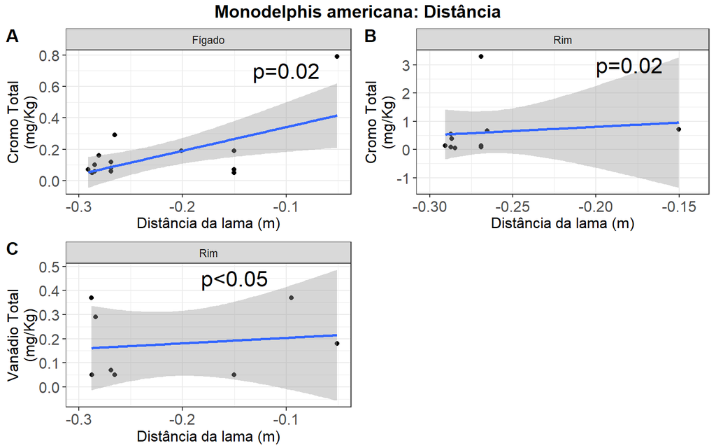

#### 7.2.2. Monodelphis sp.

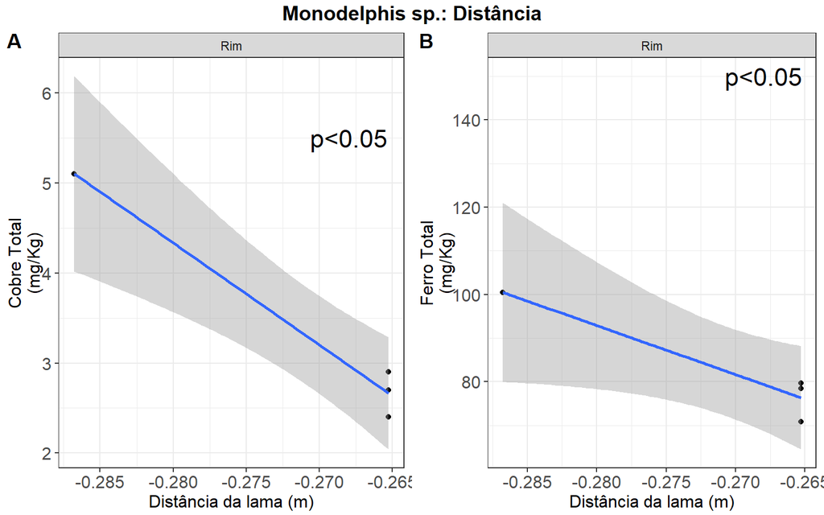

#### 7.2.3. Didelphis aurita

[figure not shown]

#### 7.2.4. Marmosa murina

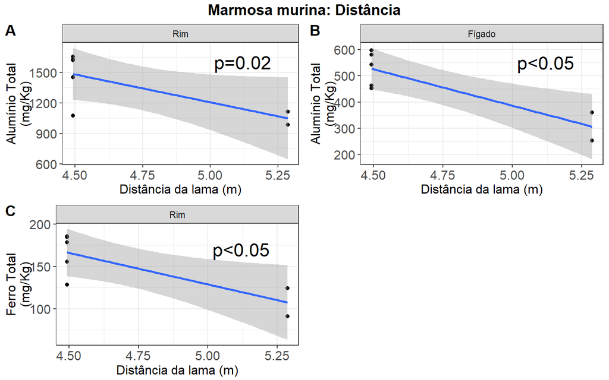

### 7.3. Tipo de áreas

#### 7.3.1.Monodelphis americana

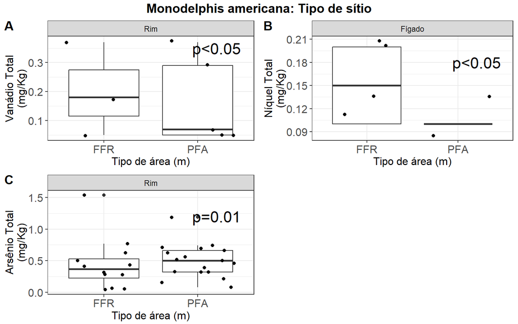

#### 7.3.2. Didelphis aurita

[figure not shown]

### 7.4. Campanha amostral

#### 7.4.1. Akodon sp

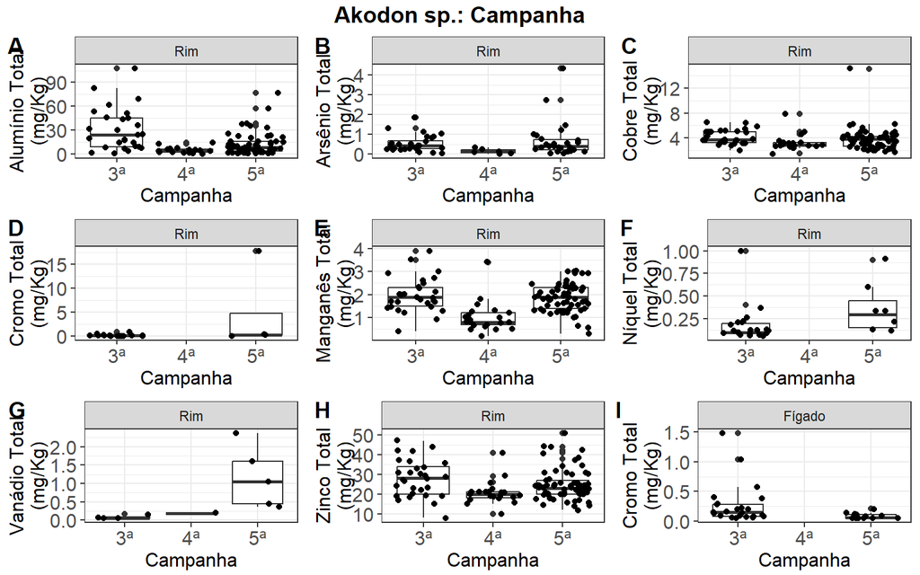

#### 7.4.2. Monodelphis americana

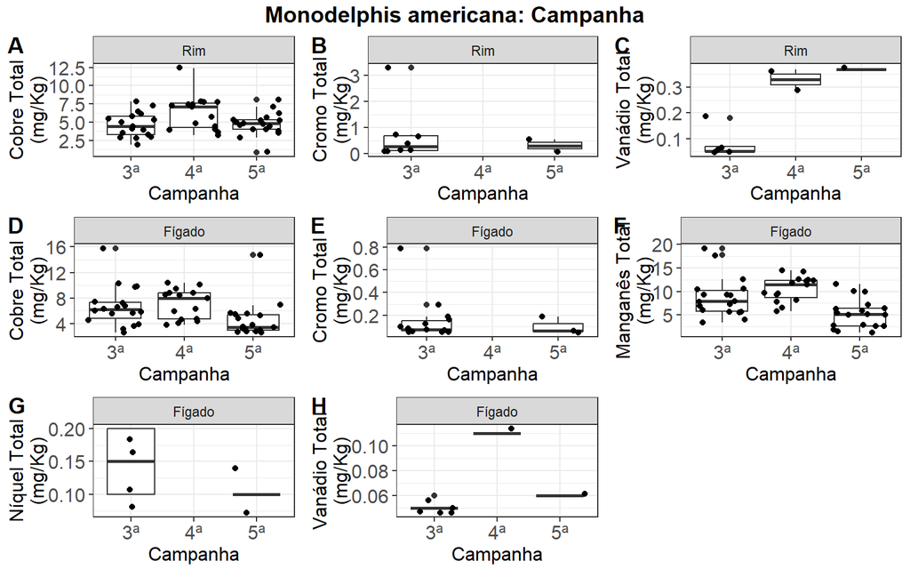

#### 7.4.3. Didelphis aurita

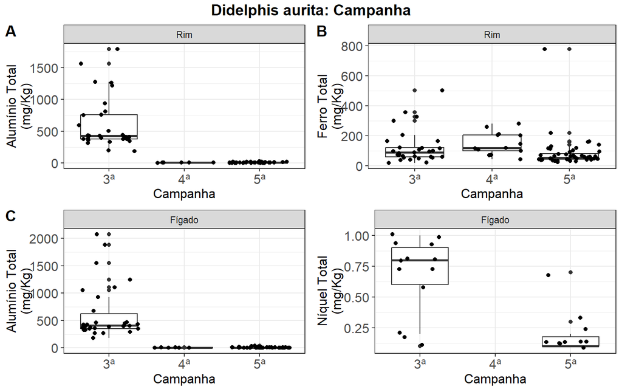

### 7.5. Interação

#### 7.5.1. Interação e efeito da campanha

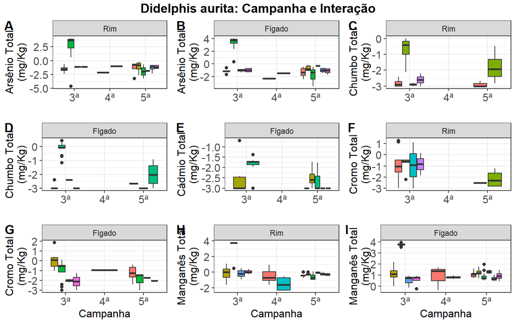

### 7.5.2. Apenas a interação significativa

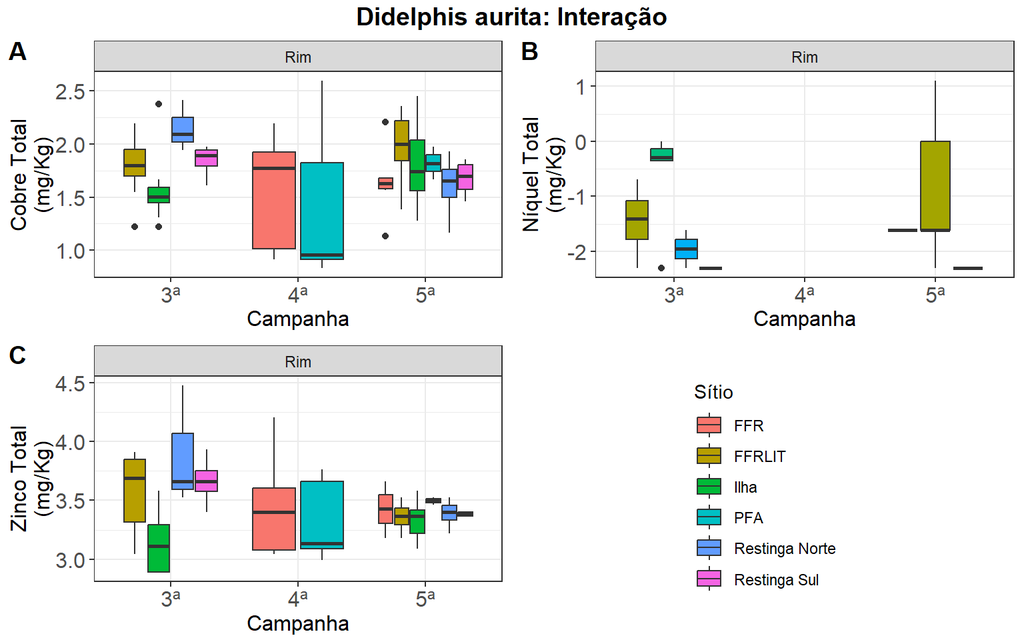

# Abelhas

## Objetivo

- Apresentar os resultados obitidos da contaminação de metais em abelhas.

## Dados coletados

| campanha | id_laboratorio_marcelita_2 | cod_oceanus | sitio_amostral | transecto | data_de_coleta | especie | no_de_individuos | peso_g | data_de_envio | observacao | unidade | aluminio_total | manganes_total | ferro_total | arsenio_total | zinco_total | cobre_total | cobalto_total | vanadio_total | niquel_total | cadmio_total | chumbo_total | cromo_total | desnivel_lama | distancia_lama | tipo_de_sitio |
| --- | --- | --- | --- | --- | --- | --- | --- | --- | --- | --- | --- | --- | --- | --- | --- | --- | --- | --- | --- | --- | --- | --- | --- | --- | --- | --- |
| 5a Campanha | MP-ABE-01 | 2796650 | FFR33 | T1 | 21/11/2023 | Eulaema nigrita | 1 | 0.43 | 12/04/2024 | NA | mg/Kg | 26.9 | 2.3 | 34.3 | 0.15 | 23 | 4.1 | NA | NA | NA | NA | NA | NA | NA | -0.0436645 | FFR |
| 5a Campanha | MP-ABE-02 | 2796570 | FFR33 | T1 | 21/11/2023 | Eulaema cingulata | 2 | 1.37 | 12/04/2024 | NA | mg/Kg | 3.3 | 1.7 | 34.1 | 0.06 | 29 | 4.5 | NA | NA | NA | NA | NA | 0.05 | NA | -0.0436645 | FFR |
| 5a Campanha | MP-ABE-03 | 2796623 | FFR33 | T2 | 21/11/2023 | Eulaema cingulata | 1 | 0.72 | 12/04/2024 | NA | mg/Kg | N.D | 2.9 | 61.3 | 0.02 | 13 | 1.1 | NA | NA | NA | NA | NA | NA | NA | -0.0436645 | FFR |
| 5a Campanha | MP-ABE-04 | 2796633 | FFR34 | T1 | 21/11/2023 | Eulaema cingulata | 2 | 1.37 | 12/04/2024 | NA | mg/Kg | 3.4 | 2.6 | 31 | 0.16 | 17 | 5.3 | NA | NA | NA | NA | NA | NA | NA | -0.0295974 | FFR |
| 5a Campanha | MP-ABE-05 | 2796556 | FFR34 | T2 | 21/11/2023 | Eulaema cingulata | 1 | 0.74 | 12/04/2024 | NA | mg/Kg | 26.1 | 1.5 | 59.6 | 1.07 | 17 | 3.5 | NA | 0.08 | NA | NA | NA | 0.18 | NA | -0.0295974 | FFR |
| 5a Campanha | MP-ABE-06 | 2796644 | FFR34 | T1 | 21/11/2023 | Eulaema nigrita | 2 | 1.04 | 12/04/2024 | NA | mg/Kg | N.D | 1.8 | 23.2 | 0.38 | 18 | 4 | NA | 0.08 | NA | NA | NA | NA | NA | -0.0295974 | FFR |
| 5a Campanha | MP-ABE-07 | 2796517 | FFR34 | T2 | 21/11/2023 | Eulaema nigrita | 2 | 1.13 | 12/04/2024 | NA | mg/Kg | 18.5 | 2.5 | 29.5 | 0.1 | 20 | 3.5 | NA | NA | 0.3 | NA | NA | NA | NA | -0.0295974 | FFR |
| 5a Campanha | MP-ABE-08 | 2796657 | PFA08 | T1 | 08/12/2023 | Eulaema cingulata | 2 | 1.23 | 12/04/2024 | NA | mg/Kg | 4.7 | 2.9 | 59.3 | 0.48 | 31 | 5.3 | NA | 0.19 | NA | NA | NA | 0.13 | NA | -0.2838412 | PFA |
| 5a Campanha | MP-ABE-09 | 2796494 | PFA08 | T1 | 08/12/2023 | Eulaema nigrita | 2 | 1.15 | 12/04/2024 | NA | mg/Kg | N.D | 1.4 | 17.3 | 0.26 | 16 | 2.3 | NA | NA | NA | NA | NA | 0.15 | NA | -0.2838412 | PFA |
| 5a Campanha | MP-ABE-10 | 2796593 | PFA08 | T2 | 08/12/2023 | Eulaema nigrita | 2 | 1.07 | 12/04/2024 | NA | mg/Kg | 2.7 | 1.2 | 20.9 | 0.52 | 18 | 3.9 | NA | NA | 0.6 | NA | 0.3 | NA | NA | -0.2838412 | PFA |
| 5a Campanha | MP-ABE-11 | 2796687 | PFA19 | T1 | 11/11/2023 | Eulaema cingulata | 2 | 1.66 | 12/04/2024 | NA | mg/Kg | N.D | 3.5 | 17.4 | 0.24 | 28 | 3.5 | NA | 0.05 | NA | NA | NA | NA | NA | -0.2907678 | PFA |
| 5a Campanha | MP-ABE-12 | 2796672 | PFA19 | T1 | 12/11/2023 | Eulaema nigrita | 2 | 1.11 | 12/04/2024 | NA | mg/Kg | 7.9 | 2 | 15.6 | 0.06 | 17 | 3.4 | NA | 0.05 | NA | NA | NA | 0.1 | NA | -0.2907678 | PFA |
| 5a Campanha | MP-ABE-13 | 2796643 | FFR33 | T2 | 20/11/2023 | Eulaema nigrita | 1 | 0.64 | 12/04/2024 | NA | mg/Kg | N.D | 2.1 | 15.4 | NA | 10 | 3 | NA | NA | NA | NA | NA | NA | NA | -0.0436645 | FFR |
| 5a Campanha | MP-ABE-14 | 2796649 | PFA15 | T1 | 11/11/2023 | Eulaema cingulata | 2 | 1.62 | 12/04/2024 | NA | mg/Kg | N.D | 8.6 | 17.4 | 0.96 | 18 | 1.6 | NA | 0.1 | NA | NA | NA | NA | NA | -0.2867628 | PFA |
| 5a Campanha | MP-ABE-15 | 2796616 | PFA26 | T2 | 27/11/2023 | Eulaema nigrita | 2 | 1.44 | 12/04/2024 | NA | mg/Kg | 6.3 | 1.8 | 40.8 | 0.11 | 20 | 4.4 | NA | NA | NA | NA | NA | NA | NA | -0.2758259 | PFA |
| 5a Campanha | MP-ABE-16 | 2796707 | PFA10 | T1 | 13/11/2023 | Eulaema cingulata | 2 | 1.4 | 12/04/2024 | NA | mg/Kg | 6 | 1.5 | 29.9 | NA | 20 | 5.2 | NA | NA | 0.1 | NA | 0.05 | 0.46 | NA | -0.2843537 | PFA |
| 5a Campanha | MP-ABE-17 | 2796499 | PFA10 | T2 | 14/11/2023 | Eulaema cingulata | 2 | 1.22 | 12/04/2024 | NA | mg/Kg | N.D | 1.8 | 17.7 | 0.36 | 20 | 2.4 | NA | 0.09 | NA | NA | NA | NA | NA | -0.2843537 | PFA |
| 5a Campanha | MP-ABE-18 | 2796725 | PFA10 | T2 | 14/11/2023 | Eulaema nigrita | 1 | 0.6 | 12/04/2024 | NA | mg/Kg | 7.6 | 2.7 | 162.1 | NA | 21 | 2.1 | NA | 0.11 | NA | NA | NA | NA | NA | -0.2843537 | PFA |
| 5a Campanha | MP-ABE-19 | 2796729 | PFA15 | T2 | 11/11/2023 | Eulaema cingulata | 2 | 1.54 | 12/04/2024 | NA | mg/Kg | N.D | 1.7 | 23 | 0.24 | 23 | 3.5 | NA | NA | NA | NA | NA | NA | NA | -0.2867628 | PFA |
| 5a Campanha | MP-ABE-20 | 2796741 | FFR44 | T1 | 19/11/2023 | Eulaema cingulata | 2 | 1.34 | 12/04/2024 | NA | mg/Kg | 4.9 | 2.6 | 20.3 | 0.06 | 19 | 4.1 | NA | NA | 1.9 | NA | 0.11 | 0.05 | NA | -0.1957832 | FFR |
| 5a Campanha | MP-ABE-21 | 2796752 | PFA13 | T1 | 16/11/2023 | Eulaema cingulata | 2 | 1.06 | 12/04/2024 | NA | mg/Kg | 2 | 1.6 | 29.9 | 0.23 | 23 | 4.5 | NA | NA | 0.1 | NA | 0.16 | 0.67 | NA | -0.2652845 | PFA |
| 5a Campanha | MP-ABE-22 | 2796678 | PFA13 | T2 | 16/11/2023 | Eulaema cingulata | 2 | 1.05 | 12/04/2024 | NA | mg/Kg | 4.3 | 1.5 | 32.4 | 0.39 | 25 | 6.1 | NA | 0.05 | 0.4 | NA | 0.11 | NA | NA | -0.2652845 | PFA |
| 5a Campanha | MP-ABE-23 | 2796712 | PFA13 | T2 | 16/11/2023 | Eulaema nigrita | 2 | 0.78 | 12/04/2024 | NA | mg/Kg | 62 | 5.6 | 90.1 | 0.2 | 36 | 6.7 | NA | 0.16 | 2.3 | NA | 0.22 | 0.22 | NA | -0.2652845 | PFA |
| 5a Campanha | MP-ABE-24 | 2796646 | FFR41 | T1 | 23/11/2023 | Eulaema nigrita | 2 | 1.17 | 12/04/2024 | NA | mg/Kg | 129.7 | 1.6 | 41.8 | NA | 22 | 2.6 | NA | NA | 0.2 | NA | NA | NA | NA | -0.0701776 | FFR |
| 5a Campanha | MP-ABE-25 | 2796482 | FFR41 | T2 | 23/11/2023 | Eulaema nigrita | 2 | 1.27 | 12/04/2024 | NA | mg/Kg | 1.5 | 1.6 | 24.7 | 0.37 | 18 | 3.7 | NA | 0.1 | 9 | NA | NA | NA | NA | -0.0701776 | FFR |
| 5a Campanha | MP-ABE-26 | 2796684 | FFR51 | T1 | 03/02/2024 | Eulaema cingulata | 2 | 1.66 | 12/04/2024 | NA | mg/Kg | 21.9 | 4.5 | 31.5 | 0.16 | 19 | 2.7 | NA | NA | 3.2 | NA | 0.2 | 0.05 | NA | -0.1676934 | FFR |
| 5a Campanha | MP-ABE-27 | 2796727 | FFR51 | T2 | 03/02/2024 | Eulaema cingulata | 2 | 1.15 | 12/04/2024 | NA | mg/Kg | 11.2 | 4.5 | 24.6 | 0.3 | 29 | 6.2 | NA | 0.18 | NA | NA | 0.17 | NA | NA | -0.1676934 | FFR |
| 5a Campanha | MP-ABE-28 | 2796635 | FFR52 | T2 | 03/02/2024 | Eulaema cingulata | 2 | 1.48 | 12/04/2024 | NA | mg/Kg | 11 | 4.4 | 23.3 | 0.02 | 22 | 2.6 | NA | NA | NA | NA | NA | 0.05 | NA | -0.0950406 | FFR |
| 5a Campanha | MP-ABE-29 | 2796708 | FFR41 | T1 | 23/11/2023 | Eulaema cingulata | 2 | 1.27 | 12/04/2024 | NA | mg/Kg | 5.8 | 3.9 | 32.2 | NA | 27 | 5.3 | NA | NA | 0.2 | NA | 0.05 | 0.18 | NA | -0.0701776 | FFR |
| 5a Campanha | MP-ABE-30 | 2796713 | FFR51 | T1 | 03/02/2024 | Eulaema nigrita | 2 | 1.03 | 12/04/2024 | NA | mg/Kg | 12 | 1.7 | 36.7 | NA | 23 | 5.4 | NA | 0.08 | 15 | NA | 0.05 | 0.08 | NA | -0.1676934 | FFR |

[output cut: 301 more lines]

## Tabela de contaminantes

| campanha | tipo_de_sitio | especie | N_amostrado | Aluminio_mean | Aluminio_sd | Aluminio_n | Arsenio_mean | Arsenio_sd | Arsenio_n | Cadmio_mean | Cadmio_sd | Cadmio_n | Chumbo_mean | Chumbo_sd | Chumbo_n | cobalto_mean | cobalto_sd | cobalto_n | Cobre_mean | Cobre_sd | Cobre_n | Cromo_mean | Cromo_sd | Cromo_n | Ferro_mean | Ferro_sd | Ferro_n | Manganes_mean | Manganes_sd | … |
| --- | --- | --- | --- | --- | --- | --- | --- | --- | --- | --- | --- | --- | --- | --- | --- | --- | --- | --- | --- | --- | --- | --- | --- | --- | --- | --- | --- | --- | --- | --- |
| 3a Campanha | FFR | Eulaema cingulata | 50 | 169.05200 | 121.16118 | 50 | 0.1841935 | 0.1175521 | 22 | NaN | NA | 0 | 0.3228947 | 0.3981301 | 22 | 0.0990000 | 0.0264365 | 7 | 5.740000 | 1.5933535 | 30 | 0.8640816 | 1.9698561 | 40 | 35.69800 | 20.476741 | 48 | 4.031579 | 2.4702670 | … |
| 3a Campanha | FFR | Eulaema nigrita | 58 | 183.50000 | 152.31615 | 56 | 0.1964865 | 0.1510742 | 27 | NaN | NA | 0 | 0.1666667 | 0.2979496 | 14 | 0.1025000 | 0.0150000 | 2 | 5.408772 | 0.8386385 | 28 | 0.7213462 | 1.9894625 | 38 | 31.35517 | 15.945831 | 53 | 3.196154 | 1.1523142 | … |
| 3a Campanha | PFA | Eulaema cingulata | 35 | 322.77143 | 279.44205 | 35 | 0.2580769 | 0.1625551 | 22 | 0.10 | NA | 1 | 0.4040741 | 0.7728532 | 14 | 0.1633333 | 0.1686021 | 5 | 8.202857 | 8.2868601 | 26 | 1.4771875 | 5.3987545 | 30 | 53.41143 | 48.914660 | 33 | 4.694118 | 4.4887024 | … |
| 3a Campanha | PFA | Eulaema nigrita | 48 | 193.43750 | 133.23914 | 46 | 0.2010345 | 0.1327012 | 25 | NaN | NA | 0 | 0.2961290 | 0.4629232 | 15 | 0.1133333 | 0.0432049 | 5 | 5.060417 | 1.4125184 | 30 | 1.0535714 | 3.4255217 | 29 | 33.71489 | 22.428853 | 44 | 3.356098 | 1.7319135 | … |
| 5a Campanha | FFR | Eulaema cingulata | 35 | 10.36429 | 6.87875 | 27 | 0.2064706 | 0.2557572 | 11 | NaN | NA | 0 | 0.1220000 | 0.0644291 | 9 | NaN | NA | 0 | 3.571429 | 1.4149561 | 24 | 0.1120000 | 0.0935474 | 5 | 27.45429 | 10.687220 | 30 | 2.634286 | 1.5354522 | … |
| 5a Campanha | FFR | Eulaema nigrita | 39 | 14.14643 | 23.74751 | 28 | 0.2404000 | 0.1849207 | 18 | NaN | NA | 0 | 0.1628571 | 0.1518458 | 5 | 0.0600000 | NA | 1 | 3.448718 | 1.2255765 | 29 | 0.1600000 | 0.1488288 | 5 | 24.12051 | 9.335393 | 36 | 1.835897 | 0.4759960 | … |
| 5a Campanha | PFA | Eulaema cingulata | 31 | 16.28800 | 15.54945 | 26 | 0.3463636 | 0.2011288 | 17 | NaN | NA | 0 | 0.1312500 | 0.0655608 | 7 | NaN | NA | 0 | 4.296774 | 1.6827525 | 24 | 0.9041667 | 2.2413975 | 11 | 35.49355 | 22.713431 | 27 | 2.916129 | 1.9953440 | … |
| 5a Campanha | PFA | Eulaema nigrita | 35 | 15.60968 | 14.61543 | 32 | 0.2400000 | 0.1533949 | 17 | 0.05 | NA | 1 | 0.1238462 | 0.0809875 | 10 | 0.0500000 | NA | 1 | 3.362857 | 1.3257818 | 24 | 0.1300000 | 0.0726865 | 8 | 35.16571 | 30.341594 | 33 | 1.965714 | 0.8505856 | … |

- Somente sitio

  | tipo_de_sitio | especie | N_amostrado | Aluminio_mean | Aluminio_sd | Aluminio_n | Arsenio_mean | Arsenio_sd | Arsenio_n | Cadmio_mean | Cadmio_sd | Cadmio_n | Chumbo_mean | Chumbo_sd | Chumbo_n | cobalto_mean | cobalto_sd | cobalto_n | Cobre_mean | Cobre_sd | Cobre_n | Cromo_mean | Cromo_sd | Cromo_n | Ferro_mean | Ferro_sd | Ferro_n | Manganes_mean | Manganes_sd | Manganes_n | … |
  | --- | --- | --- | --- | --- | --- | --- | --- | --- | --- | --- | --- | --- | --- | --- | --- | --- | --- | --- | --- | --- | --- | --- | --- | --- | --- | --- | --- | --- | --- | --- |
  | FFR | Eulaema cingulata | 85 | 112.0872 | 123.4030 | 77 | 0.1920833 | 0.1766468 | 26 | NaN | NA | 0 | 0.2810417 | 0.3638344 | 25 | 0.0990000 | 0.0264365 | 7 | 4.847059 | 1.855788 | 45 | 0.7366102 | 1.814844 | 41 | 32.30353 | 17.53502 | 76 | 3.361644 | 2.177896 | 43 | … |
  | PFA | Eulaema cingulata | 66 | 195.0700 | 261.3729 | 61 | 0.2985417 | 0.1846790 | 32 | 0.10 | NA | 1 | 0.3417143 | 0.6864079 | 17 | 0.1633333 | 0.1686021 | 5 | 6.368182 | 6.409876 | 44 | 1.3209091 | 4.729106 | 37 | 44.99545 | 39.63386 | 59 | 3.846154 | 3.613347 | 47 | … |
  | FFR | Eulaema nigrita | 97 | 128.3616 | 148.6898 | 84 | 0.2141935 | 0.1655151 | 36 | NaN | NA | 0 | 0.1661224 | 0.2805561 | 17 | 0.0940000 | 0.0230217 | 3 | 4.612500 | 1.397083 | 48 | 0.6721053 | 1.905734 | 40 | 28.44639 | 14.07776 | 84 | 2.613187 | 1.142921 | 36 | … |
  | PFA | Eulaema nigrita | 83 | 123.6570 | 135.7039 | 77 | 0.2174000 | 0.1415773 | 32 | 0.05 | NA | 1 | 0.2452273 | 0.3970677 | 19 | 0.1042857 | 0.0461364 | 5 | 4.344578 | 1.607395 | 43 | 0.8352727 | 3.011193 | 33 | 34.33415 | 25.93522 | 71 | 2.715790 | 1.553838 | 38 | … |

## **1. Contaminação *Eulaema nigrita***

| campanha | id_laboratorio_marcelita_2 | cod_oceanus | sitio_amostral | transecto | data_de_coleta | especie | no_de_individuos | peso_g | data_de_envio | observacao | unidade | aluminio_total | manganes_total | ferro_total | arsenio_total | zinco_total | cobre_total | cobalto_total | vanadio_total | niquel_total | cadmio_total | chumbo_total | cromo_total | desnivel_lama | distancia_lama | tipo_de_sitio |
| --- | --- | --- | --- | --- | --- | --- | --- | --- | --- | --- | --- | --- | --- | --- | --- | --- | --- | --- | --- | --- | --- | --- | --- | --- | --- | --- |
| 5a Campanha | MP-ABE-01 | 2796650 | FFR33 | T1 | 21/11/2023 | Eulaema nigrita | 1 | 0.43 | 12/04/2024 | NA | mg/Kg | 26.9 | 2.3 | 34.3 | 0.15 | 23 | 4.1 | NA | NA | NA | NA | NA | NA | NA | -0.0436645 | FFR |
| 5a Campanha | MP-ABE-06 | 2796644 | FFR34 | T1 | 21/11/2023 | Eulaema nigrita | 2 | 1.04 | 12/04/2024 | NA | mg/Kg | N.D | 1.8 | 23.2 | 0.38 | 18 | 4 | NA | 0.08 | NA | NA | NA | NA | NA | -0.0295974 | FFR |
| 5a Campanha | MP-ABE-07 | 2796517 | FFR34 | T2 | 21/11/2023 | Eulaema nigrita | 2 | 1.13 | 12/04/2024 | NA | mg/Kg | 18.5 | 2.5 | 29.5 | 0.1 | 20 | 3.5 | NA | NA | 0.3 | NA | NA | NA | NA | -0.0295974 | FFR |
| 5a Campanha | MP-ABE-09 | 2796494 | PFA08 | T1 | 08/12/2023 | Eulaema nigrita | 2 | 1.15 | 12/04/2024 | NA | mg/Kg | N.D | 1.4 | 17.3 | 0.26 | 16 | 2.3 | NA | NA | NA | NA | NA | 0.15 | NA | -0.2838412 | PFA |
| 5a Campanha | MP-ABE-10 | 2796593 | PFA08 | T2 | 08/12/2023 | Eulaema nigrita | 2 | 1.07 | 12/04/2024 | NA | mg/Kg | 2.7 | 1.2 | 20.9 | 0.52 | 18 | 3.9 | NA | NA | 0.6 | NA | 0.3 | NA | NA | -0.2838412 | PFA |
| 5a Campanha | MP-ABE-12 | 2796672 | PFA19 | T1 | 12/11/2023 | Eulaema nigrita | 2 | 1.11 | 12/04/2024 | NA | mg/Kg | 7.9 | 2 | 15.6 | 0.06 | 17 | 3.4 | NA | 0.05 | NA | NA | NA | 0.1 | NA | -0.2907678 | PFA |
| 5a Campanha | MP-ABE-13 | 2796643 | FFR33 | T2 | 20/11/2023 | Eulaema nigrita | 1 | 0.64 | 12/04/2024 | NA | mg/Kg | N.D | 2.1 | 15.4 | NA | 10 | 3 | NA | NA | NA | NA | NA | NA | NA | -0.0436645 | FFR |
| 5a Campanha | MP-ABE-15 | 2796616 | PFA26 | T2 | 27/11/2023 | Eulaema nigrita | 2 | 1.44 | 12/04/2024 | NA | mg/Kg | 6.3 | 1.8 | 40.8 | 0.11 | 20 | 4.4 | NA | NA | NA | NA | NA | NA | NA | -0.2758259 | PFA |
| 5a Campanha | MP-ABE-18 | 2796725 | PFA10 | T2 | 14/11/2023 | Eulaema nigrita | 1 | 0.6 | 12/04/2024 | NA | mg/Kg | 7.6 | 2.7 | 162.1 | NA | 21 | 2.1 | NA | 0.11 | NA | NA | NA | NA | NA | -0.2843537 | PFA |
| 5a Campanha | MP-ABE-23 | 2796712 | PFA13 | T2 | 16/11/2023 | Eulaema nigrita | 2 | 0.78 | 12/04/2024 | NA | mg/Kg | 62 | 5.6 | 90.1 | 0.2 | 36 | 6.7 | NA | 0.16 | 2.3 | NA | 0.22 | 0.22 | NA | -0.2652845 | PFA |
| 5a Campanha | MP-ABE-24 | 2796646 | FFR41 | T1 | 23/11/2023 | Eulaema nigrita | 2 | 1.17 | 12/04/2024 | NA | mg/Kg | 129.7 | 1.6 | 41.8 | NA | 22 | 2.6 | NA | NA | 0.2 | NA | NA | NA | NA | -0.0701776 | FFR |
| 5a Campanha | MP-ABE-25 | 2796482 | FFR41 | T2 | 23/11/2023 | Eulaema nigrita | 2 | 1.27 | 12/04/2024 | NA | mg/Kg | 1.5 | 1.6 | 24.7 | 0.37 | 18 | 3.7 | NA | 0.1 | 9 | NA | NA | NA | NA | -0.0701776 | FFR |
| 5a Campanha | MP-ABE-30 | 2796713 | FFR51 | T1 | 03/02/2024 | Eulaema nigrita | 2 | 1.03 | 12/04/2024 | NA | mg/Kg | 12 | 1.7 | 36.7 | NA | 23 | 5.4 | NA | 0.08 | 15 | NA | 0.05 | 0.08 | NA | -0.1676934 | FFR |
| 5a Campanha | MP-ABE-31 | 2796521 | FFR52 | T2 | 04/03/2024 | Eulaema nigrita | 2 | 1.17 | 12/04/2024 | NA | mg/Kg | 21.8 | 1.6 | 35.6 | NA | 24 | 4.4 | NA | NA | 0.5 | NA | 0.05 | NA | NA | -0.0950406 | FFR |
| 5a Campanha | MP-ABE-32 | 2796704 | FFR51 | T2 | 03/02/2024 | Eulaema nigrita | 2 | 1.23 | 12/04/2024 | NA | mg/Kg | 5.5 | 2.3 | 12.2 | 0.63 | 16 | 2.2 | NA | NA | NA | NA | 0.05 | NA | NA | -0.1676934 | FFR |
| 5a Campanha | MP-ABE-36 | 2796677 | FFR45 | T1 | 20/11/2023 | Eulaema nigrita | 3 | 1.55 | 12/04/2024 | NA | mg/Kg | 9 | 3.1 | 28.4 | 0.12 | 22 | 3.2 | NA | 0.11 | 0.1 | NA | 0.1 | 0.4 | NA | -0.2423592 | FFR |
| 5a Campanha | MP-ABE-37 | 2796685 | FFR52 | T1 | 04/03/2024 | Eulaema nigrita | 2 | 1.07 | 12/04/2024 | NA | mg/Kg | 3.2 | 1.3 | 26 | NA | 19 | 5 | NA | NA | 0.2 | NA | NA | NA | NA | -0.0950406 | FFR |
| 5a Campanha | MP-ABE-38 | 2796641 | FFR45 | T2 | 19/11/2023 | Eulaema nigrita | 2 | 1.15 | 12/04/2024 | NA | mg/Kg | 17.4 | 1.8 | 33.4 | 0.13 | 21 | 4.6 | NA | NA | 0.3 | NA | NA | 0.21 | NA | -0.2423592 | FFR |
| 5a Campanha | MP-ABE-39 | 2796634 | PFA24 | T1 | 15/03/2024 | Eulaema nigrita | 2 | 1.2 | 12/04/2024 | NA | mg/Kg | 11.1 | 2.1 | 27 | NA | 23 | 4.3 | NA | NA | NA | NA | 0.06 | 0.09 | NA | -0.2844862 | PFA |
| 5a Campanha | MP-ABE-42 | 2796558 | PFA24 | T2 | 15/03/2024 | Eulaema nigrita | 2 | 1.22 | 12/04/2024 | NA | mg/Kg | 18 | 2.1 | 21.6 | NA | 10 | 1.5 | NA | NA | NA | NA | NA | NA | NA | -0.2844862 | PFA |
| 5a Campanha | MP-ABE-43 | 2796654 | FFR43 | T1 | 25/11/2023 | Eulaema nigrita | 3 | 1.48 | 12/04/2024 | NA | mg/Kg | 3.9 | 2.3 | 23.3 | 0.03 | 22 | 4.2 | NA | NA | 0.3 | NA | NA | 0.06 | NA | -0.2009528 | FFR |
| 5a Campanha | MP-ABE-44 | 2796550 | FFR43 | T2 | 25/11/2023 | Eulaema nigrita | 2 | 1.09 | 12/04/2024 | NA | mg/Kg | 12.7 | 1.7 | 21.8 | 0.17 | 22 | 3.6 | NA | NA | NA | NA | 0.18 | NA | NA | -0.2009528 | FFR |
| 5a Campanha | MP-ABE-47 | 2796673 | FFR46 | T1 | 27/11/2023 | Eulaema nigrita | 2 | 1.13 | 12/04/2024 | NA | mg/Kg | 15.8 | 1.4 | 26.7 | NA | 18 | 4 | NA | NA | NA | NA | NA | NA | NA | 0.1354802 | FFR |
| 5a Campanha | MP-ABE-48 | 2796503 | FFR46 | T2 | 27/11/2023 | Eulaema nigrita | 2 | 1.05 | 12/04/2024 | NA | mg/Kg | 10.6 | 1.2 | 23.9 | NA | 20 | 4.1 | NA | NA | NA | NA | NA | NA | NA | 0.1354802 | FFR |
| 5a Campanha | MP-ABE-52 | 2796594 | PFA15 | T1 | 11/11/2023 | Eulaema nigrita | 2 | 1.22 | 12/04/2024 | NA | mg/Kg | 13.4 | 1.5 | 39.7 | 0.17 | 21 | 4.4 | NA | NA | NA | NA | NA | NA | NA | -0.2867628 | PFA |
| 5a Campanha | MP-ABE-53 | 2796526 | PFA15 | T2 | 12/11/2023 | Eulaema nigrita | 1 | 0.59 | 12/04/2024 | NA | mg/Kg | 7.3 | 1.6 | 17.7 | NA | 18 | 2.8 | NA | NA | NA | NA | 0.05 | NA | NA | -0.2867628 | PFA |
| 5a Campanha | MP-ABE-54 | 2796577 | PFA26 | T1 | 27/11/2023 | Eulaema nigrita | 3 | 1.65 | 12/04/2024 | NA | mg/Kg | 11.8 | 1.6 | 51.5 | 0.31 | 20 | 4.7 | 0.05 | NA | 1.5 | NA | 0.06 | 0.12 | NA | -0.2758259 | PFA |
| 5a Campanha | MP-ABE-56 | 2796735 | FFR44 | T1 | 20/11/2023 | Eulaema nigrita | 2 | 1.2 | 12/04/2024 | NA | mg/Kg | 3.4 | 1.1 | 16.4 | 0.16 | 14 | 2.5 | NA | NA | NA | NA | NA | NA | NA | -0.1957832 | FFR |
| 5a Campanha | MP-ABE-58 | 2796724 | FFR39 | T1 | 13/11/2023 | Eulaema nigrita | 2 | 1.22 | 12/04/2024 | NA | mg/Kg | 5.3 | 2.1 | 32.1 | 0.12 | 21 | 2.8 | NA | NA | NA | NA | NA | NA | NA | -0.0850910 | FFR |
| 5a Campanha | MP-ABE-59 | 2796602 | FFR39 | T2 | 13/11/2023 | Eulaema nigrita | 2 | 1.11 | 12/04/2024 | NA | mg/Kg | 6.1 | 2.4 | 15 | 0.25 | 23 | 2.9 | NA | NA | NA | NA | NA | NA | NA | -0.0850910 | FFR |

[output cut: 150 more lines]

### 1.1. Aluminio

- Simplificação do modelo global

```
## Global model call: lme4::lmer(formula = aluminio_total ~ distancia_lama + tipo_de_sitio *
##     campanha + (1 | sitio_amostral), data = al, na.action = "na.fail")
## ---
## Model selection table
##    (Int) cmp dst_lam tip_de_sit cmp:tip_de_sit df   logLik  AICc  delta weight
## 2  4.845   +                                    4 -229.574 467.4   0.00  0.387
## 8  4.799   +  1.1080          +                 6 -228.031 468.6   1.20  0.213
## 4  4.861   +  0.1049                            5 -229.197 468.8   1.37  0.195
## 6  4.749   +                  +                 5 -229.700 469.8   2.38  0.118
## 16 4.796   +  1.1150          +              +  7 -228.280 471.3   3.88  0.056
## 14 4.753   +                  +              +  6 -229.953 472.4   5.04  0.031
## 7  4.009      2.4940          +                 5 -305.849 622.1 154.68  0.000
## 3  4.083      1.1310                            4 -307.260 622.8 155.37  0.000
## 1  3.902                                        3 -308.996 624.1 156.74  0.000
## 5  3.880                      +                 4 -309.454 627.2 159.76  0.000
## Models ranked by AICc(x)
## Random terms (all models):
##   1 | sitio_amostral
```

- Resultado do melhor modelo

```
## Analysis of Deviance Table (Type II Wald chisquare tests)
##
## Response: aluminio_total
##           Chisq Df Pr(>Chisq)
## campanha 289.24  1  < 2.2e-16 ***
## ---
## Signif. codes:  0 '***' 0.001 '**' 0.01 '*' 0.05 '.' 0.1 ' ' 1
```

| contrast | campanha | estimate | SE | df | t.ratio | p.value |
| --- | --- | --- | --- | --- | --- | --- |
| FFR - PFA | 3a Campanha | -0.4689429 | 0.2859215 | 57.92340 | -1.640111 | 0.1064024 |
| FFR - PFA | 5a Campanha | -0.4461181 | 0.3066241 | 77.21625 | -1.454935 | 0.1497406 |

| contrast | tipo_de_sitio | estimate | SE | df | t.ratio | p.value |
| --- | --- | --- | --- | --- | --- | --- |
| 3a Campanha - 5a Campanha | FFR | 2.583296 | 0.2228875 | 145.9451 | 11.59013 | 0 |
| 3a Campanha - 5a Campanha | PFA | 2.606121 | 0.2183143 | 137.1391 | 11.93747 | 0 |

### 1.2. Arsenio

- Simplificação do modelo global

```
## Global model call: lme4::lmer(formula = arsenio_total ~ campanha * tipo_de_sitio +
##     distancia_lama + (1 | sitio_amostral), data = metal, na.action = "na.fail")
## ---
## Model selection table
##     (Int) cmp dst_lam tip_de_sit cmp:tip_de_sit df   logLik  AICc delta weight
## 1  -1.845                                        3 -146.029 298.3  0.00  0.452
## 3  -1.833     0.08528                            4 -145.886 300.1  1.87  0.178
## 2  -1.933   +                                    4 -146.109 300.6  2.31  0.142
## 5  -1.882                      +                 4 -146.758 301.9  3.61  0.074
## 4  -1.917   + 0.12520                            5 -145.945 302.5  4.18  0.056
## 7  -1.870     0.41560          +                 5 -146.104 302.8  4.50  0.048
## 6  -1.966   +                  +                 5 -146.854 304.3  6.00  0.023
## 8  -1.957   + 0.47100          +                 6 -146.133 305.1  6.79  0.015
## 14 -2.005   +                  +              +  6 -146.800 306.4  8.12  0.008
## 16 -1.999   + 0.49980          +              +  7 -146.039 307.2  8.88  0.005
## Models ranked by AICc(x)
## Random terms (all models):
##   1 | sitio_amostral
```

- Resultado

```
## Analysis of Deviance Table (Type II Wald chisquare tests)
##
## Response: arsenio_total
##                 Chisq Df Pr(>Chisq)
## distancia_lama 0.0353  1     0.8509
```

| contrast | campanha | estimate | SE | df | t.ratio | p.value |
| --- | --- | --- | --- | --- | --- | --- |
| FFR - PFA | 3a Campanha | -0.3016373 | 0.2815176 | 46.98005 | -1.0714685 | 0.2894325 |
| FFR - PFA | 5a Campanha | -0.0657852 | 0.3025816 | 61.70160 | -0.2174129 | 0.8286039 |

| contrast | tipo_de_sitio | estimate | SE | df | t.ratio | p.value |
| --- | --- | --- | --- | --- | --- | --- |
| 3a Campanha - 5a Campanha | FFR | -0.3255925 | 0.2370456 | 104.78287 | -1.3735439 | 0.1725150 |
| 3a Campanha - 5a Campanha | PFA | -0.0897404 | 0.2615605 | 95.62628 | -0.3430962 | 0.7322792 |

### 1.3. Chumbo

- Simplificação do modelo global

```
## Global model call: lme4::lmer(formula = chumbo_total ~ distancia_lama + tipo_de_sitio *
##     campanha + (1 | sitio_amostral), data = metal, na.action = "na.fail")
## ---
## Model selection table
##     (Int) cmp  dst_lam tip_de_sit cmp:tip_de_sit df   logLik  AICc delta weight
## 3  -2.405     -0.78910                            4 -126.647 261.8  0.00  0.301
## 1  -2.270                                         3 -127.830 261.9  0.18  0.275
## 5  -2.401                       +                 4 -127.610 263.7  1.93  0.115
## 7  -2.406     -0.06315          +                 5 -126.497 263.7  1.94  0.114
## 4  -2.400   + -0.83350                            5 -127.102 264.9  3.15  0.062
## 2  -2.271   +                                     4 -128.338 265.1  3.38  0.055
## 6  -2.393   +                   +                 5 -128.087 266.9  5.12  0.023
## 8  -2.401   + -0.11010          +                 6 -126.952 266.9  5.14  0.023
## 14 -2.441   +                   +              +  6 -127.325 267.6  5.88  0.016
## 16 -2.431   +  0.18670          +              +  7 -126.152 267.6  5.88  0.016
## Models ranked by AICc(x)
## Random terms (all models):
##   1 | sitio_amostral
```

- Resultado do melhor modelo

```
## Analysis of Deviance Table (Type II Wald chisquare tests)
##
## Response: chumbo_total
##                 Chisq Df Pr(>Chisq)
## distancia_lama 0.9525  1     0.3291
```

| contrast | campanha | estimate | SE | df | t.ratio | p.value |
| --- | --- | --- | --- | --- | --- | --- |
| FFR - PFA | 3a Campanha | -0.4415704 | 0.3822681 | 41.58211 | -1.1551328 | 0.2546309 |
| FFR - PFA | 5a Campanha | 0.0984540 | 0.4979589 | 69.39879 | 0.1977151 | 0.8438459 |

| contrast | tipo_de_sitio | estimate | SE | df | t.ratio | p.value |
| --- | --- | --- | --- | --- | --- | --- |
| 3a Campanha - 5a Campanha | FFR | -0.2905451 | 0.4200379 | 86.81303 | -0.6917117 | 0.4909642 |
| 3a Campanha - 5a Campanha | PFA | 0.2494793 | 0.3101423 | 69.40979 | 0.8044027 | 0.4239111 |

### 1.4. Cadmio

```
## [1] "dados com baixa variabilidade."
```

|  | cadmio_total | tipo_de_sitio | sitio_amostral | campanha | distancia_lama |
| --- | --- | --- | --- | --- | --- |
| 46 | 0.05 | PFA | PFA09 | 5a Campanha | -0.2822344 |

### 1.5. Cobalto

- Simplificação do modelo global

```
## Global model call: lme4::lmer(formula = as.numeric(cobalto_total) ~ distancia_lama +
##     tipo_de_sitio * campanha + (1 | sitio_amostral), data = metal,
##     na.action = "na.fail")
## ---
## Model selection table
##     (Int) cmp dst_lam tip_de_sit cmp:tip_de_sit df logLik AICc delta weight
## 1  -2.372                                        3 -6.777 22.6  0.00  0.436
## 2  -2.261   +                                    4 -4.558 22.8  0.28  0.380
## 3  -2.272      0.4631                            4 -5.785 25.3  2.73  0.111
## 4  -2.232   +  0.1349                            5 -3.839 27.7  5.12  0.034
## 5  -2.392                      +                 4 -7.276 28.3  5.71  0.025
## 6  -2.252   +                  +                 5 -5.228 30.5  7.90  0.008
## 7  -2.282      0.8541          +                 5 -5.901 31.8  9.25  0.004
## 8  -2.230   +  0.1642          +                 6 -4.186 37.2 14.62  0.000
## 14 -2.279   +                  +              +  6 -4.770 38.3 15.78  0.000
## 16 -2.244   +  0.3968          +              +  7 -3.559 49.1 26.56  0.000
## Models ranked by AICc(x)
## Random terms (all models):
##   1 | sitio_amostral
```

```
## Analysis of Deviance Table (Type II Wald chisquare tests)
##
## Response: as.numeric(cobalto_total)
##           Chisq Df Pr(>Chisq)
## campanha 6.5896  1    0.01026 *
## ---
## Signif. codes:  0 '***' 0.001 '**' 0.01 '*' 0.05 '.' 0.1 ' ' 1
```

| contrast | campanha | estimate | SE | df | t.ratio | p.value |
| --- | --- | --- | --- | --- | --- | --- |
| FFR - PFA | 3a Campanha | -0.1323246 | 0.3914917 | 2.778805 | -0.3380011 | 0.7592682 |
| FFR - PFA | 5a Campanha | 0.2655690 | 0.6277547 | 6.635677 | 0.4230458 | 0.6856328 |

| contrast | tipo_de_sitio | estimate | SE | df | t.ratio | p.value |
| --- | --- | --- | --- | --- | --- | --- |
| 3a Campanha - 5a Campanha | FFR | 0.4708148 | 0.5046999 | 4.283183 | 0.9328608 | 0.4004313 |
| 3a Campanha - 5a Campanha | PFA | 0.8687084 | 0.5210849 | 5.958748 | 1.6671148 | 0.1468817 |

### 1.6. Cobre

- Simplificação do modelo global

```
## Global model call: lme4::lmer(formula = as.numeric(cobre_total) ~ distancia_lama +
##     tipo_de_sitio * campanha + (1 | sitio_amostral), data = metal,
##     na.action = "na.fail")
## ---
## Model selection table
##    (Int) cmp dst_lam tip_de_sit cmp:tip_de_sit df  logLik  AICc delta weight
## 2  1.628   +                                    4 -56.023 120.3  0.00  0.581
## 4  1.664   +  0.2432                            5 -55.612 121.6  1.30  0.304
## 6  1.663   +                  +                 5 -56.907 124.2  3.89  0.083
## 8  1.669   +  0.1688          +                 6 -57.240 127.0  6.69  0.020
## 14 1.677   +                  +              +  6 -58.024 128.5  8.26  0.009
## 16 1.682   +  0.1624          +              +  7 -58.380 131.4 11.14  0.002
## 1  1.432                                        3 -91.117 188.4 68.10  0.000
## 3  1.477      0.3011                            4 -90.477 189.2 68.91  0.000
## 5  1.471                      +                 4 -91.988 192.2 71.93  0.000
## 7  1.481      0.2436          +                 5 -91.981 194.3 74.03  0.000
## Models ranked by AICc(x)
## Random terms (all models):
##   1 | sitio_amostral
```

- Resultado do melhor modelo

```
## Analysis of Deviance Table (Type II Wald chisquare tests)
##
## Response: as.numeric(cobre_total)
##           Chisq Df Pr(>Chisq)
## campanha 92.096  1  < 2.2e-16 ***
## ---
## Signif. codes:  0 '***' 0.001 '**' 0.01 '*' 0.05 '.' 0.1 ' ' 1
```

| contrast | campanha | estimate | SE | df | t.ratio | p.value |
| --- | --- | --- | --- | --- | --- | --- |
| FFR - PFA | 3a Campanha | 0.0671457 | 0.0816432 | 61.88266 | 0.8224293 | 0.4139904 |
| FFR - PFA | 5a Campanha | -0.0039269 | 0.0884453 | 91.99722 | -0.0443988 | 0.9646827 |

| contrast | tipo_de_sitio | estimate | SE | df | t.ratio | p.value |
| --- | --- | --- | --- | --- | --- | --- |
| 3a Campanha - 5a Campanha | FFR | 0.5025849 | 0.0675444 | 156.3881 | 7.440810 | 0 |
| 3a Campanha - 5a Campanha | PFA | 0.4315123 | 0.0725915 | 155.6874 | 5.944389 | 0 |

### 1.7. Cromo

- Simplificação do modelo global

```
## Global model call: lme4::lmer(formula = as.numeric(cromo_total) ~ distancia_lama +
##     tipo_de_sitio * campanha + (1 | sitio_amostral), data = metal,
##     na.action = "na.fail")
## ---
## Model selection table
##     (Int) cmp  dst_lam tip_de_sit cmp:tip_de_sit df   logLik  AICc delta weight
## 2  -1.273   +                                     4 -177.539 363.5  0.00  0.336
## 4  -1.349   + -0.50520                            5 -176.601 363.8  0.32  0.287
## 8  -1.318   + -1.33100          +                 6 -176.242 365.3  1.84  0.134
## 16 -1.292   + -1.47600          +              +  7 -175.498 366.1  2.63  0.090
## 6  -1.252   +                   +                 5 -177.935 366.4  2.99  0.076
## 14 -1.230   +                   +              +  6 -177.313 367.4  3.98  0.046
## 1  -1.438                                         3 -181.871 370.0  6.51  0.013
## 3  -1.435      0.01408                            4 -181.147 370.7  7.22  0.009
## 7  -1.401     -0.98000          +                 5 -180.649 371.9  8.41  0.005
## 5  -1.352                       +                 4 -182.082 372.5  9.09  0.004
## Models ranked by AICc(x)
## Random terms (all models):
##   1 | sitio_amostral
```

- Resultado do melhor modelo

```
## Analysis of Deviance Table (Type II Wald chisquare tests)
##
## Response: as.numeric(cromo_total)
##           Chisq Df Pr(>Chisq)
## campanha 9.8419  1   0.001706 **
## ---
## Signif. codes:  0 '***' 0.001 '**' 0.01 '*' 0.05 '.' 0.1 ' ' 1
```

| contrast | campanha | estimate | SE | df | t.ratio | p.value |
| --- | --- | --- | --- | --- | --- | --- |
| FFR - PFA | 3a Campanha | 0.4361041 | 0.4265955 | 46.37488 | 1.0222893 | 0.3119474 |
| FFR - PFA | 5a Campanha | 0.0053800 | 0.6754176 | 92.14258 | 0.0079654 | 0.9936618 |

| contrast | tipo_de_sitio | estimate | SE | df | t.ratio | p.value |
| --- | --- | --- | --- | --- | --- | --- |
| 3a Campanha - 5a Campanha | FFR | 1.3009461 | 0.5997448 | 104.03676 | 2.169166 | 0.0323472 |
| 3a Campanha - 5a Campanha | PFA | 0.8702221 | 0.3760900 | 95.49094 | 2.313867 | 0.0228195 |

### 1.8. Ferro

- Simplificação do modelo global

```
## Global model call: lme4::lmer(formula = as.numeric(ferro_total) ~ distancia_lama +
##     tipo_de_sitio * campanha + (1 | sitio_amostral), data = metal,
##     na.action = "na.fail")
## ---
## Model selection table
##    (Int) cmp dst_lam tip_de_sit cmp:tip_de_sit df   logLik  AICc delta weight
## 1  3.317                                        3 -118.139 242.4  0.00  0.219
## 2  3.385   +                                    4 -117.124 242.5  0.06  0.213
## 4  3.336   + -0.3495                            5 -116.307 243.0  0.55  0.167
## 3  3.269     -0.3228                            4 -117.561 243.4  0.94  0.137
## 6  3.325   +                  +                 5 -116.926 244.2  1.78  0.090
## 5  3.257                      +                 4 -118.117 244.5  2.05  0.079
## 14 3.366   +                  +              +  6 -116.688 245.9  3.45  0.039
## 8  3.320   + -0.1368          +                 6 -117.154 246.8  4.38  0.025
## 7  3.253     -0.1051          +                 5 -118.382 247.1  4.70  0.021
## 16 3.361   + -0.1591          +              +  7 -116.877 248.4  6.00  0.011
## Models ranked by AICc(x)
## Random terms (all models):
##   1 | sitio_amostral
```

```
## Analysis of Deviance Table (Type II Wald chisquare tests)
##
## Response: as.numeric(ferro_total)
##           Chisq Df Pr(>Chisq)
## campanha 5.5753  1    0.01822 *
## ---
## Signif. codes:  0 '***' 0.001 '**' 0.01 '*' 0.05 '.' 0.1 ' ' 1
```

| contrast | campanha | estimate | SE | df | t.ratio | p.value |
| --- | --- | --- | --- | --- | --- | --- |
| FFR - PFA | 3a Campanha | -0.0030607 | 0.1144546 | 63.53278 | -0.0267419 | 0.9787494 |
| FFR - PFA | 5a Campanha | -0.2299281 | 0.1235830 | 91.85231 | -1.8605150 | 0.0660122 |

| contrast | tipo_de_sitio | estimate | SE | df | t.ratio | p.value |
| --- | --- | --- | --- | --- | --- | --- |
| 3a Campanha - 5a Campanha | FFR | 0.2751453 | 0.0945326 | 156.9643 | 2.910587 | 0.0041324 |
| 3a Campanha - 5a Campanha | PFA | 0.0482779 | 0.1022990 | 154.5536 | 0.471930 | 0.6376424 |

### 1.9. Manganes

- Simplificação do modelo global

```
## Global model call: lme4::lmer(formula = as.numeric(manganes_total) ~ distancia_lama +
##     tipo_de_sitio * campanha + (1 | sitio_amostral), data = metal,
##     na.action = "na.fail")
## ---
## Model selection table
##     (Int) cmp dst_lam tip_de_sit cmp:tip_de_sit df   logLik  AICc delta weight
## 2  1.0350   +                                    4 -122.817 253.9  0.00  0.694
## 4  1.0060   + -0.1997                            5 -122.938 256.3  2.37  0.212
## 6  1.0310   +                  +                 5 -124.313 259.0  5.12  0.054
## 8  1.0170   + -0.3768          +                 6 -123.869 260.3  6.39  0.028
## 14 1.0450   +                  +              +  6 -125.165 262.9  8.98  0.008
## 16 1.0310   + -0.3878          +              +  7 -124.694 264.1 10.21  0.004
## 1  0.8318                                        3 -136.887 279.9 26.04  0.000
## 3  0.8152     -0.1034                            4 -137.136 282.5 28.64  0.000
## 5  0.8364                      +                 4 -138.290 284.8 30.95  0.000
## 7  0.8245     -0.2631          +                 5 -138.039 286.5 32.57  0.000
## Models ranked by AICc(x)
## Random terms (all models):
##   1 | sitio_amostral
```

- Resultado do melhor modelo

```
## Analysis of Deviance Table (Type II Wald chisquare tests)
##
## Response: as.numeric(manganes_total)
##           Chisq Df Pr(>Chisq)
## campanha 34.446  1  4.381e-09 ***
## ---
## Signif. codes:  0 '***' 0.001 '**' 0.01 '*' 0.05 '.' 0.1 ' ' 1
```

| contrast | campanha | estimate | SE | df | t.ratio | p.value |
| --- | --- | --- | --- | --- | --- | --- |
| FFR - PFA | 3a Campanha | 0.1219849 | 0.1504002 | 58.78507 | 0.8110687 | 0.420598 |
| FFR - PFA | 5a Campanha | 0.0428693 | 0.1508850 | 71.80290 | 0.2841189 | 0.777137 |

| contrast | tipo_de_sitio | estimate | SE | df | t.ratio | p.value |
| --- | --- | --- | --- | --- | --- | --- |
| 3a Campanha - 5a Campanha | FFR | 0.4854093 | 0.1040793 | 145.4668 | 4.663841 | 0.0000070 |
| 3a Campanha - 5a Campanha | PFA | 0.4062937 | 0.1138435 | 146.2035 | 3.568879 | 0.0004854 |

### 1.10. Niquel

- Simplificação do modelo global

```
## Global model call: lme4::lmer(formula = as.numeric(niquel_total) ~ distancia_lama +
##     tipo_de_sitio * campanha + (1 | sitio_amostral), data = metal,
##     na.action = "na.fail")
## ---
## Model selection table
##     (Int) cmp dst_lam tip_de_sit cmp:tip_de_sit df   logLik  AICc delta weight
## 2  -1.730   +                                    4 -126.398 261.2  0.00  0.424
## 4  -1.808   + -0.5698                            5 -125.548 261.7  0.51  0.329
## 6  -1.805   +                  +                 5 -126.669 263.9  2.75  0.107
## 8  -1.820   + -0.2967          +                 6 -125.825 264.5  3.31  0.081
## 14 -1.817   +                  +              +  6 -126.689 266.2  5.04  0.034
## 16 -1.826   + -0.2463          +              +  7 -125.852 266.9  5.66  0.025
## 3  -1.656     -1.2070                            4 -137.618 283.6 22.44  0.000
## 1  -1.472                                        3 -139.816 285.9 24.67  0.000
## 7  -1.666     -0.9659          +                 5 -137.842 286.3 25.09  0.000
## 5  -1.614                      +                 4 -139.211 286.8 25.62  0.000
## Models ranked by AICc(x)
## Random terms (all models):
##   1 | sitio_amostral
```

- Resultado do melhor modelo

```
## Analysis of Deviance Table (Type II Wald chisquare tests)
##
## Response: as.numeric(niquel_total)
##           Chisq Df Pr(>Chisq)
## campanha 32.362  1  1.279e-08 ***
## ---
## Signif. codes:  0 '***' 0.001 '**' 0.01 '*' 0.05 '.' 0.1 ' ' 1
```

| contrast | campanha | estimate | SE | df | t.ratio | p.value |
| --- | --- | --- | --- | --- | --- | --- |
| FFR - PFA | 3a Campanha | -0.1550429 | 0.3082898 | 48.24609 | -0.5029128 | 0.6173138 |
| FFR - PFA | 5a Campanha | -0.0637177 | 0.3706411 | 74.85279 | -0.1719121 | 0.8639706 |

| contrast | tipo_de_sitio | estimate | SE | df | t.ratio | p.value |
| --- | --- | --- | --- | --- | --- | --- |
| 3a Campanha - 5a Campanha | FFR | -1.0537748 | 0.2828585 | 99.61702 | -3.725448 | 0.0003235 |
| 3a Campanha - 5a Campanha | PFA | -0.9624496 | 0.2602460 | 98.67757 | -3.698230 | 0.0003571 |

### 1.11. Vanadio

- Simplificação do modelo global

```
## Global model call: lme4::lmer(formula = as.numeric(vanadio_total) ~ distancia_lama +
##     tipo_de_sitio * campanha + (1 | sitio_amostral), data = metal,
##     na.action = "na.fail")
## ---
## Model selection table
##     (Int) cmp dst_lam tip_de_sit cmp:tip_de_sit df  logLik AICc delta weight
## 2  -2.927   +                                    4  -7.976 25.5  0.00  0.665
## 4  -2.971   + -0.3189                            5  -7.692 27.8  2.29  0.211
## 6  -2.997   +                  +                 5  -8.657 29.7  4.22  0.081
## 8  -2.992   + -0.1280          +                 6  -8.284 32.1  6.58  0.025
## 14 -2.996   +                  +              +  6  -9.263 34.0  8.53  0.009
## 1  -2.743                                        3 -14.437 35.8 10.27  0.004
## 16 -2.987   + -0.1394          +              +  7  -8.839 36.5 11.06  0.003
## 3  -2.779     -0.2917                            4 -14.196 37.9 12.44  0.001
## 5  -2.763                      +                 4 -15.467 40.5 14.98  0.000
## 7  -2.750     -0.6473          +                 5 -14.473 41.3 15.85  0.000
## Models ranked by AICc(x)
## Random terms (all models):
##   1 | sitio_amostral
```

- Resultado do melhor modelo

  ```
  ## Analysis of Deviance Table (Type II Wald chisquare tests)
  ##
  ## Response: as.numeric(vanadio_total)
  ##           Chisq Df Pr(>Chisq)
  ## campanha 19.732  1   8.91e-06 ***
  ## ---
  ## Signif. codes:  0 '***' 0.001 '**' 0.01 '*' 0.05 '.' 0.1 ' ' 1
  ```

| contrast | campanha | estimate | SE | df | t.ratio | p.value |
| --- | --- | --- | --- | --- | --- | --- |
| FFR - PFA | 3a Campanha | -0.0720913 | 0.2571507 | 20.54099 | -0.2803466 | 0.7820156 |
| FFR - PFA | 5a Campanha | -0.0890751 | 0.2368446 | 24.52868 | -0.3760911 | 0.7100825 |

| contrast | tipo_de_sitio | estimate | SE | df | t.ratio | p.value |
| --- | --- | --- | --- | --- | --- | --- |
| 3a Campanha - 5a Campanha | FFR | -0.4810833 | 0.1757560 | 18.55432 | -2.737223 | 0.0132836 |
| 3a Campanha - 5a Campanha | PFA | -0.4980671 | 0.1699897 | 23.97872 | -2.929985 | 0.0073285 |

### 1.12. Zinco

- Simplificação do modelo global

```
## Global model call: lme4::lmer(formula = as.numeric(zinco_total) ~ distancia_lama +
##     tipo_de_sitio * campanha + (1 | sitio_amostral), data = metal,
##     na.action = "na.fail")
## ---
## Model selection table
##    (Int) cmp dst_lam tip_de_sit cmp:tip_de_sit df  logLik  AICc delta weight
## 2  3.158   +                                    4 -39.410  87.1  0.00  0.829
## 4  3.172   +  0.0961                            5 -40.236  90.8  3.77  0.126
## 6  3.162   +                  +                 5 -41.541  93.4  6.38  0.034
## 8  3.168   +  0.1526          +                 6 -41.955  96.4  9.35  0.008
## 14 3.162   +                  +              +  6 -43.028  98.6 11.50  0.003
## 16 3.167   +  0.1533          +              +  7 -43.439 101.5 14.49  0.001
## 1  3.047                                        3 -53.366 112.9 25.82  0.000
## 3  3.068      0.1417                            4 -53.901 116.0 28.98  0.000
## 5  3.055                      +                 4 -55.370 119.0 31.92  0.000
## 7  3.064      0.2035          +                 5 -55.544 121.4 34.39  0.000
## Models ranked by AICc(x)
## Random terms (all models):
##   1 | sitio_amostral
```

- Resultado do melhor modelo

```
## Analysis of Deviance Table (Type II Wald chisquare tests)
##
## Response: as.numeric(zinco_total)
##           Chisq Df Pr(>Chisq)
## campanha 35.256  1  2.892e-09 ***
## ---
## Signif. codes:  0 '***' 0.001 '**' 0.01 '*' 0.05 '.' 0.1 ' ' 1
```

| contrast | campanha | estimate | SE | df | t.ratio | p.value |
| --- | --- | --- | --- | --- | --- | --- |
| FFR - PFA | 3a Campanha | -0.0299372 | 0.0775224 | 60.35586 | -0.3861750 | 0.7007250 |
| FFR - PFA | 5a Campanha | -0.0248503 | 0.0826410 | 86.21555 | -0.3007025 | 0.7643653 |

| contrast | tipo_de_sitio | estimate | SE | df | t.ratio | p.value |
| --- | --- | --- | --- | --- | --- | --- |
| 3a Campanha - 5a Campanha | FFR | 0.2613115 | 0.0614777 | 155.3574 | 4.250508 | 0.0000367 |
| 3a Campanha - 5a Campanha | PFA | 0.2663984 | 0.0669223 | 157.0249 | 3.980714 | 0.0001048 |

## **2. Contaminação *Eulaema cingulata***

| campanha | id_laboratorio_marcelita_2 | cod_oceanus | sitio_amostral | transecto | data_de_coleta | especie | no_de_individuos | peso_g | data_de_envio | observacao | unidade | aluminio_total | manganes_total | ferro_total | arsenio_total | zinco_total | cobre_total | cobalto_total | vanadio_total | niquel_total | cadmio_total | chumbo_total | cromo_total | desnivel_lama | distancia_lama | tipo_de_sitio |
| --- | --- | --- | --- | --- | --- | --- | --- | --- | --- | --- | --- | --- | --- | --- | --- | --- | --- | --- | --- | --- | --- | --- | --- | --- | --- | --- |
| 5a Campanha | MP-ABE-02 | 2796570 | FFR33 | T1 | 21/11/2023 | Eulaema cingulata | 2 | 1.37 | 12/04/2024 | NA | mg/Kg | 3.3 | 1.7 | 34.1 | 0.06 | 29 | 4.5 | NA | NA | NA | NA | NA | 0.05 | NA | -0.0436645 | FFR |
| 5a Campanha | MP-ABE-03 | 2796623 | FFR33 | T2 | 21/11/2023 | Eulaema cingulata | 1 | 0.72 | 12/04/2024 | NA | mg/Kg | N.D | 2.9 | 61.3 | 0.02 | 13 | 1.1 | NA | NA | NA | NA | NA | NA | NA | -0.0436645 | FFR |
| 5a Campanha | MP-ABE-04 | 2796633 | FFR34 | T1 | 21/11/2023 | Eulaema cingulata | 2 | 1.37 | 12/04/2024 | NA | mg/Kg | 3.4 | 2.6 | 31 | 0.16 | 17 | 5.3 | NA | NA | NA | NA | NA | NA | NA | -0.0295974 | FFR |
| 5a Campanha | MP-ABE-05 | 2796556 | FFR34 | T2 | 21/11/2023 | Eulaema cingulata | 1 | 0.74 | 12/04/2024 | NA | mg/Kg | 26.1 | 1.5 | 59.6 | 1.07 | 17 | 3.5 | NA | 0.08 | NA | NA | NA | 0.18 | NA | -0.0295974 | FFR |
| 5a Campanha | MP-ABE-08 | 2796657 | PFA08 | T1 | 08/12/2023 | Eulaema cingulata | 2 | 1.23 | 12/04/2024 | NA | mg/Kg | 4.7 | 2.9 | 59.3 | 0.48 | 31 | 5.3 | NA | 0.19 | NA | NA | NA | 0.13 | NA | -0.2838412 | PFA |
| 5a Campanha | MP-ABE-11 | 2796687 | PFA19 | T1 | 11/11/2023 | Eulaema cingulata | 2 | 1.66 | 12/04/2024 | NA | mg/Kg | N.D | 3.5 | 17.4 | 0.24 | 28 | 3.5 | NA | 0.05 | NA | NA | NA | NA | NA | -0.2907678 | PFA |
| 5a Campanha | MP-ABE-14 | 2796649 | PFA15 | T1 | 11/11/2023 | Eulaema cingulata | 2 | 1.62 | 12/04/2024 | NA | mg/Kg | N.D | 8.6 | 17.4 | 0.96 | 18 | 1.6 | NA | 0.1 | NA | NA | NA | NA | NA | -0.2867628 | PFA |
| 5a Campanha | MP-ABE-16 | 2796707 | PFA10 | T1 | 13/11/2023 | Eulaema cingulata | 2 | 1.4 | 12/04/2024 | NA | mg/Kg | 6 | 1.5 | 29.9 | NA | 20 | 5.2 | NA | NA | 0.1 | NA | 0.05 | 0.46 | NA | -0.2843537 | PFA |
| 5a Campanha | MP-ABE-17 | 2796499 | PFA10 | T2 | 14/11/2023 | Eulaema cingulata | 2 | 1.22 | 12/04/2024 | NA | mg/Kg | N.D | 1.8 | 17.7 | 0.36 | 20 | 2.4 | NA | 0.09 | NA | NA | NA | NA | NA | -0.2843537 | PFA |
| 5a Campanha | MP-ABE-19 | 2796729 | PFA15 | T2 | 11/11/2023 | Eulaema cingulata | 2 | 1.54 | 12/04/2024 | NA | mg/Kg | N.D | 1.7 | 23 | 0.24 | 23 | 3.5 | NA | NA | NA | NA | NA | NA | NA | -0.2867628 | PFA |
| 5a Campanha | MP-ABE-20 | 2796741 | FFR44 | T1 | 19/11/2023 | Eulaema cingulata | 2 | 1.34 | 12/04/2024 | NA | mg/Kg | 4.9 | 2.6 | 20.3 | 0.06 | 19 | 4.1 | NA | NA | 1.9 | NA | 0.11 | 0.05 | NA | -0.1957832 | FFR |
| 5a Campanha | MP-ABE-21 | 2796752 | PFA13 | T1 | 16/11/2023 | Eulaema cingulata | 2 | 1.06 | 12/04/2024 | NA | mg/Kg | 2 | 1.6 | 29.9 | 0.23 | 23 | 4.5 | NA | NA | 0.1 | NA | 0.16 | 0.67 | NA | -0.2652845 | PFA |
| 5a Campanha | MP-ABE-22 | 2796678 | PFA13 | T2 | 16/11/2023 | Eulaema cingulata | 2 | 1.05 | 12/04/2024 | NA | mg/Kg | 4.3 | 1.5 | 32.4 | 0.39 | 25 | 6.1 | NA | 0.05 | 0.4 | NA | 0.11 | NA | NA | -0.2652845 | PFA |
| 5a Campanha | MP-ABE-26 | 2796684 | FFR51 | T1 | 03/02/2024 | Eulaema cingulata | 2 | 1.66 | 12/04/2024 | NA | mg/Kg | 21.9 | 4.5 | 31.5 | 0.16 | 19 | 2.7 | NA | NA | 3.2 | NA | 0.2 | 0.05 | NA | -0.1676934 | FFR |
| 5a Campanha | MP-ABE-27 | 2796727 | FFR51 | T2 | 03/02/2024 | Eulaema cingulata | 2 | 1.15 | 12/04/2024 | NA | mg/Kg | 11.2 | 4.5 | 24.6 | 0.3 | 29 | 6.2 | NA | 0.18 | NA | NA | 0.17 | NA | NA | -0.1676934 | FFR |
| 5a Campanha | MP-ABE-28 | 2796635 | FFR52 | T2 | 03/02/2024 | Eulaema cingulata | 2 | 1.48 | 12/04/2024 | NA | mg/Kg | 11 | 4.4 | 23.3 | 0.02 | 22 | 2.6 | NA | NA | NA | NA | NA | 0.05 | NA | -0.0950406 | FFR |
| 5a Campanha | MP-ABE-29 | 2796708 | FFR41 | T1 | 23/11/2023 | Eulaema cingulata | 2 | 1.27 | 12/04/2024 | NA | mg/Kg | 5.8 | 3.9 | 32.2 | NA | 27 | 5.3 | NA | NA | 0.2 | NA | 0.05 | 0.18 | NA | -0.0701776 | FFR |
| 5a Campanha | MP-ABE-33 | 2796631 | FFR45 | T1 | 19/11/2023 | Eulaema cingulata | 2 | 1.52 | 12/04/2024 | NA | mg/Kg | 2.4 | 1.6 | 20.8 | NA | 18 | 4.2 | NA | NA | NA | NA | NA | NA | NA | -0.2423592 | FFR |
| 5a Campanha | MP-ABE-34 | 2796701 | FFR45 | T2 | 19/11/2023 | Eulaema cingulata | 2 | 1.57 | 12/04/2024 | NA | mg/Kg | 14.5 | 1.8 | 31.6 | NA | 18 | 3.5 | NA | NA | 0.3 | NA | NA | 0.33 | NA | -0.2423592 | FFR |
| 5a Campanha | MP-ABE-35 | 2796718 | FFR52 | T1 | 04/03/2024 | Eulaema cingulata | 2 | 1.53 | 12/04/2024 | NA | mg/Kg | 13.3 | 1.2 | 21.4 | 0.18 | 22 | 3.8 | NA | NA | 0.4 | NA | NA | NA | NA | -0.0950406 | FFR |
| 5a Campanha | MP-ABE-40 | 2796721 | FFR43 | T1 | 25/11/2023 | Eulaema cingulata | 1 | 0.62 | 12/04/2024 | NA | mg/Kg | 12.8 | 2.1 | 26.1 | NA | 30 | 5.3 | NA | NA | 2.7 | NA | 0.16 | 0.05 | NA | -0.2009528 | FFR |
| 5a Campanha | MP-ABE-41 | 2796667 | FFR43 | T2 | 25/11/2023 | Eulaema cingulata | 1 | 0.56 | 12/04/2024 | NA | mg/Kg | 3.9 | 2.4 | 23.8 | 0.04 | 26 | 5.5 | NA | 0.08 | NA | NA | 0.1 | NA | NA | -0.2009528 | FFR |
| 5a Campanha | MP-ABE-45 | 2796630 | FFR46 | T1 | 27/11/2023 | Eulaema cingulata | 2 | 1.34 | 12/04/2024 | NA | mg/Kg | 10 | 1.7 | 28.2 | NA | 20 | 5 | NA | NA | NA | NA | NA | NA | NA | 0.1354802 | FFR |
| 5a Campanha | MP-ABE-46 | 2796463 | FFR46 | T2 | 27/11/2023 | Eulaema cingulata | 1 | 0.66 | 12/04/2024 | NA | mg/Kg | 12.8 | 1.4 | 31.5 | NA | 17 | 3.8 | NA | NA | NA | NA | NA | NA | NA | 0.1354802 | FFR |
| 5a Campanha | MP-ABE-49 | 2796709 | PFA26 | T2 | 27/11/2023 | Eulaema cingulata | 2 | 1.3 | 12/04/2024 | NA | mg/Kg | 7.8 | 0.9 | 38.6 | 0.26 | 11 | 6.1 | NA | NA | NA | NA | NA | 0.05 | NA | -0.2758259 | PFA |
| 5a Campanha | MP-ABE-50 | 2796700 | PFA26 | T1 | 27/11/2023 | Eulaema cingulata | 2 | 1.19 | 12/04/2024 | NA | mg/Kg | 20 | 1.8 | 48.2 | NA | 28 | 7.3 | NA | NA | NA | NA | 0.14 | 0.05 | NA | -0.2758259 | PFA |
| 5a Campanha | MP-ABE-51 | 2796715 | FFR44 | T2 | 19/11/2023 | Eulaema cingulata | 1 | 0.51 | 12/04/2024 | NA | mg/Kg | 11.3 | 2.3 | 28.1 | NA | 14 | 1.4 | NA | NA | 0.1 | NA | NA | NA | NA | -0.1957832 | FFR |
| 5a Campanha | MP-ABE-55 | 2796692 | FFR39 | T1 | 13/11/2023 | Eulaema cingulata | 2 | 1.48 | 12/04/2024 | NA | mg/Kg | 9.2 | 2.4 | 24.3 | 0.33 | 23 | 3.6 | NA | NA | NA | NA | NA | NA | NA | -0.0850910 | FFR |
| 5a Campanha | MP-ABE-57 | 2796557 | FFR39 | T2 | 13/11/2023 | Eulaema cingulata | 2 | 1.36 | 12/04/2024 | NA | mg/Kg | 25.4 | 0.9 | 16.4 | NA | 18 | 1.6 | NA | 0.15 | 0.1 | NA | 0.23 | 0.06 | NA | -0.0850910 | FFR |
| 5a Campanha | MP-ABE-60 | 2796524 | PFA05 | T2 | 08/11/2023 | Eulaema cingulata | 1 | 0.78 | 12/04/2024 | NA | mg/Kg | 7.6 | 3.2 | 27.7 | 0.29 | 24 | 3.1 | NA | NA | 0.1 | NA | NA | 0.08 | NA | -0.2823439 | PFA |

[output cut: 121 more lines]

### 2.1. Aluminio

- Simplificação do modelo global

```
## Global model call: lme4::lmer(formula = aluminio_total ~ distancia_lama + tipo_de_sitio *
##     campanha + (1 | sitio_amostral), data = al, na.action = "na.fail")
## ---
## Model selection table
##    (Int) cmp  dst_lam tip_de_sit cmp:tip_de_sit df   logLik  AICc  delta weight
## 6  4.886   +                   +                 5 -170.197 350.8   0.00  0.376
## 8  4.877   + -0.24480          +                 6 -169.684 352.0   1.16  0.211
## 14 4.826   +                   +              +  6 -169.704 352.0   1.20  0.207
## 16 4.823   + -0.13500          +              +  7 -169.237 353.3   2.49  0.109
## 4  4.947   + -1.25100                            5 -171.645 353.7   2.90  0.088
## 2  5.125   +                                     4 -174.963 358.2   7.38  0.009
## 7  3.932      1.60800          +                 5 -261.566 533.6 182.74  0.000
## 1  4.010                                         3 -264.128 534.4 183.59  0.000
## 3  4.023      0.08956                            4 -263.370 535.0 184.19  0.000
## 5  3.848                       +                 4 -263.601 535.5 184.65  0.000
## Models ranked by AICc(x)
## Random terms (all models):
##   1 | sitio_amostral
```

- Resultado do melhor modelo

```
## Analysis of Deviance Table (Type II Wald chisquare tests)
##
## Response: aluminio_total
##                 Chisq Df Pr(>Chisq)
## tipo_de_sitio  13.498  1  0.0002388 ***
## campanha      412.105  1  < 2.2e-16 ***
## ---
## Signif. codes:  0 '***' 0.001 '**' 0.01 '*' 0.05 '.' 0.1 ' ' 1
```

| contrast | campanha | estimate | SE | df | t.ratio | p.value |
| --- | --- | --- | --- | --- | --- | --- |
| FFR - PFA | 3a Campanha | -0.5377957 | 0.1471298 | 36.41025 | -3.655246 | 0.0008048 |
| FFR - PFA | 5a Campanha | -0.5377957 | 0.1471298 | 36.41025 | -3.655246 | 0.0008048 |

| contrast | tipo_de_sitio | estimate | SE | df | t.ratio | p.value |
| --- | --- | --- | --- | --- | --- | --- |
| 3a Campanha - 5a Campanha | FFR | 2.889877 | 0.1434016 | 127.2511 | 20.15234 | 0 |
| 3a Campanha - 5a Campanha | PFA | 2.889877 | 0.1434016 | 127.2511 | 20.15234 | 0 |

### 2.2. Arsenio

- Simplificação do modelo global

```
## Global model call: lme4::lmer(formula = arsenio_total ~ campanha * tipo_de_sitio +
##     distancia_lama + (1 | sitio_amostral), data = metal, na.action = "na.fail")
## ---
## Model selection table
##     (Int) cmp  dst_lam tip_de_sit cmp:tip_de_sit df   logLik  AICc delta weight
## 5  -2.051                       +                 4 -120.508 249.5  0.00  0.402
## 7  -2.059     -0.09384          +                 5 -119.899 250.5  1.01  0.242
## 14 -1.979   +                   +              +  6 -119.756 252.5  3.00  0.090
## 6  -2.093   +                   +                 5 -121.103 252.9  3.42  0.073
## 3  -1.960     -1.29600                            4 -122.258 253.0  3.50  0.070
## 16 -1.987   + -0.16690          +              +  7 -119.133 253.5  4.08  0.052
## 8  -2.098   + -0.04827          +                 6 -120.498 253.9  4.48  0.043
## 1  -1.753                                         3 -125.026 256.3  6.86  0.013
## 4  -2.000   + -1.24300                            5 -122.841 256.3  6.89  0.013
## 2  -1.818   +                                     4 -125.411 259.3  9.81  0.003
## Models ranked by AICc(x)
## Random terms (all models):
##   1 | sitio_amostral
```

- Resultado

```
## Analysis of Deviance Table (Type II Wald chisquare tests)
##
## Response: arsenio_total
##                Chisq Df Pr(>Chisq)
## tipo_de_sitio 11.562  1  0.0006731 ***
## ---
## Signif. codes:  0 '***' 0.001 '**' 0.01 '*' 0.05 '.' 0.1 ' ' 1
```

| contrast | campanha | estimate | SE | df | t.ratio | p.value |
| --- | --- | --- | --- | --- | --- | --- |
| FFR - PFA | 3a Campanha | -0.3373787 | 0.2968032 | 41.87459 | -1.136708 | 0.2621235 |
| FFR - PFA | 5a Campanha | -0.9411319 | 0.3167328 | 53.89413 | -2.971375 | 0.0044223 |

| contrast | tipo_de_sitio | estimate | SE | df | t.ratio | p.value |
| --- | --- | --- | --- | --- | --- | --- |
| 3a Campanha - 5a Campanha | FFR | 0.2086696 | 0.2595031 | 90.79855 | 0.8041122 | 0.4234325 |
| 3a Campanha - 5a Campanha | PFA | -0.3950837 | 0.2372188 | 75.19025 | -1.6654820 | 0.0999781 |

### 2.3. Chumbo

- Simplificação do modelo global

```
## Global model call: lme4::lmer(formula = chumbo_total ~ distancia_lama + tipo_de_sitio *
##     campanha + (1 | sitio_amostral), data = metal, na.action = "na.fail")
## ---
## Model selection table
##     (Int) cmp dst_lam tip_de_sit cmp:tip_de_sit df   logLik  AICc delta weight
## 1  -1.954                                        3 -124.452 255.2  0.00  0.258
## 3  -1.871      0.5825                            4 -123.467 255.4  0.24  0.229
## 2  -1.882   +                                    4 -124.028 256.6  1.36  0.131
## 4  -1.813   +  0.4993                            5 -123.097 257.0  1.76  0.107
## 7  -1.862      0.4857          +                 5 -123.338 257.5  2.25  0.084
## 5  -1.871                      +                 4 -124.567 257.6  2.44  0.076
## 8  -1.793   +  0.2940          +                 6 -122.936 259.0  3.77  0.039
## 6  -1.798   +                  +                 5 -124.137 259.1  3.84  0.038
## 16 -1.766   +  0.2120          +              +  7 -122.430 260.4  5.14  0.020
## 14 -1.770   +                  +              +  6 -123.631 260.4  5.16  0.020
## Models ranked by AICc(x)
## Random terms (all models):
##   1 | sitio_amostral
```

```
## Analysis of Deviance Table (Type II Wald chisquare tests)
##
## Response: chumbo_total
##                 Chisq Df Pr(>Chisq)
## distancia_lama 0.4758  1     0.4903
```

| contrast | campanha | estimate | SE | df | t.ratio | p.value |
| --- | --- | --- | --- | --- | --- | --- |
| FFR - PFA | 3a Campanha | 0.1854271 | 0.4928223 | 37.35248 | 0.3762556 | 0.7088557 |
| FFR - PFA | 5a Campanha | -0.1359338 | 0.6301288 | 58.44000 | -0.2157237 | 0.8299543 |

| contrast | tipo_de_sitio | estimate | SE | df | t.ratio | p.value |
| --- | --- | --- | --- | --- | --- | --- |
| 3a Campanha - 5a Campanha | FFR | 0.4845774 | 0.3756922 | 63.70043 | 1.2898253 | 0.2017745 |
| 3a Campanha - 5a Campanha | PFA | 0.1632165 | 0.4338302 | 72.16581 | 0.3762221 | 0.7078556 |

### 2.4. Cadmio

```
## [1] "dados com baixa variabilidade."
```

|  | cadmio_total | tipo_de_sitio | sitio_amostral | campanha | distancia_lama |
| --- | --- | --- | --- | --- | --- |
| 98 | 0.1 | PFA | PFA25 | 3a Campanha | -0.2503474 |

### 2.5. Cobalto

- Simplificação do modelo global

```
## Global model call: lme4::lmer(formula = as.numeric(cobalto_total) ~ distancia_lama +
##     tipo_de_sitio + (1 | sitio_amostral), data = metal, na.action = "na.fail")
## ---
## Model selection table
##    (Int)  dst_lam tip_de_sit df  logLik AICc delta weight
## 1 -2.265                      3 -12.987 34.0  0.00  0.706
## 2 -2.266 -0.02066             4 -12.693 37.0  3.05  0.154
## 3 -2.348                   +  4 -13.038 37.7  3.74  0.109
## 4 -2.388  0.57430          +  5 -12.105 40.2  6.24  0.031
## Models ranked by AICc(x)
## Random terms (all models):
##   1 | sitio_amostral
```

```
## Analysis of Deviance Table (Type II Wald chisquare tests)
##
## Response: as.numeric(cobalto_total)
##                 Chisq Df Pr(>Chisq)
## distancia_lama 0.0014  1     0.9697
```

| contrast | estimate | SE | df | t.ratio | p.value |
| --- | --- | --- | --- | --- | --- |
| FFR - PFA | -0.4833332 | 0.4208739 | 8.602173 | -1.148404 | 0.2817328 |

### 2.6. Cobre

- Simplificação do modelo global

```
## Global model call: lme4::lmer(formula = as.numeric(cobre_total) ~ distancia_lama +
##     tipo_de_sitio * campanha + (1 | sitio_amostral), data = metal,
##     na.action = "na.fail")
## ---
## Model selection table
##    (Int) cmp  dst_lam tip_de_sit cmp:tip_de_sit df   logLik  AICc delta weight
## 4  1.731   + -0.56160                            5  -93.795 198.0  0.00  0.373
## 6  1.713   +                   +                 5  -93.950 198.3  0.31  0.319
## 2  1.812   +                                     4  -95.893 200.1  2.06  0.133
## 8  1.705   + -0.22050          +                 6  -93.928 200.4  2.43  0.110
## 14 1.695   +                   +              +  6  -94.751 202.1  4.08  0.048
## 16 1.688   + -0.20670          +              +  7  -94.754 204.3  6.29  0.016
## 1  1.565                                         3 -118.387 242.9 44.93  0.000
## 5  1.484                       +                 4 -117.582 243.4 45.43  0.000
## 3  1.511     -0.36940                            4 -117.734 243.7 45.74  0.000
## 7  1.483     -0.02429          +                 5 -117.774 246.0 47.96  0.000
## Models ranked by AICc(x)
## Random terms (all models):
##   1 | sitio_amostral
```

- Resultado do melhor modelo

```
## Analysis of Deviance Table (Type II Wald chisquare tests)
##
## Response: as.numeric(cobre_total)
##                  Chisq Df Pr(>Chisq)
## distancia_lama  5.2955  1    0.02138 *
## campanha       63.7589  1  1.406e-15 ***
## ---
## Signif. codes:  0 '***' 0.001 '**' 0.01 '*' 0.05 '.' 0.1 ' ' 1
```

| contrast | campanha | estimate | SE | df | t.ratio | p.value |
| --- | --- | --- | --- | --- | --- | --- |
| FFR - PFA | 3a Campanha | -0.2140980 | 0.1320338 | 56.35982 | -1.6215396 | 0.1104837 |
| FFR - PFA | 5a Campanha | -0.1228017 | 0.1343355 | 65.23913 | -0.9141419 | 0.3640086 |

| contrast | tipo_de_sitio | estimate | SE | df | t.ratio | p.value |
| --- | --- | --- | --- | --- | --- | --- |
| 3a Campanha - 5a Campanha | FFR | 0.5199711 | 0.0957343 | 132.0798 | 5.431398 | 3e-07 |
| 3a Campanha - 5a Campanha | PFA | 0.6112674 | 0.1057771 | 126.1571 | 5.778824 | 1e-07 |

### 2.7. Cromo

- Simplificação do modelo global

```
## Global model call: lme4::lmer(formula = as.numeric(cromo_total) ~ distancia_lama +
##     tipo_de_sitio * campanha + (1 | sitio_amostral), data = metal,
##     na.action = "na.fail")
## ---
## Model selection table
##     (Int) cmp  dst_lam tip_de_sit cmp:tip_de_sit df   logLik  AICc delta weight
## 2  -1.043   +                                     4 -168.290 345.0  0.00  0.238
## 4  -1.081   + -0.26960                            5 -167.513 345.6  0.66  0.171
## 16 -1.097   +  0.67810          +              +  7 -165.295 345.8  0.78  0.161
## 14 -1.116   +                   +              +  6 -166.514 345.9  0.92  0.151
## 8  -1.164   +  0.77930          +                 6 -166.643 346.2  1.17  0.132
## 6  -1.188   +                   +                 5 -167.921 346.5  1.47  0.114
## 1  -1.227                                         3 -172.307 350.9  5.87  0.013
## 3  -1.225      0.01797                            4 -171.575 351.6  6.57  0.009
## 7  -1.306      1.02400          +                 5 -170.784 352.2  7.20  0.007
## 5  -1.341                       +                 4 -172.239 352.9  7.90  0.005
## Models ranked by AICc(x)
## Random terms (all models):
##   1 | sitio_amostral
```

- Resultado do melhor modelo

```
## Analysis of Deviance Table (Type II Wald chisquare tests)
##
## Response: as.numeric(cromo_total)
##           Chisq Df Pr(>Chisq)
## campanha 9.0354  1   0.002648 **
## ---
## Signif. codes:  0 '***' 0.001 '**' 0.01 '*' 0.05 '.' 0.1 ' ' 1
```

| contrast | campanha | estimate | SE | df | t.ratio | p.value |
| --- | --- | --- | --- | --- | --- | --- |
| FFR - PFA | 3a Campanha | -0.3268632 | 0.4231557 | 40.18556 | -0.7724418 | 0.4443722 |
| FFR - PFA | 5a Campanha | -1.1348938 | 0.5924379 | 81.61968 | -1.9156335 | 0.0589136 |

| contrast | tipo_de_sitio | estimate | SE | df | t.ratio | p.value |
| --- | --- | --- | --- | --- | --- | --- |
| 3a Campanha - 5a Campanha | FFR | 1.2936384 | 0.414768 | 83.27796 | 3.118945 | 0.0024929 |
| 3a Campanha - 5a Campanha | PFA | 0.4856077 | 0.409066 | 89.51788 | 1.187113 | 0.2383236 |

### 2.8. Ferro

- Simplificação do modelo global

```
## Global model call: lme4::lmer(formula = as.numeric(ferro_total) ~ distancia_lama +
##     tipo_de_sitio * campanha + (1 | sitio_amostral), data = metal,
##     na.action = "na.fail")
## ---
## Model selection table
##    (Int) cmp dst_lam tip_de_sit cmp:tip_de_sit df   logLik  AICc delta weight
## 2  3.570   +                                    4 -113.881 236.0  0.00  0.311
## 6  3.478   +                  +                 5 -113.026 236.5  0.43  0.251
## 4  3.529   + -0.2888                            5 -113.704 237.8  1.79  0.127
## 8  3.488   +  0.2446          +                 6 -112.860 238.3  2.27  0.100
## 1  3.467                                        3 -116.415 239.0  2.96  0.071
## 5  3.378                      +                 4 -115.826 239.9  3.89  0.044
## 14 3.467   +                  +              +  6 -113.871 240.3  4.29  0.036
## 3  3.433     -0.2235                            4 -116.425 241.1  5.09  0.024
## 7  3.392      0.3218          +                 5 -115.509 241.4  5.40  0.021
## 16 3.476   +  0.2548          +              +  7 -113.686 242.2  6.12  0.015
## Models ranked by AICc(x)
## Random terms (all models):
##   1 | sitio_amostral
```

- Resultado do melhor modelo

```
## Analysis of Deviance Table (Type II Wald chisquare tests)
##
## Response: as.numeric(ferro_total)
##           Chisq Df Pr(>Chisq)
## campanha 8.5048  1   0.003542 **
## ---
## Signif. codes:  0 '***' 0.001 '**' 0.01 '*' 0.05 '.' 0.1 ' ' 1
```

| contrast | campanha | estimate | SE | df | t.ratio | p.value |
| --- | --- | --- | --- | --- | --- | --- |
| FFR - PFA | 3a Campanha | -0.298124 | 0.1539477 | 55.44874 | -1.936527 | 0.0579059 |
| FFR - PFA | 5a Campanha | -0.231633 | 0.1562496 | 63.05180 | -1.482455 | 0.1432004 |

| contrast | tipo_de_sitio | estimate | SE | df | t.ratio | p.value |
| --- | --- | --- | --- | --- | --- | --- |
| 3a Campanha - 5a Campanha | FFR | 0.2053281 | 0.1082881 | 131.0663 | 1.896129 | 0.0601443 |
| 3a Campanha - 5a Campanha | PFA | 0.2718191 | 0.1194892 | 125.2904 | 2.274843 | 0.0246150 |

### 2.9. Manganes

- Simplificação do modelo global

```
## Global model call: lme4::lmer(formula = as.numeric(manganes_total) ~ distancia_lama +
##     tipo_de_sitio * campanha + (1 | sitio_amostral), data = metal,
##     na.action = "na.fail")
## ---
## Model selection table
##    (Int) cmp dst_lam tip_de_sit cmp:tip_de_sit df   logLik  AICc delta weight
## 2  1.228   +                                    4 -141.859 292.0  0.00  0.589
## 4  1.268   +  0.2639                            5 -141.694 293.8  1.82  0.237
## 6  1.219   +                  +                 5 -143.083 296.6  4.60  0.059
## 8  1.249   +  0.6103          +                 6 -142.136 296.9  4.89  0.051
## 1  1.043                                        3 -146.096 298.4  6.35  0.025
## 14 1.248   +                  +              +  6 -143.491 299.6  7.60  0.013
## 3  1.090      0.2953                            4 -145.841 300.0  7.96  0.011
## 16 1.274   +  0.5992          +              +  7 -142.571 300.0  7.98  0.011
## 5  1.035                      +                 4 -147.259 302.8 10.80  0.003
## 7  1.070      0.6688          +                 5 -146.202 302.9 10.84  0.003
## Models ranked by AICc(x)
## Random terms (all models):
##   1 | sitio_amostral
```

- Resultado do melhor modelo

```
## Analysis of Deviance Table (Type II Wald chisquare tests)
##
## Response: as.numeric(manganes_total)
##           Chisq Df Pr(>Chisq)
## campanha 11.438  1  0.0007194 ***
## ---
## Signif. codes:  0 '***' 0.001 '**' 0.01 '*' 0.05 '.' 0.1 ' ' 1
```

| contrast | campanha | estimate | SE | df | t.ratio | p.value |
| --- | --- | --- | --- | --- | --- | --- |
| FFR - PFA | 3a Campanha | -0.1001821 | 0.1993842 | 64.85289 | -0.5024577 | 0.6170476 |
| FFR - PFA | 5a Campanha | -0.2139439 | 0.1983881 | 73.82583 | -1.0784108 | 0.2843615 |

| contrast | tipo_de_sitio | estimate | SE | df | t.ratio | p.value |
| --- | --- | --- | --- | --- | --- | --- |
| 3a Campanha - 5a Campanha | FFR | 0.4318841 | 0.1583289 | 125.8606 | 2.727765 | 0.0072882 |
| 3a Campanha - 5a Campanha | PFA | 0.3181223 | 0.1668659 | 119.1859 | 1.906455 | 0.0589990 |

### 2.10. Niquel

- Simplificação do modelo global

```
## Global model call: lme4::lmer(formula = as.numeric(niquel_total) ~ distancia_lama +
##     tipo_de_sitio * campanha + (1 | sitio_amostral), data = metal,
##     na.action = "na.fail")
## ---
## Model selection table
##     (Int) cmp dst_lam tip_de_sit cmp:tip_de_sit df  logLik  AICc delta weight
## 1  -1.457                                        3 -92.847 192.0  0.00  0.325
## 3  -1.525     -0.4424                            4 -92.176 192.9  0.87  0.210
## 2  -1.544   +                                    4 -92.461 193.5  1.45  0.158
## 7  -1.515     -1.2770          +                 5 -91.911 194.6  2.62  0.087
## 4  -1.583   + -0.2863                            5 -91.946 194.7  2.69  0.084
## 5  -1.449                      +                 4 -93.683 195.9  3.89  0.046
## 8  -1.568   + -0.9797          +                 6 -91.897 196.9  4.93  0.028
## 6  -1.531   +                  +                 5 -93.296 197.4  5.39  0.022
## 14 -1.610   +                  +              +  6 -92.176 197.5  5.49  0.021
## 16 -1.627   + -0.6699          +              +  7 -91.037 197.6  5.62  0.020
## Models ranked by AICc(x)
## Random terms (all models):
##   1 | sitio_amostral
```

  ```
  ## Analysis of Deviance Table (Type II Wald chisquare tests)
  ##
  ## Response: as.numeric(niquel_total)
  ##                 Chisq Df Pr(>Chisq)
  ## distancia_lama 0.5629  1     0.4531
  ```

| contrast | campanha | estimate | SE | df | t.ratio | p.value |
| --- | --- | --- | --- | --- | --- | --- |
| FFR - PFA | 3a Campanha | 0.0202496 | 0.3356493 | 41.17880 | 0.0603296 | 0.9521849 |
| FFR - PFA | 5a Campanha | 0.5307856 | 0.3516414 | 57.63197 | 1.5094517 | 0.1366467 |

| contrast | tipo_de_sitio | estimate | SE | df | t.ratio | p.value |
| --- | --- | --- | --- | --- | --- | --- |
| 3a Campanha - 5a Campanha | FFR | -0.4865275 | 0.2711714 | 74.50384 | -1.7941698 | 0.0768430 |
| 3a Campanha - 5a Campanha | PFA | 0.0240085 | 0.2719990 | 73.25748 | 0.0882669 | 0.9299054 |

### 2.11. Vanadio

- Simplificação do modelo global

```
## Global model call: lme4::lmer(formula = as.numeric(vanadio_total) ~ distancia_lama +
##     tipo_de_sitio * campanha + (1 | sitio_amostral), data = metal,
##     na.action = "na.fail")
## ---
## Model selection table
##     (Int) cmp  dst_lam tip_de_sit cmp:tip_de_sit df  logLik AICc delta weight
## 2  -2.900   +                                     4 -10.645 31.0  0.00  0.735
## 4  -2.901   + -0.01167                            5 -10.745 34.1  3.14  0.153
## 6  -2.850   +                   +                 5 -11.577 35.8  4.81  0.066
## 8  -2.860   + -0.43020          +                 6 -10.959 37.7  6.78  0.025
## 14 -2.866   +                   +              +  6 -12.049 39.9  8.96  0.008
## 1  -2.658                                         3 -16.787 40.5  9.58  0.006
## 16 -2.877   + -0.43800          +              +  7 -11.411 42.2 11.20  0.003
## 3  -2.621      0.22510                            4 -16.550 42.8 11.81  0.002
## 5  -2.573                       +                 4 -17.227 44.1 13.16  0.001
## 7  -2.576     -0.27080          +                 5 -16.597 45.8 14.85  0.000
## Models ranked by AICc(x)
## Random terms (all models):
##   1 | sitio_amostral
```

- Resultado do melhor modelo

  ```
  ## Analysis of Deviance Table (Type II Wald chisquare tests)
  ##
  ## Response: as.numeric(vanadio_total)
  ##           Chisq Df Pr(>Chisq)
  ## campanha 18.778  1  1.468e-05 ***
  ## ---
  ## Signif. codes:  0 '***' 0.001 '**' 0.01 '*' 0.05 '.' 0.1 ' ' 1
  ```

| contrast | campanha | estimate | SE | df | t.ratio | p.value |
| --- | --- | --- | --- | --- | --- | --- |
| FFR - PFA | 3a Campanha | 0.1681685 | 0.2413023 | 22.94288 | 0.6969205 | 0.4928543 |
| FFR - PFA | 5a Campanha | 0.2302794 | 0.2537565 | 23.69709 | 0.9074816 | 0.3732886 |

| contrast | tipo_de_sitio | estimate | SE | df | t.ratio | p.value |
| --- | --- | --- | --- | --- | --- | --- |
| 3a Campanha - 5a Campanha | FFR | -0.5380575 | 0.1908742 | 15.96450 | -2.818912 | 0.0123698 |
| 3a Campanha - 5a Campanha | PFA | -0.4759466 | 0.1896234 | 23.72208 | -2.509957 | 0.0193135 |

### 2.12. Zinco

- Simplificação do modelo global

```
## Global model call: lme4::lmer(formula = as.numeric(zinco_total) ~ distancia_lama +
##     tipo_de_sitio * campanha + (1 | sitio_amostral), data = metal,
##     na.action = "na.fail")
## ---
## Model selection table
##    (Int) cmp dst_lam tip_de_sit cmp:tip_de_sit df  logLik  AICc delta weight
## 6  3.196   +                  +                 5 -40.333  91.1  0.00  0.484
## 2  3.255   +                                    4 -42.111  92.5  1.41  0.239
## 8  3.201   +  0.1716          +                 6 -40.662  93.9  2.83  0.118
## 14 3.175   +                  +              +  6 -41.092  94.8  3.69  0.077
## 4  3.231   + -0.1801                            5 -42.369  95.2  4.07  0.063
## 16 3.180   +  0.1881          +              +  7 -41.343  97.5  6.39  0.020
## 1  3.151                                        3 -49.979 106.1 15.04  0.000
## 5  3.094                      +                 4 -49.173 106.6 15.54  0.000
## 7  3.104      0.2428          +                 5 -49.142 108.7 17.62  0.000
## 3  3.134     -0.1149                            4 -50.649 109.6 18.49  0.000
## Models ranked by AICc(x)
## Random terms (all models):
##   1 | sitio_amostral
```

- Resultado do melhor modelo

```
## Analysis of Deviance Table (Type II Wald chisquare tests)
##
## Response: as.numeric(zinco_total)
##                 Chisq Df Pr(>Chisq)
## campanha      23.3581  1  1.345e-06 ***
## tipo_de_sitio  7.9036  1   0.004934 **
## ---
## Signif. codes:  0 '***' 0.001 '**' 0.01 '*' 0.05 '.' 0.1 ' ' 1
```

| contrast | campanha | estimate | SE | df | t.ratio | p.value |
| --- | --- | --- | --- | --- | --- | --- |
| FFR - PFA | 3a Campanha | -0.1414224 | 0.0505431 | 37.36593 | -2.798053 | 0.0080826 |
| FFR - PFA | 5a Campanha | -0.1414224 | 0.0505431 | 37.36593 | -2.798053 | 0.0080826 |

| contrast | tipo_de_sitio | estimate | SE | df | t.ratio | p.value |
| --- | --- | --- | --- | --- | --- | --- |
| 3a Campanha - 5a Campanha | FFR | 0.2431215 | 0.0505531 | 133.0677 | 4.809229 | 4e-06 |
| 3a Campanha - 5a Campanha | PFA | 0.2431215 | 0.0505531 | 133.0677 | 4.809229 | 4e-06 |

## 3. Graficos

### 3.1. Eulaema nigrita

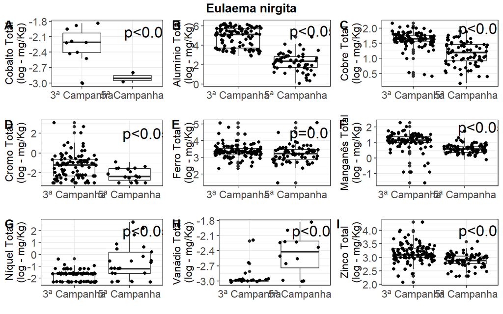

### 3.2. Eulaema cingulata

#### 3.2.1. Distância da lama

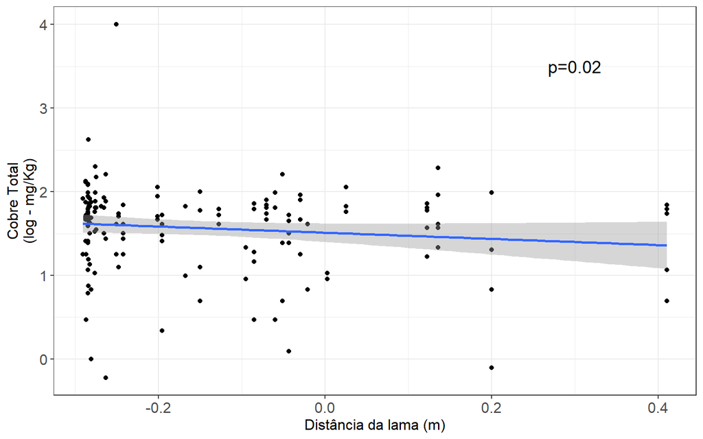

#### 3.2.1. Tipo de sitio

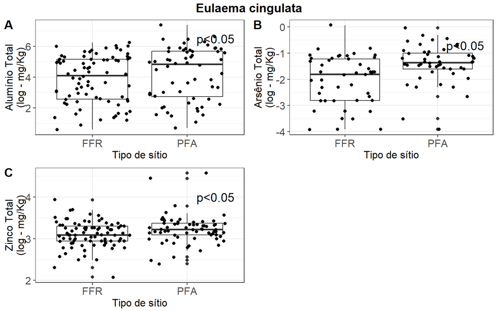

#### 3.2.3. Campanha

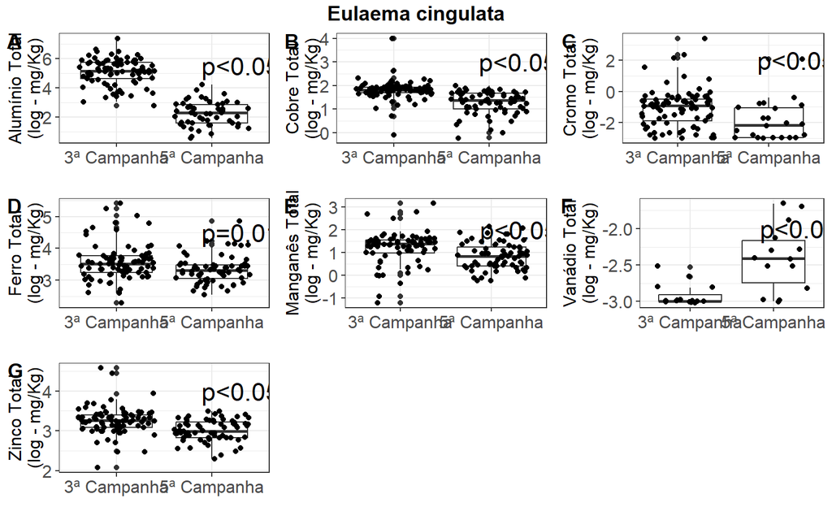

# Besouro

## Objetivo

- Apresentar os resultados obitidos da contaminação de metais em Besouros.

## Dados coletados

| campanha | id_amostra_ello | coluna1 | id_da_amostra_oceanus | sitio_amostral | transecto | data_de_coleta | especie | no_de_individuos_por_amostra | peso_g | data_de_envio | laboratorio_destino | observacao | unidade | aluminio_total | manganes_total | ferro_total | arsenio_total | zinco_total | cobre_total | cobalto_total | vanadio_total | niquel_total | cadmio_total | chumbo_total | cromo_total | x | desnivel_lama | distancia_lama | tipo_de_sitio |
| --- | --- | --- | --- | --- | --- | --- | --- | --- | --- | --- | --- | --- | --- | --- | --- | --- | --- | --- | --- | --- | --- | --- | --- | --- | --- | --- | --- | --- | --- |
| 5a Campanha | LB_BES_214 | 1 | 2796559 | PFA03 | T2 | 16/10/2023 | Dichotomius mormon | 2 | 2.136 | 22/03/2024 | Oceanus | NA | mg/Kg | 66.6 | 23.8 | 189.2 | 0.28 | 63 | 10.4 | NA | 0.27 | 0.1 | NA | NA | 1.15 | NA | NA | -0.2872033 | PFA |
| 5a Campanha | LB_BES_230 | 2 | 2796605 | PFA05 | T1 | 17/10/2023 | Dichotomius mormon | 5 | 5.419 | 22/03/2024 | Oceanus | NA | mg/Kg | 62.8 | 22.7 | 38 | 0.76 | 60 | 10.8 | NA | 0.33 | 0.1 | NA | NA | NA | NA | NA | -0.2823439 | PFA |
| 5a Campanha | LB_BES_239 | 3 | 2796591 | PFA06 | T2 | 21/10/2023 | Chalcocopris hesperus | 11 | 1.244 | 22/03/2024 | Oceanus | NA | mg/Kg | 117.7 | 23.8 | 120.8 | 0.8 | 76 | 8.5 | NA | NA | 0.1 | NA | NA | NA | NA | NA | -0.2689725 | PFA |
| 5a Campanha | LB_BES_242 | 4 | 2707184 | FFR33 | T1 | 24/10/2023 | Dichotomius mormon | 2 | 2.014 | 22/03/2024 | Oceanus | NA | mg/Kg | 350.1 | 29.1 | 263.4 | 0.29 | 62 | 10.5 | NA | 0.36 | 0.1 | NA | NA | NA | NA | NA | -0.0436645 | FFR |
| 5a Campanha | LB_BES_243 | 5 | 2796572 | PFA10 | T1 | 28/10/2023 | Chalcocopris hesperus | 21 | 1.936 | 22/03/2024 | Oceanus | NA | mg/Kg | 148.8 | 20 | 96.5 | 0.2 | 53 | 6.7 | NA | NA | NA | NA | NA | NA | NA | NA | -0.2843537 | PFA |
| 5a Campanha | LB_BES_244 | 6 | 2707244 | FFR34 | T1 | 28/10/2023 | Dichotomius mormon | 1 | 1.221 | 22/03/2024 | Oceanus | NA | mg/Kg | 75.1 | 29 | 108.1 | 0.05 | 58 | 8.5 | NA | 0.27 | 0.2 | NA | 0.11 | 0.35 | NA | NA | -0.0295974 | FFR |
| 5a Campanha | LB_BES_245 | 7 | 2707233 | PFA05 | T2 | 17/10/2023 | Dichotomius mormon | 2 | 2 | 22/03/2024 | Oceanus | NA | mg/Kg | 116.1 | 24 | 379.2 | 0.87 | 71 | 9.6 | NA | 0.45 | 0.3 | NA | NA | NA | NA | NA | -0.2823439 | PFA |
| 5a Campanha | LB_BES_266 | 8 | 2707257 | FFR27 | T2 | 13/10/2023 | Chalcocopris hesperus | 7 | 1.259 | 22/03/2024 | Oceanus | NA | mg/Kg | 78.9 | 29.1 | 83.8 | NA | 43 | 12.9 | NA | 0.19 | 0.2 | NA | NA | 0.3 | NA | NA | 0.2002250 | FFR |
| 5a Campanha | LB_BES_274 | 9 | 2796655 | PFA10 | T1 | 28/10/2023 | Dichotomius mormon | 3 | 2.41 | 22/03/2024 | Oceanus | NA | mg/Kg | 805.8 | 18.3 | 275.6 | 1.02 | 70 | 24.6 | NA | 0.56 | 0.1 | NA | NA | NA | NA | NA | -0.2843537 | PFA |
| 5a Campanha | LB_BES_276 | 10 | 2796666 | PFA10 | T2 | 28/10/2023 | Chalcocopris hesperus | 16 | 1.296 | 22/03/2024 | Oceanus | NA | mg/Kg | 13.2 | 27.7 | 54.3 | 19.94 | 66 | 6.1 | NA | 0.11 | NA | NA | 0.05 | NA | NA | NA | -0.2843537 | PFA |
| 5a Campanha | LB_BES_278 | 11 | 2796461 | FFR27 | T2 | 13/10/2023 | Chalcocopris hesperus | 8 | 1.436 | 22/03/2024 | Oceanus | NA | mg/Kg | 56.1 | 16.5 | 54.1 | 0.12 | 51 | 10.4 | NA | NA | NA | NA | NA | 0.28 | NA | NA | 0.2002250 | FFR |
| 5a Campanha | LB_BES_279 | 12 | 2796564 | FFR37 | T2 | 29/10/2023 | Dichotomius mormon | 3 | 3.258 | 22/03/2024 | Oceanus | NA | mg/Kg | 338.4 | 12.9 | 126.6 | 0.56 | 69 | 23.9 | NA | 0.31 | NA | NA | NA | NA | NA | NA | 0.1227450 | FFR |
| 5a Campanha | LB_BES_281 | 13 | 2707227 | FFR28 | T2 | 13/10/2023 | Chalcocopris hesperus | 8 | 1.472 | 22/03/2024 | Oceanus | NA | mg/Kg | 157.1 | 29.4 | 575 | 17.94 | 64 | 7.3 | 0.05 | 0.34 | 0.1 | NA | NA | 0.22 | NA | NA | 0.4105717 | FFR |
| 5a Campanha | LB_BES_287 | 14 | 2707210 | FFR34 | T2 | 28/10/2023 | Dichotomius mormon | 3 | 2.761 | 22/03/2024 | Oceanus | NA | mg/Kg | 40.7 | 20.3 | 63.7 | NA | 61 | 7.3 | NA | NA | NA | NA | NA | 0.8 | NA | NA | -0.0295974 | FFR |
| 5a Campanha | LB_BES_311 | 15 | 2707212 | PFA10 | T1 | 28/10/2023 | Chalcocopris hesperus | 22 | 1.893 | 22/03/2024 | Oceanus | NA | mg/Kg | 18.5 | 30.1 | 54.3 | 2.39 | 86 | 4.7 | NA | NA | NA | NA | 0.11 | NA | NA | NA | -0.2843537 | PFA |
| 5a Campanha | LB_BES_312 | 16 | 2796744 | PFA10 | T1 | 28/10/2023 | Chalcocopris hesperus | 12 | 1.065 | 22/03/2024 | Oceanus | NA | mg/Kg | 83.7 | 36.9 | 578 | 1.05 | 53 | 12.6 | NA | 0.29 | 0.3 | NA | 0.05 | NA | NA | NA | -0.2843537 | PFA |
| 5a Campanha | LB_BES_313 | 17 | 2707228 | PFA07 | T1 | 25/10/2023 | Dichotomius mormon | 2 | 1.888 | 22/03/2024 | Oceanus | NA | mg/Kg | 104.3 | 47.9 | 101.1 | 0.6 | 89 | 11.3 | NA | 0.29 | NA | NA | NA | NA | NA | NA | -0.2807386 | PFA |
| 5a Campanha | LB_BES_319 | 18 | 2707269 | PFA05 | T1 | 17/10/2023 | Dichotomius mormon | 2 | 1.201 | 22/03/2024 | Oceanus | NA | mg/Kg | 85.6 | 19.8 | 54.6 | 0.63 | 49 | 5.9 | NA | 0.3 | NA | NA | 0.09 | NA | NA | NA | -0.2823439 | PFA |
| 5a Campanha | LB_BES_323 | 19 | 2707181 | PFA07 | T1 | 25/10/2023 | Dichotomius mormon | 1 | 1.068 | 22/03/2024 | Oceanus | NA | mg/Kg | 623.6 | 12.2 | 187.2 | 0.33 | 65 | 20.1 | NA | 0.27 | NA | NA | 0.08 | NA | NA | NA | -0.2807386 | PFA |
| 5a Campanha | LB_BES_328 | 20 | 2707226 | PFA10 | T1 | 28/10/2023 | Chalcocopris hesperus | 18 | 1.878 | 22/03/2024 | Oceanus | NA | mg/Kg | 118.3 | 17.4 | 224 | 3.77 | 75 | 9.4 | NA | 0.42 | 0.3 | NA | NA | NA | NA | NA | -0.2843537 | PFA |
| 5a Campanha | LB_BES_329 | 21 | 2707239 | FFR33 | T2 | 24/10/2023 | Dichotomius mormon | 1 | 1.547 | 22/03/2024 | Oceanus | NA | mg/Kg | 46.6 | 24 | 177.9 | 1.86 | 68 | 7.6 | NA | 0.33 | 0.1 | NA | NA | NA | NA | NA | -0.0436645 | FFR |
| 5a Campanha | LB_BES_331 | 22 | 2707232 | FFR28 | T1 | 13/10/2023 | Dichotomius mormon | 1 | 1.237 | 22/03/2024 | Oceanus | NA | mg/Kg | 83.6 | 18.1 | 61.1 | 0.3 | 42 | 3.8 | NA | 0.33 | 0.1 | NA | NA | NA | NA | NA | 0.4105717 | FFR |
| 5a Campanha | LB_BES_346 | 23 | 2796751 | PFA07 | T1 | 25/10/2023 | Dichotomius mormon | 1 | 1.322 | 22/03/2024 | Oceanus | NA | mg/Kg | 125.2 | 13.3 | 75.1 | 0.39 | 59 | 12.4 | NA | 0.08 | 0.1 | NA | 0.31 | NA | NA | NA | -0.2807386 | PFA |
| 5a Campanha | LB_BES_354 | 24 | 2707217 | FFR28 | T1 | 13/10/2023 | Dichotomius mormon | 1 | 1 | 22/03/2024 | Oceanus | NA | mg/Kg | 40.7 | 11.7 | 25.9 | 0.94 | 46 | 8.1 | NA | 0.23 | 0.1 | NA | NA | NA | NA | NA | 0.4105717 | FFR |
| 5a Campanha | LB_BES_361 | 25 | 2796466 | PFA07 | T2 | 25/10/2023 | Dichotomius mormon | 1 | 1.114 | 22/03/2024 | Oceanus | NA | mg/Kg | 64.6 | 16.4 | 283.9 | 0.99 | 81 | 11.3 | NA | 0.7 | 0.4 | NA | 0.09 | 0.06 | NA | NA | -0.2807386 | PFA |
| 5a Campanha | LB_BES_368 | 26 | 2796583 | PFA06 | T2 | 21/10/2023 | Chalcocopris hesperus | 8 | 1.222 | 22/03/2024 | Oceanus | NA | mg/Kg | 107.3 | 24.4 | 90.4 | NA | 53 | 10.6 | NA | NA | 0.1 | NA | NA | NA | NA | NA | -0.2689725 | PFA |
| 5a Campanha | LB_BES_370 | 27 | 2796512 | FFR37 | T1 | 29/10/2023 | Chalcocopris hesperus | 18 | 1.52 | 22/03/2024 | Oceanus | NA | mg/Kg | 100.4 | 18.1 | 82 | 0.17 | 48 | 9.1 | NA | 0.12 | NA | NA | 0.37 | 1.73 | NA | NA | 0.1227450 | FFR |
| 5a Campanha | LB_BES_374 | 28 | 2796615 | FFR37 | T1 | 29/10/2023 | Dichotomius mormon | 3 | 3.388 | 22/03/2024 | Oceanus | NA | mg/Kg | 235.4 | 19.4 | 205.3 | NA | 62 | 11.2 | NA | 0.42 | 0.2 | NA | 0.29 | 0.49 | NA | NA | 0.1227450 | FFR |
| 5a Campanha | LB_BES_390 | 29 | 2707285 | FFR37 | T2 | 29/10/2023 | Dichotomius mormon | 7 | 8.413 | 22/03/2024 | Oceanus | NA | mg/Kg | 581.5 | 16.9 | 456.5 | 0.82 | 71 | 16.2 | NA | 1.06 | 0.2 | NA | 0.29 | 0.11 | NA | NA | 0.1227450 | FFR |
| 5a Campanha | LB_BES_406 | 30 | 2796628 | PFA06 | T2 | 21/10/2023 | Chalcocopris hesperus | 9 | 1.058 | 22/03/2024 | Oceanus | NA | mg/Kg | 347.7 | 24.3 | 193.3 | 0.79 | 114 | 13.6 | NA | 0.31 | 0.2 | NA | NA | NA | NA | NA | -0.2689725 | PFA |

[output cut: 233 more lines]

## Tabela de contaminantes

| campanha | tipo_de_sitio | especie | N_amostrado | Aluminio_mean | Aluminio_sd | Aluminio_n | Arsenio_mean | Arsenio_sd | Arsenio_n | Cadmio_mean | Cadmio_sd | Cadmio_n | Chumbo_mean | Chumbo_sd | Chumbo_n | cobalto_mean | cobalto_sd | cobalto_n | Cobre_mean | Cobre_sd | Cobre_n | Cromo_mean | Cromo_sd | Cromo_n | Ferro_mean | Ferro_sd | Ferro_n | Manganes_mean | Manganes_sd | … |
| --- | --- | --- | --- | --- | --- | --- | --- | --- | --- | --- | --- | --- | --- | --- | --- | --- | --- | --- | --- | --- | --- | --- | --- | --- | --- | --- | --- | --- | --- | --- |
| 3a Campanha | FFR | Chalcocopris hesperus | 32 | 421.2063 | 498.699859 | 32 | 3.0646875 | 9.3582436 | 27 | 0.0700000 | 0.0282843 | 2 | 0.4172727 | 0.4028492 | 20 | 0.0892308 | 0.0471631 | 8 | 7.231250 | 2.610826 | 27 | 1.3000000 | 2.8504344 | 17 | 106.88438 | 87.575174 | 32 | 10.33125 | 6.723020 | … |
| 3a Campanha | FFR | Dichotomius mormon | 18 | 405.5611 | 179.932230 | 18 | 0.1966667 | 0.1663759 | 14 | 0.0500000 | 0.0000000 | 1 | 0.7050000 | 0.2938416 | 6 | 0.0910000 | 0.0255821 | 5 | 7.755556 | 2.538231 | 17 | 0.7357143 | 0.8907648 | 6 | 52.69444 | 34.026762 | 18 | 18.83889 | 7.060090 | … |
| 3a Campanha | FFR | Dichotomius mormon | 8 | 214.9625 | 41.344267 | 8 | 1.9442857 | 4.6775950 | 6 | NaN | NA | 0 | 0.1850000 | 0.1378042 | 5 | 0.3950000 | 0.4879037 | 2 | 8.075000 | 2.097447 | 8 | 0.6087500 | 0.3411090 | 8 | 84.68750 | 53.280509 | 8 | 23.48750 | 5.445165 | … |
| 3a Campanha | FFR | Onthophagus haematopus | 18 | 1908.1167 | 5398.571556 | 18 | 67.5194444 | 273.7297932 | 17 | 1.3933333 | 2.2319125 | 3 | 2.8323077 | 8.7380863 | 13 | 0.0728571 | 0.0287021 | 3 | 8.611111 | 3.547143 | 17 | 2.1614286 | 4.3322988 | 14 | 206.01111 | 277.258484 | 18 | 69.30000 | 242.925859 | … |
| 3a Campanha | PFA | Chalcocopris hesperus | 25 | 397.2769 | 365.906641 | 26 | 0.4686957 | 0.4590435 | 19 | 0.0500000 | NA | 1 | 0.3755000 | 0.3140479 | 18 | 0.1140000 | 0.0392145 | 7 | 6.900000 | 2.334095 | 22 | 0.9700000 | 2.1352427 | 13 | 147.48462 | 199.174419 | 26 | 10.44000 | 6.306941 | … |
| 3a Campanha | PFA | Dichotomius mormon | 16 | 285.6313 | 149.664138 | 16 | 0.2836364 | 0.4252828 | 11 | NaN | NA | 0 | 0.1966667 | 0.2356551 | 10 | 0.0816667 | 0.0371035 | 5 | 8.193333 | 2.163155 | 13 | 0.5554545 | 0.2302765 | 11 | 62.07333 | 29.649054 | 14 | 19.01250 | 7.276709 | … |
| 3a Campanha | PFA | Dichotomius mormon | 2 | 257.7500 | 9.263099 | 2 | 1.6450000 | 0.1767767 | 2 | NaN | NA | 0 | 0.1350000 | 0.0636396 | 2 | NaN | NA | 0 | 6.650000 | 1.909188 | 2 | 0.4500000 | 0.0141421 | 2 | 175.15000 | 7.848885 | 2 | 25.90000 | 7.353910 | … |
| 3a Campanha | PFA | Onthophagus haematopus | 14 | 681.9714 | 954.377007 | 14 | 19.2350000 | 52.2955311 | 12 | 0.2766667 | 0.2874601 | 3 | 0.4257143 | 0.7658250 | 11 | 0.0750000 | 0.0353553 | 2 | 9.314286 | 3.595693 | 13 | 0.6557143 | 0.5523198 | 13 | 218.15000 | 182.752143 | 14 | 29.15714 | 42.064250 | … |
| 5a Campanha | FFR | Chalcocopris hesperus | 23 | 152.2435 | 109.395337 | 23 | 8.2253846 | 14.3676301 | 13 | 0.1200000 | 0.0714143 | 4 | 0.4038889 | 0.3470402 | 17 | 0.0500000 | NA | 1 | 10.560870 | 3.121733 | 23 | 0.4453846 | 0.5247954 | 13 | 179.84348 | 127.623163 | 23 | 20.01304 | 10.109640 | … |
| 5a Campanha | FFR | Dichotomius mormon | 28 | 178.7286 | 198.595069 | 27 | 0.6327778 | 0.5608167 | 16 | 0.0500000 | NA | 1 | 0.2016667 | 0.1184831 | 12 | NaN | NA | 0 | 9.410714 | 4.051094 | 24 | 0.3095000 | 0.1909112 | 18 | 141.88929 | 121.362458 | 28 | 22.85357 | 6.936510 | … |
| 5a Campanha | FFR | Onthophagus haematopus | 2 | 387.7500 | 57.346360 | 2 | 0.7150000 | 0.5303301 | 2 | 0.0500000 | NA | 1 | 0.3200000 | 0.1272792 | 2 | NaN | NA | 0 | 12.250000 | 1.626346 | 2 | 0.1500000 | 0.0707107 | 2 | 206.05000 | 2.474874 | 2 | 16.45000 | 2.333452 | … |
| 5a Campanha | PFA | Chalcocopris hesperus | 38 | 161.8789 | 120.457551 | 38 | 1.7842105 | 4.4894931 | 19 | 0.0712500 | 0.0313676 | 4 | 0.4962963 | 0.5354735 | 24 | NaN | NA | 0 | 10.842105 | 4.545662 | 32 | 0.2000000 | 0.1594574 | 13 | 179.39474 | 129.976817 | 36 | 18.63947 | 7.932708 | … |
| 5a Campanha | PFA | Dichotomius mormon | 30 | 169.2967 | 184.633528 | 30 | 0.6223810 | 0.3706738 | 20 | 0.0600000 | 0.0141421 | 2 | 0.2386364 | 0.1748277 | 19 | 0.0900000 | NA | 1 | 10.170000 | 4.632877 | 27 | 0.2783333 | 0.3531247 | 15 | 161.23667 | 149.978041 | 30 | 24.98667 | 10.362590 | … |
| 5a Campanha | PFA | Onthophagus haemathopus | 4 | 127.8250 | 56.091020 | 4 | 0.4300000 | NA | 1 | 0.0500000 | NA | 1 | 0.4400000 | 0.2307957 | 4 | NaN | NA | 0 | 12.425000 | 1.297112 | 4 | 0.1166667 | 0.0635085 | 2 | 143.82500 | 19.427536 | 4 | 24.35000 | 1.690168 | … |
| 5a Campanha | PFA | Onthophagus haematopus | 4 | 242.1500 | 166.294007 | 4 | 0.4400000 | 0.1322876 | 3 | NaN | NA | 0 | 0.1400000 | 0.0400000 | 3 | NaN | NA | 0 | 15.425000 | 4.704873 | 4 | 0.1766667 | 0.0907377 | 3 | 178.70000 | 110.151260 | 4 | 23.47500 | 7.232969 | … |

- Somente sitios

  | tipo_de_sitio | especie | N_amostrado | Aluminio_mean | Aluminio_sd | Aluminio_n | Arsenio_mean | Arsenio_sd | Arsenio_n | Cadmio_mean | Cadmio_sd | Cadmio_n | Chumbo_mean | Chumbo_sd | Chumbo_n | cobalto_mean | cobalto_sd | cobalto_n | Cobre_mean | Cobre_sd | Cobre_n | Cromo_mean | Cromo_sd | Cromo_n | Ferro_mean | Ferro_sd | Ferro_n | Manganes_mean | Manganes_sd | Manganes_n | … |
  | --- | --- | --- | --- | --- | --- | --- | --- | --- | --- | --- | --- | --- | --- | --- | --- | --- | --- | --- | --- | --- | --- | --- | --- | --- | --- | --- | --- | --- | --- | --- |
  | FFR | Chalcocopris hesperus | 55 | 308.7309 | 406.909837 | 55 | 4.5555556 | 11.1173792 | 35 | 0.1057143 | 0.0642540 | 5 | 0.4112500 | 0.3740711 | 32 | 0.0864286 | 0.0465101 | 8 | 8.623636 | 3.260480 | 46 | 0.9416129 | 2.2131623 | 30 | 137.3945 | 111.164905 | 52 | 14.38000 | 9.529727 | 49 | … |
  | FFR | Dichotomius mormon | 46 | 267.4891 | 220.051069 | 45 | 0.4345455 | 0.4773108 | 29 | 0.0500000 | 0.0000000 | 1 | 0.3565385 | 0.2997458 | 18 | 0.0910000 | 0.0255821 | 5 | 8.763044 | 3.598293 | 39 | 0.4200000 | 0.4959529 | 22 | 106.9870 | 105.885558 | 46 | 21.28261 | 7.184963 | 41 | … |
  | FFR | Dichotomius mormon | 8 | 214.9625 | 41.344267 | 8 | 1.9442857 | 4.6775950 | 6 | NaN | NA | 0 | 0.1850000 | 0.1378042 | 5 | 0.3950000 | 0.4879037 | 2 | 8.075000 | 2.097447 | 8 | 0.6087500 | 0.3411090 | 8 | 84.6875 | 53.280509 | 8 | 23.48750 | 5.445165 | 8 | … |
  | FFR | Onthophagus haematopus | 20 | 1756.0800 | 5127.951205 | 20 | 60.8390000 | 259.7376588 | 19 | 1.0575000 | 1.9421873 | 4 | 2.4973333 | 8.1381215 | 15 | 0.0728571 | 0.0287021 | 3 | 8.975000 | 3.556887 | 19 | 1.9100000 | 4.0912899 | 16 | 206.0150 | 262.260885 | 20 | 64.01500 | 230.360542 | 20 | … |
  | PFA | Chalcocopris hesperus | 63 | 257.5094 | 274.280834 | 63 | 1.0638095 | 3.0661090 | 35 | 0.0688889 | 0.0301846 | 4 | 0.4448936 | 0.4543647 | 39 | 0.1140000 | 0.0392145 | 7 | 9.240625 | 4.255033 | 48 | 0.5593333 | 1.4864768 | 21 | 166.4313 | 160.977054 | 62 | 15.38571 | 8.324853 | 57 | … |
  | PFA | Dichotomius mormon | 46 | 209.7609 | 180.481366 | 46 | 0.5059375 | 0.4167838 | 30 | 0.0600000 | 0.0141421 | 2 | 0.2238235 | 0.1958975 | 26 | 0.0828571 | 0.0340168 | 5 | 9.511111 | 4.064884 | 36 | 0.3834483 | 0.3367097 | 25 | 128.1822 | 131.680533 | 44 | 22.90870 | 9.753400 | 45 | … |
  | PFA | Dichotomius mormon | 2 | 257.7500 | 9.263099 | 2 | 1.6450000 | 0.1767767 | 2 | NaN | NA | 0 | 0.1350000 | 0.0636396 | 2 | NaN | NA | 0 | 6.650000 | 1.909188 | 2 | 0.4500000 | 0.0141421 | 2 | 175.1500 | 7.848885 | 2 | 25.90000 | 7.353910 | 2 | … |
  | PFA | Onthophagus haemathopus | 4 | 127.8250 | 56.091020 | 4 | 0.4300000 | NA | 1 | 0.0500000 | NA | 1 | 0.4400000 | 0.2307957 | 4 | NaN | NA | 0 | 12.425000 | 1.297112 | 4 | 0.1166667 | 0.0635085 | 2 | 143.8250 | 19.427536 | 4 | 24.35000 | 1.690168 | 4 | … |
  | PFA | Onthophagus haematopus | 18 | 584.2333 | 858.372076 | 18 | 15.4760000 | 47.0037143 | 15 | 0.2766667 | 0.2874601 | 3 | 0.3752941 | 0.6995187 | 13 | 0.0750000 | 0.0353553 | 2 | 10.672222 | 4.541677 | 17 | 0.5711765 | 0.5332200 | 15 | 209.3833 | 167.230068 | 18 | 27.89444 | 36.989354 | 18 | … |

## **1. Contaminação *Dichotomius mormon***

| campanha | id_amostra_ello | coluna1 | id_da_amostra_oceanus | sitio_amostral | transecto | data_de_coleta | especie | no_de_individuos_por_amostra | peso_g | data_de_envio | laboratorio_destino | observacao | unidade | aluminio_total | manganes_total | ferro_total | arsenio_total | zinco_total | cobre_total | cobalto_total | vanadio_total | niquel_total | cadmio_total | chumbo_total | cromo_total | x | desnivel_lama | distancia_lama | tipo_de_sitio |
| --- | --- | --- | --- | --- | --- | --- | --- | --- | --- | --- | --- | --- | --- | --- | --- | --- | --- | --- | --- | --- | --- | --- | --- | --- | --- | --- | --- | --- | --- |
| 5a Campanha | LB_BES_214 | 1 | 2796559 | PFA03 | T2 | 16/10/2023 | Dichotomius mormon | 2 | 2.136 | 22/03/2024 | Oceanus | NA | mg/Kg | 66.6 | 23.8 | 189.2 | 0.28 | 63 | 10.4 | NA | 0.27 | 0.1 | NA | NA | 1.15 | NA | NA | -0.2872033 | PFA |
| 5a Campanha | LB_BES_230 | 2 | 2796605 | PFA05 | T1 | 17/10/2023 | Dichotomius mormon | 5 | 5.419 | 22/03/2024 | Oceanus | NA | mg/Kg | 62.8 | 22.7 | 38 | 0.76 | 60 | 10.8 | NA | 0.33 | 0.1 | NA | NA | NA | NA | NA | -0.2823439 | PFA |
| 5a Campanha | LB_BES_242 | 4 | 2707184 | FFR33 | T1 | 24/10/2023 | Dichotomius mormon | 2 | 2.014 | 22/03/2024 | Oceanus | NA | mg/Kg | 350.1 | 29.1 | 263.4 | 0.29 | 62 | 10.5 | NA | 0.36 | 0.1 | NA | NA | NA | NA | NA | -0.0436645 | FFR |
| 5a Campanha | LB_BES_244 | 6 | 2707244 | FFR34 | T1 | 28/10/2023 | Dichotomius mormon | 1 | 1.221 | 22/03/2024 | Oceanus | NA | mg/Kg | 75.1 | 29 | 108.1 | 0.05 | 58 | 8.5 | NA | 0.27 | 0.2 | NA | 0.11 | 0.35 | NA | NA | -0.0295974 | FFR |
| 5a Campanha | LB_BES_245 | 7 | 2707233 | PFA05 | T2 | 17/10/2023 | Dichotomius mormon | 2 | 2 | 22/03/2024 | Oceanus | NA | mg/Kg | 116.1 | 24 | 379.2 | 0.87 | 71 | 9.6 | NA | 0.45 | 0.3 | NA | NA | NA | NA | NA | -0.2823439 | PFA |
| 5a Campanha | LB_BES_274 | 9 | 2796655 | PFA10 | T1 | 28/10/2023 | Dichotomius mormon | 3 | 2.41 | 22/03/2024 | Oceanus | NA | mg/Kg | 805.8 | 18.3 | 275.6 | 1.02 | 70 | 24.6 | NA | 0.56 | 0.1 | NA | NA | NA | NA | NA | -0.2843537 | PFA |
| 5a Campanha | LB_BES_279 | 12 | 2796564 | FFR37 | T2 | 29/10/2023 | Dichotomius mormon | 3 | 3.258 | 22/03/2024 | Oceanus | NA | mg/Kg | 338.4 | 12.9 | 126.6 | 0.56 | 69 | 23.9 | NA | 0.31 | NA | NA | NA | NA | NA | NA | 0.1227450 | FFR |
| 5a Campanha | LB_BES_287 | 14 | 2707210 | FFR34 | T2 | 28/10/2023 | Dichotomius mormon | 3 | 2.761 | 22/03/2024 | Oceanus | NA | mg/Kg | 40.7 | 20.3 | 63.7 | NA | 61 | 7.3 | NA | NA | NA | NA | NA | 0.8 | NA | NA | -0.0295974 | FFR |
| 5a Campanha | LB_BES_313 | 17 | 2707228 | PFA07 | T1 | 25/10/2023 | Dichotomius mormon | 2 | 1.888 | 22/03/2024 | Oceanus | NA | mg/Kg | 104.3 | 47.9 | 101.1 | 0.6 | 89 | 11.3 | NA | 0.29 | NA | NA | NA | NA | NA | NA | -0.2807386 | PFA |
| 5a Campanha | LB_BES_319 | 18 | 2707269 | PFA05 | T1 | 17/10/2023 | Dichotomius mormon | 2 | 1.201 | 22/03/2024 | Oceanus | NA | mg/Kg | 85.6 | 19.8 | 54.6 | 0.63 | 49 | 5.9 | NA | 0.3 | NA | NA | 0.09 | NA | NA | NA | -0.2823439 | PFA |
| 5a Campanha | LB_BES_323 | 19 | 2707181 | PFA07 | T1 | 25/10/2023 | Dichotomius mormon | 1 | 1.068 | 22/03/2024 | Oceanus | NA | mg/Kg | 623.6 | 12.2 | 187.2 | 0.33 | 65 | 20.1 | NA | 0.27 | NA | NA | 0.08 | NA | NA | NA | -0.2807386 | PFA |
| 5a Campanha | LB_BES_329 | 21 | 2707239 | FFR33 | T2 | 24/10/2023 | Dichotomius mormon | 1 | 1.547 | 22/03/2024 | Oceanus | NA | mg/Kg | 46.6 | 24 | 177.9 | 1.86 | 68 | 7.6 | NA | 0.33 | 0.1 | NA | NA | NA | NA | NA | -0.0436645 | FFR |
| 5a Campanha | LB_BES_331 | 22 | 2707232 | FFR28 | T1 | 13/10/2023 | Dichotomius mormon | 1 | 1.237 | 22/03/2024 | Oceanus | NA | mg/Kg | 83.6 | 18.1 | 61.1 | 0.3 | 42 | 3.8 | NA | 0.33 | 0.1 | NA | NA | NA | NA | NA | 0.4105717 | FFR |
| 5a Campanha | LB_BES_346 | 23 | 2796751 | PFA07 | T1 | 25/10/2023 | Dichotomius mormon | 1 | 1.322 | 22/03/2024 | Oceanus | NA | mg/Kg | 125.2 | 13.3 | 75.1 | 0.39 | 59 | 12.4 | NA | 0.08 | 0.1 | NA | 0.31 | NA | NA | NA | -0.2807386 | PFA |
| 5a Campanha | LB_BES_354 | 24 | 2707217 | FFR28 | T1 | 13/10/2023 | Dichotomius mormon | 1 | 1 | 22/03/2024 | Oceanus | NA | mg/Kg | 40.7 | 11.7 | 25.9 | 0.94 | 46 | 8.1 | NA | 0.23 | 0.1 | NA | NA | NA | NA | NA | 0.4105717 | FFR |
| 5a Campanha | LB_BES_361 | 25 | 2796466 | PFA07 | T2 | 25/10/2023 | Dichotomius mormon | 1 | 1.114 | 22/03/2024 | Oceanus | NA | mg/Kg | 64.6 | 16.4 | 283.9 | 0.99 | 81 | 11.3 | NA | 0.7 | 0.4 | NA | 0.09 | 0.06 | NA | NA | -0.2807386 | PFA |
| 5a Campanha | LB_BES_374 | 28 | 2796615 | FFR37 | T1 | 29/10/2023 | Dichotomius mormon | 3 | 3.388 | 22/03/2024 | Oceanus | NA | mg/Kg | 235.4 | 19.4 | 205.3 | NA | 62 | 11.2 | NA | 0.42 | 0.2 | NA | 0.29 | 0.49 | NA | NA | 0.1227450 | FFR |
| 5a Campanha | LB_BES_390 | 29 | 2707285 | FFR37 | T2 | 29/10/2023 | Dichotomius mormon | 7 | 8.413 | 22/03/2024 | Oceanus | NA | mg/Kg | 581.5 | 16.9 | 456.5 | 0.82 | 71 | 16.2 | NA | 1.06 | 0.2 | NA | 0.29 | 0.11 | NA | NA | 0.1227450 | FFR |
| 5a Campanha | LB_BES_407 | 31 | 2707187 | PFA10 | T2 | 28/10/2023 | Dichotomius mormon | 1 | 1 | 22/03/2024 | Oceanus | NA | mg/Kg | 26.5 | 31.7 | 72.2 | 1.14 | 43 | 10 | NA | NA | 0.1 | NA | 0.05 | NA | NA | NA | -0.2843537 | PFA |
| 5a Campanha | LB_BES_419 | 32 | 2707200 | FFR32 | T2 | 20/10/2023 | Dichotomius mormon | 2 | 2.375 | 22/03/2024 | Oceanus | NA | mg/Kg | 66.2 | 24.9 | 129.4 | 1.99 | 63 | 8 | NA | 0.28 | NA | NA | NA | 0.39 | NA | NA | 0.0027233 | FFR |
| 5a Campanha | LB_BES_423 | 33 | 2707224 | PFA07 | T2 | 25/10/2023 | Dichotomius mormon | 2 | 2.216 | 22/03/2024 | Oceanus | NA | mg/Kg | 370.5 | 16.1 | 336.1 | 1.07 | 59 | 14.5 | NA | 0.21 | 0.1 | NA | NA | 1.23 | NA | NA | -0.2807386 | PFA |
| 5a Campanha | LB_BES_431 | 35 | 2707199 | FFR37 | T1 | 29/10/2023 | Dichotomius mormon | 2 | 2.631 | 22/03/2024 | Oceanus | NA | mg/Kg | 65.6 | 20.6 | 180.4 | 1.31 | 73 | 9.7 | NA | 0.39 | 0.2 | NA | NA | 0.2 | NA | NA | 0.1227450 | FFR |
| 5a Campanha | LB_BES_434 | 36 | 2796606 | PFA08 | T1 | 25/10/2023 | Dichotomius mormon | 3 | 3.124 | 22/03/2024 | Oceanus | NA | mg/Kg | 81.9 | 10.1 | 105.7 | 0.29 | 44 | 8.4 | NA | 0.08 | 0.1 | NA | NA | NA | NA | NA | -0.2838412 | PFA |
| 5a Campanha | LB_BES_438 | 37 | 2796746 | FFR37 | T1 | 29/10/2023 | Dichotomius mormon | 2 | 1.68 | 22/03/2024 | Oceanus | NA | mg/Kg | 153.3 | 19.7 | 87.5 | 0.31 | 63 | 11.4 | NA | 0.2 | 0.2 | NA | 0.28 | NA | NA | NA | 0.1227450 | FFR |
| 5a Campanha | LB_BES_452 | 39 | 2707194 | FFR34 | T2 | 28/10/2023 | Dichotomius mormon | 1 | 1.121 | 22/03/2024 | Oceanus | NA | mg/Kg | 188 | 32.2 | 79.8 | 0.29 | 85 | 13.3 | NA | 0.35 | 0.1 | NA | 0.05 | 0.18 | NA | NA | -0.0295974 | FFR |
| 5a Campanha | LB_BES_454 | 40 | 2796484 | FFR34 | T2 | 28/10/2023 | Dichotomius mormon | 2 | 2.054 | 22/03/2024 | Oceanus | NA | mg/Kg | 233.4 | 14 | 155.3 | 0.32 | 67 | 15.2 | NA | 0.24 | 0.3 | NA | 0.06 | 0.4 | NA | NA | -0.0295974 | FFR |
| 5a Campanha | LB_BES_471 | 42 | 2796471 | FFR31 | T2 | 13/10/2023 | Dichotomius mormon | 1 | 1.205 | 22/03/2024 | Oceanus | NA | mg/Kg | 119.5 | 23.4 | 76.5 | 0.7 | 51 | 10.2 | NA | 0.28 | NA | NA | NA | 0.05 | NA | NA | -0.0599219 | FFR |
| 5a Campanha | LB_BES_479 | 43 | 2796626 | FFR34 | T2 | 28/10/2023 | Dichotomius mormon | 2 | 2.243 | 22/03/2024 | Oceanus | NA | mg/Kg | 110.8 | 11.5 | 87.8 | 0.42 | 58 | 8.7 | NA | 0.16 | 0.1 | NA | 0.13 | 0.19 | NA | NA | -0.0295974 | FFR |
| 5a Campanha | LB_BES_495 | 49 | 2707289 | PFA03 | T1 | 16/10/2023 | Dichotomius mormon | 2 | 1.376 | 22/03/2024 | Oceanus | NA | mg/Kg | 330.7 | 18.9 | 748.1 | 0.53 | 87 | 13.3 | NA | 0.22 | 0.1 | NA | 0.2 | NA | NA | NA | -0.2872033 | PFA |
| 5a Campanha | LB_BES_502 | 56 | 2906448 | PFA 05 | T1 | 17/10/2023 | Dichotomius mormon | 2 | 1.318 | 05/04/2024 | Oceanus | NA | mg/Kg | 184.2 | 44.2 | 111.4 | 1.13 | 62 | 14.4 | NA | 0.15 | NA | 0.05 | NA | NA | NA | NA | NA | PFA |

[output cut: 62 more lines]

### 1.1. Aluminio

- Simplificação do modelo global

```
## Global model call: lme4::lmer(formula = aluminio_total ~ distancia_lama + tipo_de_sitio *
##     campanha + (1 | sitio_amostral), data = al, na.action = "na.fail")
## ---
## Model selection table
##    (Int) cmp dst_lam tip_de_sit cmp:tip_de_sit df   logLik  AICc delta weight
## 2  5.740   +                                    4 -105.284 219.0  0.00  0.440
## 4  5.774   +  0.2076                            5 -104.910 220.5  1.50  0.208
## 8  5.808   + -0.8496          +                 6 -104.152 221.3  2.28  0.141
## 6  5.842   +                  +                 5 -105.378 221.5  2.43  0.131
## 14 5.897   +                  +              +  6 -105.408 223.8  4.79  0.040
## 16 5.851   + -0.7900          +              +  7 -104.250 223.9  4.83  0.039
## 1  5.113                                        3 -120.080 246.4 27.40  0.000
## 7  5.220     -1.2080          +                 5 -118.207 247.1 28.09  0.000
## 3  5.146      0.2182                            4 -119.623 247.7 28.68  0.000
## 5  5.245                      +                 4 -119.866 248.2 29.16  0.000
## Models ranked by AICc(x)
## Random terms (all models):
##   1 | sitio_amostral
```

- Resultado do melhor modelo

```
## Analysis of Deviance Table (Type II Wald chisquare tests)
##
## Response: aluminio_total
##           Chisq Df Pr(>Chisq)
## campanha 38.399  1  5.765e-10 ***
## ---
## Signif. codes:  0 '***' 0.001 '**' 0.01 '*' 0.05 '.' 0.1 ' ' 1
```

[output not shown]

[output not shown]

### 1.2. Arsenio

- Simplificação do modelo global

```
## Global model call: lme4::lmer(formula = arsenio_total ~ campanha * tipo_de_sitio +
##     distancia_lama + (1 | sitio_amostral), data = metal, na.action = "na.fail")
## ---
## Model selection table
##     (Int) cmp dst_lam tip_de_sit cmp:tip_de_sit df  logLik  AICc delta weight
## 2  -1.858   +                                    4 -77.777 164.2  0.00  0.469
## 4  -1.844   + 0.08287                            5 -77.128 165.3  1.06  0.276
## 6  -1.857   +                  +                 5 -78.200 167.4  3.20  0.094
## 8  -1.849   + 0.19650          +                 6 -77.044 167.6  3.33  0.089
## 14 -1.922   +                  +              +  6 -77.903 169.3  5.05  0.038
## 16 -1.921   + 0.04474          +              +  7 -76.725 169.4  5.22  0.035
## 1  -1.213                                        3 -89.453 185.3 21.07  0.000
## 3  -1.169     0.28940                            4 -88.605 185.9 21.66  0.000
## 7  -1.252     1.34200          +                 5 -87.947 186.9 22.70  0.000
## 5  -1.269                      +                 4 -89.664 188.0 23.77  0.000
## Models ranked by AICc(x)
## Random terms (all models):
##   1 | sitio_amostral
```

- Resultado

```
## Analysis of Deviance Table (Type II Wald chisquare tests)
##
## Response: arsenio_total
##           Chisq Df Pr(>Chisq)
## campanha 29.909  1  4.528e-08 ***
## ---
## Signif. codes:  0 '***' 0.001 '**' 0.01 '*' 0.05 '.' 0.1 ' ' 1
```

| contrast | campanha | estimate | SE | df | t.ratio | p.value |
| --- | --- | --- | --- | --- | --- | --- |
| FFR - PFA | 3a Campanha | -0.1861572 | 0.4905351 | 33.30315 | -0.3794983 | 0.7067271 |
| FFR - PFA | 5a Campanha | 0.1313916 | 0.5024487 | 37.13498 | 0.2615026 | 0.7951500 |

| contrast | tipo_de_sitio | estimate | SE | df | t.ratio | p.value |
| --- | --- | --- | --- | --- | --- | --- |
| 3a Campanha - 5a Campanha | FFR | -1.2294305 | 0.2754753 | 46.96164 | -4.462943 | 0.0000504 |
| 3a Campanha - 5a Campanha | PFA | -0.9118817 | 0.3301537 | 58.92708 | -2.761991 | 0.0076498 |

### 1.3. Chumbo

- Simplificação do modelo global

```
## Global model call: lme4::lmer(formula = chumbo_total ~ distancia_lama + tipo_de_sitio *
##     campanha + (1 | sitio_amostral), data = metal, na.action = "na.fail")
## ---
## Model selection table
##      (Int) cmp dst_lam tip_de_sit cmp:tip_de_sit df  logLik  AICc delta weight
## 16 -0.5120   +  0.2561          +              +  7 -70.954 158.1  0.00  0.482
## 14 -0.5327   +                  +              +  6 -72.267 158.1  0.05  0.471
## 3  -1.4540      1.1300                            4 -78.390 165.5  7.42  0.012
## 7  -1.4580     -0.4298          +                 5 -77.635 166.4  8.30  0.008
## 1  -1.6670                                        3 -79.985 166.4  8.30  0.008
## 5  -1.4320                      +                 4 -79.070 166.9  8.78  0.006
## 4  -1.2240   +  1.2110                            5 -78.023 167.2  9.07  0.005
## 2  -1.4670   +                                    4 -79.733 168.2 10.10  0.003
## 8  -1.2360   + -0.2828          +                 6 -77.325 168.3 10.16  0.003
## 6  -1.2170   +                  +                 5 -78.737 168.6 10.50  0.003
## Models ranked by AICc(x)
## Random terms (all models):
##   1 | sitio_amostral
```

- Resultado do melhor modelo

```
## Analysis of Deviance Table (Type II Wald chisquare tests)
##
## Response: chumbo_total
##           Chisq Df Pr(>Chisq)
## campanha 1.4064  1     0.2357
```

| contrast | campanha | estimate | SE | df | t.ratio | p.value |
| --- | --- | --- | --- | --- | --- | --- |
| FFR - PFA | 3a Campanha | 1.5065537 | 0.4946340 | 35.98339 | 3.0457948 | 0.0043254 |
| FFR - PFA | 5a Campanha | -0.2118512 | 0.4445149 | 30.98223 | -0.4765896 | 0.6369986 |

| contrast | tipo_de_sitio | estimate | SE | df | t.ratio | p.value |
| --- | --- | --- | --- | --- | --- | --- |
| 3a Campanha - 5a Campanha | FFR | 1.3299306 | 0.3646703 | 51.74453 | 3.646940 | 0.0006166 |
| 3a Campanha - 5a Campanha | PFA | -0.3884743 | 0.3069435 | 51.57815 | -1.265621 | 0.2113360 |

### 1.4. Cadmio

```
## [1] "dados com baixa variabilidade."
```

|  | cadmio_total | tipo_de_sitio | sitio_amostral | campanha | distancia_lama |
| --- | --- | --- | --- | --- | --- |
| 31 | 0.05 | FFR | FFR32 | 5a Campanha | 0.0027233 |
| 41 | 0.07 | PFA | PFA02 | 5a Campanha | -0.2848703 |
| 61 | 0.05 | FFR | FFR37 | 3a Campanha | 0.1227450 |
| 78 | 0.05 | FFR | FFR32 | 3a Campanha | 0.0027233 |

### 1.5. Cobalto

- Simplificação do modelo global

```
## Global model call: lme4::lmer(formula = cobalto_total ~ distancia_lama + tipo_de_sitio *
##     campanha + (1 | sitio_amostral), data = metal, na.action = "na.fail")
## ---
## Model selection table
##     (Int) cmp  dst_lam tip_de_sit cmp:tip_de_sit df logLik AICc delta weight
## 1  -2.488                                         3 -7.004 21.9  0.00  0.587
## 3  -2.431      0.35030                            4 -6.346 24.0  2.17  0.198
## 2  -2.493   +                                     4 -7.082 25.5  3.64  0.095
## 5  -2.440                       +                 4 -7.624 26.6  4.73  0.055
## 4  -2.429   +  0.40740                            5 -6.339 28.1  6.28  0.025
## 7  -2.445     -0.05995          +                 5 -6.533 28.5  6.66  0.021
## 6  -2.440   +                   +                 5 -7.565 30.6  8.73  0.007
## 14 -2.440   +                   +              +  5 -7.565 30.6  8.73  0.007
## 8  -2.446   + -0.07618          +                 6 -6.444 33.3 11.43  0.002
## 16 -2.446   + -0.07618          +              +  6 -6.444 33.3 11.43  0.002
## Models ranked by AICc(x)
## Random terms (all models):
##   1 | sitio_amostral
```

- Resultado do melhor modelo

```
## Analysis of Deviance Table (Type II Wald chisquare tests)
##
## Response: as.numeric(cobalto_total)
##                 Chisq Df Pr(>Chisq)
## distancia_lama 0.2647  1     0.6069
```

| contrast | campanha | estimate | SE | df | t.ratio | p.value |
| --- | --- | --- | --- | --- | --- | --- |
| FFR - PFA | 3a Campanha | 0.1561154 | 0.3426104 | 10.39481 | 0.4556644 | 0.6580021 |
| FFR - PFA | 5a Campanha | NA | NA | NA | NA | NA |

| contrast | tipo_de_sitio | estimate | SE | df | t.ratio | p.value |
| --- | --- | --- | --- | --- | --- | --- |
| 3a Campanha - 5a Campanha | FFR | NA | NA | NA | NA | NA |
| 3a Campanha - 5a Campanha | PFA | -0.1730534 | 0.40783 | 12.58718 | -0.4243273 | 0.6784895 |

### 1.6. Cobre

- Simplificação do modelo global

```
## Global model call: lme4::lmer(formula = as.numeric(cobre_total) ~ distancia_lama +
##     tipo_de_sitio * campanha + (1 | sitio_amostral), data = metal,
##     na.action = "na.fail")
## ---
## Model selection table
##    (Int) cmp  dst_lam tip_de_sit cmp:tip_de_sit df  logLik  AICc delta weight
## 1  2.129                                         3 -45.038  96.4  0.00  0.460
## 2  2.017   +                                     4 -44.531  97.5  1.18  0.255
## 3  2.101     -0.16610                            4 -45.262  99.0  2.64  0.123
## 4  1.983   + -0.18820                            5 -44.698 100.1  3.76  0.070
## 5  2.097                       +                 4 -46.318 101.1  4.75  0.043
## 6  1.990   +                   +                 5 -45.879 102.5  6.12  0.022
## 7  2.094     -0.04118          +                 5 -46.217 103.2  6.80  0.015
## 8  1.980   + -0.16710          +                 6 -45.707 104.4  8.08  0.008
## 14 1.970   +                   +              +  6 -46.661 106.3  9.99  0.003
## 16 1.954   + -0.19790          +              +  7 -46.449 108.3 11.92  0.001
## Models ranked by AICc(x)
## Random terms (all models):
##   1 | sitio_amostral
```

- Resultado do melhor modelo

```
## Analysis of Deviance Table (Type II Wald chisquare tests)
##
## Response: as.numeric(cobre_total)
##           Chisq Df Pr(>Chisq)
## campanha 4.2124  1    0.04013 *
## ---
## Signif. codes:  0 '***' 0.001 '**' 0.01 '*' 0.05 '.' 0.1 ' ' 1
```

| contrast | campanha | estimate | SE | df | t.ratio | p.value |
| --- | --- | --- | --- | --- | --- | --- |
| FFR - PFA | 3a Campanha | -0.0520183 | 0.1785268 | 51.18838 | -0.2913752 | 0.7719419 |
| FFR - PFA | 5a Campanha | 0.0263345 | 0.1691047 | 48.44878 | 0.1557291 | 0.8768936 |

| contrast | tipo_de_sitio | estimate | SE | df | t.ratio | p.value |
| --- | --- | --- | --- | --- | --- | --- |
| 3a Campanha - 5a Campanha | FFR | -0.2152391 | 0.1209127 | 78.90241 | -1.780121 | 0.0789061 |
| 3a Campanha - 5a Campanha | PFA | -0.1368863 | 0.1262270 | 82.96342 | -1.084446 | 0.2813085 |

### 1.7. Cromo

- Simplificação do modelo global

```
## Global model call: lme4::lmer(formula = as.numeric(cromo_total) ~ distancia_lama +
##     tipo_de_sitio * campanha + (1 | sitio_amostral), data = metal,
##     na.action = "na.fail")
## ---
## Model selection table
##      (Int) cmp dst_lam tip_de_sit cmp:tip_de_sit df  logLik  AICc delta weight
## 2  -0.8985   +                                    4 -73.636 156.1  0.00  0.271
## 4  -0.8178   +  0.4143                            5 -72.483 156.2  0.12  0.256
## 16 -1.1400   +  0.7422          +              +  7 -70.585 157.6  1.48  0.129
## 8  -0.8163   +  0.8407          +                 6 -72.059 157.9  1.80  0.111
## 14 -1.1930   +                  +              +  6 -72.321 158.4  2.32  0.085
## 6  -0.8675   +                  +                 5 -73.855 158.9  2.86  0.065
## 1  -1.3950                                        3 -76.964 160.4  4.33  0.031
## 3  -1.3520      0.2459                            4 -75.846 160.5  4.42  0.030
## 7  -1.3520      0.7259          +                 5 -75.393 162.0  5.94  0.014
## 5  -1.3920                      +                 4 -77.186 163.2  7.10  0.008
## Models ranked by AICc(x)
## Random terms (all models):
##   1 | sitio_amostral
```

- Resultado do melhor modelo

```
## Analysis of Deviance Table (Type II Wald chisquare tests)
##
## Response: as.numeric(cromo_total)
##                 Chisq Df Pr(>Chisq)
## campanha       8.0781  1    0.00448 **
## distancia_lama 0.1191  1    0.73004
## ---
## Signif. codes:  0 '***' 0.001 '**' 0.01 '*' 0.05 '.' 0.1 ' ' 1
```

| contrast | campanha | estimate | SE | df | t.ratio | p.value |
| --- | --- | --- | --- | --- | --- | --- |
| FFR - PFA | 3a Campanha | -0.6794204 | 0.6769803 | 33.47306 | -1.0036044 | 0.3227696 |
| FFR - PFA | 5a Campanha | 0.1612082 | 0.6118615 | 26.32348 | 0.2634717 | 0.7942385 |

| contrast | tipo_de_sitio | estimate | SE | df | t.ratio | p.value |
| --- | --- | --- | --- | --- | --- | --- |
| 3a Campanha - 5a Campanha | FFR | 0.3018074 | 0.4044712 | 45.37467 | 0.7461778 | 0.4594087 |
| 3a Campanha - 5a Campanha | PFA | 1.1424360 | 0.3771321 | 49.07499 | 3.0292727 | 0.0039030 |

### 1.8. Ferro

- Simplificação do modelo global

```
## Global model call: lme4::lmer(formula = as.numeric(ferro_total) ~ distancia_lama +
##     tipo_de_sitio * campanha + (1 | sitio_amostral), data = metal,
##     na.action = "na.fail")
## ---
## Model selection table
##    (Int) cmp dst_lam tip_de_sit cmp:tip_de_sit df   logLik  AICc delta weight
## 4  3.782   + -0.7880                            5  -94.673 200.1  0.00  0.428
## 2  3.911   +                                    4  -96.035 200.5  0.48  0.337
## 8  3.790   + -1.0580          +                 6  -94.966 203.0  2.89  0.101
## 6  3.837   +                  +                 5  -96.477 203.7  3.61  0.070
## 16 3.693   + -1.1780          +              +  7  -94.736 204.9  4.79  0.039
## 14 3.762   +                  +              +  6  -96.412 205.8  5.78  0.024
## 3  4.293     -0.7233                            4 -105.847 220.2 20.10  0.000
## 1  4.409                                        3 -106.960 220.2 20.13  0.000
## 5  4.303                      +                 4 -107.122 222.7 22.65  0.000
## 7  4.282     -0.5794          +                 5 -106.062 222.8 22.78  0.000
## Models ranked by AICc(x)
## Random terms (all models):
##   1 | sitio_amostral
```

- Resultado do melhor modelo

```
## Analysis of Deviance Table (Type II Wald chisquare tests)
##
## Response: as.numeric(ferro_total)
##                  Chisq Df Pr(>Chisq)
## distancia_lama  1.5294  1     0.2162
## tipo_de_sitio   0.1500  1     0.6985
## campanha       27.5435  1  1.536e-07 ***
## ---
## Signif. codes:  0 '***' 0.001 '**' 0.01 '*' 0.05 '.' 0.1 ' ' 1
```

| contrast | campanha | estimate | SE | df | t.ratio | p.value |
| --- | --- | --- | --- | --- | --- | --- |
| FFR - PFA | 3a Campanha | 0.1075581 | 0.2806058 | 35.30393 | 0.3833067 | 0.7037909 |
| FFR - PFA | 5a Campanha | 0.1075581 | 0.2806058 | 35.30393 | 0.3833067 | 0.7037909 |

| contrast | tipo_de_sitio | estimate | SE | df | t.ratio | p.value |
| --- | --- | --- | --- | --- | --- | --- |
| 3a Campanha - 5a Campanha | FFR | -0.7942283 | 0.1533915 | 80.58299 | -5.177785 | 1.6e-06 |
| 3a Campanha - 5a Campanha | PFA | -0.7942283 | 0.1533915 | 80.58299 | -5.177785 | 1.6e-06 |

### 1.9. Manganes

- Simplificação do modelo global

```
## Global model call: lme4::lmer(formula = as.numeric(manganes_total) ~ distancia_lama +
##     tipo_de_sitio * campanha + (1 | sitio_amostral), data = metal,
##     na.action = "na.fail")
## ---
## Model selection table
##    (Int) cmp dst_lam tip_de_sit cmp:tip_de_sit df  logLik  AICc delta weight
## 2  2.853   +                                    4 -46.945 102.4  0.00  0.498
## 4  2.807   + -0.2915                            5 -46.739 104.2  1.83  0.199
## 1  3.004                                        3 -49.253 104.8  2.42  0.148
## 3  2.963     -0.2679                            4 -49.151 106.8  4.41  0.055
## 6  2.838   +                  +                 5 -48.428 107.6  5.21  0.037
## 8  2.817   + -0.5970          +                 6 -47.392 107.8  5.44  0.033
## 5  2.982                      +                 4 -50.651 109.8  7.41  0.012
## 7  2.973     -0.4499          +                 5 -50.030 110.8  8.41  0.007
## 14 2.848   +                  +              +  6 -49.240 111.5  9.13  0.005
## 16 2.820   + -0.5947          +              +  7 -48.223 111.8  9.45  0.004
## Models ranked by AICc(x)
## Random terms (all models):
##   1 | sitio_amostral
```

- Resultado do melhor modelo

```
## Analysis of Deviance Table (Type II Wald chisquare tests)
##
## Response: as.numeric(manganes_total)
##           Chisq Df Pr(>Chisq)
## campanha 7.9448  1   0.004823 **
## ---
## Signif. codes:  0 '***' 0.001 '**' 0.01 '*' 0.05 '.' 0.1 ' ' 1
```

| contrast | campanha | estimate | SE | df | t.ratio | p.value |
| --- | --- | --- | --- | --- | --- | --- |
| FFR - PFA | 3a Campanha | 0.1282692 | 0.1735593 | 52.39386 | 0.7390513 | 0.4631741 |
| FFR - PFA | 5a Campanha | 0.1204148 | 0.1667550 | 48.59205 | 0.7221058 | 0.4736903 |

| contrast | tipo_de_sitio | estimate | SE | df | t.ratio | p.value |
| --- | --- | --- | --- | --- | --- | --- |
| 3a Campanha - 5a Campanha | FFR | -0.2506722 | 0.1241466 | 81.44578 | -2.019163 | 0.0467598 |
| 3a Campanha - 5a Campanha | PFA | -0.2585266 | 0.1261340 | 84.79230 | -2.049619 | 0.0434919 |

### 1.10. Niquel

- Simplificação do modelo global

```
## Global model call: lme4::lmer(formula = as.numeric(niquel_total) ~ distancia_lama +
##     tipo_de_sitio * campanha + (1 | sitio_amostral), data = metal,
##     na.action = "na.fail")
## ---
## Model selection table
##     (Int) cmp  dst_lam tip_de_sit cmp:tip_de_sit df  logLik AICc delta weight
## 2  -1.516   +                                     4 -28.622 66.2  0.00  0.589
## 4  -1.530   + -0.06598                            5 -28.701 68.9  2.70  0.153
## 14 -1.936   +                   +              +  6 -27.763 69.7  3.49  0.103
## 6  -1.538   +                   +                 5 -29.664 70.9  4.62  0.058
## 16 -1.936   + -0.09376          +              +  7 -27.336 71.7  5.45  0.039
## 8  -1.538   + -0.01348          +                 6 -29.212 72.6  6.39  0.024
## 1  -1.879                                         3 -33.214 73.0  6.77  0.020
## 3  -1.931     -0.36010                            4 -32.810 74.6  8.38  0.009
## 5  -1.965                       +                 4 -33.663 76.3 10.08  0.004
## 7  -1.963     -0.07091          +                 5 -33.103 77.7 11.50  0.002
## Models ranked by AICc(x)
## Random terms (all models):
##   1 | sitio_amostral
```

- Resultado do melhor modelo

```
## Analysis of Deviance Table (Type II Wald chisquare tests)
##
## Response: as.numeric(niquel_total)
##           Chisq Df Pr(>Chisq)
## campanha 12.502  1  0.0004064 ***
## ---
## Signif. codes:  0 '***' 0.001 '**' 0.01 '*' 0.05 '.' 0.1 ' ' 1
```

| contrast | campanha | estimate | SE | df | t.ratio | p.value |
| --- | --- | --- | --- | --- | --- | --- |
| FFR - PFA | 3a Campanha | -0.5202645 | 0.3389951 | 26.38404 | -1.5347254 | 0.1367571 |
| FFR - PFA | 5a Campanha | 0.1508287 | 0.2510210 | 18.84052 | 0.6008609 | 0.5550931 |

| contrast | tipo_de_sitio | estimate | SE | df | t.ratio | p.value |
| --- | --- | --- | --- | --- | --- | --- |
| 3a Campanha - 5a Campanha | FFR | 0.0302175 | 0.2814948 | 32.31247 | 0.1073467 | 0.9151777 |
| 3a Campanha - 5a Campanha | PFA | 0.7013107 | 0.1858430 | 37.55931 | 3.7736726 | 0.0005557 |

### 1.11. Vanadio

- Simplificação do modelo global

```
## Global model call: lme4::lmer(formula = as.numeric(vanadio_total) ~ distancia_lama +
##     tipo_de_sitio * campanha + (1 | sitio_amostral), data = metal,
##     na.action = "na.fail")
## ---
## Model selection table
##     (Int) cmp dst_lam tip_de_sit cmp:tip_de_sit df  logLik  AICc delta weight
## 4  -2.161   +  0.9938                            5 -46.393 104.4  0.00  0.295
## 2  -2.321   +                                    4 -48.037 105.1  0.73  0.205
## 3  -1.471      1.1320                            4 -48.548 106.1  1.76  0.123
## 8  -2.151   +  1.0050          +                 6 -46.412 107.1  2.73  0.075
## 1  -1.652                                        3 -50.268 107.1  2.77  0.074
## 6  -2.138   +                  +                 5 -47.835 107.2  2.89  0.070
## 16 -1.864   +  1.0200          +              +  7 -45.540 108.2  3.83  0.044
## 14 -1.857   +                  +              +  6 -46.976 108.2  3.86  0.043
## 7  -1.457      0.9871          +                 5 -48.411 108.4  4.04  0.039
## 5  -1.458                      +                 4 -49.864 108.8  4.39  0.033
## Models ranked by AICc(x)
## Random terms (all models):
##   1 | sitio_amostral
```

- Resultado do melhor modelo

  ```
  ## Analysis of Deviance Table (Type II Wald chisquare tests)
  ##
  ## Response: as.numeric(vanadio_total)
  ##                 Chisq Df Pr(>Chisq)
  ## distancia_lama 2.5058  1    0.11343
  ## campanha       5.7113  1    0.01686 *
  ## ---
  ## Signif. codes:  0 '***' 0.001 '**' 0.01 '*' 0.05 '.' 0.1 ' ' 1
  ```

| contrast | campanha | estimate | SE | df | t.ratio | p.value |
| --- | --- | --- | --- | --- | --- | --- |
| FFR - PFA | 3a Campanha | 0.4853397 | 0.7362521 | 38.37066 | 0.6592032 | 0.5137023 |
| FFR - PFA | 5a Campanha | -0.0751918 | 0.4150262 | 22.04838 | -0.1811735 | 0.8578865 |

| contrast | tipo_de_sitio | estimate | SE | df | t.ratio | p.value |
| --- | --- | --- | --- | --- | --- | --- |
| 3a Campanha - 5a Campanha | FFR | -0.459925 | 0.5317379 | 32.61632 | -0.8649468 | 0.3933853 |
| 3a Campanha - 5a Campanha | PFA | -1.020457 | 0.4602563 | 36.91355 | -2.2171483 | 0.0328527 |

### 1.12. Zinco

- Simplificação do modelo global

```
## Global model call: lme4::lmer(formula = as.numeric(zinco_total) ~ distancia_lama +
##     tipo_de_sitio * campanha + (1 | sitio_amostral), data = metal,
##     na.action = "na.fail")
## ---
## Model selection table
##    (Int) cmp  dst_lam tip_de_sit cmp:tip_de_sit df  logLik  AICc delta weight
## 2  3.639   +                                     4 -33.946  76.4  0.00  0.725
## 4  3.615   + -0.15230                            5 -34.263  79.2  2.88  0.172
## 6  3.605   +                   +                 5 -35.163  81.0  4.68  0.070
## 8  3.608   +  0.07036          +                 6 -35.137  83.3  6.93  0.023
## 14 3.595   +                   +              +  6 -36.112  85.2  8.88  0.009
## 16 3.597   +  0.05852          +              +  7 -36.078  87.5 11.17  0.003
## 1  3.938                                         3 -49.063 104.4 28.04  0.000
## 3  3.920     -0.11660                            4 -49.284 107.0 30.68  0.000
## 5  3.886                       +                 4 -49.931 108.3 31.97  0.000
## 7  3.897      0.35990          +                 5 -49.478 109.7 33.31  0.000
## Models ranked by AICc(x)
## Random terms (all models):
##   1 | sitio_amostral
```

- Resultado do melhor modelo

```
## Analysis of Deviance Table (Type II Wald chisquare tests)
##
## Response: as.numeric(zinco_total)
##           Chisq Df Pr(>Chisq)
## campanha 40.463  1  2.003e-10 ***
## ---
## Signif. codes:  0 '***' 0.001 '**' 0.01 '*' 0.05 '.' 0.1 ' ' 1
```

| contrast | campanha | estimate | SE | df | t.ratio | p.value |
| --- | --- | --- | --- | --- | --- | --- |
| FFR - PFA | 3a Campanha | -0.1100428 | 0.1593385 | 50.72099 | -0.6906228 | 0.4929511 |
| FFR - PFA | 5a Campanha | -0.0747674 | 0.1508706 | 48.20151 | -0.4955731 | 0.6224476 |

| contrast | tipo_de_sitio | estimate | SE | df | t.ratio | p.value |
| --- | --- | --- | --- | --- | --- | --- |
| 3a Campanha - 5a Campanha | FFR | -0.4840775 | 0.1064877 | 78.45411 | -4.545853 | 0.0000196 |
| 3a Campanha - 5a Campanha | PFA | -0.4488021 | 0.1113394 | 82.61963 | -4.030936 | 0.0001231 |

## **2. Contaminação *Chalcocopris hesperus***

| campanha | id_amostra_ello | coluna1 | id_da_amostra_oceanus | sitio_amostral | transecto | data_de_coleta | especie | no_de_individuos_por_amostra | peso_g | data_de_envio | laboratorio_destino | observacao | unidade | aluminio_total | manganes_total | ferro_total | arsenio_total | zinco_total | cobre_total | cobalto_total | vanadio_total | niquel_total | cadmio_total | chumbo_total | cromo_total | x | desnivel_lama | distancia_lama | tipo_de_sitio |
| --- | --- | --- | --- | --- | --- | --- | --- | --- | --- | --- | --- | --- | --- | --- | --- | --- | --- | --- | --- | --- | --- | --- | --- | --- | --- | --- | --- | --- | --- |
| 5a Campanha | LB_BES_239 | 3 | 2796591 | PFA06 | T2 | 21/10/2023 | Chalcocopris hesperus | 11 | 1.244 | 22/03/2024 | Oceanus | NA | mg/Kg | 117.7 | 23.8 | 120.8 | 0.8 | 76 | 8.5 | NA | NA | 0.1 | NA | NA | NA | NA | NA | -0.2689725 | PFA |
| 5a Campanha | LB_BES_243 | 5 | 2796572 | PFA10 | T1 | 28/10/2023 | Chalcocopris hesperus | 21 | 1.936 | 22/03/2024 | Oceanus | NA | mg/Kg | 148.8 | 20 | 96.5 | 0.2 | 53 | 6.7 | NA | NA | NA | NA | NA | NA | NA | NA | -0.2843537 | PFA |
| 5a Campanha | LB_BES_266 | 8 | 2707257 | FFR27 | T2 | 13/10/2023 | Chalcocopris hesperus | 7 | 1.259 | 22/03/2024 | Oceanus | NA | mg/Kg | 78.9 | 29.1 | 83.8 | NA | 43 | 12.9 | NA | 0.19 | 0.2 | NA | NA | 0.3 | NA | NA | 0.2002250 | FFR |
| 5a Campanha | LB_BES_276 | 10 | 2796666 | PFA10 | T2 | 28/10/2023 | Chalcocopris hesperus | 16 | 1.296 | 22/03/2024 | Oceanus | NA | mg/Kg | 13.2 | 27.7 | 54.3 | 19.94 | 66 | 6.1 | NA | 0.11 | NA | NA | 0.05 | NA | NA | NA | -0.2843537 | PFA |
| 5a Campanha | LB_BES_278 | 11 | 2796461 | FFR27 | T2 | 13/10/2023 | Chalcocopris hesperus | 8 | 1.436 | 22/03/2024 | Oceanus | NA | mg/Kg | 56.1 | 16.5 | 54.1 | 0.12 | 51 | 10.4 | NA | NA | NA | NA | NA | 0.28 | NA | NA | 0.2002250 | FFR |
| 5a Campanha | LB_BES_281 | 13 | 2707227 | FFR28 | T2 | 13/10/2023 | Chalcocopris hesperus | 8 | 1.472 | 22/03/2024 | Oceanus | NA | mg/Kg | 157.1 | 29.4 | 575 | 17.94 | 64 | 7.3 | 0.05 | 0.34 | 0.1 | NA | NA | 0.22 | NA | NA | 0.4105717 | FFR |
| 5a Campanha | LB_BES_311 | 15 | 2707212 | PFA10 | T1 | 28/10/2023 | Chalcocopris hesperus | 22 | 1.893 | 22/03/2024 | Oceanus | NA | mg/Kg | 18.5 | 30.1 | 54.3 | 2.39 | 86 | 4.7 | NA | NA | NA | NA | 0.11 | NA | NA | NA | -0.2843537 | PFA |
| 5a Campanha | LB_BES_312 | 16 | 2796744 | PFA10 | T1 | 28/10/2023 | Chalcocopris hesperus | 12 | 1.065 | 22/03/2024 | Oceanus | NA | mg/Kg | 83.7 | 36.9 | 578 | 1.05 | 53 | 12.6 | NA | 0.29 | 0.3 | NA | 0.05 | NA | NA | NA | -0.2843537 | PFA |
| 5a Campanha | LB_BES_328 | 20 | 2707226 | PFA10 | T1 | 28/10/2023 | Chalcocopris hesperus | 18 | 1.878 | 22/03/2024 | Oceanus | NA | mg/Kg | 118.3 | 17.4 | 224 | 3.77 | 75 | 9.4 | NA | 0.42 | 0.3 | NA | NA | NA | NA | NA | -0.2843537 | PFA |
| 5a Campanha | LB_BES_368 | 26 | 2796583 | PFA06 | T2 | 21/10/2023 | Chalcocopris hesperus | 8 | 1.222 | 22/03/2024 | Oceanus | NA | mg/Kg | 107.3 | 24.4 | 90.4 | NA | 53 | 10.6 | NA | NA | 0.1 | NA | NA | NA | NA | NA | -0.2689725 | PFA |
| 5a Campanha | LB_BES_370 | 27 | 2796512 | FFR37 | T1 | 29/10/2023 | Chalcocopris hesperus | 18 | 1.52 | 22/03/2024 | Oceanus | NA | mg/Kg | 100.4 | 18.1 | 82 | 0.17 | 48 | 9.1 | NA | 0.12 | NA | NA | 0.37 | 1.73 | NA | NA | 0.1227450 | FFR |
| 5a Campanha | LB_BES_406 | 30 | 2796628 | PFA06 | T2 | 21/10/2023 | Chalcocopris hesperus | 9 | 1.058 | 22/03/2024 | Oceanus | NA | mg/Kg | 347.7 | 24.3 | 193.3 | 0.79 | 114 | 13.6 | NA | 0.31 | 0.2 | NA | NA | NA | NA | NA | -0.2689725 | PFA |
| 5a Campanha | LB_BES_430 | 34 | 2707261 | PFA03 | T1 | 16/10/2023 | Chalcocopris hesperus | 17 | 1.838 | 22/03/2024 | Oceanus | NA | mg/Kg | 112.7 | 10.8 | 105.8 | 0.65 | 56 | 11.5 | NA | 0.21 | 0.1 | NA | NA | NA | NA | NA | -0.2872033 | PFA |
| 5a Campanha | LB_BES_439 | 38 | 2796584 | FFR29 | T1 | 16/10/2023 | Chalcocopris hesperus | 8 | 1.095 | 22/03/2024 | Oceanus | NA | mg/Kg | 61.8 | 43 | 174.3 | 8.41 | 83 | 11.1 | NA | 0.49 | 0.2 | NA | NA | NA | NA | NA | -0.2764869 | FFR |
| 5a Campanha | LB_BES_455 | 41 | 2796586 | PFA06 | T1 | 21/10/2023 | Chalcocopris hesperus | 8 | 1.085 | 22/03/2024 | Oceanus | NA | mg/Kg | 245.1 | 21.4 | 185.1 | NA | 44 | 10.3 | NA | 0.17 | 0.2 | NA | NA | NA | NA | NA | -0.2689725 | PFA |
| 5a Campanha | LB_BES_492 | 46 | 2707248 | PFA10 | T2 | 28/10/2023 | Chalcocopris hesperus | 18 | 1.585 | 22/03/2024 | Oceanus | NA | mg/Kg | 288.7 | 13.4 | 136.5 | 0.18 | 56 | 15 | NA | 0.35 | NA | NA | NA | NA | NA | NA | -0.2843537 | PFA |
| 5a Campanha | LB_BES_493 | 47 | 2796608 | PFA06 | T1 | 21/10/2023 | Chalcocopris hesperus | 12 | 1.441 | 22/03/2024 | Oceanus | NA | mg/Kg | 120.2 | 34.8 | 72.9 | 0.76 | 51 | 12.7 | NA | 0.1 | NA | NA | NA | NA | NA | NA | -0.2689725 | PFA |
| 5a Campanha | LB_BES_494 | 48 | 2707203 | PFA03 | T2 | 16/10/2023 | Chalcocopris hesperus | 13 | 1.616 | 22/03/2024 | Oceanus | NA | mg/Kg | 72 | 20.9 | 336.8 | 0.37 | 64 | 7.8 | NA | 0.06 | 0.1 | NA | NA | 0.3 | NA | NA | -0.2872033 | PFA |
| 5a Campanha | LB_BES_496 | 50 | 2796515 | FFR29 | T2 | 16/10/2023 | Chalcocopris hesperus | 16 | 1.563 | 05/04/2024 | Oceanus | NA | mg/Kg | 85 | 22.6 | 210.8 | 1.92 | 84 | 14.1 | NA | NA | 0.1 | NA | 0.41 | NA | NA | NA | -0.2764869 | FFR |
| 5a Campanha | LB_BES_497 | 51 | 2796566 | FFR29 | T1 | 16/10/2023 | Chalcocopris hesperus | 12 | 1.588 | 05/04/2024 | Oceanus | NA | mg/Kg | 49.7 | 17 | 220.3 | NA | 64 | 7 | NA | NA | 0.2 | NA | 0.2 | 1.43 | NA | NA | -0.2764869 | FFR |
| 5a Campanha | LB_BES_498 | 52 | 2796613 | FFR37 | T1 | 29/10/2023 | Chalcocopris hesperus | 28 | 2.461 | 05/04/2024 | Oceanus | NA | mg/Kg | 120.9 | 9.8 | 173.2 | 0.48 | 45 | 12.5 | NA | NA | NA | 0.05 | 0.43 | NA | NA | NA | 0.1227450 | FFR |
| 5a Campanha | LB_BES_499 | 53 | 2796592 | FFR37 | T2 | 29/10/2023 | Chalcocopris hesperus | 20 | 1.598 | 05/04/2024 | Oceanus | NA | mg/Kg | 278.6 | 17.9 | 383.1 | 0.43 | 79 | 11.8 | NA | 0.27 | NA | NA | 0.41 | 0.07 | NA | NA | 0.1227450 | FFR |
| 5a Campanha | LB_BES_501 | 55 | 2796617 | PFA05 | T2 | 17/10/2023 | Chalcocopris hesperus | 11 | 1.395 | 05/04/2024 | Oceanus | NA | mg/Kg | 166.6 | 13.9 | 93.3 | 0.09 | 63 | 7.5 | NA | NA | 0.1 | 0.05 | 0.3 | NA | NA | NA | -0.2823439 | PFA |
| 5a Campanha | LB_BES_504 | 58 | 2906447 | FFR34 | T1 | 28/10/2023 | Chalcocopris hesperus | 30 | 2.65 | 05/04/2024 | Oceanus | NA | mg/Kg | 129 | 14.3 | 149.7 | NA | 71 | 18.7 | NA | NA | NA | NA | 0.19 | NA | NA | NA | -0.0295974 | FFR |
| 5a Campanha | LB_BES_505 | 59 | 2796477 | FFR27 | T1 | 13/10/2023 | Chalcocopris hesperus | 16 | 2.507 | 05/04/2024 | Oceanus | NA | mg/Kg | 197.7 | 25.7 | 278.8 | 1.29 | 81 | 7.6 | NA | 0.72 | 0.2 | NA | 0.15 | 0.53 | NA | NA | 0.2002250 | FFR |
| 5a Campanha | LB_BES_508 | 62 | 2707279 | FFR33 | T1 | 24/10/2023 | Chalcocopris hesperus | 10 | 1.411 | 05/04/2024 | Oceanus | NA | mg/Kg | 170.7 | 7.6 | 102.7 | NA | 52 | 8 | NA | NA | 0.1 | NA | NA | 0.21 | NA | NA | -0.0436645 | FFR |
| 5a Campanha | LB_BES_509 | 63 | 2796663 | FFR33 | T2 | 24/10/2023 | Chalcocopris hesperus | 11 | 1.752 | 05/04/2024 | Oceanus | NA | mg/Kg | 140 | 9.6 | 74.1 | 0.42 | 42 | 8.7 | NA | 0.11 | NA | 0.05 | 0.23 | NA | NA | NA | -0.0436645 | FFR |
| 5a Campanha | LB_BES_510 | 64 | 2796590 | FFR28 | T1 | 13/10/2023 | Chalcocopris hesperus | 9 | 1.58 | 05/04/2024 | Oceanus | NA | mg/Kg | 33.3 | 30.7 | 123.9 | 30.97 | 75 | 6.7 | NA | 0.11 | 0.1 | NA | 0.21 | NA | NA | NA | 0.4105717 | FFR |
| 5a Campanha | LB_BES_511 | 65 | 2796575 | FFR28 | T2 | 13/10/2023 | Chalcocopris hesperus | 9 | 1.44 | 05/04/2024 | Oceanus | NA | mg/Kg | 64.8 | 44.4 | 263.9 | 44.71 | 74 | 8.3 | NA | 0.13 | 0.2 | NA | 0.06 | NA | NA | NA | 0.4105717 | FFR |
| 5a Campanha | LB_BES_601 | NA | 2796669 | FFR41 | T2 | 20/11/2023 | Chalcocopris hesperus | 6 | 1.1 | 25/04/2024 | Oceanus | NA | mg/Kg | 141.1 | 11.7 | 101.8 | NA | 41 | 10.8 | NA | NA | 0.1 | 0.21 | 1.03 | 0.09 | NA | NA | -0.0701776 | FFR |

[output cut: 89 more lines]

### 2.1. Aluminio

- Simplificação do modelo global

```
## Global model call: lme4::lmer(formula = aluminio_total ~ distancia_lama + tipo_de_sitio *
##     campanha + (1 | sitio_amostral), data = al, na.action = "na.fail")
## ---
## Model selection table
##    (Int) cmp dst_lam tip_de_sit cmp:tip_de_sit df   logLik  AICc delta weight
## 2  5.704   +                                    4 -144.069 296.5  0.00  0.383
## 4  5.614   + -0.5773                            5 -143.199 296.9  0.44  0.308
## 8  5.676   + -1.3240          +                 6 -142.678 298.1  1.62  0.171
## 6  5.732   +                  +                 5 -144.658 299.8  3.36  0.071
## 16 5.640   + -1.3380          +              +  7 -142.829 300.7  4.18  0.047
## 14 5.697   +                  +              +  6 -144.817 302.4  5.89  0.020
## 1  5.313                                        3 -157.345 320.9 24.41  0.000
## 7  5.363     -1.4850          +                 5 -155.256 321.0 24.55  0.000
## 3  5.256     -0.3559                            4 -156.717 321.8 25.30  0.000
## 5  5.424                      +                 4 -157.483 323.3 26.83  0.000
## Models ranked by AICc(x)
## Random terms (all models):
##   1 | sitio_amostral
```

- Resultado do melhor modelo

```
## Analysis of Deviance Table (Type II Wald chisquare tests)
##
## Response: aluminio_total
##           Chisq Df Pr(>Chisq)
## campanha 32.608  1  1.127e-08 ***
## ---
## Signif. codes:  0 '***' 0.001 '**' 0.01 '*' 0.05 '.' 0.1 ' ' 1
```

[output not shown]

[output not shown]

### 2.2. Arsenio

- Simplificação do modelo global

```
## Global model call: lme4::lmer(formula = arsenio_total ~ campanha * tipo_de_sitio +
##     distancia_lama + (1 | sitio_amostral), data = metal, na.action = "na.fail")
## ---
## Model selection table
##      (Int) cmp dst_lam tip_de_sit cmp:tip_de_sit df   logLik  AICc delta weight
## 3  -0.6742       1.976                            4 -151.551 311.6  0.00  0.368
## 7  -0.7686       2.940          +                 5 -150.790 312.3  0.73  0.255
## 1  -0.9788                                        3 -153.930 314.1  2.56  0.102
## 4  -0.7003   +   1.986                            5 -151.791 314.3  2.73  0.094
## 8  -0.7825   +   2.910          +                 6 -151.051 315.2  3.56  0.062
## 5  -0.8688                      +                 4 -153.664 315.8  4.23  0.044
## 16 -0.8109   +   2.844          +              +  7 -150.561 316.5  4.95  0.031
## 2  -1.0010   +                                    4 -154.187 316.9  5.27  0.026
## 6  -0.8872   +                  +                 5 -153.901 318.5  6.95  0.011
## 14 -0.9242   +                  +              +  6 -153.336 319.7  8.13  0.006
## Models ranked by AICc(x)
## Random terms (all models):
##   1 | sitio_amostral
```

- Resultado

```
## Analysis of Deviance Table (Type II Wald chisquare tests)
##
## Response: arsenio_total
##                 Chisq Df Pr(>Chisq)
## tipo_de_sitio  0.6544  1    0.41856
## distancia_lama 2.9299  1    0.08695 .
## ---
## Signif. codes:  0 '***' 0.001 '**' 0.01 '*' 0.05 '.' 0.1 ' ' 1
```

| contrast | campanha | estimate | SE | df | t.ratio | p.value |
| --- | --- | --- | --- | --- | --- | --- |
| FFR - PFA | 3a Campanha | -0.5304868 | 0.6394632 | 32.41716 | -0.8295814 | 0.4128429 |
| FFR - PFA | 5a Campanha | -0.3004542 | 0.7915343 | 53.47391 | -0.3795845 | 0.7057572 |

| contrast | tipo_de_sitio | estimate | SE | df | t.ratio | p.value |
| --- | --- | --- | --- | --- | --- | --- |
| 3a Campanha - 5a Campanha | FFR | -0.1899411 | 0.4489727 | 65.51065 | -0.4230571 | 0.6736392 |
| 3a Campanha - 5a Campanha | PFA | 0.0400916 | 0.4219377 | 68.77641 | 0.0950177 | 0.9245770 |

### 2.3. Chumbo

- Simplificação do modelo global

```
## Global model call: lme4::lmer(formula = chumbo_total ~ distancia_lama + tipo_de_sitio *
##     campanha + (1 | sitio_amostral), data = metal, na.action = "na.fail")
## ---
## Model selection table
##     (Int) cmp dst_lam tip_de_sit cmp:tip_de_sit df   logLik  AICc delta weight
## 3  -1.336     -0.7816                            4 -112.886 234.3  0.00  0.365
## 1  -1.203                                        3 -114.126 234.5  0.28  0.317
## 7  -1.288     -1.1270          +                 5 -112.963 236.7  2.41  0.110
## 5  -1.249                      +                 4 -114.611 237.7  3.45  0.065
## 4  -1.362   + -0.7734                            5 -113.618 238.0  3.72  0.057
## 2  -1.235   +                                    4 -114.849 238.2  3.93  0.051
## 8  -1.314   + -1.1260          +                 6 -113.687 240.4  6.16  0.017
## 6  -1.273   +                  +                 5 -115.343 241.4  7.17  0.010
## 16 -1.288   + -1.1300          +              +  7 -113.695 242.8  8.55  0.005
## 14 -1.249   +                  +              +  6 -115.359 243.8  9.51  0.003
## Models ranked by AICc(x)
## Random terms (all models):
##   1 | sitio_amostral
```

- Resultado do melhor modelo

```
## Analysis of Deviance Table (Type II Wald chisquare tests)
##
## Response: chumbo_total
##                 Chisq Df Pr(>Chisq)
## distancia_lama 1.6868  1      0.194
```

| contrast | campanha | estimate | SE | df | t.ratio | p.value |
| --- | --- | --- | --- | --- | --- | --- |
| FFR - PFA | 3a Campanha | 0.2576529 | 0.3621499 | 42.52961 | 0.7114536 | 0.4806874 |
| FFR - PFA | 5a Campanha | 0.1382668 | 0.3579488 | 39.15989 | 0.3862752 | 0.7013837 |

| contrast | tipo_de_sitio | estimate | SE | df | t.ratio | p.value |
| --- | --- | --- | --- | --- | --- | --- |
| 3a Campanha - 5a Campanha | FFR | 0.0054275 | 0.2812206 | 74.32886 | 0.0192996 | 0.9846538 |
| 3a Campanha - 5a Campanha | PFA | -0.1139587 | 0.2606655 | 75.27296 | -0.4371835 | 0.6632300 |

### 2.4. Cadmio

```
## Global model call: glm(formula = cadmio_total ~ distancia_lama + tipo_de_sitio *
##     campanha, data = metal, na.action = "na.fail")
## ---
## Model selection table
##      (Int) cmp  dst_lam tip_de_sit cmp:tip_de_sit df logLik  AICc delta weight
## 7  0.09686     -0.32190          +                 4 29.592 -47.5  0.00  0.351
## 1  0.08500                                         2 25.766 -46.6  0.94  0.219
## 5  0.10570                       +                 3 26.999 -46.0  1.55  0.162
## 2  0.06333   +                                     3 26.146 -44.3  3.25  0.069
## 6  0.07788   +                   +                 4 27.929 -44.2  3.33  0.066
## 8  0.08205   + -0.28670          +                 5 29.953 -43.9  3.64  0.057
## 3  0.08962      0.02716                            3 25.820 -43.6  3.91  0.050
## 4  0.06722   +  0.05845                            4 26.379 -41.1  6.43  0.014
## 14 0.07000   +                   +              +  5 28.057 -40.1  7.43  0.009
## 16 0.08214   + -0.28690          +              +  6 29.953 -38.6  8.97  0.004
## Models ranked by AICc(x)
```

- Resultado do melhor modelo

```
## Analysis of Deviance Table (Type II tests)
##
## Response: cadmio_total
##                LR Chisq Df Pr(>Chisq)
## distancia_lama   4.9764  1   0.025695 *
## tipo_de_sitio    7.8302  1   0.005138 **
## ---
## Signif. codes:  0 '***' 0.001 '**' 0.01 '*' 0.05 '.' 0.1 ' ' 1
```

| contrast | campanha | estimate | SE | df | t.ratio | p.value |
| --- | --- | --- | --- | --- | --- | --- |
| FFR - PFA | 3a Campanha | 0.1137062 | 0.0775001 | 11 | 1.467176 | 0.1703286 |
| FFR - PFA | 5a Campanha | 0.1134005 | 0.0455557 | 11 | 2.489275 | 0.0300741 |

| contrast | tipo_de_sitio | estimate | SE | df | t.ratio | p.value |
| --- | --- | --- | --- | --- | --- | --- |
| 3a Campanha - 5a Campanha | FFR | -0.0219603 | 0.0409562 | 11 | -0.5361904 | 0.6025010 |
| 3a Campanha - 5a Campanha | PFA | -0.0222660 | 0.0476102 | 11 | -0.4676734 | 0.6491468 |

### 2.5. Cobalto

- Simplificação do modelo global

```
## [1] "dados com baixa variabilidade."
```

### 2.6. Cobre

- Simplificação do modelo global

```
## Global model call: lme4::lmer(formula = as.numeric(cobre_total) ~ distancia_lama +
##     tipo_de_sitio * campanha + (1 | sitio_amostral), data = metal,
##     na.action = "na.fail")
## ---
## Model selection table
##    (Int) cmp dst_lam tip_de_sit cmp:tip_de_sit df  logLik  AICc delta weight
## 2  1.877   +                                    4 -63.315 135.0  0.00  0.770
## 4  1.894   +  0.1092                            5 -63.832 138.2  3.21  0.154
## 6  1.881   +                  +                 5 -64.931 140.4  5.41  0.051
## 8  1.886   +  0.1966          +                 6 -65.025 142.8  7.82  0.015
## 14 1.884   +                  +              +  6 -65.906 144.6  9.58  0.006
## 16 1.889   +  0.1961          +              +  7 -66.001 147.0 12.03  0.002
## 1  2.101                                        3 -77.255 160.7 25.74  0.000
## 3  2.104      0.0135                            4 -77.855 164.1 29.08  0.000
## 5  2.066                      +                 4 -78.511 165.4 30.39  0.000
## 7  2.068      0.2566          +                 5 -78.440 167.4 32.43  0.000
## Models ranked by AICc(x)
## Random terms (all models):
##   1 | sitio_amostral
```

- Resultado do melhor modelo

```
## Analysis of Deviance Table (Type II Wald chisquare tests)
##
## Response: as.numeric(cobre_total)
##           Chisq Df Pr(>Chisq)
## campanha 35.733  1  2.263e-09 ***
## ---
## Signif. codes:  0 '***' 0.001 '**' 0.01 '*' 0.05 '.' 0.1 ' ' 1
```

| contrast | campanha | estimate | SE | df | t.ratio | p.value |
| --- | --- | --- | --- | --- | --- | --- |
| FFR - PFA | 3a Campanha | -0.0389737 | 0.1345291 | 51.09177 | -0.2897044 | 0.7732149 |
| FFR - PFA | 5a Campanha | -0.0551723 | 0.1408372 | 46.95951 | -0.3917450 | 0.6970188 |

| contrast | tipo_de_sitio | estimate | SE | df | t.ratio | p.value |
| --- | --- | --- | --- | --- | --- | --- |
| 3a Campanha - 5a Campanha | FFR | -0.4275124 | 0.1109388 | 108.8802 | -3.853587 | 0.0001972 |
| 3a Campanha - 5a Campanha | PFA | -0.4437110 | 0.1027159 | 104.9211 | -4.319788 | 0.0000356 |

### 2.7. Cromo

- Simplificação do modelo global

```
## Global model call: lme4::lmer(formula = as.numeric(cromo_total) ~ distancia_lama +
##     tipo_de_sitio * campanha + (1 | sitio_amostral), data = metal,
##     na.action = "na.fail")
## ---
## Model selection table
##      (Int) cmp dst_lam tip_de_sit cmp:tip_de_sit df  logLik  AICc delta weight
## 4  -0.7973   +  0.9758                            5 -94.377 199.8  0.00  0.176
## 8  -0.6292   + -0.4633          +                 6 -93.184 199.9  0.08  0.169
## 6  -0.6335   +                  +                 5 -94.546 200.2  0.34  0.149
## 2  -0.9312   +                                    4 -95.767 200.2  0.40  0.144
## 16 -0.7231   + -0.4231          +              +  7 -92.409 200.9  1.09  0.102
## 14 -0.7240   +                  +              +  6 -93.798 201.2  1.31  0.092
## 7  -0.9295     -0.3785          +                 5 -95.612 202.3  2.47  0.051
## 3  -1.1230      1.1920                            4 -96.940 202.6  2.75  0.045
## 5  -0.9335                      +                 4 -96.976 202.7  2.82  0.043
## 1  -1.3020                                        3 -98.545 203.5  3.67  0.028
## Models ranked by AICc(x)
## Random terms (all models):
##   1 | sitio_amostral
```

- Resultado do melhor modelo

```
## Analysis of Deviance Table (Type II Wald chisquare tests)
##
## Response: as.numeric(cromo_total)
##                 Chisq Df Pr(>Chisq)
## distancia_lama 0.9059  1    0.34121
## campanha       5.9235  1    0.01494 *
## ---
## Signif. codes:  0 '***' 0.001 '**' 0.01 '*' 0.05 '.' 0.1 ' ' 1
```

| contrast | campanha | estimate | SE | df | t.ratio | p.value |
| --- | --- | --- | --- | --- | --- | --- |
| FFR - PFA | 3a Campanha | 0.4626070 | 0.6677423 | 30.45442 | 0.6927927 | 0.4936892 |
| FFR - PFA | 5a Campanha | 0.9988752 | 0.6522757 | 32.13826 | 1.5313697 | 0.1354633 |

| contrast | tipo_de_sitio | estimate | SE | df | t.ratio | p.value |
| --- | --- | --- | --- | --- | --- | --- |
| 3a Campanha - 5a Campanha | FFR | 0.4662684 | 0.4046026 | 47.35623 | 1.152411 | 0.2549366 |
| 3a Campanha - 5a Campanha | PFA | 1.0025367 | 0.4592015 | 55.81073 | 2.183217 | 0.0332418 |

### 2.8. Ferro

- Simplificação do modelo global

```
## Global model call: lme4::lmer(formula = as.numeric(ferro_total) ~ distancia_lama +
##     tipo_de_sitio * campanha + (1 | sitio_amostral), data = metal,
##     na.action = "na.fail")
## ---
## Model selection table
##    (Int) cmp  dst_lam tip_de_sit cmp:tip_de_sit df   logLik  AICc delta weight
## 2  4.509   +                                     4 -128.559 265.5  0.00  0.587
## 4  4.486   + -0.16090                            5 -128.365 267.3  1.79  0.240
## 6  4.477   +                   +                 5 -129.357 269.2  3.78  0.089
## 8  4.476   + -0.04746          +                 6 -128.879 270.5  5.04  0.047
## 14 4.453   +                   +              +  6 -129.704 272.2  6.69  0.021
## 16 4.450   + -0.05760          +              +  7 -129.217 273.4  7.97  0.011
## 1  4.749                                         3 -134.778 275.8 10.30  0.003
## 3  4.703     -0.29010                            4 -134.420 277.2 11.72  0.002
## 5  4.665                       +                 4 -135.179 278.7 13.24  0.001
## 7  4.666      0.04787          +                 5 -134.659 279.8 14.38  0.000
## Models ranked by AICc(x)
## Random terms (all models):
##   1 | sitio_amostral
```

- Resultado do melhor modelo

```
## Analysis of Deviance Table (Type II Wald chisquare tests)
##
## Response: as.numeric(ferro_total)
##          Chisq Df Pr(>Chisq)
## campanha 15.62  1  7.744e-05 ***
## ---
## Signif. codes:  0 '***' 0.001 '**' 0.01 '*' 0.05 '.' 0.1 ' ' 1
```

| contrast | campanha | estimate | SE | df | t.ratio | p.value |
| --- | --- | --- | --- | --- | --- | --- |
| FFR - PFA | 3a Campanha | -0.1182715 | 0.2619796 | 45.74765 | -0.4514532 | 0.6537959 |
| FFR - PFA | 5a Campanha | 0.0049785 | 0.2737465 | 47.25435 | 0.0181866 | 0.9855666 |

| contrast | tipo_de_sitio | estimate | SE | df | t.ratio | p.value |
| --- | --- | --- | --- | --- | --- | --- |
| 3a Campanha - 5a Campanha | FFR | -0.5479267 | 0.1882984 | 104.21257 | -2.909886 | 0.0044209 |
| 3a Campanha - 5a Campanha | PFA | -0.4246767 | 0.1725681 | 98.85154 | -2.460922 | 0.0155916 |

### 2.9. Manganes

- Simplificação do modelo global

```
## Global model call: lme4::lmer(formula = as.numeric(manganes_total) ~ distancia_lama +
##     tipo_de_sitio * campanha + (1 | sitio_amostral), data = metal,
##     na.action = "na.fail")
## ---
## Model selection table
##    (Int) cmp dst_lam tip_de_sit cmp:tip_de_sit df   logLik  AICc delta weight
## 2  2.113   +                                    4  -93.907 196.2  0.00  0.532
## 4  2.174   +  0.3957                            5  -93.409 197.4  1.19  0.294
## 8  2.142   +  0.7860          +                 6  -93.624 200.0  3.84  0.078
## 6  2.111   +                  +                 5  -94.888 200.3  4.14  0.067
## 16 2.115   +  0.7751          +              +  7  -94.134 203.3  7.12  0.015
## 14 2.082   +                  +              +  6  -95.369 203.5  7.33  0.014
## 1  2.460                                        3 -117.273 240.8 44.59  0.000
## 3  2.491      0.1923                            4 -117.052 242.5 46.29  0.000
## 7  2.416      0.9496          +                 5 -116.128 242.8 46.62  0.000
## 5  2.381                      +                 4 -117.733 243.8 47.65  0.000
## Models ranked by AICc(x)
## Random terms (all models):
##   1 | sitio_amostral
```

- Resultado do melhor modelo

```
## Analysis of Deviance Table (Type II Wald chisquare tests)
##
## Response: as.numeric(manganes_total)
##           Chisq Df Pr(>Chisq)
## campanha 64.518  1  9.567e-16 ***
## ---
## Signif. codes:  0 '***' 0.001 '**' 0.01 '*' 0.05 '.' 0.1 ' ' 1
```

| contrast | campanha | estimate | SE | df | t.ratio | p.value |
| --- | --- | --- | --- | --- | --- | --- |
| FFR - PFA | 3a Campanha | -0.2556907 | 0.2239270 | 42.75225 | -1.1418488 | 0.2598721 |
| FFR - PFA | 5a Campanha | -0.1188733 | 0.2314062 | 45.67322 | -0.5136998 | 0.6099382 |

| contrast | tipo_de_sitio | estimate | SE | df | t.ratio | p.value |
| --- | --- | --- | --- | --- | --- | --- |
| 3a Campanha - 5a Campanha | FFR | -0.7825703 | 0.1334814 | 96.35023 | -5.862767 | 1e-07 |
| 3a Campanha - 5a Campanha | PFA | -0.6457529 | 0.1222825 | 91.43275 | -5.280828 | 9e-07 |

### 2.10. Niquel

- Simplificação do modelo global

```
## Global model call: lme4::lmer(formula = as.numeric(niquel_total) ~ distancia_lama +
##     tipo_de_sitio * campanha + (1 | sitio_amostral), data = metal,
##     na.action = "na.fail")
## ---
## Model selection table
##     (Int) cmp dst_lam tip_de_sit cmp:tip_de_sit df  logLik  AICc delta weight
## 2  -1.210   +                                    4 -36.232  81.3  0.00  0.592
## 4  -1.197   + 0.09405                            5 -35.912  83.2  1.82  0.238
## 6  -1.208   +                  +                 5 -36.853  85.0  3.70  0.093
## 8  -1.209   + 0.17970          +                 6 -36.138  86.2  4.85  0.052
## 14 -1.217   +                  +              +  6 -37.292  88.5  7.16  0.016
## 16 -1.219   + 0.17440          +              +  7 -36.575  89.8  8.42  0.009
## 1  -1.460                                        3 -47.369 101.2 19.92  0.000
## 3  -1.440     0.12520                            4 -46.876 102.6 21.29  0.000
## 5  -1.433                      +                 4 -47.790 104.4 23.12  0.000
## 7  -1.432     0.08507          +                 5 -46.927 105.2 23.85  0.000
## Models ranked by AICc(x)
## Random terms (all models):
##   1 | sitio_amostral
```

- Resultado do melhor modelo

```
## Analysis of Deviance Table (Type II Wald chisquare tests)
##
## Response: as.numeric(niquel_total)
##           Chisq Df Pr(>Chisq)
## campanha 31.443  1  2.053e-08 ***
## ---
## Signif. codes:  0 '***' 0.001 '**' 0.01 '*' 0.05 '.' 0.1 ' ' 1
```

| contrast | campanha | estimate | SE | df | t.ratio | p.value |
| --- | --- | --- | --- | --- | --- | --- |
| FFR - PFA | 3a Campanha | -0.0702599 | 0.3344232 | 18.96346 | -0.2100926 | 0.8358362 |
| FFR - PFA | 5a Campanha | -0.0014343 | 0.3648010 | 24.10007 | -0.0039316 | 0.9968954 |

| contrast | tipo_de_sitio | estimate | SE | df | t.ratio | p.value |
| --- | --- | --- | --- | --- | --- | --- |
| 3a Campanha - 5a Campanha | FFR | 0.6485954 | 0.1723839 | 34.31754 | 3.762506 | 0.0006298 |
| 3a Campanha - 5a Campanha | PFA | 0.7174210 | 0.1886827 | 39.25519 | 3.802262 | 0.0004890 |

### 2.11. Vanadio

- Simplificação do modelo global

```
## Global model call: lme4::lmer(formula = as.numeric(vanadio_total) ~ distancia_lama +
##     tipo_de_sitio * campanha + (1 | sitio_amostral), data = metal,
##     na.action = "na.fail")
## ---
## Model selection table
##     (Int) cmp dst_lam tip_de_sit cmp:tip_de_sit df  logLik  AICc delta weight
## 1  -1.662                                        3 -96.456 199.2  0.00  0.445
## 3  -1.698     -0.2150                            4 -96.010 200.6  1.33  0.229
## 2  -1.739   +                                    4 -96.869 202.3  3.05  0.097
## 5  -1.689                      +                 4 -97.016 202.6  3.34  0.084
## 7  -1.694     -0.2486          +                 5 -96.227 203.3  4.04  0.059
## 4  -1.764   + -0.1710                            5 -96.454 203.7  4.50  0.047
## 6  -1.739   +                  +                 5 -97.430 205.7  6.45  0.018
## 8  -1.745   + -0.3321          +                 6 -96.617 206.4  7.17  0.012
## 14 -1.747   +                  +              +  6 -97.477 208.1  8.89  0.005
## 16 -1.759   + -0.3440          +              +  7 -96.646 208.9  9.64  0.004
## Models ranked by AICc(x)
## Random terms (all models):
##   1 | sitio_amostral
```

- Resultado do melhor modelo

  ```
  ## Analysis of Deviance Table (Type II Wald chisquare tests)
  ##
  ## Response: as.numeric(vanadio_total)
  ##                 Chisq Df Pr(>Chisq)
  ## distancia_lama 0.1328  1     0.7156
  ```

| contrast | campanha | estimate | SE | df | t.ratio | p.value |
| --- | --- | --- | --- | --- | --- | --- |
| FFR - PFA | 3a Campanha | 0.0607094 | 0.3667189 | 39.15839 | 0.1655476 | 0.8693647 |
| FFR - PFA | 5a Campanha | 0.1293753 | 0.4083767 | 49.52455 | 0.3168039 | 0.7527240 |

| contrast | tipo_de_sitio | estimate | SE | df | t.ratio | p.value |
| --- | --- | --- | --- | --- | --- | --- |
| 3a Campanha - 5a Campanha | FFR | -0.2006713 | 0.2948519 | 68.25801 | -0.6805832 | 0.4984374 |
| 3a Campanha - 5a Campanha | PFA | -0.1320054 | 0.2550126 | 71.14937 | -0.5176427 | 0.6063133 |

### 2.12. Zinco

- Simplificação do modelo global

```
## Global model call: lme4::lmer(formula = as.numeric(zinco_total) ~ distancia_lama +
##     tipo_de_sitio * campanha + (1 | sitio_amostral), data = metal,
##     na.action = "na.fail")
## ---
## Model selection table
##    (Int) cmp dst_lam tip_de_sit cmp:tip_de_sit df  logLik  AICc delta weight
## 2  3.793   +                                    4 -37.893  84.1  0.00  0.762
## 4  3.815   + 0.14300                            5 -38.317  87.2  3.03  0.167
## 6  3.798   +                  +                 5 -39.559  89.7  5.51  0.048
## 8  3.807   + 0.23330          +                 6 -39.558  91.9  7.73  0.016
## 14 3.799   +                  +              +  6 -40.777  94.3 10.17  0.005
## 16 3.808   + 0.23330          +              +  7 -40.776  96.6 12.43  0.002
## 1  3.939                                        3 -47.449 101.1 16.97  0.000
## 3  3.950     0.07108                            4 -48.069 104.5 20.35  0.000
## 5  3.917                      +                 4 -48.981 106.3 22.18  0.000
## 7  3.925     0.27670          +                 5 -48.848 108.2 24.09  0.000
## Models ranked by AICc(x)
## Random terms (all models):
##   1 | sitio_amostral
```

- Resultado do melhor modelo

```
## Analysis of Deviance Table (Type II Wald chisquare tests)
##
## Response: as.numeric(zinco_total)
##           Chisq Df Pr(>Chisq)
## campanha 25.831  1  3.726e-07 ***
## ---
## Signif. codes:  0 '***' 0.001 '**' 0.01 '*' 0.05 '.' 0.1 ' ' 1
```

| contrast | campanha | estimate | SE | df | t.ratio | p.value |
| --- | --- | --- | --- | --- | --- | --- |
| FFR - PFA | 3a Campanha | -0.0445034 | 0.1193219 | 46.18561 | -0.3729695 | 0.7108775 |
| FFR - PFA | 5a Campanha | -0.0498308 | 0.1239043 | 46.82099 | -0.4021718 | 0.6893877 |

| contrast | tipo_de_sitio | estimate | SE | df | t.ratio | p.value |
| --- | --- | --- | --- | --- | --- | --- |
| 3a Campanha - 5a Campanha | FFR | -0.2916805 | 0.0882002 | 105.63594 | -3.307027 | 0.0012893 |
| 3a Campanha - 5a Campanha | PFA | -0.2970079 | 0.0802329 | 98.98436 | -3.701823 | 0.0003522 |

## **3. Contaminação *Onthophagus haematopus***

| campanha | id_amostra_ello | coluna1 | id_da_amostra_oceanus | sitio_amostral | transecto | data_de_coleta | especie | no_de_individuos_por_amostra | peso_g | data_de_envio | laboratorio_destino | observacao | unidade | aluminio_total | manganes_total | ferro_total | arsenio_total | zinco_total | cobre_total | cobalto_total | vanadio_total | niquel_total | cadmio_total | chumbo_total | cromo_total | x | desnivel_lama | distancia_lama | tipo_de_sitio |
| --- | --- | --- | --- | --- | --- | --- | --- | --- | --- | --- | --- | --- | --- | --- | --- | --- | --- | --- | --- | --- | --- | --- | --- | --- | --- | --- | --- | --- | --- |
| 5a Campanha | LB_BES_481 | 44 | 2796519 | PFA05 | T2 | 17/10/2023 | Onthophagus haematopus | 190 | 1.374 | 22/03/2024 | Oceanus | NA | mg/Kg | 209.8 | 30.4 | 73 | NA | 71 | 9.9 | NA | NA | 0.1 | NA | 0.14 | NA | NA | NA | -0.2823439 | PFA |
| 5a Campanha | LB_BES_491 | 45 | 2796755 | PFA07 | T1 | 25/10/2023 | Onthophagus haematopus | 263 | 2.634 | 22/03/2024 | Oceanus | NA | mg/Kg | 112.7 | 13.3 | 124.1 | 0.29 | 60 | 21.4 | NA | 0.21 | NA | NA | NA | 0.08 | NA | NA | -0.2807386 | PFA |
| 5a Campanha | LB_BES_500 | 54 | 2796488 | PFA05 | T2 | 17/10/2023 | Onthophagus haematopus | 191 | 1.278 | 05/04/2024 | Oceanus | NA | mg/Kg | 161.7 | 24.8 | 190.3 | 0.54 | 110 | 15 | NA | NA | NA | NA | 0.1 | 0.26 | NA | NA | -0.2823439 | PFA |
| 5a Campanha | LB_BES_503 | 57 | 2707240 | PFA05 | T1 | 17/10/2023 | Onthophagus haematopus | 327 | 2.163 | 05/04/2024 | Oceanus | NA | mg/Kg | 484.4 | 25.4 | 327.4 | 0.49 | 118 | 15.4 | NA | 0.37 | NA | NA | 0.18 | 0.19 | NA | NA | -0.2823439 | PFA |
| 5a Campanha | LB_BES_506 | 60 | 2796542 | FFR33 | T1 | 24/10/2023 | Onthophagus haematopus | 128 | 1.369 | 05/04/2024 | Oceanus | NA | mg/Kg | 347.2 | 18.1 | 204.3 | 0.34 | 90 | 13.4 | NA | 0.21 | NA | NA | 0.23 | 0.1 | NA | NA | -0.0436645 | FFR |
| 5a Campanha | LB_BES_507 | 61 | 2707255 | FFR33 | T2 | 24/10/2023 | Onthophagus haematopus | 131 | 1.367 | 05/04/2024 | Oceanus | NA | mg/Kg | 428.3 | 14.8 | 207.8 | 1.09 | 80 | 11.1 | NA | NA | NA | 0.05 | 0.41 | 0.2 | NA | NA | -0.0436645 | FFR |
| 3a Campanha | LB_BES019 | NA | 2264081 | PFA03 | T1 |  | Onthophagus haematopus | 100 | 1.181 |  | Laboratório Oceanus | NA | mg/Kg | 195.8 | 53.9 | 755.1 | 1.04 | 78 | 16.9 | 0.1 | 0.67 | 0.5 | 0.05 | 0.13 | 0.51 | NA | NA | -0.2872033 | PFA |
| 3a Campanha | LB_BES031 | NA | 2264086 | FFR29 | T1 |  | Onthophagus haematopus | 70 | 1.563 |  | Laboratório Oceanus | NA | mg/Kg | 59.1 | 10.2 | 106.5 | 0.91 | 58 | 8 | NA | 0.06 | 0.2 | NA | 0.08 | 0.09 | NA | NA | -0.2764869 | FFR |
| 3a Campanha | LB_BES032 | NA | 2264087 | FFR29 | T2 |  | Onthophagus haematopus | 100 | 1.863 |  | Laboratório Oceanus | NA | mg/Kg | 75.4 | 12.3 | 99 | 0.57 | 56 | 8.3 | NA | 0.11 | 0.3 | NA | 0.13 | 0.14 | NA | NA | -0.2764869 | FFR |
| 3a Campanha | LB_BES041 - PFA04 | NA | 2308324 | PFA04 | T2 |  | Onthophagus haematopus | 8 | 0.136 |  | Laboratório Oceanus | NA | mg/Kg | 834.1 | 57.6 | 127.8 | 47.39 | 32 | 6.7 | NA | 0.1 | 0.5 | 0.18 | 2.86 | 0.67 | NA | NA | -0.2848634 | PFA |
| 3a Campanha | LB_BES047 - FFR37 | NA | 2265525 | FFR37 | T1 |  | Onthophagus haematopus | 29 | 0.536 |  | Laboratório Oceanus | NA | mg/Kg | 366.6 | 4.4 | 85.6 | 0.33 | 34 | 7.3 | 0.05 | NA | NA | NA | 0.35 | NA | NA | NA | 0.1227450 | FFR |
| 3a Campanha | LB_BES049 - FFR37 | NA | 2308134 | FFR37 | P2 (T2) |  | Onthophagus haematopus | 11 | 0.234 |  | Laboratório Oceanus | NA | mg/Kg | 469.1 | 5.3 | 171.9 | 0.09 | 48 | 8.4 | NA | 0.17 | NA | NA | NA | 0.08 | NA | NA | 0.1227450 | FFR |
| 3a Campanha | LB_BES055 - FFR36 | NA | 2308115 | FFR36 | T2 |  | Onthophagus haematopus | 23 | 0.5 |  | Laboratório Oceanus | NA | mg/Kg | 718.2 | 22.1 | 129.9 | 0.1 | 75 | 5.3 | 0.05 | NA | 0.4 | NA | NA | 10.62 | NA | NA | -0.2478225 | FFR |
| 3a Campanha | LB_BES059 - PFA24 | NA | 2308136 | PFA24 | T1 |  | Onthophagus haematopus | 16 | 0.269 |  | Laboratório Oceanus | NA | mg/Kg | 1326.5 | 18.8 | 351.8 | 1.22 | 104 | 17.7 | NA | 0.6 | NA | NA | 0.05 | 0.27 | NA | NA | -0.2844862 | PFA |
| 3a Campanha | LB_BES069 - FFR34 | NA | 2308137 | FFR34 | T1 |  | Onthophagus haematopus | 15 | 0.237 |  | Laboratório Oceanus | NA | mg/Kg | 1972.7 | 11.2 | 446.9 | 0.39 | 43 | 11.7 | NA | 0.66 | NA | NA | 0.11 | 1.07 | NA | NA | -0.0295974 | FFR |
| 3a Campanha | LB_BES077 - FFR46 | NA | 2308338 | FFR46 | T1 |  | Onthophagus haematopus | 1 | 0.018 |  | Laboratório Oceanus | NA | mg/Kg | 23469.3 | 1041.8 | 1247.2 | 1163.53 | 65 | 20.5 | NA | 3.22 | 19.1 | 3.97 | 31.89 | 13.86 | NA | NA | 0.1354802 | FFR |
| 3a Campanha | LB_BES092 - PFA15 | NA | 2308335 | PFA15 | T2 |  | Onthophagus haematopus | 7 | 0.089 |  | Laboratório Oceanus | NA | mg/Kg | 3799.2 | 164.3 | 309 | 179.65 | 49 | 10.8 | NA | 0.8 | 3.2 | 0.6 | 1.25 | 1.85 | NA | NA | -0.2867628 | PFA |
| 3a Campanha | LB_BES100 - FFR39 | NA | 2308107 | FFR39 | T2 |  | Onthophagus haematopus | 72 | 0.567 |  | Laboratório Oceanus | NA | mg/Kg | 355.4 | 6.2 | 76.2 | 0.23 | 28 | 7.5 | 0.11 | NA | NA | NA | 0.91 | NA | NA | NA | -0.0850910 | FFR |
| 3a Campanha | LB_BES103 - FFR39 | NA | 2308109 | FFR39 | T1 |  | Onthophagus haematopus | 34 | 0.561 |  | Laboratório Oceanus | NA | mg/Kg | 946.6 | 7.9 | 112.7 | 0.19 | 38 | 7.3 | NA | NA | NA | NA | NA | 1.05 | NA | NA | -0.0850910 | FFR |
| 3a Campanha | LB_BES109 - FFR38 | NA | 2308141 | FFR38 | T2 |  | Onthophagus haematopus | 15 | 0.404 |  | Laboratório Oceanus | NA | mg/Kg | 800.6 | 11.3 | 52.5 | 0.2 | 89 | 5.4 | 0.05 | NA | NA | 0.06 | 0.05 | 0.21 | NA | NA | -0.1502853 | FFR |
| 3a Campanha | LB_BES112 - FFR32 | NA | 2308142 | FFR32 | T1 |  | Onthophagus haematopus | 26 | 0.375 |  | Laboratório Oceanus | NA | mg/Kg | 388.4 | 4.8 | 113.3 | 0.28 | 27 | 6.9 | 0.1 | NA | NA | NA | 0.85 | 0.05 | NA | NA | 0.0027233 | FFR |
| 3a Campanha | LB_BES115 - FFR32 | NA | 2308323 | FFR32 | T2 |  | Onthophagus haematopus | 19 | 0.285 |  | Laboratório Oceanus | NA | mg/Kg | 847.2 | 48.6 | 118.1 | 45.03 | 43 | 8.2 | NA | 0.15 | 0.9 | 0.15 | 0.94 | 0.78 | NA | NA | 0.0027233 | FFR |
| 3a Campanha | LB_BES133 - FFR33 | NA | 2308125 | FFR33 | T1 |  | Onthophagus haematopus | 126 | 0.707 |  | Laboratório Oceanus | NA | mg/Kg | 587.3 | 5.4 | 106.7 | 0.33 | 43 | 7.8 | NA | NA | NA | NA | NA | NA | NA | NA | -0.0436645 | FFR |
| 3a Campanha | LB_BES134 - FFR33 | NA | 2308131 | FFR33 | T2 |  | Onthophagus haematopus | 333 | 0.714 |  | Laboratório Oceanus | NA | mg/Kg | 541.1 | 4.5 | 86.8 | 0.15 | 30 | 6 | 0.1 | NA | NA | NA | 0.89 | NA | NA | NA | -0.0436645 | FFR |
| 3a Campanha | LB1_BES002 | NA | 2264005 | FFR29 | T1 |  | Onthophagus haematopus | 28 | 0.604 |  | Laboratório Oceanus | NA | mg/Kg | 357.8 | 13.9 | 112.2 | 0.81 | 77 | 10 | NA | 0.1 | 0.5 | NA | 0.19 | 0.62 | NA | NA | -0.2764869 | FFR |
| 3a Campanha | LB1_BES026 | NA | 2264006 | FFR28 | T2 |  | Onthophagus haematopus | 16 | 0.257 |  | Laboratório Oceanus | NA | mg/Kg | 476.2 | 19.3 | 105.9 | 1.86 | 86 | 12.4 | 0.05 | 0.11 | 0.6 | NA | 0.37 | 0.86 | NA | NA | 0.4105717 | FFR |
| 3a Campanha | LB2_BES001 | NA | 2264088 | PFA09 | T2 |  | Onthophagus haematopus | 143 | 3.025 |  | Laboratório Oceanus | NA | mg/Kg | 221.3 | 9.1 | 83.5 | NA | 39 | 7.1 | NA | 0.1 | 0.1 | NA | 0.29 | 0.7 | NA | NA | -0.2822344 | PFA |
| 3a Campanha | LB2_BES005 | NA | 2264089 | PFA06 | T2 |  | Onthophagus haematopus | 63 | 1.141 |  | Laboratório Oceanus | NA | mg/Kg | 62.8 | 9.8 | 66.2 | NA | 41 | 7 | NA | 0.07 | 0.2 | NA | 0.05 | 0.1 | NA | NA | -0.2689725 | PFA |
| 3a Campanha | LB2_BES009 | NA | 2264093 | PFA09 | T1 |  | Onthophagus haematopus | 168 | 3 |  | Laboratório Oceanus | NA | mg/Kg | 329.7 | 14.2 | 159.4 | 0.18 | 47 | 9.2 | NA | 0.31 | 0.5 | NA | 0.14 | 1.3 | NA | NA | -0.2822344 | PFA |
| 3a Campanha | LB2_BES019 | NA | 2264102 | PFA06 | T1 |  | Onthophagus haematopus | 114 | 2.072 |  | Laboratório Oceanus | NA | mg/Kg | 137.6 | 11.6 | 168.7 | 0.16 | 50 | 8.2 | NA | 0.22 | 0.5 | NA | 0.09 | 0.1 | NA | NA | -0.2689725 | PFA |
| 3a Campanha | LB2_BES021 | NA | 2263997 | PFA06 | T2 |  | Onthophagus haematopus | 21 | 0.32 |  | Laboratório Oceanus | NA | mg/Kg | 432.8 | 10.5 | 167.6 | 0.23 | 47 | 6.8 | NA | 0.14 | 0.3 | NA | 0.16 | 0.59 | NA | NA | -0.2689725 | PFA |
| 3a Campanha | LB2_BES022 | NA | 2264003 | PFA08 | T1 |  | Onthophagus haematopus | 25 | 0.446 |  | Laboratório Oceanus | NA | mg/Kg | 486.7 | 14.7 | 133.4 | 0.34 | 92 | 9.7 | NA | 0.05 | 0.5 | NA | 0.37 | 1.21 | NA | NA | -0.2838412 | PFA |
| 3a Campanha | LB2_BES028 | NA | 2263948 | FFR31 | T1 |  | Onthophagus haematopus | 170 | 3 |  | Laboratório Oceanus | NA | mg/Kg | 788.9 | 11 | 214.6 | 0.03 | 42 | 8.5 | NA | NA | 0.2 | NA | NA | 0.18 | NA | NA | -0.0599219 | FFR |
| 3a Campanha | LB2_BES029 | NA | 2308320 | FFR31 | T2 |  | Onthophagus haematopus | 162 | 2968 |  | Laboratório Oceanus | NA | mg/Kg | 1126.2 | 7.2 | 322.2 | 0.32 | 35 | 5.5 | NA | 0.5 | 0.1 | NA | 0.06 | 0.65 | NA | NA | -0.0599219 | FFR |
| 3a Campanha | LB2_BES030 | NA | 2308319 | PFA05 | T2 |  | Onthophagus haematopus | 194 | 3014 |  | Laboratório Oceanus | NA | mg/Kg | 319.6 | 8.8 | 73.3 | 0.27 | 33 | 6.8 | NA | 0.1 | 0.1 | NA | 0.08 | 0.08 | NA | NA | -0.2823439 | PFA |
| 3a Campanha | LB2_BES035 | NA | 2264105 | PFA07 | T2 |  | Onthophagus haematopus | 49 | 1 |  | Laboratório Oceanus | NA | mg/Kg | 264 | 9.9 | 171.4 | 0.25 | 38 | 7.4 | NA | 0.41 | 0.3 | NA | 0.09 | 0.39 | NA | NA | -0.2807386 | PFA |
| 3a Campanha | LB2_BES036 | NA | 2308334 | PFA05 | T1 |  | Onthophagus haematopus | 164 | 3.03 |  | Laboratório Oceanus | NA | mg/Kg | 547.2 | 11.1 | 120.4 | 0.03 | 46 | 8.1 | NA | NA | 0.3 | NA | 0.08 | 0.15 | NA | NA | -0.2823439 | PFA |
| 3a Campanha | LB2_BES037 | NA | 2264107 | PFA07 | T2 |  | Onthophagus haematopus | 54 | 1 |  | Laboratório Oceanus | NA | mg/Kg | 590.3 | 13.9 | 366.5 | 0.06 | 34 | 8 | 0.05 | 0.83 | 0.4 | NA | 0.32 | 1.26 | NA | NA | -0.2807386 | PFA |

### 3.1. Aluminio

- Simplificação do modelo global

```
## Global model call: lme4::lmer(formula = aluminio_total ~ distancia_lama + tipo_de_sitio *
##     campanha + (1 | sitio_amostral), data = al, na.action = "na.fail")
## ---
## Model selection table
##    (Int) cmp dst_lam tip_de_sit cmp:tip_de_sit df  logLik  AICc delta weight
## 4  6.718   +   1.943                            5 -49.962 111.8  0.00  0.256
## 3  6.671       2.049                            4 -51.530 112.3  0.47  0.202
## 8  6.710   +   2.043          +                 6 -49.409 113.5  1.73  0.108
## 2  6.452   +                                    4 -52.216 113.6  1.84  0.102
## 7  6.671       2.080          +                 5 -50.974 113.8  2.02  0.093
## 1  6.391                                        3 -53.882 114.5  2.67  0.067
## 6  6.662   +                  +                 5 -51.547 115.0  3.17  0.053
## 16 6.696   +   2.057          +              +  7 -48.659 115.1  3.25  0.050
## 5  6.621                      +                 4 -53.130 115.5  3.67  0.041
## 14 6.648   +                  +              +  6 -50.805 116.3  4.52  0.027
## Models ranked by AICc(x)
## Random terms (all models):
##   1 | sitio_amostral
```

- Resultado do melhor modelo

```
## Analysis of Deviance Table (Type II Wald chisquare tests)
##
## Response: aluminio_total
##                 Chisq Df Pr(>Chisq)
## campanha       3.4978  1    0.06145 .
## distancia_lama 2.1575  1    0.14187
## ---
## Signif. codes:  0 '***' 0.001 '**' 0.01 '*' 0.05 '.' 0.1 ' ' 1
```

[output not shown]

[output not shown]

### 3.2. Arsenio

- Simplificação do modelo global

```
## Global model call: lme4::lmer(formula = arsenio_total ~ campanha * tipo_de_sitio +
##     distancia_lama + (1 | sitio_amostral), data = metal, na.action = "na.fail")
## ---
## Model selection table
##       (Int) cmp dst_lam tip_de_sit cmp:tip_de_sit df  logLik  AICc delta weight
## 8  -0.22910   +   5.503          +                 6 -69.807 154.6  0.00  0.206
## 7  -0.18490       5.425          +                 5 -71.292 154.7  0.04  0.202
## 16 -0.22430   +   5.479          +              +  7 -68.416 155.0  0.37  0.172
## 4   0.09678   +   2.289                            5 -71.789 155.6  1.03  0.123
## 3   0.14190       2.163                            4 -73.295 155.9  1.31  0.107
## 2  -0.22130   +                                    4 -74.105 157.5  2.93  0.048
## 1  -0.16130                                        3 -75.568 157.9  3.29  0.040
## 6  -0.35880   +                  +                 5 -73.007 158.1  3.47  0.036
## 14 -0.35450   +                  +              +  6 -71.608 158.2  3.60  0.034
## 5  -0.31680                      +                 4 -74.487 158.3  3.69  0.033
## Models ranked by AICc(x)
## Random terms (all models):
##   1 | sitio_amostral
```

- Resultado

```
## Analysis of Deviance Table (Type II Wald chisquare tests)
##
## Response: arsenio_total
##                 Chisq Df Pr(>Chisq)
## distancia_lama 0.5232  1     0.4695
```

| contrast | campanha | estimate | SE | df | t.ratio | p.value |
| --- | --- | --- | --- | --- | --- | --- |
| FFR - PFA | 3a Campanha | -1.714121 | 1.597077 | 16.92618 | -1.0732865 | 0.2982065 |
| FFR - PFA | 5a Campanha | -1.936050 | 2.205346 | 29.98576 | -0.8778897 | 0.3869838 |

| contrast | tipo_de_sitio | estimate | SE | df | t.ratio | p.value |
| --- | --- | --- | --- | --- | --- | --- |
| 3a Campanha - 5a Campanha | FFR | -0.860761 | 1.298310 | 15.09655 | -0.6629856 | 0.5173356 |
| 3a Campanha - 5a Campanha | PFA | -1.082691 | 1.008584 | 14.48796 | -1.0734754 | 0.3006128 |

### 3.3. Chumbo

- Simplificação do modelo global

```
## Global model call: lme4::lmer(formula = chumbo_total ~ distancia_lama + tipo_de_sitio *
##     campanha + (1 | sitio_amostral), data = metal, na.action = "na.fail")
## ---
## Model selection table
##      (Int) cmp dst_lam tip_de_sit cmp:tip_de_sit df  logLik  AICc delta weight
## 3  -0.8345       2.681                            4 -46.247 102.0  0.00  0.313
## 7  -0.9734       3.926          +                 5 -45.094 102.5  0.52  0.241
## 16 -0.9069   +   3.831          +              +  7 -42.709 104.1  2.11  0.109
## 1  -1.1940                                        3 -48.824 104.5  2.53  0.088
## 4  -0.8308   +   2.682                            5 -46.265 104.8  2.86  0.075
## 5  -0.9731                      +                 4 -48.021 105.5  3.55  0.053
## 8  -0.9689   +   3.920          +                 6 -45.115 105.6  3.61  0.051
## 14 -0.9032   +                  +              +  6 -45.571 106.5  4.53  0.033
## 2  -1.1910   +                                    4 -48.844 107.2  5.19  0.023
## 6  -0.9690   +                  +                 5 -48.040 108.4  6.41  0.013
## Models ranked by AICc(x)
## Random terms (all models):
##   1 | sitio_amostral
```

- Resultado do melhor modelo

```
## Analysis of Deviance Table (Type II Wald chisquare tests)
##
## Response: chumbo_total
##                 Chisq Df Pr(>Chisq)
## distancia_lama 2.1532  1     0.1423
```

| contrast | campanha | estimate | SE | df | t.ratio | p.value |
| --- | --- | --- | --- | --- | --- | --- |
| FFR - PFA | 3a Campanha | -0.5218301 | 1.088427 | 15.76047 | -0.4794351 | 0.6382141 |
| FFR - PFA | 5a Campanha | -1.9833989 | 1.272413 | 24.29070 | -1.5587700 | 0.1319857 |

| contrast | tipo_de_sitio | estimate | SE | df | t.ratio | p.value |
| --- | --- | --- | --- | --- | --- | --- |
| 3a Campanha - 5a Campanha | FFR | 0.9793628 | 0.5792116 | 12.29540 | 1.690855 | 0.1160360 |
| 3a Campanha - 5a Campanha | PFA | -0.4822059 | 0.4344942 | 11.59489 | -1.109810 | 0.2895676 |

### 3.4. Cadmio

```
## Global model call: glm(formula = cadmio_total ~ distancia_lama + tipo_de_sitio,
##     data = metal, na.action = "na.fail")
## ---
## Model selection table
##    (Int) dst_lam tip_de_sit df  logLik AICc delta weight
## 1 0.7229                     2 -11.969 30.9  0.00  0.797
## 2 1.4570   5.617             3 -10.025 34.1  3.11  0.168
## 3 1.0570                  +  3 -11.664 37.3  6.39  0.033
## 4 1.2520  13.920          +  4  -7.325 42.6 11.71  0.002
## Models ranked by AICc(x)
```

- Resultado do melhor modelo

```
## Analysis of Deviance Table (Type II tests)
##
## Response: cadmio_total
##                LR Chisq Df Pr(>Chisq)
## distancia_lama   3.7133  1    0.05398 .
## ---
## Signif. codes:  0 '***' 0.001 '**' 0.01 '*' 0.05 '.' 0.1 ' ' 1
```

| contrast | estimate | SE | df | t.ratio | p.value |
| --- | --- | --- | --- | --- | --- |
| FFR - PFA | -3.011228 | 1.39601 | 4 | -2.157025 | 0.0972126 |

### 3.5. Cobalto

- Simplificação do modelo global

```
## Global model call: glm(formula = cobalto_total ~ distancia_lama + tipo_de_sitio,
##     data = metal, na.action = "na.fail")
## ---
## Model selection table
##    (Int) dst_lam tip_de_sit df logLik AICc delta weight
## 1 -2.677                     2 -3.509 13.0  0.00  0.835
## 2 -2.695 -0.2888             3 -3.375 17.5  4.53  0.087
## 3 -2.685                  +  3 -3.501 17.8  4.78  0.076
## 4 -2.685 -0.3633          +  4 -3.355 24.7 11.69  0.002
## Models ranked by AICc(x)
```

- Resultado do melhor modelo

```
## Analysis of Deviance Table (Type II tests)
##
## Response: as.numeric(cobalto_total)
##                LR Chisq Df Pr(>Chisq)
## distancia_lama  0.21109  1     0.6459
```

| contrast | estimate | SE | df | t.ratio | p.value |
| --- | --- | --- | --- | --- | --- |
| FFR - PFA | 0.0677469 | 0.4164359 | 6 | 0.1626826 | 0.8761091 |

### 3.6. Cobre

- Simplificação do modelo global

```
## Global model call: lme4::lmer(formula = as.numeric(cobre_total) ~ distancia_lama +
##     campanha * tipo_de_sitio + (1 | sitio_amostral), data = metal,
##     na.action = "na.fail")
## ---
## Model selection table
##    (Int) cmp dst_lam tip_de_sit cmp:tip_de_sit df  logLik AICc delta weight
## 2  2.180   +                                    4  -9.203 27.6  0.00  0.484
## 8  2.146   + 1.17600          +                 6  -7.329 29.4  1.75  0.202
## 4  2.231   + 0.36090                            5  -8.771 29.4  1.80  0.197
## 6  2.119   +                  +                 5  -9.739 31.4  3.74  0.075
## 16 2.151   + 1.17100          +              +  7  -7.733 33.2  5.58  0.030
## 14 2.124   +                  +              +  6 -10.122 35.0  7.34  0.012
## 1  2.210                                        3 -16.888 40.5 12.86  0.001
## 7  2.173     0.83460          +                 5 -15.599 43.1 15.46  0.000
## 3  2.221     0.06922                            4 -16.974 43.2 15.54  0.000
## 5  2.135                      +                 4 -17.195 43.6 15.98  0.000
## Models ranked by AICc(x)
## Random terms (all models):
##   1 | sitio_amostral
```

- Resultado do melhor modelo

```
## Analysis of Deviance Table (Type II Wald chisquare tests)
##
## Response: as.numeric(cobre_total)
##                  Chisq Df Pr(>Chisq)
## campanha       42.0596  1  8.853e-11 ***
## distancia_lama  0.6724  1     0.4122
## ---
## Signif. codes:  0 '***' 0.001 '**' 0.01 '*' 0.05 '.' 0.1 ' ' 1
```

| contrast | campanha | estimate | SE | df | t.ratio | p.value |
| --- | --- | --- | --- | --- | --- | --- |
| FFR - PFA | 3a Campanha | -0.4281115 | 0.2113512 | 17.02878 | -2.025593 | 0.0587719 |
| FFR - PFA | 5a Campanha | -0.5719975 | 0.2904802 | 32.41123 | -1.969144 | 0.0575354 |

| contrast | tipo_de_sitio | estimate | SE | df | t.ratio | p.value |
| --- | --- | --- | --- | --- | --- | --- |
| 3a Campanha - 5a Campanha | FFR | -0.5525737 | 0.1744388 | 18.61677 | -3.167724 | 0.0051630 |
| 3a Campanha - 5a Campanha | PFA | -0.6964598 | 0.1279040 | 18.25835 | -5.445175 | 0.0000341 |

### 3.7. Cromo

- Simplificação do modelo global

```
## Global model call: lme4::lmer(formula = as.numeric(cromo_total) ~ distancia_lama +
##     tipo_de_sitio * campanha + (1 | sitio_amostral), data = metal,
##     na.action = "na.fail")
## ---
## Model selection table
##      (Int) cmp dst_lam tip_de_sit cmp:tip_de_sit df  logLik  AICc delta weight
## 4  -0.5599   +  0.6926                            5 -53.170 118.6  0.00  0.177
## 2  -0.6713   +                                    4 -54.588 118.6  0.04  0.173
## 3  -0.6365      0.6739                            4 -54.727 118.9  0.32  0.151
## 1  -0.7438                                        3 -56.193 119.2  0.65  0.128
## 7  -0.6177      0.5835          +                 5 -54.027 120.3  1.71  0.075
## 8  -0.5464   +  0.6571          +                 6 -52.556 120.3  1.78  0.073
## 16 -0.4750   +  0.5826          +              +  7 -51.134 120.7  2.19  0.059
## 6  -0.5771   +                  +                 5 -54.271 120.8  2.20  0.059
## 14 -0.5031   +                  +              +  6 -52.873 121.0  2.41  0.053
## 5  -0.6447                      +                 4 -55.787 121.0  2.44  0.052
## Models ranked by AICc(x)
## Random terms (all models):
##   1 | sitio_amostral
```

```
## Analysis of Deviance Table (Type II Wald chisquare tests)
##
## Response: as.numeric(cromo_total)
##                 Chisq Df Pr(>Chisq)
## distancia_lama 0.0661  1     0.7971
## tipo_de_sitio  0.0021  1     0.9634
```

| contrast | campanha | estimate | SE | df | t.ratio | p.value |
| --- | --- | --- | --- | --- | --- | --- |
| FFR - PFA | 3a Campanha | 0.1076740 | 0.8278694 | 14.26215 | 0.1300616 | 0.8983343 |
| FFR - PFA | 5a Campanha | -0.6332586 | 1.5663631 | 17.27912 | -0.4042860 | 0.6909626 |

| contrast | tipo_de_sitio | estimate | SE | df | t.ratio | p.value |
| --- | --- | --- | --- | --- | --- | --- |
| 3a Campanha - 5a Campanha | FFR | 1.4555462 | 1.2644350 | 11.88498 | 1.1511435 | 0.2723061 |
| 3a Campanha - 5a Campanha | PFA | 0.7146135 | 0.8443342 | 18.36014 | 0.8463633 | 0.4082465 |

### 3.8. Ferro

- Simplificação do modelo global

```
## Global model call: lme4::lmer(formula = as.numeric(ferro_total) ~ distancia_lama +
##     tipo_de_sitio * campanha + (1 | sitio_amostral), data = metal,
##     na.action = "na.fail")
## ---
## Model selection table
##    (Int) cmp dst_lam tip_de_sit cmp:tip_de_sit df  logLik AICc delta weight
## 1  5.135                                        3 -39.524 85.8  0.00  0.345
## 3  5.164      0.1754                            4 -38.755 86.7  0.97  0.213
## 7  5.084      1.0350          +                 5 -38.128 88.1  2.38  0.105
## 2  5.116   +                                    4 -39.476 88.2  2.41  0.103
## 5  5.054                      +                 4 -39.598 88.4  2.66  0.091
## 4  5.150   +  0.2144                            5 -38.673 89.2  3.47  0.061
## 8  5.072   +  1.0430          +                 6 -38.077 90.9  5.11  0.027
## 6  5.043   +                  +                 5 -39.560 91.0  5.24  0.025
## 14 5.022   +                  +              +  6 -38.645 92.0  6.25  0.015
## 16 5.051   +  1.0550          +              +  7 -37.152 92.0  6.28  0.015
## Models ranked by AICc(x)
## Random terms (all models):
##   1 | sitio_amostral
```

- Resultado do melhor modelo

```
## Analysis of Deviance Table (Type II Wald chisquare tests)
##
## Response: as.numeric(ferro_total)
##                Chisq Df Pr(>Chisq)
## distancia_lama 0.042  1     0.8377
```

| contrast | campanha | estimate | SE | df | t.ratio | p.value |
| --- | --- | --- | --- | --- | --- | --- |
| FFR - PFA | 3a Campanha | -0.4927670 | 0.4582275 | 16.86355 | -1.0753763 | 0.2973521 |
| FFR - PFA | 5a Campanha | 0.1167418 | 0.7115551 | 32.96597 | 0.1640658 | 0.8706812 |

| contrast | tipo_de_sitio | estimate | SE | df | t.ratio | p.value |
| --- | --- | --- | --- | --- | --- | --- |
| 3a Campanha - 5a Campanha | FFR | -0.6539768 | 0.4780573 | 21.08434 | -1.3679885 | 0.1857198 |
| 3a Campanha - 5a Campanha | PFA | -0.0444680 | 0.3509612 | 20.33031 | -0.1267034 | 0.9004199 |

### 3.9. Manganes

- Simplificação do modelo global

```
## Global model call: lme4::lmer(formula = as.numeric(manganes_total) ~ distancia_lama +
##     tipo_de_sitio * campanha + (1 | sitio_amostral), data = metal,
##     na.action = "na.fail")
## ---
## Model selection table
##    (Int) cmp dst_lam tip_de_sit cmp:tip_de_sit df  logLik  AICc delta weight
## 4  2.947   +  0.2877                            5 -47.668 107.2  0.00  0.227
## 2  2.906   +                                    4 -49.003 107.2  0.01  0.226
## 8  2.789   +  1.7940          +                 6 -46.448 107.6  0.39  0.186
## 6  2.749   +                  +                 5 -48.470 108.8  1.60  0.102
## 16 2.774   +  1.8040          +              +  7 -45.724 109.2  1.97  0.085
## 14 2.734   +                  +              +  6 -47.751 110.2  3.00  0.051
## 3  2.974      0.1624                            4 -50.826 110.9  3.65  0.036
## 1  2.948                                        3 -52.108 110.9  3.71  0.035
## 7  2.812      1.7420          +                 5 -49.549 111.0  3.76  0.035
## 5  2.770                      +                 4 -51.538 112.3  5.08  0.018
## Models ranked by AICc(x)
## Random terms (all models):
##   1 | sitio_amostral
```

- Resultado do melhor modelo

```
## Analysis of Deviance Table (Type II Wald chisquare tests)
##
## Response: as.numeric(manganes_total)
##           Chisq Df Pr(>Chisq)
## campanha 8.7555  1   0.003087 **
## ---
## Signif. codes:  0 '***' 0.001 '**' 0.01 '*' 0.05 '.' 0.1 ' ' 1
```

| contrast | campanha | estimate | SE | df | t.ratio | p.value |
| --- | --- | --- | --- | --- | --- | --- |
| FFR - PFA | 3a Campanha | -0.8550497 | 0.7872440 | 17.05711 | -1.086131 | 0.2925330 |
| FFR - PFA | 5a Campanha | -0.3675088 | 0.9513092 | 28.97103 | -0.386319 | 0.7020832 |

| contrast | tipo_de_sitio | estimate | SE | df | t.ratio | p.value |
| --- | --- | --- | --- | --- | --- | --- |
| 3a Campanha - 5a Campanha | FFR | -1.1216216 | 0.4664554 | 17.15596 | -2.404563 | 0.0277536 |
| 3a Campanha - 5a Campanha | PFA | -0.6340807 | 0.3417221 | 17.00936 | -1.855545 | 0.0809319 |

### 3.10. Niquel

- Simplificação do modelo global

```
## Global model call: lme4::lmer(formula = as.numeric(niquel_total) ~ distancia_lama +
##     tipo_de_sitio * campanha + (1 | sitio_amostral), data = metal,
##     na.action = "na.fail")
## ---
## Model selection table
##      (Int) cmp dst_lam tip_de_sit cmp:tip_de_sit df  logLik AICc delta weight
## 3  -0.2579       2.316                            4 -31.263 72.7  0.00  0.293
## 4  -0.2524   +   2.269                            5 -30.226 74.0  1.23  0.158
## 7  -0.3051       2.584          +                 5 -30.458 74.4  1.70  0.125
## 1  -0.6446                                        3 -33.680 74.6  1.87  0.115
## 2  -0.6316   +                                    4 -32.616 75.5  2.70  0.076
## 5  -0.3401                      +                 4 -32.850 75.9  3.17  0.060
## 8  -0.3088   +   2.588          +                 6 -29.428 76.1  3.36  0.055
## 16 -0.3088   +   2.588          +              +  6 -29.428 76.1  3.36  0.055
## 6  -0.3455   +                  +                 5 -31.828 77.2  4.44  0.032
## 14 -0.3455   +                  +              +  5 -31.828 77.2  4.44  0.032
## Models ranked by AICc(x)
## Random terms (all models):
##   1 | sitio_amostral
```

- Resultado do melhor modelo

```
## Analysis of Deviance Table (Type II Wald chisquare tests)
##
## Response: as.numeric(niquel_total)
##                 Chisq Df Pr(>Chisq)
## distancia_lama 2.1158  1     0.1458
```

[output not shown]

[output not shown]

### 3.11. Vanadio

- Simplificação do modelo global

```
## Global model call: lme4::lmer(formula = as.numeric(vanadio_total) ~ distancia_lama +
##     tipo_de_sitio * campanha + (1 | sitio_amostral), data = metal,
##     na.action = "na.fail")
## ---
## Model selection table
##     (Int) cmp dst_lam tip_de_sit cmp:tip_de_sit df  logLik AICc delta weight
## 1  -1.365                                        3 -34.727 76.6  0.00  0.300
## 3  -1.269      0.6481                            4 -33.454 76.9  0.31  0.257
## 7  -1.290      0.8001          +                 5 -32.773 78.7  2.11  0.105
## 2  -1.363   +                                    4 -34.442 78.9  2.29  0.096
## 5  -1.276                      +                 4 -34.458 78.9  2.32  0.094
## 4  -1.266   +  0.6551                            5 -33.159 79.5  2.88  0.071
## 6  -1.274   +                  +                 5 -34.169 81.5  4.90  0.026
## 8  -1.289   +  0.8230          +                 6 -32.473 81.6  5.02  0.024
## 14 -1.241   +                  +              +  6 -32.933 82.5  5.93  0.015
## 16 -1.260   +  0.7643          +              +  7 -31.219 83.0  6.43  0.012
## Models ranked by AICc(x)
## Random terms (all models):
##   1 | sitio_amostral
```

- Resultado do melhor modelo

  ```
  ## Analysis of Deviance Table (Type II Wald chisquare tests)
  ##
  ## Response: as.numeric(vanadio_total)
  ##                 Chisq Df Pr(>Chisq)
  ## distancia_lama 0.2661  1      0.606
  ```

| contrast | campanha | estimate | SE | df | t.ratio | p.value |
| --- | --- | --- | --- | --- | --- | --- |
| FFR - PFA | 3a Campanha | -0.0420901 | 0.8683809 | 10.72762 | -0.0484696 | 0.9622326 |
| FFR - PFA | 5a Campanha | -0.3217306 | 1.4369101 | 17.52892 | -0.2239045 | 0.8254205 |

| contrast | tipo_de_sitio | estimate | SE | df | t.ratio | p.value |
| --- | --- | --- | --- | --- | --- | --- |
| 3a Campanha - 5a Campanha | FFR | 0.2674077 | 1.2395037 | 14.629963 | 0.2157378 | 0.8321711 |
| 3a Campanha - 5a Campanha | PFA | -0.0122328 | 0.6541578 | 9.012104 | -0.0187000 | 0.9854879 |

### 3.12. Zinco

- Simplificação do modelo global

```
## Global model call: lme4::lmer(formula = as.numeric(zinco_total) ~ distancia_lama +
##     tipo_de_sitio * campanha + (1 | sitio_amostral), data = metal,
##     na.action = "na.fail")
## ---
## Model selection table
##    (Int) cmp    dst_lam tip_de_sit cmp:tip_de_sit df  logLik AICc delta weight
## 2  3.931   +                                       4 -12.888 35.0  0.00  0.666
## 4  3.932   +  0.0005978                            5 -12.727 37.3  2.34  0.207
## 6  3.920   +                     +                 5 -13.702 39.3  4.29  0.078
## 8  3.923   +  0.1029000          +                 6 -13.175 41.1  6.07  0.032
## 14 3.916   +                     +              +  6 -14.120 42.9  7.96  0.012
## 16 3.920   +  0.1028000          +              +  7 -13.591 44.9  9.93  0.005
## 1  3.962                                           3 -21.483 49.7 14.68  0.000
## 3  3.926     -0.2361000                            4 -21.266 51.7 16.76  0.000
## 5  3.923                         +                 4 -22.308 53.8 18.84  0.000
## 7  3.920     -0.0860800          +                 5 -21.867 55.6 20.62  0.000
## Models ranked by AICc(x)
## Random terms (all models):
##   1 | sitio_amostral
```

- Resultado do melhor modelo

```
## Analysis of Deviance Table (Type II Wald chisquare tests)
##
## Response: as.numeric(zinco_total)
##           Chisq Df Pr(>Chisq)
## campanha 41.631  1  1.102e-10 ***
## ---
## Signif. codes:  0 '***' 0.001 '**' 0.01 '*' 0.05 '.' 0.1 ' ' 1
```

| contrast | campanha | estimate | SE | df | t.ratio | p.value |
| --- | --- | --- | --- | --- | --- | --- |
| FFR - PFA | 3a Campanha | -0.0604608 | 0.2541716 | 17.03277 | -0.2378741 | 0.8148167 |
| FFR - PFA | 5a Campanha | 0.0216937 | 0.3470780 | 32.33258 | 0.0625037 | 0.9505465 |

| contrast | tipo_de_sitio | estimate | SE | df | t.ratio | p.value |
| --- | --- | --- | --- | --- | --- | --- |
| 3a Campanha - 5a Campanha | FFR | -0.8127904 | 0.2068650 | 18.52198 | -3.929086 | 0.0009388 |
| 3a Campanha - 5a Campanha | PFA | -0.7306359 | 0.1516722 | 18.17798 | -4.817203 | 0.0001346 |

## 4. Graficos

### 4.1. Dichotomius mormon

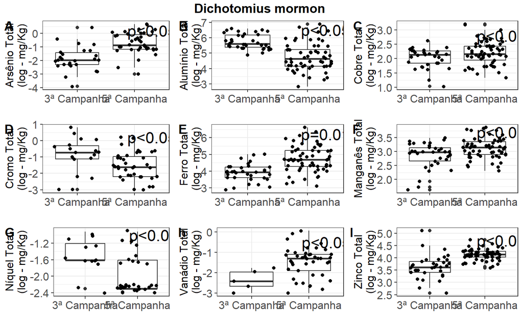

### 4.2. Chalcocopris hesperus

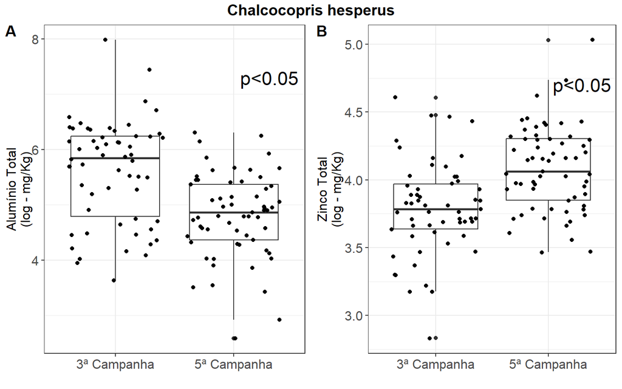

### 4.3. Onthophagus haematopus

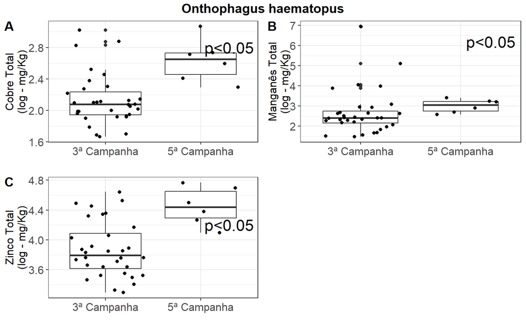

# Odonta

## Objetivo

- Apresentar os resultados obitidos da contaminação de metais em Odonata.

## Dados coletados

| campanha | sitio_amostral | especie | peso_total_g | id_laboratorio | aluminio_total | arsenio_total | cadmio_total | chumbo_total | cobalto_total | cobre_total | cromo_total | ferro_total | manganes_total | niquel_total | vanadio_total | zinco_total | unidade | desnivel_lama | distancia_lama | tipo_de_sitio |
| --- | --- | --- | --- | --- | --- | --- | --- | --- | --- | --- | --- | --- | --- | --- | --- | --- | --- | --- | --- | --- |
| 5a Campanha | LRFG11 | Telebasis carmesina | 0.149 | LB_ODO015 | 30.9 | NA | 0.28 | 1.81 | NA | 17 | 0.06 | 258.4 | 9.9 | NA | 0.07 | 116 | mg/Kg | 2.4322460 | 0.0300775 | LRFG |
| 5a Campanha | LRFG16 | Telebasis carmesina | 0.107 | LB_ODO016 | 89.5 | NA | 0.41 | 2.99 | NA | 16.2 | 0.29 | 135.8 | 7.5 | NA | NA | 117 | mg/Kg | 3.2889484 | -0.0168749 | LRFG |
| 5a Campanha | RRC30 | Hetaerina rosea | 0.127 | LB_ODO017 | 35.9 | NA | 0.31 | 2.22 | NA | 25.4 | NA | 158.2 | 13 | NA | NA | 75 | mg/Kg | -0.3741929 | -0.2974659 | RRC |
| 5a Campanha | RRE02 | Hetaerina rosea | 0.203 | LB_ODO018 | 55.9 | 0.14 | 0.18 | 1.21 | 0.2 | 25 | 0.12 | 235.2 | 6.2 | NA | NA | 82 | mg/Kg | -0.4332758 | -0.2995550 | RRE |
| 5a Campanha | RRF61 | Hetaerina rosea | 0.144 | LB_ODO019 | 30.9 | NA | 0.21 | 1.63 | NA | 23.2 | 0.16 | 141.8 | 5.7 | NA | NA | 73 | mg/Kg | 2.2845387 | -0.2128286 | RRF |
| 3a Campanha | LRES01 | Erythrodiplax paraguayensis | 0.336 | LB_ODO004 - LRES01 | 173.4 | 0.86 | 0.05 | 1.26 | 0.13 | 56.6 | 0.23 | 197.5 | 13.7 | 0.1 | 0.05 | 107 | mg/Kg | -0.5219002 | -0.2993127 | LRES |
| 3a Campanha | LRES02 | Erythrodiplax paraguayensis | 0.51 | LB_ODO011 - LRES02 | 2564.5 | 4.37 | NA | 4.98 | 0.35 | 211 | 3.32 | 795 | 63.1 | 2.5 | 0.51 | 671 | mg/Kg | -0.3151100 | -0.2957663 | LRES |
| 3a Campanha | LRES04 | Erythrodiplax paraguayensis | 0.602 | LB_ODO008 - LRES04 | 2278.2 | 1.86 | 0.07 | 3.66 | 0.24 | 133.3 | 1.61 | 581.7 | 69 | 1.8 | 0.53 | 531 | mg/Kg | -0.3151100 | -0.2957803 | LRES |
| 3a Campanha | LRES07 | Erythrodiplax paraguayensis | 0.343 | LB_ODO007 - LRES07 | 1256.8 | 2.01 | NA | 1.91 | 0.28 | 113.6 | 1.74 | 518.3 | 33.9 | 0.8 | 0.07 | 317 | mg/Kg | -0.3151100 | -0.2974154 | LRES |
| 3a Campanha | LRES10 | Erythrodiplax paraguayensis | 0.36 | LB_ODO002 - LRES10 | 15289.1 | 4.56 | 0.19 | 16.15 | NA | 138.5 | 5.3 | 485.8 | 129.1 | 9.6 | 2.36 | 367 | mg/Kg | -0.4628173 | -0.2966538 | LRES |
| 3a Campanha | LRES12 | Erythrodiplax paraguayensis | 0.365 | LB_ODO003 - LRES12 | 1014.7 | 1.24 | 0.05 | 0.6 | 0.08 | 44.7 | 0.2 | 249.6 | 11.2 | NA | NA | 94 | mg/Kg | NA | NA | LRES |
| 3a Campanha | LRFG15 | Erythrodiplax paraguayensis | 0.436 | LB_ODO014 - LRFG15 | 853.9 | 0.25 | NA | 0.39 | NA | 29.7 | 1.18 | 384.7 | 18.1 | NA | 0.66 | 52 | mg/Kg | 0.1870949 | -0.2257869 | LRFG |
| 3a Campanha | LRFG17 | Erythrodiplax paraguayensis | 0.46 | LB_ODO001 - LRFG17 | 1325.1 | 1.57 | NA | 0.24 | NA | 62.3 | 0.74 | 265.9 | 19.8 | 0.4 | 0.17 | 130 | mg/Kg | 1.0142558 | -0.1879962 | LRFG |
| 3a Campanha | LRFG18 | Erythrodiplax paraguayensis | 0.536 | LB_ODO012 - LRFG18 | 2508.1 | 2.17 | NA | 2.37 | 0.24 | 82.2 | 1.05 | 391.2 | 19.7 | 0.7 | 0.08 | 246 | mg/Kg | 3.2889484 | -0.0411821 | LRFG |
| 3a Campanha | LRFG19 | Erythrodiplax paraguayensis | 0.281 | LB_ODO006 - LRFG19 | 2095.5 | 0.9 | 0.05 | 2.81 | 0.09 | 42.7 | 0.49 | 272.1 | 19 | 0.5 | 0.05 | 100 | mg/Kg | 1.2801290 | -0.1781652 | LRFG |
| 3a Campanha | RRC24 | Erythrodiplax paraguayensis | 0.649 | LB_ODO013 - RCC24 | 40 | 0.17 | NA | 0.86 | 0.1 | 2.7 | 0.49 | 27.1 | NA | NA | NA | 6 | mg/Kg | -0.6400661 | -0.3013298 | RRC |
| 3a Campanha | RRC33 | Erythrodiplax paraguayensis | 0.41 | LB_ODO010 - RRC33 | 720.8 | 0.48 | NA | 0.49 | 0.06 | 23.3 | 0.05 | 101.1 | 4.4 | NA | NA | 63 | mg/Kg | -0.4332758 | -0.2993238 | RRC |
| 3a Campanha | RRC62 | Erythrodiplax paraguayensis | 0.631 | LB_ODO005 - RRC62 | 32.4 | 0.39 | 0.05 | 0.51 | 0.18 | 39.8 | NA | 140.7 | 0.5 | NA | NA | 54 | mg/Kg | -0.6105246 | -0.3006628 | RRC |
| 3a Campanha | RRE02 | Erythrodiplax paraguayensis | 0.769 | LB_ODO009 - RRE02 | 920 | 0.67 | 0.05 | 0.52 | 0.08 | 48.3 | 0.09 | 165 | 9.7 | NA | NA | 94 | mg/Kg | -0.4332758 | -0.2995550 | RRE |

## Tabela de contaminantes

[output not shown]

## 1. Aluminio

- Simplificação do modelo global

```
## Global model call: lme4::lmer(formula = aluminio_total ~ distancia_lama + desnivel_lama +
##     tipo_de_sitio * campanha + (1 | sitio_amostral) + (1 | especie),
##     data = al, na.action = "na.fail")
## ---
## Model selection table
##     (Int) cmp dsn_lam  dst_lam tip_de_sit cmp:tip_de_sit df  logLik  AICc delta
## 6  7.2280   +           2.4200                            6 -28.289  76.2  0.00
## 2  6.6840   +                                             5 -30.685  76.4  0.16
## 5  5.4520               3.1150                            5 -31.373  77.7  1.53
## 1  4.9090                                                 4 -34.031  79.1  2.93
## 8  5.6660   +  0.4883  -3.3410                            7 -27.469  80.1  3.92
## 7  3.6570      0.5173  -4.0550                            6 -30.487  80.6  4.40
## 4  6.5490   +  0.2455                                     6 -30.665  81.0  4.75
## 3  4.6260      0.2727                                     5 -33.909  82.8  6.60
## 9  5.8960                               +                 8 -25.956  83.9  7.70
```

[output cut: 35 more lines]

- Resultado do melhor modelo

```
## Analysis of Deviance Table (Type II Wald chisquare tests)
##
## Response: aluminio_total
##                     Chisq Df Pr(>Chisq)
## distancia_lama 4.9880e-01  1       0.48
## campanha       1.3683e+07  1     <2e-16 ***
## ---
## Signif. codes:  0 '***' 0.001 '**' 0.01 '*' 0.05 '.' 0.1 ' ' 1
```

| contrast | campanha | estimate | SE | df | t.ratio | p.value |
| --- | --- | --- | --- | --- | --- | --- |
| LRES - LRFG | 3a Campanha | 0.5010406 | 1.656173 | 8.000000 | 0.3025291 | 0.9896501 |
| LRES - RRC | 3a Campanha | 2.7653186 | 1.033105 | 8.000000 | 2.6767058 | 0.1049664 |
| LRES - RRE | 3a Campanha | 0.6556246 | 1.532333 | 8.000000 | 0.4278604 | 0.9720324 |
| LRES - RRF | 3a Campanha | NA | NA | NA | NA | NA |
| LRFG - RRC | 3a Campanha | 2.2642781 | 1.748411 | 8.000000 | 1.2950489 | 0.5904854 |
| LRFG - RRE | 3a Campanha | 0.1545840 | 2.090688 | 8.000000 | 0.0739393 | 0.9998421 |
| LRFG - RRF | 3a Campanha | NA | NA | NA | NA | NA |
| RRC - RRE | 3a Campanha | -2.1096941 | 1.620955 | 8.000000 | -1.3015134 | 0.5868934 |
| RRC - RRF | 3a Campanha | NA | NA | NA | NA | NA |
| RRE - RRF | 3a Campanha | NA | NA | NA | NA | NA |
| LRES - LRFG | 5a Campanha | NA | NA | NA | NA | NA |
| LRES - RRC | 5a Campanha | NA | NA | NA | NA | NA |
| LRES - RRE | 5a Campanha | NA | NA | NA | NA | NA |
| LRES - RRF | 5a Campanha | NA | NA | NA | NA | NA |
| LRFG - RRC | 5a Campanha | 0.4722752 | 3.920108 | 10.230408 | 0.1204750 | 0.9993309 |
| LRFG - RRE | 5a Campanha | -0.0110965 | 3.923347 | 10.225990 | -0.0028283 | 1.0000000 |
| LRFG - RRF | 5a Campanha | 2.5609268 | 4.356995 | 9.738895 | 0.5877737 | 0.9335143 |
| RRC - RRE | 5a Campanha | -0.4833717 | 1.978319 | 8.000000 | -0.2443345 | 0.9944589 |
| RRC - RRF | 5a Campanha | 2.0886516 | 2.758477 | 8.000000 | 0.7571756 | 0.8712314 |
| RRE - RRF | 5a Campanha | 2.5720234 | 2.786739 | 8.000000 | 0.9229509 | 0.7938849 |

| contrast | tipo_de_sitio | estimate | SE | df | t.ratio | p.value |
| --- | --- | --- | --- | --- | --- | --- |
| 3a Campanha - 5a Campanha | LRES | NA | NA | NA | NA | NA |
| 3a Campanha - 5a Campanha | LRFG | 2.966490 | 2.673777 | 14.17330 | 1.1094753 | 0.2856956 |
| 3a Campanha - 5a Campanha | RRC | 1.174487 | 2.101723 | 22.41003 | 0.5588209 | 0.5818256 |
| 3a Campanha - 5a Campanha | RRE | 2.800809 | 1.698273 | 17.39235 | 1.6492099 | 0.1170482 |
| 3a Campanha - 5a Campanha | RRF | NA | NA | NA | NA | NA |

## 2. Arsenio

- Simplificação do modelo global

```
## Global model call: lme4::lmer(formula = arsenio_total ~ campanha * tipo_de_sitio +
##     distancia_lama + desnivel_lama + (1 | sitio_amostral) + (1 |
##     especie), data = metal, na.action = "na.fail")
## ---
## Model selection table
##         (Int) cmp dsn_lam dst_lam tip_de_sit cmp:tip_de_sit df  logLik  AICc
## 7  -18.170000      4.7560 -65.670                            6 -13.585  51.2
## 1   -0.779100                                                4 -20.580  53.6
## 5   -0.257300               2.044                            5 -18.170  53.8
## 2    0.003547   +                                            5 -18.713  54.9
## 8  -17.390000   +  4.7560 -65.670                            7 -11.718  56.1
## 6    0.525400   +           2.044                            6 -16.303  56.6
## 3   -0.808000      0.2168                                    5 -20.652  58.8
## 9    0.234600                              +                 7 -14.245  61.2
## 4   -0.025190   +  0.2168                                    6 -18.785  61.6
```

[output cut: 35 more lines]

- Resultado

```
## Analysis of Deviance Table (Type II Wald chisquare tests)
##
## Response: arsenio_total
##                 Chisq Df Pr(>Chisq)
## distancia_lama 4.1175  1    0.04244 *
## desnivel_lama  4.5894  1    0.03217 *
## ---
## Signif. codes:  0 '***' 0.001 '**' 0.01 '*' 0.05 '.' 0.1 ' ' 1
```

| contrast | campanha | estimate | SE | df | t.ratio | p.value |
| --- | --- | --- | --- | --- | --- | --- |
| LRES - LRFG | 3a Campanha | 0.8649733 | 1.1014557 | 7 | 0.7853001 | 0.8589395 |
| LRES - RRC | 3a Campanha | 1.5870603 | 0.5067410 | 7 | 3.1318965 | 0.0630144 |
| LRES - RRE | 3a Campanha | 1.1923272 | 0.6774367 | 7 | 1.7600569 | 0.3642000 |
| LRFG - RRC | 3a Campanha | 0.7220870 | 0.9804898 | 7 | 0.7364554 | 0.8795360 |
| LRFG - RRE | 3a Campanha | 0.3273539 | 1.2311529 | 7 | 0.2658922 | 0.9928279 |
| RRC - RRE | 3a Campanha | -0.3947331 | 0.7467017 | 7 | -0.5286356 | 0.9493676 |
| LRES - LRFG | 5a Campanha | NA | NA | NA | NA | NA |
| LRES - RRC | 5a Campanha | NA | NA | NA | NA | NA |
| LRES - RRE | 5a Campanha | NA | NA | NA | NA | NA |
| LRFG - RRC | 5a Campanha | NA | NA | NA | NA | NA |
| LRFG - RRE | 5a Campanha | NA | NA | NA | NA | NA |
| RRC - RRE | 5a Campanha | NA | NA | NA | NA | NA |

| contrast | tipo_de_sitio | estimate | SE | df | t.ratio | p.value |
| --- | --- | --- | --- | --- | --- | --- |
| 3a Campanha - 5a Campanha | LRES | NA | NA | NA | NA | NA |
| 3a Campanha - 5a Campanha | LRFG | NA | NA | NA | NA | NA |
| 3a Campanha - 5a Campanha | RRC | NA | NA | NA | NA | NA |
| 3a Campanha - 5a Campanha | RRE | 1.565635 | 1.23036 | 109.7932 | 1.272501 | 0.2058833 |

## 3. Chumbo

- Simplificação do modelo global

```
## Global model call: lme4::lmer(formula = chumbo_total ~ distancia_lama + tipo_de_sitio *
##     campanha + desnivel_lama + (1 | especie) + (1 | sitio_amostral),
##     data = metal, na.action = "na.fail")
## ---
## Model selection table
##       (Int) cmp  dsn_lam dst_lam tip_de_sit cmp:tip_de_sit df  logLik  AICc
## 1   0.42070                                                 4 -26.058  63.2
## 5   0.59250               0.7603                            5 -24.225  63.5
## 2   0.20560   +                                             5 -25.131  65.3
## 6   0.02090   +          -0.8229                            6 -23.271  66.2
## 7  -0.17430      0.23970 -2.0710                            6 -23.873  67.4
## 3   0.37290      0.08932                                    5 -26.708  68.4
## 9   1.80900                               +                 8 -19.395  70.8
## 8  -0.35570   +  0.11770 -2.2120                            7 -22.983  71.2
## 4   0.22930   + -0.04305                                    6 -25.847  71.3
```

[output cut: 35 more lines]

- Resultado do melhor modelo

```
## Analysis of Deviance Table (Type II Wald chisquare tests)
##
## Response: chumbo_total
##                 Chisq Df Pr(>Chisq)
## distancia_lama 0.1002  1     0.7516
```

| contrast | campanha | estimate | SE | df | t.ratio | p.value |
| --- | --- | --- | --- | --- | --- | --- |
| LRES - LRFG | 3a Campanha | 2.5199296 | 1.0927042 | 8.000000 | 2.3061408 | 0.1756191 |
| LRES - RRC | 3a Campanha | 1.7174506 | 0.6816185 | 8.000000 | 2.5196655 | 0.1307851 |
| LRES - RRE | 3a Campanha | 1.9380427 | 1.0109973 | 8.000000 | 1.9169613 | 0.2936603 |
| LRES - RRF | 3a Campanha | NA | NA | NA | NA | NA |
| LRFG - RRC | 3a Campanha | -0.8024790 | 1.1535606 | 8.000000 | -0.6956540 | 0.8959441 |
| LRFG - RRE | 3a Campanha | -0.5818869 | 1.3793868 | 8.000000 | -0.4218446 | 0.9731276 |
| LRFG - RRF | 3a Campanha | NA | NA | NA | NA | NA |
| RRC - RRE | 3a Campanha | 0.2205921 | 1.0694676 | 8.000000 | 0.2062634 | 0.9966372 |
| RRC - RRF | 3a Campanha | NA | NA | NA | NA | NA |
| RRE - RRF | 3a Campanha | NA | NA | NA | NA | NA |
| LRES - LRFG | 5a Campanha | NA | NA | NA | NA | NA |
| LRES - RRC | 5a Campanha | NA | NA | NA | NA | NA |
| LRES - RRE | 5a Campanha | NA | NA | NA | NA | NA |
| LRES - RRF | 5a Campanha | NA | NA | NA | NA | NA |
| LRFG - RRC | 5a Campanha | -1.8604649 | 2.5003838 | 8.935940 | -0.7440717 | 0.8769286 |
| LRFG - RRE | 5a Campanha | -1.2895617 | 2.5025945 | 8.934145 | -0.5152899 | 0.9533267 |
| LRFG - RRF | 5a Campanha | 0.0708312 | 2.7975079 | 8.734932 | 0.0253194 | 0.9999937 |
| RRC - RRE | 5a Campanha | 0.5709032 | 1.3052486 | 8.000000 | 0.4373904 | 0.9702433 |
| RRC - RRF | 5a Campanha | 1.9312961 | 1.8199784 | 8.000000 | 1.0611643 | 0.7208165 |
| RRE - RRF | 5a Campanha | 1.3603928 | 1.8386249 | 8.000000 | 0.7398969 | 0.8784176 |

| contrast | tipo_de_sitio | estimate | SE | df | t.ratio | p.value |
| --- | --- | --- | --- | --- | --- | --- |
| 3a Campanha - 5a Campanha | LRES | NA | NA | NA | NA | NA |
| 3a Campanha - 5a Campanha | LRFG | -0.1368721 | 1.6353935 | 10.468198 | -0.0836937 | 0.9348789 |
| 3a Campanha - 5a Campanha | RRC | -1.1948579 | 1.2187398 | 13.372022 | -0.9804044 | 0.3442924 |
| 3a Campanha - 5a Campanha | RRE | -0.8445468 | 0.8542248 | 5.875289 | -0.9886705 | 0.3617755 |
| 3a Campanha - 5a Campanha | RRF | NA | NA | NA | NA | NA |

## 4. Cadmio

```
## Global model call: lme4::lmer(formula = cadmio_total ~ distancia_lama + tipo_de_sitio *
##     campanha + desnivel_lama + (1 | especie) + (1 | sitio_amostral),
##     data = metal, na.action = "na.fail")
## ---
## Model selection table
##       (Int) cmp  dsn_lam  dst_lam tip_de_sit cmp:tip_de_sit df logLik   AICc
## 16  0.07193   + 0.143200 -0.31440          +                11  4.019 -250.0
## 26  0.10330   +                            +              + 11  2.370 -246.7
## 30 -0.68440   +          -2.65000          +              + 12  4.774 -141.5
## 28  0.16330   + 0.138400                   +              + 12  1.816 -135.6
## 32 -0.45140   + 0.040660 -1.92500          +              + 13  4.943 -105.2
## 1   0.21560                                                  4  9.928   -5.2
## 5   0.21060              -0.03022                            5  9.884    2.2
## 2   0.09214   +                                              5  9.834    2.3
## 3   0.20680     0.008303                                     5  7.058    7.9
```

[output cut: 35 more lines]

```
## Analysis of Deviance Table (Type II Wald chisquare tests)
##
## Response: cadmio_total
##                         Chisq Df Pr(>Chisq)
## distancia_lama         0.0325  1     0.8570
## tipo_de_sitio          1.8662  4     0.7604
## campanha               1.2742  1     0.2590
## desnivel_lama          0.0051  1     0.9432
## tipo_de_sitio:campanha 0.3041  2     0.8589
```

| contrast | campanha | estimate | SE | df | t.ratio | p.value |
| --- | --- | --- | --- | --- | --- | --- |
| LRES - LRFG | 3a Campanha | -0.1062805 | NaN | 0.9999695 | NaN | NaN |
| LRES - RRC | 3a Campanha | 0.0526997 | NaN | 1.0000000 | NaN | NaN |
| LRES - RRE | 3a Campanha | 0.0577734 | NaN | 0.9999695 | NaN | NaN |
| LRES - RRF | 3a Campanha | NA | NA | NA | NA | NA |
| LRFG - RRC | 3a Campanha | 0.1589802 | NaN | 0.9999695 | NaN | NaN |
| LRFG - RRE | 3a Campanha | 0.1640539 | NaN | 1.0000000 | NaN | NaN |
| LRFG - RRF | 3a Campanha | NA | NA | NA | NA | NA |
| RRC - RRE | 3a Campanha | 0.0050737 | 0.4387270 | 1.0000509 | 0.0115647 | NaN |
| RRC - RRF | 3a Campanha | NA | NA | NA | NA | NA |
| RRE - RRF | 3a Campanha | NA | NA | NA | NA | NA |
| LRES - LRFG | 5a Campanha | NA | NA | NA | NA | NA |
| LRES - RRC | 5a Campanha | NA | NA | NA | NA | NA |
| LRES - RRE | 5a Campanha | NA | NA | NA | NA | NA |
| LRES - RRF | 5a Campanha | NA | NA | NA | NA | NA |
| LRFG - RRC | 5a Campanha | 0.4889148 | NaN | -0.0000023 | NaN | NaN |
| LRFG - RRE | 5a Campanha | 0.6205349 | NaN | -0.0000024 | NaN | NaN |
| LRFG - RRF | 5a Campanha | 0.5340571 | NaN | -0.0000002 | NaN | NaN |
| RRC - RRE | 5a Campanha | 0.1316201 | 0.1333553 | 1.0000000 | 0.9869882 | NaN |
| RRC - RRF | 5a Campanha | 0.0451423 | NaN | 1.0000814 | NaN | NaN |
| RRE - RRF | 5a Campanha | -0.0864778 | NaN | 1.0000203 | NaN | NaN |

| contrast | tipo_de_sitio | estimate | SE | df | t.ratio | p.value |
| --- | --- | --- | --- | --- | --- | --- |
| 3a Campanha - 5a Campanha | LRES | NA | NA | NA | NA | NA |
| 3a Campanha - 5a Campanha | LRFG | -0.5864809 | NaN | -2e-07 | NaN | NaN |
| 3a Campanha - 5a Campanha | RRC | -0.2565464 | NaN | 0e+00 | NaN | NaN |
| 3a Campanha - 5a Campanha | RRE | -0.1300000 | 0.2167794 | 0e+00 | -0.5996879 | NaN |
| 3a Campanha - 5a Campanha | RRF | NA | NA | NA | NA | NA |

## 5. Cobalto

- Simplificação do modelo global

```
## Global model call: lme4::lmer(formula = cobalto_total ~ distancia_lama + tipo_de_sitio *
##     campanha + desnivel_lama + (1 | especie) + (1 | sitio_amostral),
##     data = metal, na.action = "na.fail")
## ---
## Model selection table
##       (Int) cmp dsn_lam  dst_lam tip_de_sit cmp:tip_de_sit df  logLik  AICc
## 1   -1.8720                                                 4  -9.904  34.5
## 5   -1.6530               0.8285                            5  -8.099  38.2
## 2   -1.8980   +                                             5  -9.356  40.7
## 3   -1.8760     0.07207                                     5 -10.737  43.5
## 7  -12.5600     2.80800 -39.8800                            6  -5.553  44.1
## 6   -1.6380   +           0.9981                            6  -7.479  48.0
## 4   -1.9060   + 0.08330                                     6 -10.117  53.2
## 8  -12.2200   + 2.72400 -38.5300                            7  -5.015  61.4
## 9   -1.2730                               +                 7  -7.517  66.4
```

[output cut: 35 more lines]

- Resultado do melhor modelo

```
## Analysis of Deviance Table (Type II Wald chisquare tests)
##
## Response: cobalto_total
##                 Chisq Df Pr(>Chisq)
## distancia_lama 0.1274  1     0.7211
```

| contrast | campanha | estimate | SE | df | t.ratio | p.value |
| --- | --- | --- | --- | --- | --- | --- |
| LRES - LRFG | 3a Campanha | 1.8104159 | 1.1612157 | 4 | 1.5590694 | 0.4868070 |
| LRES - RRC | 3a Campanha | 0.7751416 | 0.5620268 | 4 | 1.3791897 | 0.5695650 |
| LRES - RRE | 3a Campanha | 1.0539857 | 0.5991639 | 4 | 1.7590941 | 0.4049381 |
| LRFG - RRC | 3a Campanha | -1.0352743 | 1.1564113 | 4 | -0.8952475 | 0.8089849 |
| LRFG - RRE | 3a Campanha | -0.7564302 | 1.2442912 | 4 | -0.6079205 | 0.9244674 |
| RRC - RRE | 3a Campanha | 0.2788441 | 0.6863807 | 4 | 0.4062529 | 0.9745280 |
| LRES - LRFG | 5a Campanha | NA | NA | NA | NA | NA |
| LRES - RRC | 5a Campanha | NA | NA | NA | NA | NA |
| LRES - RRE | 5a Campanha | NA | NA | NA | NA | NA |
| LRFG - RRC | 5a Campanha | NA | NA | NA | NA | NA |
| LRFG - RRE | 5a Campanha | NA | NA | NA | NA | NA |
| RRC - RRE | 5a Campanha | NA | NA | NA | NA | NA |

| contrast | tipo_de_sitio | estimate | SE | df | t.ratio | p.value |
| --- | --- | --- | --- | --- | --- | --- |
| 3a Campanha - 5a Campanha | LRES | NA | NA | NA | NA | NA |
| 3a Campanha - 5a Campanha | LRFG | NA | NA | NA | NA | NA |
| 3a Campanha - 5a Campanha | RRC | NA | NA | NA | NA | NA |
| 3a Campanha - 5a Campanha | RRE | -0.9162907 | 0.1514809 | 0.026501 | -6.048886 | 0.8923507 |

## 6. Cobre

- Simplificação do modelo global

```
## Global model call: lme4::lmer(formula = as.numeric(cobre_total) ~ distancia_lama +
##     campanha * tipo_de_sitio + desnivel_lama + (1 | especie) +
##     (1 | sitio_amostral), data = metal, na.action = "na.fail")
## ---
## Model selection table
##    (Int) cmp   dsn_lam  dst_lam tip_de_sit cmp:tip_de_sit df  logLik  AICc
## 1  3.451                                                   4 -24.951  61.0
## 5  3.259                -0.9454                            5 -23.044  61.1
## 2  3.880   +                                               5 -23.550  62.1
## 6  3.739   +            -0.6280                            6 -21.805  63.2
## 7  2.195      0.325400  -4.9590                            6 -22.629  64.9
## 3  3.461     -0.013120                                     5 -25.705  66.4
## 9  4.594                                 +                 8 -17.525  67.0
## 8  2.821   +  0.287200  -4.0160                            7 -21.458  68.1
## 4  3.883   + -0.004755                                     6 -24.389  68.4
```

[output cut: 35 more lines]

- Resultado do melhor modelo

```
## Analysis of Deviance Table (Type II Wald chisquare tests)
##
## Response: as.numeric(cobre_total)
##                 Chisq Df Pr(>Chisq)
## distancia_lama 0.1392  1     0.7091
```

| contrast | campanha | estimate | SE | df | t.ratio | p.value |
| --- | --- | --- | --- | --- | --- | --- |
| LRES - LRFG | 3a Campanha | 1.4603737 | 0.9375876 | 8.000000 | 1.5575864 | 0.4508210 |
| LRES - RRC | 3a Campanha | 2.1283290 | 0.5848583 | 8.000000 | 3.6390510 | 0.0272046 |
| LRES - RRE | 3a Campanha | 0.8965469 | 0.8674796 | 8.000000 | 1.0335078 | 0.7358598 |
| LRES - RRF | 3a Campanha | NA | NA | NA | NA | NA |
| LRFG - RRC | 3a Campanha | 0.6679553 | 0.9898051 | 8.000000 | 0.6748353 | 0.9037384 |
| LRFG - RRE | 3a Campanha | -0.5638268 | 1.1835738 | 8.000000 | -0.4763766 | 0.9622244 |
| LRFG - RRF | 3a Campanha | NA | NA | NA | NA | NA |
| RRC - RRE | 3a Campanha | -1.2317822 | 0.9176497 | 8.000000 | -1.3423229 | 0.5643344 |
| RRC - RRF | 3a Campanha | NA | NA | NA | NA | NA |
| RRE - RRF | 3a Campanha | NA | NA | NA | NA | NA |
| LRES - LRFG | 5a Campanha | NA | NA | NA | NA | NA |
| LRES - RRC | 5a Campanha | NA | NA | NA | NA | NA |
| LRES - RRE | 5a Campanha | NA | NA | NA | NA | NA |
| LRES - RRF | 5a Campanha | NA | NA | NA | NA | NA |
| LRFG - RRC | 5a Campanha | -1.5042400 | 2.2204078 | 10.251974 | -0.6774611 | 0.9032837 |
| LRFG - RRE | 5a Campanha | -1.5063397 | 2.2222407 | 10.247512 | -0.6778472 | 0.9031408 |
| LRFG - RRF | 5a Campanha | -0.6095294 | 2.4676197 | 9.755513 | -0.2470111 | 0.9943615 |
| RRC - RRE | 5a Campanha | -0.0020997 | 1.1199600 | 8.000000 | -0.0018748 | 1.0000000 |
| RRC - RRF | 5a Campanha | 0.8947106 | 1.5616205 | 8.000000 | 0.5729373 | 0.9374350 |
| RRE - RRF | 5a Campanha | 0.8968103 | 1.5776200 | 8.000000 | 0.5684578 | 0.9387409 |

| contrast | tipo_de_sitio | estimate | SE | df | t.ratio | p.value |
| --- | --- | --- | --- | --- | --- | --- |
| 3a Campanha - 5a Campanha | LRES | NA | NA | NA | NA | NA |
| 3a Campanha - 5a Campanha | LRFG | 1.6010686 | 1.5153832 | 14.23756 | 1.0565438 | 0.3083185 |
| 3a Campanha - 5a Campanha | RRC | -0.5711267 | 1.1919992 | 22.57459 | -0.4791335 | 0.6364524 |
| 3a Campanha - 5a Campanha | RRE | 0.6585557 | 0.9657881 | 17.71050 | 0.6818843 | 0.5041328 |
| 3a Campanha - 5a Campanha | RRF | NA | NA | NA | NA | NA |

## 7. Cromo

- Simplificação do modelo global

```
## Global model call: lme4::lmer(formula = as.numeric(cromo_total) ~ distancia_lama +
##     tipo_de_sitio * campanha + desnivel_lama + (1 | especie) +
##     (1 | sitio_amostral), data = metal, na.action = "na.fail")
## ---
## Model selection table
##      (Int) cmp   dsn_lam  dst_lam tip_de_sit cmp:tip_de_sit df  logLik  AICc
## 5  -1.4260                -3.4620                            5 -23.577  63.2
## 1  -0.6830                                                   4 -26.242  64.1
## 2  -0.3748   +                                               5 -25.091  66.2
## 6  -0.2584   +             0.4621                            6 -22.944  67.2
## 7  -1.7890      0.114000  -4.7910                            6 -23.038  67.4
## 3  -0.5213     -0.234900                                     5 -26.262  68.5
## 4  -0.3993   +  0.129500                                     6 -25.373  72.1
## 8  -1.4770   +  0.422900  -4.0560                            7 -22.260  72.5
## 9   0.4856                                 +                 8 -18.265  73.1
```

[output cut: 35 more lines]

- Resultado do melhor modelo

```
## Analysis of Deviance Table (Type II Wald chisquare tests)
##
## Response: as.numeric(cromo_total)
##                 Chisq Df Pr(>Chisq)
## distancia_lama 1.1307  1     0.2876
```

| contrast | campanha | estimate | SE | df | t.ratio | p.value |
| --- | --- | --- | --- | --- | --- | --- |
| LRES - LRFG | 3a Campanha | 0.4508744 | 1.3617558 | 7.000000 | 0.3310979 | 0.9864313 |
| LRES - RRC | 3a Campanha | 2.2644104 | 0.9678648 | 7.000000 | 2.3395936 | 0.1777676 |
| LRES - RRE | 3a Campanha | 2.8876910 | 1.2599185 | 7.000000 | 2.2919666 | 0.1890255 |
| LRES - RRF | 3a Campanha | NA | NA | NA | NA | NA |
| LRFG - RRC | 3a Campanha | 1.8135360 | 1.5124367 | 7.000000 | 1.1990823 | 0.6463323 |
| LRFG - RRE | 3a Campanha | 2.4368166 | 1.7190190 | 7.000000 | 1.4175623 | 0.5277894 |
| LRFG - RRF | 3a Campanha | NA | NA | NA | NA | NA |
| RRC - RRE | 3a Campanha | 0.6232806 | 1.4113904 | 7.000000 | 0.4416075 | 0.9691944 |
| RRC - RRF | 3a Campanha | NA | NA | NA | NA | NA |
| RRE - RRF | 3a Campanha | NA | NA | NA | NA | NA |
| LRES - LRFG | 5a Campanha | NA | NA | NA | NA | NA |
| LRES - RRC | 5a Campanha | NA | NA | NA | NA | NA |
| LRES - RRE | 5a Campanha | NA | NA | NA | NA | NA |
| LRES - RRF | 5a Campanha | NA | NA | NA | NA | NA |
| LRFG - RRC | 5a Campanha | NA | NA | NA | NA | NA |
| LRFG - RRE | 5a Campanha | 1.1797458 | 3.2448364 | 9.155314 | 0.3635764 | 0.9302787 |
| LRFG - RRF | 5a Campanha | 1.9474934 | 3.6012225 | 8.679874 | 0.5407867 | 0.8535920 |
| RRC - RRE | 5a Campanha | NA | NA | NA | NA | NA |
| RRC - RRF | 5a Campanha | NA | NA | NA | NA | NA |
| RRE - RRF | 5a Campanha | 0.7677476 | 2.2924578 | 7.000000 | 0.3349015 | 0.9405613 |

| contrast | tipo_de_sitio | estimate | SE | df | t.ratio | p.value |
| --- | --- | --- | --- | --- | --- | --- |
| 3a Campanha - 5a Campanha | LRES | NA | NA | NA | NA | NA |
| 3a Campanha - 5a Campanha | LRFG | 0.9693887 | 2.226072 | 13.02335 | 0.4354706 | 0.6703512 |
| 3a Campanha - 5a Campanha | RRC | NA | NA | NA | NA | NA |
| 3a Campanha - 5a Campanha | RRE | -0.2876821 | 1.626278 | 28.00000 | -0.1768960 | 0.8608634 |
| 3a Campanha - 5a Campanha | RRF | NA | NA | NA | NA | NA |

## 8. Ferro

- Simplificação do modelo global

```
## Global model call: lme4::lmer(formula = as.numeric(ferro_total) ~ distancia_lama +
##     tipo_de_sitio * campanha + desnivel_lama + (1 | especie) +
##     (1 | sitio_amostral), data = metal, na.action = "na.fail")
## ---
## Model selection table
##    (Int) cmp  dsn_lam  dst_lam tip_de_sit cmp:tip_de_sit df  logLik  AICc delta
## 1  5.441                                                  4 -21.045  53.2  0.00
## 5  5.521               0.35420                            5 -19.504  54.0  0.84
## 2  5.527   +                                              5 -21.103  57.2  4.04
## 9  6.246                                +                 8 -12.687  57.4  4.21
## 6  5.822   +           1.15600                            6 -19.345  58.3  5.16
## 7  5.648     -0.03978  0.82330                            6 -19.512  58.7  5.49
## 3  5.430      0.02009                                     5 -22.057  59.1  5.95
## 13 5.824              -1.54800          +                 9 -10.653  61.8  8.64
## 4  5.515   +  0.08786                                     6 -21.892  63.4 10.25
```

[output cut: 35 more lines]

- Resultado do melhor modelo

```
## Analysis of Deviance Table (Type II Wald chisquare tests)
##
## Response: as.numeric(ferro_total)
##                 Chisq Df Pr(>Chisq)
## distancia_lama 0.0363  1     0.8489
```

| contrast | campanha | estimate | SE | df | t.ratio | p.value |
| --- | --- | --- | --- | --- | --- | --- |
| LRES - LRFG | 3a Campanha | 0.6778727 | 0.6993828 | 8.000000 | 0.9692442 | 0.7700656 |
| LRES - RRC | 3a Campanha | 1.8900245 | 0.4362684 | 8.000000 | 4.3322521 | 0.0107340 |
| LRES - RRE | 3a Campanha | 1.0450032 | 0.6470865 | 8.000000 | 1.6149359 | 0.4227147 |
| LRES - RRF | 3a Campanha | NA | NA | NA | NA | NA |
| LRFG - RRC | 3a Campanha | 1.2121518 | 0.7383338 | 8.000000 | 1.6417395 | 0.4099461 |
| LRFG - RRE | 3a Campanha | 0.3671305 | 0.8828734 | 8.000000 | 0.4158359 | 0.9741953 |
| LRFG - RRF | 3a Campanha | NA | NA | NA | NA | NA |
| RRC - RRE | 3a Campanha | -0.8450213 | 0.6845103 | 8.000000 | -1.2344902 | 0.6243030 |
| RRC - RRF | 3a Campanha | NA | NA | NA | NA | NA |
| RRE - RRF | 3a Campanha | NA | NA | NA | NA | NA |
| LRES - LRFG | 5a Campanha | NA | NA | NA | NA | NA |
| LRES - RRC | 5a Campanha | NA | NA | NA | NA | NA |
| LRES - RRE | 5a Campanha | NA | NA | NA | NA | NA |
| LRES - RRF | 5a Campanha | NA | NA | NA | NA | NA |
| LRFG - RRC | 5a Campanha | -0.6828754 | 1.6003649 | 8.935940 | -0.4266998 | 0.9724203 |
| LRFG - RRE | 5a Campanha | -1.0763001 | 1.6017799 | 8.934145 | -0.6719401 | 0.9050811 |
| LRFG - RRF | 5a Campanha | -0.7658710 | 1.7905385 | 8.734932 | -0.4277322 | 0.9722315 |
| RRC - RRE | 5a Campanha | -0.3934246 | 0.8354214 | 8.000000 | -0.4709296 | 0.9634129 |
| RRC - RRF | 5a Campanha | -0.0829955 | 1.1648730 | 8.000000 | -0.0712486 | 0.9998587 |
| RRE - RRF | 5a Campanha | 0.3104291 | 1.1768076 | 8.000000 | 0.2637892 | 0.9930621 |

| contrast | tipo_de_sitio | estimate | SE | df | t.ratio | p.value |
| --- | --- | --- | --- | --- | --- | --- |
| 3a Campanha - 5a Campanha | LRES | NA | NA | NA | NA | NA |
| 3a Campanha - 5a Campanha | LRFG | 1.0889398 | 1.0467299 | 10.468198 | 1.0403255 | 0.3216203 |
| 3a Campanha - 5a Campanha | RRC | -0.8060874 | 0.7800516 | 13.372022 | -1.0333770 | 0.3197558 |
| 3a Campanha - 5a Campanha | RRE | -0.3544907 | 0.5467446 | 5.875289 | -0.6483662 | 0.5412428 |
| 3a Campanha - 5a Campanha | RRF | NA | NA | NA | NA | NA |

## 9. Manganes

- Simplificação do modelo global

```
## Global model call: lme4::lmer(formula = as.numeric(manganes_total) ~ distancia_lama +
##     tipo_de_sitio * campanha + desnivel_lama + (1 | especie) +
##     (1 | sitio_amostral), data = metal, na.action = "na.fail")
## ---
## Model selection table
##    (Int) cmp   dsn_lam dst_lam tip_de_sit cmp:tip_de_sit df  logLik  AICc
## 1  2.527                                                  4 -26.799  64.9
## 5  2.386               -0.6611                            5 -24.746  64.9
## 2  2.791   +                                              5 -26.044  67.5
## 6  2.743   +           -0.2181                            6 -24.059  68.5
## 7  2.411     -0.007842 -0.5731                            6 -24.294  69.0
## 9  3.876                                +                 8 -17.536  69.1
## 3  2.561     -0.048810                                    5 -27.301  70.1
## 4  2.804   + -0.022140                                    6 -26.594  73.6
## 8  2.877   + -0.042010  0.2719                            7 -23.615  73.7
```

[output cut: 35 more lines]

```
## Analysis of Deviance Table (Type II Wald chisquare tests)
##
## Response: as.numeric(manganes_total)
##                 Chisq Df Pr(>Chisq)
## distancia_lama 0.0049  1     0.9442
## desnivel_lama  0.0001  1     0.9902
```

| contrast | campanha | estimate | SE | df | t.ratio | p.value |
| --- | --- | --- | --- | --- | --- | --- |
| LRES - LRFG | 3a Campanha | 1.0438954 | 1.0274256 | 7.000000 | 1.0160302 | 0.7460372 |
| LRES - RRC | 3a Campanha | 3.4768143 | 0.7294533 | 7.000000 | 4.7663289 | 0.0085285 |
| LRES - RRE | 3a Campanha | 1.6013699 | 0.9505975 | 7.000000 | 1.6845930 | 0.3970300 |
| LRES - RRF | 3a Campanha | NA | NA | NA | NA | NA |
| LRFG - RRC | 3a Campanha | 2.4329189 | 1.1399578 | 7.000000 | 2.1342183 | 0.2311219 |
| LRFG - RRE | 3a Campanha | 0.5574744 | 1.2969793 | 7.000000 | 0.4298252 | 0.9714453 |
| LRFG - RRF | 3a Campanha | NA | NA | NA | NA | NA |
| RRC - RRE | 3a Campanha | -1.8754444 | 1.0644203 | 7.000000 | -1.7619398 | 0.3634064 |
| RRC - RRF | 3a Campanha | NA | NA | NA | NA | NA |
| RRE - RRF | 3a Campanha | NA | NA | NA | NA | NA |
| LRES - LRFG | 5a Campanha | NA | NA | NA | NA | NA |
| LRES - RRC | 5a Campanha | NA | NA | NA | NA | NA |
| LRES - RRE | 5a Campanha | NA | NA | NA | NA | NA |
| LRES - RRF | 5a Campanha | NA | NA | NA | NA | NA |
| LRFG - RRC | 5a Campanha | -0.6538440 | 2.4463913 | 9.159904 | -0.2672688 | 0.9928473 |
| LRFG - RRE | 5a Campanha | 0.0839660 | 2.4483593 | 9.155669 | 0.0342948 | 0.9999844 |
| LRFG - RRF | 5a Campanha | 0.2822131 | 2.7184576 | 8.678414 | 0.1038137 | 0.9995680 |
| RRC - RRE | 5a Campanha | 0.7378100 | 1.2272702 | 7.000000 | 0.6011797 | 0.9285009 |
| RRC - RRF | 5a Campanha | 0.9360571 | 1.7130779 | 7.000000 | 0.5464183 | 0.9446162 |
| RRE - RRF | 5a Campanha | 0.1982472 | 1.7306664 | 7.000000 | 0.1145496 | 0.9994088 |

| contrast | tipo_de_sitio | estimate | SE | df | t.ratio | p.value |
| --- | --- | --- | --- | --- | --- | --- |
| 3a Campanha - 5a Campanha | LRES | NA | NA | NA | NA | NA |
| 3a Campanha - 5a Campanha | LRFG | 0.9210850 | 1.679823 | 13.02279 | 0.5483226 | 0.5927462 |
| 3a Campanha - 5a Campanha | RRC | -2.1656778 | 1.374539 | 19.34997 | -1.5755665 | 0.1313345 |
| 3a Campanha - 5a Campanha | RRE | 0.4475766 | 1.227207 | 28.01781 | 0.3647114 | 0.7180653 |
| 3a Campanha - 5a Campanha | RRF | NA | NA | NA | NA | NA |

## 10. Niquel

- Simplificação do modelo global

```
## Global model call: glm(formula = as.numeric(niquel_total) ~ distancia_lama + tipo_de_sitio +
##     desnivel_lama, data = metal, na.action = "na.fail")
## ---
## Model selection table
##       (Int) dsn_lam dst_lam tip_de_sit df  logLik AICc delta weight
## 1  -0.09075                             2 -13.304 33.0  0.00  0.796
## 5   0.24800                          +  3 -12.804 37.6  4.60  0.080
## 3  -0.93320          -3.562             3 -13.054 38.1  5.10  0.062
## 2   0.01460 -0.2307                     3 -13.093 38.2  5.18  0.060
## 4 -18.91000  4.7120 -70.490             4 -12.667 46.7 13.66  0.001
## 6   0.35880  0.2871                  +  4 -12.714 46.8 13.75  0.001
## 7   1.38300           3.821          +  4 -12.735 46.8 13.80  0.001
## 8 -12.47000  3.3660 -47.200          +  5 -12.592 65.2 32.18  0.000
## Models ranked by AICc(x)
```

- Resultado do melhor modelo

```
## Analysis of Deviance Table (Type II tests)
##
## Response: as.numeric(niquel_total)
##               LR Chisq Df Pr(>Chisq)
## tipo_de_sitio  0.79814  1     0.3717
```

| contrast | estimate | SE | df | t.ratio | p.value |
| --- | --- | --- | --- | --- | --- |
| LRES - LRFG | 0.8578063 | 3.114876 | 4 | 0.2753901 | 0.7966571 |

## 11. Vanadio

- Simplificação do modelo global

```
## Global model call: lme4::lmer(formula = as.numeric(vanadio_total) ~ distancia_lama +
##     tipo_de_sitio * campanha + desnivel_lama + (1 | especie),
##     data = metal, na.action = "na.fail")
## ---
## Model selection table
##     (Int) cmp dsn_lam dst_lam tip_de_sit cmp:tip_de_sit df  logLik AICc delta
## 5  -2.702             -5.0510                            4 -13.419 42.8  0.00
## 1  -1.647                                                3 -16.579 43.2  0.32
## 2  -1.535   +                                            4 -14.992 46.0  3.15
## 9  -1.221                              +                 4 -15.319 46.6  3.80
## 3  -1.349     -0.4750                                    4 -15.705 47.4  4.57
## 6  -2.919   +         -5.8800                            5 -11.797 48.6  5.76
## 13 -2.825             -5.4030          +                 5 -12.197 49.4  6.56
## 7  -1.111     -0.5512  0.9119                            5 -12.318 49.6  6.80
## 10 -1.221   +                          +                 5 -13.855 52.7  9.87
```

[output cut: 35 more lines]

- Resultado do melhor modelo

  ```
  ## Analysis of Deviance Table (Type II Wald chisquare tests)
  ##
  ## Response: as.numeric(vanadio_total)
  ##                 Chisq Df Pr(>Chisq)
  ## distancia_lama 1.9686  1     0.1606
  ```

  | contrast | campanha | estimate | SE | df | t.ratio | p.value |
  | --- | --- | --- | --- | --- | --- | --- |
  | LRES - LRFG | 3a Campanha | 1.759261 | 2.757724 | 5 | 0.6379394 | 0.5515796 |
  | LRES - LRFG | 5a Campanha | NA | NA | NA | NA | NA |

| contrast | tipo_de_sitio | estimate | SE | df | t.ratio | p.value |
| --- | --- | --- | --- | --- | --- | --- |
| 3a Campanha - 5a Campanha | LRES | NA | NA | NA | NA | NA |
| 3a Campanha - 5a Campanha | LRFG | 9.61779 | 10.72317 | 5.001762 | 0.8969166 | 0.4108517 |

## 12. Zinco

- Simplificação do modelo global

```
## Global model call: lme4::lmer(formula = as.numeric(zinco_total) ~ distancia_lama +
##     tipo_de_sitio * campanha + desnivel_lama + (1 | especie) +
##     (1 | sitio_amostral), data = metal, na.action = "na.fail")
## ---
## Model selection table
##    (Int) cmp dsn_lam  dst_lam tip_de_sit cmp:tip_de_sit df  logLik  AICc delta
## 1  4.700                                                 4 -24.916  60.9  0.00
## 5  4.870              0.76140                            5 -23.039  61.1  0.17
## 9  5.824                               +                 8 -16.010  64.0  3.11
## 7  4.177     0.21640 -1.79600                            6 -22.672  65.0  4.07
## 2  4.776   +                                             5 -25.488  66.0  5.07
## 3  4.651     0.08618                                     5 -25.536  66.1  5.16
## 6  4.981   +          0.91360                            6 -23.596  66.8  5.92
## 13 6.636              2.73500          +                 9 -13.550  67.6  6.69
## 11 5.962     0.35800                   +                 9 -15.518  71.5 10.63
```

[output cut: 35 more lines]

- Resultado do melhor modelo

```
## Analysis of Deviance Table (Type II Wald chisquare tests)
##
## Response: as.numeric(zinco_total)
##                Chisq Df Pr(>Chisq)
## distancia_lama 0.091  1     0.7629
```

| contrast | campanha | estimate | SE | df | t.ratio | p.value |
| --- | --- | --- | --- | --- | --- | --- |
| LRES - LRFG | 3a Campanha | 2.0006700 | 0.9660088 | 8.000000 | 2.0710680 | 0.2406936 |
| LRES - RRC | 3a Campanha | 2.4293017 | 0.6025872 | 8.000000 | 4.0314528 | 0.0159667 |
| LRES - RRE | 3a Campanha | 1.2573637 | 0.8937756 | 8.000000 | 1.4068002 | 0.5292263 |
| LRES - RRF | 3a Campanha | NA | NA | NA | NA | NA |
| LRFG - RRC | 3a Campanha | 0.4286317 | 1.0198092 | 8.000000 | 0.4203058 | 0.9734035 |
| LRFG - RRE | 3a Campanha | -0.7433063 | 1.2194517 | 8.000000 | -0.6095414 | 0.9262030 |
| LRFG - RRF | 3a Campanha | NA | NA | NA | NA | NA |
| RRC - RRE | 3a Campanha | -1.1719380 | 0.9454665 | 8.000000 | -1.2395340 | 0.6214781 |
| RRC - RRF | 3a Campanha | NA | NA | NA | NA | NA |
| RRE - RRF | 3a Campanha | NA | NA | NA | NA | NA |
| LRES - LRFG | 5a Campanha | NA | NA | NA | NA | NA |
| LRES - RRC | 5a Campanha | NA | NA | NA | NA | NA |
| LRES - RRE | 5a Campanha | NA | NA | NA | NA | NA |
| LRES - RRF | 5a Campanha | NA | NA | NA | NA | NA |
| LRFG - RRC | 5a Campanha | -1.1688892 | 2.2104728 | 8.935940 | -0.5287960 | 0.9498949 |
| LRFG - RRE | 5a Campanha | -1.2874242 | 2.2124272 | 8.934145 | -0.5819058 | 0.9350547 |
| LRFG - RRF | 5a Campanha | 0.1765675 | 2.4731464 | 8.734932 | 0.0713939 | 0.9998591 |
| RRC - RRE | 5a Campanha | -0.1185349 | 1.1539095 | 8.000000 | -0.1027246 | 0.9995777 |
| RRC - RRF | 5a Campanha | 1.3454568 | 1.6089581 | 8.000000 | 0.8362286 | 0.8361062 |
| RRE - RRF | 5a Campanha | 1.4639917 | 1.6254426 | 8.000000 | 0.9006727 | 0.8050533 |

| contrast | tipo_de_sitio | estimate | SE | df | t.ratio | p.value |
| --- | --- | --- | --- | --- | --- | --- |
| 3a Campanha - 5a Campanha | LRES | NA | NA | NA | NA | NA |
| 3a Campanha - 5a Campanha | LRFG | 0.6806934 | 1.4457752 | 10.468198 | 0.4708155 | 0.6474302 |
| 3a Campanha - 5a Campanha | RRC | -0.9168275 | 1.0774311 | 13.372022 | -0.8509384 | 0.4097831 |
| 3a Campanha - 5a Campanha | RRE | 0.1365755 | 0.7551803 | 5.875289 | 0.1808516 | 0.8625609 |
| 3a Campanha - 5a Campanha | RRF | NA | NA | NA | NA | NA |

## Tabela Alvo vs Referencia

| contrast | estimate | SE | df | t.ratio | p.value | Metal | grupo |
| --- | --- | --- | --- | --- | --- | --- | --- |
| Alvo - Referência | -0.5785008 | 1.1656085 | 10.28613 | -0.4963080 | 0.6301113 | Aluminio | Odonata |
| Alvo - Referência | 0.1011254 | 0.6483844 | 11.00000 | 0.1559653 | 0.8788858 | Arsenio | Odonata |
| Alvo - Referência | 0.5508988 | 0.8129513 | 10.23301 | 0.6776529 | 0.5130215 | Chumbo | Odonata |
| Alvo - Referência | 0.0208399 | 0.0697055 | 7.75491 | 0.2989713 | 0.7728166 | Cadmio | Odonata |
| Alvo - Referência | 0.0242000 | 0.5048315 | 8.00000 | 0.0479368 | 0.9629418 | Cobalto | Odonata |
| Alvo - Referência | 0.1791035 | 0.7567764 | 10.30080 | 0.2366664 | 0.8175557 | Cobre | Odonata |
| Alvo - Referência | -0.2360691 | 0.9832863 | 9.97626 | -0.2400818 | 0.8151281 | Cromo | Odonata |
| Alvo - Referência | -0.2161897 | 0.5713409 | 12.02299 | -0.3783901 | 0.7117375 | Ferro | Odonata |
| Alvo - Referência | 0.0856788 | 0.9896958 | 10.30035 | 0.0865709 | 0.9326725 | Manganes | Odonata |
| Alvo - Referência | 0.9033933 | 1.0112037 | 6.00000 | 0.8933841 | 0.4060563 | Niquel | Odonata |
| Alvo - Referência | 0.7063226 | 0.9485482 | 7.00000 | 0.7446354 | 0.4807385 | Vanadio | Odonata |
| Alvo - Referência | 0.0791362 | 0.5301871 | 16.00000 | 0.1492610 | 0.8832129 | Zinco | Odonata |

## Graficos

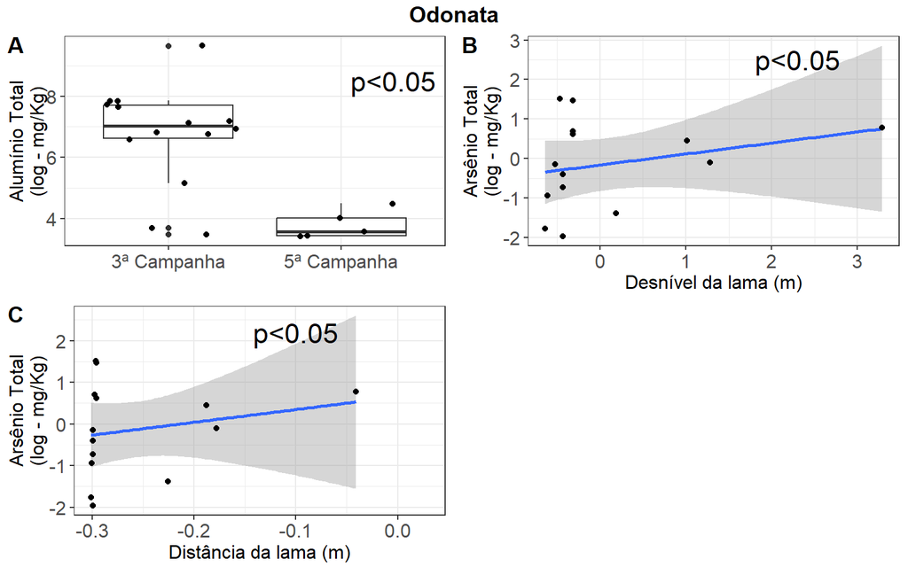